# Analysing Sentences Backbone Communities

#### Most cited references for 1_2_1970-1979: rational_expectations, expectations, expectations_hypothesis, forecasts, adaptive_expectations (1970-1979)

| First Author | Year | Journal | Citation by article | Citation by sentence |
| --- | --- | --- | --- | --- |
| FAMA-E | 1975 | AM EC REV | 1 | 80 |
| GRANGER-C | 1969 | ECONOMETRICA | 1 | 80 |
| FRIEDMAN-M | 1968 | AER | 1 | 80 |
| FISCHER-S | 1977 | JPE | 1 | 80 |
| LUCAS-R | 1972 | J EC THEORY | 1 | 80 |
| FAMA-E | 1970 | J FINANCE | 1 | 80 |
| LUCAS-R | 1971 | ECONOMETRICA | 1 | 80 |
| LUCAS-R | 1973 | AER | 1 | 80 |
| LUCAS-R | 1969 | JPE | 1 | 80 |
| BARRO-R | 1977 | AER | 1 | 80 |

| First Author | Year | Journal | Citation by article | Citation by sentence |
| --- | --- | --- | --- | --- |
| CAGAN-P | 1956 | STUDIES QUANTITY THE | 39 | 3120 |
| PHELPS-E | 1970 | MICROECONOMIC F EMPL | 31 | 2480 |
| BOX-G | 1970 | TIME SERIES ANAL FOR | 22 | 506 |
| FRIEDMAN-M | 1957 | THEORY CONSUMPTION F | 21 | 483 |
| PHELPS-E | 1972 | INFLATION POLICY UNE | 20 | 1600 |
| LEIJONHUFVUD-A | 1968 | KEYNESIAN EC EC KEYN | 20 | 480 |
| MEISELMAN-D | 1962 | TERM STRUCTURE INTER | 17 | 1360 |
| FISHER-I | 1930 | THEORY INTEREST | 13 | 1040 |
| RUTLEDGE-J | 1974 | MONETARIST MODEL INF | 13 | 1040 |
| SHILLER-R | 1972 | THESIS MASSACHUSETTS | 7 | 560 |

#### Most cited references for 1_3_1970-1979: monetary_policy, money_supply, monetary, money_stock, money (1970-1979)

| First Author | Year | Journal | Citation by article | Citation by sentence |
| --- | --- | --- | --- | --- |
| MUTH-J | 1961 | ECONOMETRICA | 22 | 22 |
| FRIEDMAN-M | 1968 | AER | 16 | 16 |
| SARGENT-T | 1975 | JPE | 16 | 16 |
| TOBIN-J | 1969 | J MONEY CREDIT BANKI | 15 | 15 |
| LUCAS-R | 1972 | J EC THEORY | 9 | 18 |
| BAUMOL-W | 1952 | Q J EC | 9 | 18 |
| TOBIN-J | 1956 | REV EC STATIST | 8 | 16 |
| SARGENT-T | 1975 | JPE | 8 | 16 |
| LUCAS-R | 1972 | J EC THEORY | 5 | 15 |
| TOBIN-J | 1965 | ECONOMETRICA | 5 | 15 |

| First Author | Year | Journal | Citation by article | Citation by sentence |
| --- | --- | --- | --- | --- |
| FRIEDMAN-M | 1969 | OPTIMUM QUANTITY MON | 81 | 729 |
| PATINKIN-D | 1965 | MONEY INTEREST PRICE | 59 | 826 |
| FRIEDMAN-M | 1963 | MONETARY HISTORY US | 57 | 456 |
| MUNDELL-R | 1968 | INT ECONOMICS | 31 | 558 |
| MUNDELL-R | 1971 | MONETARY THEORY INFL | 26 | 468 |

#### Most cited references for 1_4_1970-1979: inflation, inflationary, inflation_rate, inflationary_expectations, expectations (1970-1979)

| First Author | Year | Journal | Citation by article | Citation by sentence |
| --- | --- | --- | --- | --- |
| MUTH-J | 1961 | ECONOMETRICA | 16 | 16 |
| FRIEDMAN-M | 1968 | AER | 15 | 15 |
| LUCAS-R | 1973 | AER | 12 | 12 |
| TOBIN-J | 1965 | ECONOMETRICA | 10 | 10 |
| MUTH-J | 1961 | ECONOMETRICA | 9 | 18 |
| MUTH-J | 1961 | ECONOMETRICA | 7 | 21 |
| FRIEDMAN-M | 1968 | AER | 7 | 14 |
| LUCAS-R | 1972 | J EC THEORY | 5 | 10 |
| MUTH-J | 1961 | ECONOMETRICA | 3 | 12 |
| CARLSON-J | 1975 | ECONOMICA | 3 | 12 |

| First Author | Year | Journal | Citation by article | Citation by sentence |
| --- | --- | --- | --- | --- |
| CAGAN-P | 1956 | STUDIES QUANTITY THE | 37 | 259 |
| PHELPS-E | 1972 | INFLATION POLICY UNE | 23 | 230 |
| FRIEDMAN-M | 1969 | OPTIMUM QUANTITY MON | 20 | 160 |
| PHELPS-E | 1970 | MICRO EC F EMPLOYMEN | 19 | 190 |
| PATINKIN-D | 1965 | MONEY INTEREST PRICE | 11 | 88 |
| SOLOW-R | 1969 | PRICE EXPECTATIONS B | 9 | 90 |

#### Most cited references for 1_15_1980-1989: rational_expectations, expectations, expectations_equilibrium, expectations_models, expectations_hypothesis (1980-1989)

| First Author | Year | Journal | Citation by article | Citation by sentence |
| --- | --- | --- | --- | --- |
| DORNBUSCH-R | 1976 | JPE | 54 | 54 |
| LUCAS-R | 1973 | AER | 54 | 54 |
| MUTH-J | 1961 | ECONOMETRICA | 54 | 54 |
| LUCAS-R | 1973 | AER | 35 | 70 |
| MUTH-J | 1961 | ECONOMETRICA | 31 | 62 |
| LUCAS-R | 1972 | J EC THEORY | 30 | 60 |
| MUTH-J | 1961 | ECONOMETRICA | 22 | 110 |
| MUTH-J | 1961 | ECONOMETRICA | 22 | 66 |
| MUTH-J | 1961 | ECONOMETRICA | 21 | 84 |
| SARGENT-T | 1975 | JPE | 19 | 57 |

| First Author | Year | Journal | Citation by article | Citation by sentence |
| --- | --- | --- | --- | --- |
| SARGENT-T | 1979 | MACROECONOMIC THEORY | 122 | 2806 |
| KEYNES-J | 1936 | GENERAL THEORY EMPLO | 99 | 2970 |
| LUCAS-R | 1976 | J MONETARY EC S | 73 | 1606 |
| MALINVAUD-E | 1977 | THEORY UNEMPLOYMENT | 37 | 1332 |
| TOBIN-J | 1980 | ASSET ACCUMULATION M | 33 | 1122 |
| LEIJONHUFVUD-A | 1968 | KEYNESIAN EC EC KEYN | 32 | 1376 |
| BEGG-D | 1982 | RATIONAL EXPECTATION | 30 | 1290 |
| OKUN-A | 1981 | PRICES QUANTITIES MA | 27 | 1161 |

#### Most cited references for 1_18_1980-1989: inflation, monetary_policy, money_supply, monetary, expectations (1980-1989)

| First Author | Year | Journal | Citation by article | Citation by sentence |
| --- | --- | --- | --- | --- |
| LUCAS-R | 1973 | AER | 70 | 70 |
| SARGENT-T | 1975 | JPE | 54 | 54 |
| FISCHER-S | 1977 | JPE | 50 | 50 |
| LUCAS-R | 1973 | AER | 40 | 80 |
| LUCAS-R | 1973 | AER | 26 | 78 |
| FISCHER-S | 1977 | JPE | 26 | 52 |
| LUCAS-R | 1972 | J EC THEORY | 26 | 52 |
| BARRO-R | 1978 | J POLITICAL EC | 26 | 52 |
| SARGENT-T | 1975 | JPE | 25 | 50 |
| SARGENT-T | 1975 | JPE | 19 | 76 |

| First Author | Year | Journal | Citation by article | Citation by sentence |
| --- | --- | --- | --- | --- |
| SARGENT-T | 1979 | MACROECONOMIC THEORY | 81 | 1458 |
| KEYNES-J | 1936 | GENERAL THEORY EMPLO | 70 | 490 |
| FRIEDMAN-M | 1963 | MONETARY HIST US | 53 | 424 |
| CAGAN-P | 1956 | STUDIES QUANTITY THE | 34 | 544 |
| BARRO-R | 1981 | MONEY EXPECTATIONS B | 31 | 558 |
| BARRO-R | 1976 | MONEY EMPLOYMENT INF | 30 | 570 |
| PHELPS-E | 1970 | MICROECONOMIC F EMPL | 28 | 504 |
| BEGG-D | 1982 | RATIONAL EXPECTATION | 17 | 391 |

#### Most cited references for 1_8_1980-1989: exchange_rate, devaluation, exchange, exchange_rates, foreign_exchange (1980-1989)

| First Author | Year | Journal | Citation by article | Citation by sentence |
| --- | --- | --- | --- | --- |
| DORNBUSCH-R | 1976 | JPE | 71 | 71 |
| HANSEN-L | 1980 | J POLITICAL EC | 32 | 32 |
| KOURI-P | 1976 | SCANDINAVIAN J EC | 27 | 27 |
| MEESE-R | 1983 | J INT EC | 23 | 23 |
| CALVO-G | 1977 | J POLITICAL EC | 22 | 22 |
| FRENKEL-J | 1981 | J POLITICAL EC | 21 | 21 |
| DORNBUSCH-R | 1976 | JPE | 19 | 38 |
| DORNBUSCH-R | 1976 | JPE | 11 | 33 |
| DORNBUSCH-R | 1976 | JPE | 8 | 32 |
| DORNBUSCH-R | 1976 | JPE | 7 | 35 |

| First Author | Year | Journal | Citation by article | Citation by sentence |
| --- | --- | --- | --- | --- |
| DORNBUSCH-R | 1980 | OPEN EC MACROECONOMI | 40 | 400 |
| MUNDELL-R | 1968 | INT EC | 30 | 300 |
| BILSON-J | 1978 | EC EXCHANGE RATES SE | 25 | 450 |
| ISARD-P | 1978 | PRINCETON STUDIES IN | 20 | 220 |
| FRANKEL-J | 1986 | IN PRESS EC RECORD | 19 | 342 |
| MUSSA-M | 1979 | POLICIES EMPLOYMENT | 19 | 209 |
| LEVICH-R | 1979 | INT EC POLICY THEORY | 18 | 324 |
| SARGENT-T | 1979 | MACROECONOMIC THEORY | 18 | 198 |
| HANSEN-L | 1983 | EXCHANGE RATES INT M | 17 | 306 |
| CUMBY-R | 1984 | EXCHANGE RATE THEORY | 14 | 252 |

#### Most cited references for 1_3_1990-1999: rational_expectations, expectations, expectations_equilibrium, forecasts, learning (1990-1999)

| First Author | Year | Journal | Citation by article | Citation by sentence |
| --- | --- | --- | --- | --- |
| HANSEN-L | 1982 | ECONOMETRICA | 58 | 58 |
| MARCET-A | 1989 | J ECON THEORY | 4 | 60 |
| MUTH-J | 1961 | ECONOMETRICA | 4 | 60 |
| ENGLE-R | 1987 | ECONOMETRICA | 1 | 57 |
| JOHANSEN-S | 1991 | ECONOMETRICA | 1 | 57 |
| MARCET-A | 1989 | J ECON THEORY | 1 | 57 |
| LUCAS-R | 1971 | ECONOMETRICA | 1 | 57 |
| SMITH-V | 1988 | ECONOMETRICA | 1 | 57 |
| DICKEY-D | 1986 | AM STAT | 1 | 57 |
| LEIDERMAN-L | 1980 | J MONETARY EC | 1 | 57 |

| First Author | Year | Journal | Citation by article | Citation by sentence |
| --- | --- | --- | --- | --- |
| SARGENT-T | 1987 | MACROECONOMIC THEORY | 80 | 4560 |
| KEYNES-J | 1936 | GENERAL THEORY EMPLO | 80 | 2800 |
| BLANCHARD-O | 1989 | LECT MACROECONOMICS | 60 | 1500 |
| FULLER-W | 1976 | INTRO STATISTICAL TI | 56 | 1064 |
| SARGENT-T | 1993 | BOUNDED RATIONALITY | 31 | 1178 |

#### Most cited references for 1_2_1990-1999: inflation, monetary_policy, rational_expectations, expectations, monetary (1990-1999)

| First Author | Year | Journal | Citation by article | Citation by sentence |
| --- | --- | --- | --- | --- |
| ENGLE-R | 1987 | ECONOMETRICA | 65 | 65 |
| BARRO-R | 1983 | J POLITICAL EC | 41 | 41 |
| BARRO-R | 1983 | J MONETARY EC | 41 | 41 |
| WHITE-H | 1980 | ECONOMETRICA | 40 | 40 |
| KYDLAND-F | 1977 | J POLITICAL EC | 39 | 39 |
| BARRO-R | 1983 | J MONETARY EC | 29 | 58 |
| ENGLE-R | 1987 | ECONOMETRICA | 26 | 52 |
| KYDLAND-F | 1977 | J POLITICAL EC | 25 | 50 |
| LUCAS-R | 1972 | J EC THEORY | 23 | 46 |
| ROGOFF-K | 1985 | Q J ECON | 21 | 42 |

| First Author | Year | Journal | Citation by article | Citation by sentence |
| --- | --- | --- | --- | --- |
| KEYNES-J | 1936 | GENERAL THEORY EMPLO | 111 | 2442 |
| FRIEDMAN-M | 1963 | MONETARY HIST US 186 | 94 | 940 |
| KEYNES-J | 1973 | GENERAL THEORY EMPLO | 70 | 1960 |
| SARGENT-T | 1987 | MACROECONOMIC THEORY | 66 | 924 |
| CUKIERMAN-A | 1992 | CENTRAL BANK STRATEG | 60 | 960 |
| FRIEDMAN-M | 1969 | OPTIMUM QUANTITY MON | 46 | 966 |
| PATINKIN-D | 1965 | MONEY INTEREST PRICE | 41 | 861 |

#### Most cited references for 1_3_2000-2009: monetary_policy, inflation, central_bank, rational_expectations, monetary (2000-2009)

| First Author | Year | Journal | Citation by article | Citation by sentence |
| --- | --- | --- | --- | --- |
| TAYLOR-J | 1993 | CARNEGIE-ROCHESTER C | 104 | 104 |
| CALVO-G | 1983 | J MONETARY ECON | 84 | 84 |
| CLARIDA-R | 1999 | J ECON LIT | 73 | 73 |
| CLARIDA-R | 2000 | Q J ECON | 57 | 57 |
| TAYLOR-J | 1993 | CARNEGIE-ROCHESTER C | 45 | 90 |
| CALVO-G | 1983 | J MONETARY ECON | 42 | 84 |
| CLARIDA-R | 1999 | J ECON LIT | 42 | 84 |
| CLARIDA-R | 2000 | Q J ECON | 26 | 52 |
| TAYLOR-J | 1993 | CARNEGIE-ROCHESTER C | 21 | 63 |
| CLARIDA-R | 1999 | J ECON LIT | 19 | 76 |

| First Author | Year | Journal | Citation by article | Citation by sentence |
| --- | --- | --- | --- | --- |
| WOODFORD-M | 2003 | KNOWLEDGE INFORM EXP | 238 | 9044 |
| WOODFORD-M | 1999 | 7261 NBER | 83 | 2490 |
| EVANS-G | 2001 | LEARNING EXPECTATION | 73 | 2336 |
| TAYLOR-J | 1999 | NBER BUSINESS CYCLES | 73 | 2190 |

#### Most cited references for 1_4_2000-2009: rational_expectations, expectations, expectations_equilibrium, agents, learning (2000-2009)

| First Author | Year | Journal | Citation by article | Citation by sentence |
| --- | --- | --- | --- | --- |
| CALVO-G | 1983 | J MONETARY ECON | 16 | 64 |
| CLARIDA-R | 1999 | J ECON LIT | 15 | 60 |
| TAYLOR-J | 1993 | CARNEGIE-ROCHESTER C | 13 | 52 |
| BROCK-W | 1997 | ECONOMETRICA | 7 | 56 |
| MARCET-A | 1989 | J ECON THEORY | 4 | 64 |
| MUTH-J | 1961 | ECONOMETRICA | 3 | 72 |
| MUTH-J | 1961 | ECONOMETRICA | 3 | 57 |
| BRANCH-W | 2004 | ECON J | 2 | 58 |
| DELONG-J | 1990 | J POLIT ECON | 2 | 54 |
| GROSSMAN-S | 1980 | AM EC REV | 1 | 54 |

| First Author | Year | Journal | Citation by article | Citation by sentence |
| --- | --- | --- | --- | --- |
| WOODFORD-M | 2003 | INTEREST PRICES | 163 | 6194 |
| EVANS-G | 2001 | LEARNING EXPECTATION | 129 | 6966 |
| KEYNES-J | 1936 | GEN THEORY EMPLOYMEN | 64 | 3456 |

## Intertemporal cluster *2: tariff, bidders, workable_competition, seller*

The cluster gathers 22064 sentences from our corpus. It represents 8.67% of all the sentences selected over the whole period.

The community exists from 1900 to 2009.

The most recurring journals are The American Economic Review (1454 sentences; 886 articles), International Journal of Industrial Organization (1029 sentences; 401 articles), The Review of Economic Studies (817 sentences; 369 articles), Econometrica (769 sentences; 363 articles), Journal of Political Economy (729 sentences; 475 articles), The Quarterly Journal of Economics (699 sentences; 425 articles).

- The most recurring authors of the cluster 2_2_1900-1919: monopoly, endemann, seldom_perfectly, drawn_wholly, price_fixing (1900-1919): F. W. Taussig (6 sentences; 4 articles), F. Y. Edgeworth (6 sentences; 4 articles), G. P. Watkins (5 sentences; 3 articles), Lewis H. Haney (4 sentences; 3 articles), H. J. Davenport (4 sentences; 3 articles), T. N. Carver (4 sentences; 2 articles).
- The most recurring authors of the cluster 2_8_1900-1919: tariff, free_trade, fiscal_controversy, protectionist, duties (1900-1919): H. Parker Willis (11 sentences; 6 articles), L. L. Price (11 sentences; 4 articles), F. W. Taussig (4 sentences; 4 articles), F. Y. Edgeworth (4 sentences; 3 articles), Thomas Walker Page (3 sentences; 1 articles), William S. Culbertson (3 sentences; 1 articles).
- The most recurring authors of the cluster 2_3_1920-1929: prices, price_level, price, remained_equal, producers_actions (1920-1929): Yasuma Takata (9 sentences; 1 articles), Holbrook Working (6 sentences; 3 articles), Raymond T. Bye (6 sentences; 4 articles), A. B. Wolfe (6 sentences; 2 articles), Frederick A. Bradford (6 sentences; 1 articles), Mordecai Ezekiel (5 sentences; 3 articles).
- The most recurring authors of the cluster 2_12_1930-1939: price, prices, productive_price, demand_curve, rigidity (1930-1939): Nicholas Kaldor (14 sentences; 7 articles), A. P. Lerner (10 sentences; 4 articles), Frank H. Knight (8 sentences; 4 articles), Wassily W. Leontief (7 sentences; 4 articles), O. B. Jesness (6 sentences; 4 articles), F. A. von Hayek (6 sentences; 5 articles).
- The most recurring authors of the cluster 2_8_1930-1939: monopoly, competition, pure_competition, perfect_competition, arranging_actual (1930-1939): Edward H. Chamberlin (11 sentences; 2 articles), Nicholas Kaldor (5 sentences; 4 articles), B. N. Behling (4 sentences; 1 articles), Joseph A. Schumpeter (4 sentences; 2 articles), A. J. Nichol (4 sentences; 2 articles), Frank Albert Fetter (4 sentences; 2 articles).
- The most recurring authors of the cluster 2_6_1940-1949: price_control, prices, price, pricing, price_policy (1940-1949): J. K. Galbraith (9 sentences; 4 articles), R. H. Coase (9 sentences; 3 articles), Henry M. Oliver (8 sentences; 2 articles), Emery Troxel (8 sentences; 2 articles), W. M. Drummond (6 sentences; 3 articles), T. de Scitovszky (6 sentences; 1 articles).
- The most recurring authors of the cluster 2_5_1940-1949: monopoly, competition, antitrust, pure_competition, perfect_competition (1940-1949): William H. Nicholls (8 sentences; 3 articles), J. M. Clark (6 sentences; 2 articles), Alfred Nicols (4 sentences; 3 articles), K. E. Boulding (4 sentences; 2 articles), G. F. Shove (4 sentences; 1 articles), John R. Commons (3 sentences; 2 articles).
- The most recurring authors of the cluster 2_8_1950-1959: pricing, price, prices, cost_pricing, price_mechanism (1950-1959): Robert F. Lanzillotti (10 sentences; 3 articles), J. Wiseman (7 sentences; 2 articles), Jesse W. Markham (6 sentences; 4 articles), Milton Friedman (6 sentences; 5 articles), M. J. Farrell (6 sentences; 3 articles), Tjalling C. Koopmans (6 sentences; 2 articles).
- The most recurring authors of the cluster 2_7_1950-1959: monopoly, competition, workable_competition, perfect_competition, pure_competition (1950-1959): Walter Adams (6 sentences; 3 articles), Edward S. Mason (6 sentences; 2 articles), Jesse W. Markham (5 sentences; 4 articles), Stephen H. Sosnick (5 sentences; 1 articles), J. N. Wolfe (4 sentences; 2 articles), Shorey Peterson (4 sentences; 1 articles).
- The most recurring authors of the cluster 2_14_1960-1969: prices, price, pricing, monopoly, price_discrimination (1960-1969): Lucile Sheppard Keyes (26 sentences; 5 articles), Odd Langholm (22 sentences; 1 articles), Romney Robinson (21 sentences; 2 articles), C. E. Ferguson (14 sentences; 11 articles), E. J. Mishan (12 sentences; 5 articles), Robert L. Bishop (10 sentences; 4 articles).
- The most recurring authors of the cluster 2_11_1970-1979: prices, price, pricing, price_level, factor_price (1970-1979): Aubrey Silberston (26 sentences; 1 articles), Stephen J. Turnovsky (24 sentences; 12 articles), Marian Sling (20 sentences; 7 articles), Roger Sherman (19 sentences; 9 articles), David P. Baron (18 sentences; 6 articles), William J. Baumol (18 sentences; 9 articles).
- The most recurring authors of the cluster 2_11_1980-1989: price, prices, price_level, market_clearing, pricing (1980-1989): Julio J. Rotemberg (38 sentences; 9 articles), Torben M. Andersen (27 sentences; 7 articles), Joseph E. Stiglitz (27 sentences; 15 articles), Lars E. O. Svensson (24 sentences; 9 articles), Laurence Ball (23 sentences; 5 articles), Bennett T. McCallum (22 sentences; 9 articles).
- The most recurring authors of the cluster 2_7_1990-1999: seller, buyer, bidders, auction, buyers (1990-1999): Michael Peters (38 sentences; 6 articles), Daniel R. Vincent (38 sentences; 5 articles), In-Koo Cho (34 sentences; 2 articles), Raymond J. Deneckere (32 sentences; 3 articles), Lawrence M. Ausubel (31 sentences; 2 articles), Chantale LaCasse (23 sentences; 2 articles).
- The most recurring authors of the cluster 2_6_1990-1999: firms, pricing, firm, price, prices (1990-1999): Schultz C. (14 sentences; 3 articles), Julio J. Rotemberg (11 sentences; 4 articles), Andrew F. Daughety (11 sentences; 3 articles), Jennifer F. Reinganum (11 sentences; 3 articles), Laurence Ball (10 sentences; 5 articles), Kneip A. (9 sentences; 1 articles).
- The most recurring authors of the cluster 2_11_2000-2009: firms, firm, pricing, bertrand, cournot (2000-2009): Tasnádi A. (19 sentences; 4 articles), Boyer M. (19 sentences; 3 articles), Fluet C. (19 sentences; 1 articles), Comino S. (18 sentences; 1 articles), Bergin P. (16 sentences; 4 articles), Huang W. (15 sentences; 3 articles).
- The most recurring authors of the cluster 2_9_2000-2009: bidders, bidder, auction, seller, buyers (2000-2009): Johannes Hörner (46 sentences; 3 articles), Battigalli P. (41 sentences; 1 articles), Gonçalves R. (40 sentences; 1 articles), Ignacio Esponda (33 sentences; 2 articles), Subir Bose (31 sentences; 5 articles), Jullien B. (29 sentences; 1 articles).

### Top TF-IDF terms describing the community

| Token | TF-IDF |
| --- | --- |
| tariff | 0.0493538 |
| bidders | 0.0159428 |
| workable_competition | 0.0140782 |
| seller | 0.0140662 |
| monopoly | 0.0135806 |
| auction | 0.0130530 |
| bidder | 0.0129136 |
| fiscal_controversy | 0.0128864 |
| protectionist | 0.0125936 |
| competition | 0.0117753 |
| duties | 0.0115712 |
| free_trade | 0.0110059 |
| buyer | 0.0104543 |
| pure_competition | 0.0102189 |
| buyers | 0.0101219 |
| tariff_law | 0.0096648 |
| tariff_bill | 0.0096648 |
| antitrust | 0.0092725 |
| colonial | 0.0088527 |
| bid | 0.0086882 |

### Top TF-IDF terms describing the different k-means clusters

#### Top terms 2_2_1900-1919: monopoly, endemann, seldom_perfectly, drawn_wholly, price_fixing (1900-1919)

| Token | TF-IDF |
| --- | --- |
| monopoly | 0.0073061 |
| endemann | 0.0065750 |
| seldom_perfectly | 0.0065750 |
| drawn_wholly | 0.0065750 |
| price_fixing | 0.0054883 |
| superiors | 0.0040866 |
| prices | 0.0038023 |
| timber | 0.0036305 |
| price_maintenance | 0.0036305 |
| fixing | 0.0035122 |
| price_determination | 0.0032756 |
| price | 0.0032713 |
| price_equation | 0.0031120 |
| discerned | 0.0028789 |
| accidental | 0.0028098 |

#### Top terms 2_8_1900-1919: tariff, free_trade, fiscal_controversy, protectionist, duties (1900-1919)

| Token | TF-IDF |
| --- | --- |
| tariff | 0.0493538 |
| free_trade | 0.0163282 |
| fiscal_controversy | 0.0128864 |
| protectionist | 0.0125936 |
| duties | 0.0115712 |
| tariff_law | 0.0096648 |
| tariff_bill | 0.0096648 |
| colonial | 0.0088527 |
| colonies | 0.0075997 |
| tariffs | 0.0067228 |
| protection | 0.0066053 |
| reichstag | 0.0064432 |
| tariff_revision | 0.0064432 |
| importers_desired | 0.0064432 |
| prime_motive | 0.0064432 |

#### Top terms 2_3_1920-1929: prices, price_level, price, remained_equal, producers_actions (1920-1929)

| Token | TF-IDF |
| --- | --- |
| prices | 0.0045047 |
| price_level | 0.0042908 |
| price | 0.0038354 |
| remained_equal | 0.0035109 |
| producers_actions | 0.0035109 |
| stable_price | 0.0030745 |
| mutton | 0.0027607 |
| theory_demands | 0.0027607 |
| rising_price | 0.0024119 |
| price_determination | 0.0023321 |
| increased_consumption | 0.0022874 |
| secular_trend | 0.0022874 |
| normal_price | 0.0021979 |
| price_fixing | 0.0021979 |
| cost_accounting | 0.0021821 |

#### Top terms 2_12_1930-1939: price, prices, productive_price, demand_curve, rigidity (1930-1939)

| Token | TF-IDF |
| --- | --- |
| price | 0.0037093 |
| prices | 0.0032634 |
| productive_price | 0.0024851 |
| demand_curve | 0.0021870 |
| rigidity | 0.0021582 |
| supply | 0.0020819 |
| tea | 0.0020595 |
| price_rigidity | 0.0019604 |
| movements | 0.0017761 |
| price_movements | 0.0017572 |
| real_cost | 0.0017286 |
| fluctuated | 0.0017072 |
| price_level | 0.0016873 |
| individual_producer | 0.0016191 |
| market_demand | 0.0015173 |

#### Top terms 2_8_1930-1939: monopoly, competition, pure_competition, perfect_competition, arranging_actual (1930-1939)

| Token | TF-IDF |
| --- | --- |
| monopoly | 0.0257601 |
| competition | 0.0172149 |
| pure_competition | 0.0139163 |
| perfect_competition | 0.0127636 |
| arranging_actual | 0.0073505 |
| involving_insuperable | 0.0073505 |
| discrimination_implies | 0.0073505 |
| supposed_manifestations | 0.0073505 |
| water_carriers | 0.0073505 |
| paine | 0.0063596 |
| perfectly_satisfactory | 0.0063596 |
| free_competition | 0.0059961 |
| imperfect_competition | 0.0058798 |
| insuperable_difficulties | 0.0057799 |
| simple_monopoly | 0.0057799 |

#### Top terms 2_6_1940-1949: price_control, prices, price, pricing, price_policy (1940-1949)

| Token | TF-IDF |
| --- | --- |
| price_control | 0.0072157 |
| prices | 0.0046838 |
| price | 0.0043913 |
| pricing | 0.0043176 |
| price_policy | 0.0040643 |
| cost_pricing | 0.0035976 |
| price_system | 0.0031399 |
| pricing_system | 0.0028810 |
| price_structure | 0.0024442 |
| price_level | 0.0024413 |
| price_regulation | 0.0022306 |
| price_decisions | 0.0020681 |
| uncontrolled_prices | 0.0019443 |
| price_policies | 0.0019353 |
| wartime | 0.0018623 |

#### Top terms 2_5_1940-1949: monopoly, competition, antitrust, pure_competition, perfect_competition (1940-1949)

| Token | TF-IDF |
| --- | --- |
| monopoly | 0.0186270 |
| competition | 0.0116122 |
| antitrust | 0.0092725 |
| pure_competition | 0.0087575 |
| perfect_competition | 0.0076156 |
| imperfect_competition | 0.0059202 |
| free_trade | 0.0056835 |
| monopolistic | 0.0056071 |
| monopoly_power | 0.0050311 |
| socialisation | 0.0048497 |
| antitrust_policy | 0.0048497 |
| international_trade | 0.0042491 |
| competition_theory | 0.0042370 |
| standard_oil | 0.0041117 |
| justice_stone | 0.0041117 |

#### Top terms 2_8_1950-1959: pricing, price, prices, cost_pricing, price_mechanism (1950-1959)

| Token | TF-IDF |
| --- | --- |
| pricing | 0.0049317 |
| price | 0.0040726 |
| prices | 0.0037615 |
| cost_pricing | 0.0031200 |
| price_mechanism | 0.0024562 |
| price_system | 0.0023218 |
| marginal_cost | 0.0022734 |
| price_discrimination | 0.0019921 |
| price_policy | 0.0019522 |
| price_level | 0.0019055 |
| supply | 0.0018577 |
| price_leadership | 0.0018170 |
| aluminum | 0.0017540 |
| castings | 0.0017540 |
| administered | 0.0015969 |

#### Top terms 2_7_1950-1959: monopoly, competition, workable_competition, perfect_competition, pure_competition (1950-1959)

| Token | TF-IDF |
| --- | --- |
| monopoly | 0.0255375 |
| competition | 0.0160987 |
| workable_competition | 0.0140782 |
| perfect_competition | 0.0089254 |
| pure_competition | 0.0079828 |
| workable | 0.0070482 |
| monopoly_gains | 0.0062538 |
| imperfect_competition | 0.0053965 |
| shillings | 0.0052793 |
| monopoly_power | 0.0049136 |
| meeting_competition | 0.0048188 |
| competition_requires | 0.0048188 |
| offsetting_imperfections | 0.0048188 |
| competition_theories | 0.0048188 |
| business_justification | 0.0048188 |

#### Top terms 2_14_1960-1969: prices, price, pricing, monopoly, price_discrimination (1960-1969)

| Token | TF-IDF |
| --- | --- |
| prices | 0.0038377 |
| price | 0.0034027 |
| pricing | 0.0029965 |
| monopoly | 0.0026654 |
| price_discrimination | 0.0022094 |
| competition | 0.0021752 |
| relative_prices | 0.0017730 |
| factor_prices | 0.0017364 |
| price_system | 0.0016981 |
| price_stability | 0.0016296 |
| market | 0.0014965 |
| price_policy | 0.0014827 |
| discrimination | 0.0013667 |
| perfect_competition | 0.0012794 |
| cost_pricing | 0.0012638 |

#### Top terms 2_11_1970-1979: prices, price, pricing, price_level, factor_price (1970-1979)

| Token | TF-IDF |
| --- | --- |
| prices | 0.0041688 |
| price | 0.0040043 |
| pricing | 0.0024899 |
| price_level | 0.0017819 |
| factor_price | 0.0017347 |
| relative_prices | 0.0016927 |
| excess_demand | 0.0016037 |
| monopoly | 0.0015878 |
| factor_prices | 0.0015583 |
| price_system | 0.0015010 |
| price_expectations | 0.0013504 |
| rationing | 0.0013431 |
| price_stability | 0.0012019 |
| price_change | 0.0011662 |
| relative_price | 0.0011551 |

#### Top terms 2_11_1980-1989: price, prices, price_level, market_clearing, pricing (1980-1989)

| Token | TF-IDF |
| --- | --- |
| price | 0.0043750 |
| prices | 0.0039584 |
| price_level | 0.0029150 |
| market_clearing | 0.0026268 |
| pricing | 0.0025661 |
| model | 0.0021624 |
| clearing | 0.0021565 |
| firms | 0.0021235 |
| firm | 0.0020850 |
| expectations | 0.0019380 |
| price_expectations | 0.0017824 |
| equilibrium | 0.0016330 |
| relative_prices | 0.0015910 |
| price_uncertainty | 0.0014592 |
| output | 0.0014239 |

#### Top terms 2_7_1990-1999: seller, buyer, bidders, auction, buyers (1990-1999)

| Token | TF-IDF |
| --- | --- |
| seller | 0.0160440 |
| buyer | 0.0127133 |
| bidders | 0.0122490 |
| auction | 0.0117684 |
| buyers | 0.0103587 |
| seller’s | 0.0085752 |
| bidder | 0.0085042 |
| bid | 0.0076975 |
| sellers | 0.0075469 |
| bidding | 0.0068231 |
| auctions | 0.0066461 |
| bids | 0.0064495 |
| buyer’s | 0.0054029 |
| reserve_price | 0.0048714 |
| beliefs | 0.0037819 |

#### Top terms 2_6_1990-1999: firms, pricing, firm, price, prices (1990-1999)

| Token | TF-IDF |
| --- | --- |
| firms | 0.0049948 |
| pricing | 0.0045273 |
| firm | 0.0038819 |
| price | 0.0037347 |
| prices | 0.0035208 |
| monopolist | 0.0025864 |
| cournot | 0.0023352 |
| entry | 0.0021414 |
| equilibrium | 0.0019924 |
| model | 0.0019831 |
| price_taking | 0.0019084 |
| price_setting | 0.0017400 |
| game | 0.0016051 |
| firm’s | 0.0015836 |
| bertrand | 0.0015820 |

#### Top terms 2_11_2000-2009: firms, firm, pricing, bertrand, cournot (2000-2009)

| Token | TF-IDF |
| --- | --- |
| firms | 0.0079194 |
| firm | 0.0063141 |
| pricing | 0.0050977 |
| bertrand | 0.0047087 |
| cournot | 0.0035457 |
| price | 0.0034352 |
| price_setting | 0.0030126 |
| price_puzzle | 0.0028741 |
| entrant | 0.0027772 |
| entry | 0.0027334 |
| model | 0.0027223 |
| equilibrium | 0.0025572 |
| prices | 0.0023640 |
| firms_choose | 0.0022914 |
| incumbent | 0.0022601 |

#### Top terms 2_9_2000-2009: bidders, bidder, auction, seller, buyers (2000-2009)

| Token | TF-IDF |
| --- | --- |
| bidders | 0.0196366 |
| bidder | 0.0173230 |
| auction | 0.0143377 |
| seller | 0.0120885 |
| buyers | 0.0098852 |
| bid | 0.0096789 |
| auctions | 0.0091819 |
| bidding | 0.0086238 |
| buyer | 0.0081954 |
| bids | 0.0078015 |
| sellers | 0.0056438 |
| reserve_price | 0.0053255 |
| seller’s | 0.0048512 |
| price_auction | 0.0034442 |
| buyer’s | 0.0032898 |

### Distribution of sentences over time

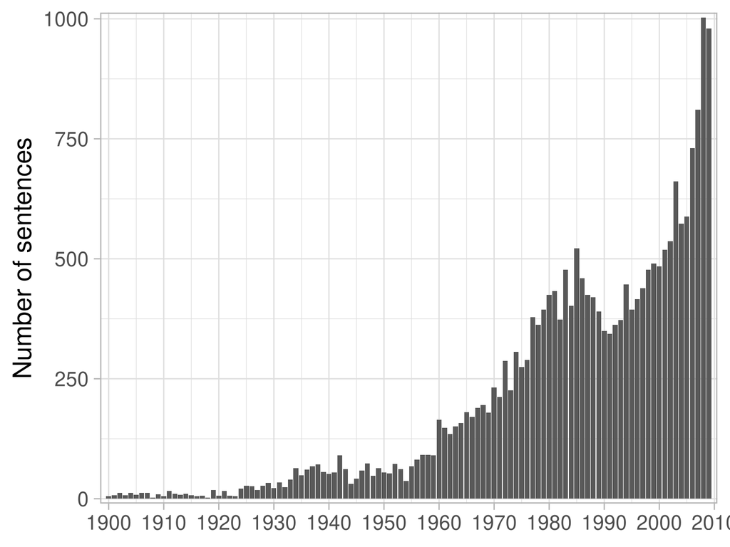

### Closest sentence from ‘rational’ and ‘rationality’ of the backbone community

Sentence

Title

Year

Journal

Authors

Words Similarity

“Some market environments, such as the double auction, are so powerful that they can generate aggregate rationality not only from individual rationality but also from individual irrationality” (Gode and Sunder, 1993, p. 119).

Do institutions promote rationality? An experimental study of the three-door anomaly

2004

Journal of Economic Behavior and Organization

Slembeck T.

0.775

8Maintaining common knowledge of rationality but otherwise leaving beliefs unrestricted yields notions like rationalizability, which implies some restrictions on behavior in first-price auctions or common-value second-price auctions, and duplicates equilibrium in independent- private-value second-price auctions.

[Level-K Auctions: Can a Nonequilibrium Model of Strategic Thinking Explain the Winner’s Curse and Overbidding in Private-Value Auctions?](http://www.jstor.org/stable/4502047)

2007

Econometrica

Vincent P. Crawford, Nagore Iriberri

0.773

We shall say that the first firm’s expectations are “rational” at a point (X, Y) if the predictions the firm makes about the responses of its rival to small (but not necessarily infinitesimal) changes in X represent changes in Y with which the second firm would itself be satisfied (in the face of the given changes in X).

[“Rational” Duopoly Equilibria](http://www.jstor.org/stable/1885485)

1980

The Quarterly Journal of Economics

John Laitner

0.761

Given this possibility, we may underpin the price setting concept by an argument concerning rationality: As the representative firm wants to maximize its profits, it is rational to include all possible actions and to choose the alternative with the highest profit.

[A Reconsideration of the Perfect-Competition Model / Eine Neubetrachtung des Modells der vollkommenen Konkurrenz](http://www.jstor.org/stable/23812267)

1993

Jahrbücher für Nationalökonomie und Statistik / Journal of Economics and Statistics

Helmut Gschwendtner

0.758

In our working paper, Cooper and Fang (2006), we sketch a simple model of bounded rationality where we hypothesise that, when a bidder contemplates her optimal bid, she under-accounts for the impact of an increase in her bid on her expected payoff conditional on winning while she fully accounts for the positive impact of a marginal increase of her bid on her probability of winning.

[Understanding Overbidding in Second Price Auctions: An Experimental Study](http://www.jstor.org/stable/20108875)

2008

The Economic Journal

David J. Cooper, Hanming Fang

0.756

If the threshold level of investment in the buyer’s beliefs satisfies yL*≤ȳ≤yH*, then the strategies above are sequentially rational and beliefs are consistent.

To invest or screen efficiently: A potential conflict in relationships governed by incomplete contracts

2001

International Journal of Industrial Organization

Bac M.

0.734

Clearly, the model that we have described involves =-rationality from the part of the traders and of the auctioneer.

Structural stability implies robustness to bounded rationality

2001

Journal of Economic Theory

Anderlini L.

0.734

Then our definition of rational expectations dictates that if one firm changes its output slightly, it will foresee a response from its rival that the rival will perceive to be profit-maximizing.

[“Rational” Duopoly Equilibria](http://www.jstor.org/stable/1885485)

1980

The Quarterly Journal of Economics

John Laitner

0.726

When the seller is the second mover, either he meets a rational buyer, and his expected utility is larger if he is irrational than if he is rational, or he meets an irrational agent, and his expected utility is larger if he is irrational, iff β<8/13.

Darwinian selection does not eliminate irrational traders

2000

European Economic Review

Biais B.

0.725

1996. describe bidders’ behavior through bounded rationality.

The Seat is right: Bidder heterogeneity in The Price Is Right

2008

Journal of Socio Economics

Baker R.

0.722

Clearly, these beliefs are rational on an equilibrium path where all bidders follow * .

Internet auctions with many traders

2006

Journal of Economic Theory

Peters M.

0.722

In conclusion, under high uncertainty canonical auction theory imputes an implausible hyper-rationality to economic agents.

Governance and game theory: When do franchise auctions induce firms to overbid?

2009

Telecommunications Policy

French R.D.

0.717

At the end of each period, after the realization of z, the fraction of rational sellers increases if the utility of the rational sellers U r s(z) was larger than that of the irrational sellers U i s(z).

Darwinian selection does not eliminate irrational traders

2000

European Economic Review

Biais B.

0.716

Thus, a trader’s virtual valuations are independent of the choice of the trading mechanism, and the continuum of individual rationality constraints are reduced to those for the highest or lowest types that are binding at the optimum.

Optimal Trading Mechanisms with Ex Ante Unidentified Traders

2001

Journal of Economic Theory

Lu H.

0.715

Therefore, this is the price system with the aid of which - under these conditions - management can be “rational” or “optimal”.

[DUAL CONCEPT OF THE ECONOMY IN MARX’S “CAPITAL”](http://www.jstor.org/stable/40727781)

1967

Acta Oeconomica

A. Bródy

0.709

Nevertheless, the rationality of the decision process can only be improved by replacing pricing fictions with appropriate financial mode

Multi-Period Discounted Cash Flow Rate-making Models in Property-Liability Insurance

1990

The Journal of Risk and Insurance

J. David Cummins

0.708

If a potential entrant is sophisticated, then he also has rational expectations.

[Rational Expectations and the Limits of Rationality: An Analysis of Heterogeneity](http://www.jstor.org/stable/1814803)

1985

The American Economic Review

John Haltiwanger, Michael Waldman

0.706

3. When, in extending the classical theory, the assumptions of perfect competition were removed, even the definition of rationality became ambiguous.

[Theories of Decision-Making in Economics and Behavioral Science](http://www.jstor.org/stable/1809901)

1959

The American Economic Review

Herbert A. Simon

0.703

It may therefore be charged in a good many cases with selecting for definitive rationalization a much simpler sort of behavior than occurs in fact, or alternatively with rationalizing observed behavior in terms of an inadequate sample of the variables and environmental factors which condition price making.

[Market Classifications in Modern Price Theory](http://www.jstor.org/stable/1883410)

1942

The Quarterly Journal of Economics

Joe S. Bain

0.702

Moreover, with rational expectations assumed on the part of both firms, this change will not affect each firm’s expectations about the rival’s behavior, namely the values of qj* ( - ) and Eq7 ; i = 1, 2.

[A Common Agency with Incomplete Information](http://www.jstor.org/stable/2601023)

1991

The RAND Journal of Economics

Esther Gal-Or

0.701

### Closest sentences from ‘rational’ and ‘rationality’ of the HDBSCAN cluster

#### Closes sentences 2_2_1900-1919: monopoly, endemann, seldom_perfectly, drawn_wholly, price_fixing (1900-1919)

| Sentence | Title | Year | Journal | Authors | Words Similarity |
| --- | --- | --- | --- | --- | --- |
| For this sort of action, and for this ground of selecting the price-regulated commodities, there was a sound basis in economic principle. | [Price-Fixing as Seen by a Price-Fixer](http://www.jstor.org/stable/1884733) | 1919 | The Quarterly Journal of Economics | F. W. Taussig | 0.603 |
| It is believed that the result of this principle, if worked to its logical conclusion, will be toward the restoration of those conditions in which the old common-law principle of competition can exerc… | [Administrative Supervision of Railways under the Twentieth Section of the Act to Regulate Commerce](http://www.jstor.org/stable/1883738) | 1908 | The Quarterly Journal of Economics | Henry C. Adams | 0.602 |
| To the objection that markets are seldom perfectly adjusted, the reply may be made that price-fixing boards are seldom omniscient, and those that are omniscient are seldom perfectly free from bias, pr… | [The Possibilities of Price Fixing in Time of Peace](http://www.jstor.org/stable/1814003) | 1919 | The American Economic Review | T. N. Carver | 0.600 |
| One reason for this conclusion is that the idea of necessity is one of 1 It may be worth while to note that any great refinement of analysis would surely deal with various important interrelations of … | [Joint Costs With Especial Regard to Railways](http://www.jstor.org/stable/1884994) | 1916 | The Quarterly Journal of Economics | Lewis H. Haney | 0.598 |
| Endemann pOilltS out that this circumstance gave the foreign merchant a great advantage over the local trader and even opened the door to speculative gain.4 But it was a logical consequence of the doc… | The Theory of Value before Adam Smith | 1901 | Publications of the American Economic Association | Hannah Robie Sewall | 0.593 |
| And even the removal of that surplus of value by competition would under these circumstances be effectually opposed by the same motive that produced it, without the necessity of the appearance or of t… | [The Relation of Abstinence to Interest](http://www.jstor.org/stable/1882781) | 1903 | The Quarterly Journal of Economics | T. N. Carver | 0.593 |
| The notion of a normal price derived from such analysis still survives, but it is not easy to be certain that the notion plays any very significant part in our actual thinking. | [The Content of the Value Concept](http://www.jstor.org/stable/1884043) | 1917 | The Quarterly Journal of Economics | Abbott Payson Usher | 0.592 |
| He does not think, however, that price fixing on ” the basis described is the same as that which would obtain if normal forces were working under normal conditions.” | [Price Fixing and the Theory of Profit](http://www.jstor.org/stable/1884491) | 1919 | The Quarterly Journal of Economics | Kemper Simpson | 0.586 |
| yet we may contend that in the actual world of modern business friction and monopoly play a part which the common assumption of individual liberty discovered at the basis of our familiar reasonings is… | [The Study of Economic History](http://www.jstor.org/stable/2221137) | 1906 | The Economic Journal | L. L. Price | 0.583 |
| A rational policy toward monopoly should endeavor to see to it that the two principles oppose each other with somewhat equal forces. | [Monopoly or Competition as the Basis of a Government Trust Policy](http://www.jstor.org/stable/1884961) | 1915 | The Quarterly Journal of Economics | Robert Liefmann | 0.579 |

#### Closes sentences 2_8_1900-1919: tariff, free_trade, fiscal_controversy, protectionist, duties (1900-1919)

| Sentence | Title | Year | Journal | Authors | Words Similarity |
| --- | --- | --- | --- | --- | --- |
| Not only can each specific condemnation of some restriction upon trade be offset by a specific commendation of some other restriction, but, what is far more important, it is clear also that to represe… | [Petty’s Place in the History of Economic Theory](http://www.jstor.org/stable/1882563) | 1900 | The Quarterly Journal of Economics | Charles H. Hull | 0.625 |
| The declaration that an argument was ” complete ” would in any case seem to belong to the unqualified assertions of the political platform rather than to the measured utterances of the scientific stud… | [Economic Theory and Fiscal Policy](http://www.jstor.org/stable/2221360) | 1904 | The Economic Journal | L. L. Price | 0.611 |
| The advocates of the other remedy pointed out that the duties on this class of good’s were already so lhligh as to be almost prohibitory, and that loreign importations had nearly come to a standstill.… | The American Silk Industry and the Tariff | 1910 | American Economic Association Quarterly | Frank R. Mason | 0.599 |
| It is in this general reasoning that the ordinary free-trader shows his common sense; it is here that the triumphs of a Bastiat are won. | [Disputed Points in the Theory of International Trade](http://www.jstor.org/stable/2957423) | 1901 | The Economic Journal | F. Y. Edgeworth | 0.597 |
| (In answer to this argument, it might be said that if it were the intention of the framers of the last national Republican platform to extend protection to all possible commodities there is nothing to… | [“Costs” and the Tariff Board](http://www.jstor.org/stable/1822102) | 1912 | Journal of Political Economy | L. D. H. Weld | 0.592 |
| The dual aim of rendering the tariff more simple and effective for its purpose of raising revenue, arnd of purging it of Protectionist suspicion, may indeed have been present to their minds; but they … | [Economic Theory and Fiscal Policy](http://www.jstor.org/stable/2221360) | 1904 | The Economic Journal | L. L. Price | 0.589 |
| Perhaps no experience, however prolonged, would be adequate; as in the argument for Free Trade, we must depend largely upon general reasoning.2 The suggested analogy with Protection will perhaps be ac… | [Recent Schemes for Rating Urban Land Values](http://www.jstor.org/stable/2221141) | 1906 | The Economic Journal | F. Y. Edgeworth | 0.583 |
| It was reasoned with force that, if the administration really felt the cogency of the German tariff argument, it coluld well shoiwr this feeling in a, practical way by altering the objectionable featu… | [Reciprocity with Germany](http://www.jstor.org/stable/1819492) | 1907 | Journal of Political Economy | H. Parker Willis | 0.581 |
| No dispassionate observer can question that the tariff issue was the main problem presented to the electorate, not only in the congres? | [The Tariff of 1913: I](http://www.jstor.org/stable/1821090) | 1914 | Journal of Political Economy | H. Parker Willis | 0.574 |
| e., free trade with foreign countries-means the acceptance of the similar easy and simple argument in favour of dogmatic protection. | [The Economics of Imperialism](http://www.jstor.org/stable/2220913) | 1910 | The Economic Journal | J. Shield Nicholson | 0.570 |

#### Closes sentences 2_3_1920-1929: prices, price_level, price, remained_equal, producers_actions (1920-1929)

| Sentence | Title | Year | Journal | Authors | Words Similarity |
| --- | --- | --- | --- | --- | --- |
| That a theory in conflict with these facts found such ready acceptance may be explained by the fascination of the rationality of the system of prices, which the general law of variable proportion woul… | [Economic Theory](http://www.jstor.org/stable/1814854) | 1926 | The American Economic Review | G. A. Kleene, Richard S. Meriam, Sumner H. Slichter, Raymond T. Bye, A. B. Wolfe, John P. Frey | 0.693 |
| They are ofttimes necessitated by the inadequacy of price to serve as a basis of rational conduct. | [An Extension of Value Theory](http://www.jstor.org/stable/1883479) | 1922 | The Quarterly Journal of Economics | David Friday | 0.679 |
| Despite the danger of mistaken judgment and the occurrence of abuses, this is potentially both more logical and more effective than price fixing in securing the real end in view, viz., to use for war … | [Interest Theory and Price Movements](http://www.jstor.org/stable/1809560) | 1927 | The American Economic Review | Frank A. Fetter | 0.618 |
| This view of demand does not require us to assume an excessive amount of calculation in human affairs. | [Cost and its Relation to Value](http://www.jstor.org/stable/1882533) | 1928 | The Quarterly Journal of Economics | A. E. Monroe | 0.607 |
| But no critic, bent upon giving, due weight to all parts of the evidence and not seeking in detached expressions and incidents evidence for a foregone conclusion, can find in Fisher any positive proof… | [Price Economics Versus Welfare Economics: Contemporary Opinion](http://www.jstor.org/stable/1803336) | 1920 | The American Economic Review | Frank A. Fetter | 0.606 |
| to admit that the relation of power dictates the price, independently of the action of utility. | ON THE COEFFICIENTS OF PRODUCTION | 1929 | Kyoto University Economic Review | Yasuma Takata | 0.605 |
| upon a more complete knowledge of the essential facts and designed to give more stability to production. | [Research Problems Involved in Providing Continuous Economic Information to Farmers](http://www.jstor.org/stable/1230498) | 1929 | Journal of Farm Economics | Jesse W. Tapp | 0.604 |
| SUMMARY The current doctrine stated, 394.- In fact, demand often does not respond to price in the way assumed, 396. | [Is Market Price Determinate?](http://www.jstor.org/stable/1884093) | 1921 | The Quarterly Journal of Economics | F. W. Taussig | 0.601 |
| To establish a price which, on other grounds, might be called a just price, but which would induce buyers to buy more than sellers were induced to sell, or sellers to sell more than buyers were induce… | [Some Probable Results of a Balanced Industrial System](http://www.jstor.org/stable/1811886) | 1920 | The American Economic Review | T. N. Carver | 0.601 |
| That the fixing of the amount of going value is almost entirely speculative and arbitrary is concretely shown by the conclusions of one of the ablest minds in the field of regulation. | [Some Aspects of the Going-Value Concept in Utility Valuation](http://www.jstor.org/stable/3138651) | 1925 | The Journal of Land & Public Utility Economics | Martin G. Glaeser | 0.597 |

#### Closes sentences 2_12_1930-1939: price, prices, productive_price, demand_curve, rigidity (1930-1939)

| Sentence | Title | Year | Journal | Authors | Words Similarity |
| --- | --- | --- | --- | --- | --- |
| In addition to this “rational” selection of rigid prices there are certain influences contributing to price rigidity which are not a part of any desire to maximize profits either in the short or long … | [Monopoly Power and Price Rigidities](http://www.jstor.org/stable/1882612) | 1936 | The Quarterly Journal of Economics | J. K. Galbraith | 0.659 |
| Thus, we come to somewhat different conclusions as to the relation of two goods according as we rely upon the “price-demand” criterion, or reason in terms of the influences which seem to account for t… | [The Relation of Commodities in Demand](http://www.jstor.org/stable/1803729) | 1938 | The American Economic Review | E. E. Lewis | 0.639 |
| There may be practical reasons for departing from the pure principles of equating price to marginal social costindeed, these are certain to arise, but these will arise in the practical work of adminis… | [Theory and Practice in Socialist Economics](http://www.jstor.org/stable/2967541) | 1938 | The Review of Economic Studies | A. P. Lerner | 0.626 |
| simplicity and perhaps defensible for the purposes of abstract price theory frankly stated in terms of the assumption of economic rationality. | [Professor Fisher’s Interest Theory: A Case in Point](http://www.jstor.org/stable/1822329) | 1931 | Journal of Political Economy | Frank H. Knight | 0.622 |
| That demand should remain low or decline when a price is arbitrarily fixed at an artificially high level is easily understood if we can assume that people in general tend to act in a rational manner. | [Direct Price Fixing](http://www.jstor.org/stable/1052989) | 1936 | Southern Economic Journal | Jules Backman | 0.617 |
| The reasoning behind this view is sometimes no more elaborate than an assumption that prices must change with changing conditions of demand and supply, and that the penalty of price resistance to such… | [Public Utility Prices and the Business Cycle: A Study in the Theory of Price Rigidity](http://www.jstor.org/stable/1928401) | 1939 | The Review of Economics and Statistics | John D. Sumner | 0.616 |
| No more is suggested than what would unquestionably find general acceptance; namely, that neither demand nor supply in a market is amenable to willful or arbitrary control. | [Trustification and Economic Theory](http://www.jstor.org/stable/1802974) | 1931 | The American Economic Review | Myron W. Watkins | 0.610 |
| A theory of prices which will be competent to explain why any particular combination is adopted must at least abandon the | MARX AS A PURE ECONOMIST | 1939 | Economic History | Henry Smith | 0.604 |
| or is it not conceivable that the thing which they all have in mind is that condition affecting the possibilities of production which cannot be expressed in terms of a substantive quantity? | [The Mythology of Capital](http://www.jstor.org/stable/1885022) | 1936 | The Quarterly Journal of Economics | F. A. v. Hayek | 0.604 |
| Without inquiring into the reasons for this belief or its soundness, we should note that such price rigidities must affect either the allocation or degree of utilization of economic resources. | [Monopolistic Competition and Public Policy](http://www.jstor.org/stable/1807766) | 1936 | The American Economic Review | Donald H. Wallace | 0.600 |

#### Closes sentences 2_8_1930-1939: monopoly, competition, pure_competition, perfect_competition, arranging_actual (1930-1939)

| Sentence | Title | Year | Journal | Authors | Words Similarity |
| --- | --- | --- | --- | --- | --- |
| But unless we go so far as to assume that a system of free competition fully does away with irrationality and inertia, we shall have to admit that flexibility and free competition are not the same thi… | [Money and Production](http://www.jstor.org/stable/1822998) | 1935 | Journal of Political Economy | Walter Egle | 0.622 |
| To reproduce the conditions of perfect competition ” is not the correct battle-cry for this type of ” rationalisation,” unless perfect competition is the rule over the main part of the field of indust… | [Some Notes on Ideal Output](http://www.jstor.org/stable/2224577) | 1935 | The Economic Journal | R. F. Kahn | 0.616 |
| He sums up his conclusion in the words-“We appear to search in vain for any really ethical basis of approval for competition as a basis for an ideal type of human relations, or as a motive to action. | [The Ethics of Competition](http://www.jstor.org/stable/136806) | 1937 | The Canadian Journal of Economics and Political Science / Revue canadienne d’Economique et de Science politique | E. J. Urwick | 0.581 |
| Reference to the tendency of competition to “control” such matters is frequent, but generally in the form of arguments as to why it works “imperfectly.” | [The Newer Economics and the Control of Economic Activity](http://www.jstor.org/stable/1822849) | 1932 | Journal of Political Economy | Frank H. Knight | 0.580 |
| But unless one postulates the impossibility of realizing “healthfulness” under a competitive system of individual enterprise, it is not certain that this conclusion follows. | [Statistical Light on Profits, as Analyzed in Recent Literature](http://www.jstor.org/stable/1885252) | 1930 | The Quarterly Journal of Economics | Ralph C. Epstein | 0.576 |
| But it is important to remember that such an assumption is something quite different and logically much less satisfactory in the case of imperfect competition than in the case of perfect competition. | [Mrs. Robinson’s “Economics of Imperfect Competition”](http://www.jstor.org/stable/2548808) | 1934 | Economica | Nicholas Kaldor | 0.573 |
| There is, of course, no more reason to expect that the extent of variation which comes into existence is automatically restricted by competition to the ideal amount, than there is to suppose that comp… | [Monopolistic Competition and Public Policy](http://www.jstor.org/stable/1807766) | 1936 | The American Economic Review | Donald H. Wallace | 0.572 |
| But this line of approach, although it has conveniences, and brings discrimination into a very satisfactory relation with general monopoly theory, is not that which has traditionally been adopted. | [Annual Survey of Economic Theory: The Theory of Monopoly](http://www.jstor.org/stable/1907343) | 1935 | Econometrica | J. R. Hicks | 0.572 |
| but actually undesirable and unthinkable, that living should not to a large extent take the form of contest relations and be impelled by the competitive or emulative interest. | [Ethics and Economic Reform. III. Christianity](http://www.jstor.org/stable/2548882) | 1939 | Economica | Frank H. Knight | 0.572 |
| The old principle gave way to the new when it became clear that unless some rather unusual technical conditions prevailed 1 these three conditions were mutually incompatible, that the first two were m… | [Theory and Practice in Socialist Economics](http://www.jstor.org/stable/2967541) | 1938 | The Review of Economic Studies | A. P. Lerner | 0.568 |

#### Closes sentences 2_6_1940-1949: price_control, prices, price, pricing, price_policy (1940-1949)

| Sentence | Title | Year | Journal | Authors | Words Similarity |
| --- | --- | --- | --- | --- | --- |
| It may therefore be charged in a good many cases with selecting for definitive rationalization a much simpler sort of behavior than occurs in fact, or alternatively with rationalizing observed behavio… | [Market Classifications in Modern Price Theory](http://www.jstor.org/stable/1883410) | 1942 | The Quarterly Journal of Economics | Joe S. Bain | 0.702 |
| This may provide some basis from which rationalization may proceed, but again it is not connected with price control. | [Reflections on the War-Time Control of Food Prices](http://www.jstor.org/stable/2663436) | 1947 | Oxford Economic Papers | Henry Smith | 0.679 |
| In other words, prices will provide a basis for rational accounting only if they are such that at the ruling prices anyone can always sell as much or buy as much as he wishes, or that anyone should be… | [Socialist Calculation: The Competitive `Solution’](http://www.jstor.org/stable/2548692) | 1940 | Economica | F. A. v. Hayek | 0.660 |
| For it implies either (i) that all prices are independent of the quantity of capital or (2) that the individuals in this society make specific systematic errors which somehow do not disturb the comple… | [Interest and Employment](http://www.jstor.org/stable/1825088) | 1946 | Journal of Political Economy | M. W. Reder | 0.641 |
| It is simply held that the pricing mechanism is so complex and so necessary to the rational use of resources that any tinkering with it is likely to lead to further maladjustments. | [An Honorable Mention Paper: A Price Policy for Agriculture, Consistent with Economic Progress, That Will Promote Adequate and More Stable Income from Farming](http://www.jstor.org/stable/1232443) | 1945 | Journal of Farm Economics | Willard W. Cochrane | 0.634 |
| Unless this determination is translated into action and unless this action is taken by those influential in determining prices in a market, it will be of little value. | [Important Considerations in Determining a Fair Price for Fluid Milk](http://www.jstor.org/stable/1232313) | 1942 | Journal of Farm Economics | Alan MacLeod | 0.629 |
| But the actual determination of prices, etc., under such conditions of indeterminacy may depend upon non-economic factors like bargaining power, politics, etc. | [Multiple Regression for Systems of Equations](http://www.jstor.org/stable/1905702) | 1946 | Econometrica | Gerhard Tintner | 0.627 |
| … even if it were possible to explain the facts of demand without it [i.e., without cardinal utility], the procedure would be interesting only as a stunt.” | [Professor Knight and the Theory of Demand](http://www.jstor.org/stable/1825792) | 1946 | Journal of Political Economy | Robert L. Bishop | 0.619 |
| It seems preferable, therefore, to interpret the naturalness of price in terms of the usual and ordinary course of economic activity rather than to give it a special meaning in terms of the system of … | [Adam Smith’s Empiricism and the Law of Nature](http://www.jstor.org/stable/1825511) | 1940 | Journal of Political Economy | Henry J. Bittermann | 0.610 |
| II The proposition to disregard changes of relative prices is in contrast with the fact that they are of the very essence of economic life, indeed some of its purpose. | [The Problem of Capital Accumulation](http://www.jstor.org/stable/1816594) | 1949 | The American Economic Review | Ernest H. Stern | 0.607 |
| The existence of this notion in people’s consciousness does not presuppose completely rigid prices. | [Capital Accumulation, Employment and Price Rigidity](http://www.jstor.org/stable/2967464) | 1941 | The Review of Economic Studies | T. de Scitovszky | 0.607 |
| Occasions do occur when reliance cannot be placed upon a market system to achieve the ends deemed imperative, however that price system may be influenced and shaped by accou-nting and fiscal procedure… | [The Optimal Utilization of National Resources](http://www.jstor.org/stable/1907303) | 1949 | Econometrica | J. Stafford | 0.607 |

#### Closes sentences 2_5_1940-1949: monopoly, competition, antitrust, pure_competition, perfect_competition (1940-1949)

| Sentence | Title | Year | Journal | Authors | Words Similarity |
| --- | --- | --- | --- | --- | --- |
| There had always been, as mentioned above, this other doctrine in the decisions where competition was, in fact, not free and equal but was more or less “monopolistic” or “unfair,” namely the doctrine … | [Legislative and Administrative Reasoning in Economics](http://www.jstor.org/stable/1231878) | 1942 | Journal of Farm Economics | John R. Commons | 0.623 |
| But monopoly and governmental action and “sometimes natural causes” may keep the market price above the natural.124 While monopoly and “police” might be regarded as violations of natural liberty, “nat… | [Adam Smith’s Empiricism and the Law of Nature](http://www.jstor.org/stable/1825511) | 1940 | Journal of Political Economy | Henry J. Bittermann | 0.616 |
| Decisions that mere size is no offense may be placed side by side with decisions in which the possession of monopoly power is regarded as decisive, whether or not that power has yet been unreasonably … | [An Appraisal of the Antitrust Laws](http://www.jstor.org/stable/1818204) | 1946 | The American Economic Review | Corwin D. Edwards | 0.604 |
| It is contrary to some very important aspects of the theories of imperfect competition: imperfect knowledge and consumer irrationality. | [The Rehabilitation of Pure Competition](http://www.jstor.org/stable/1885783) | 1947 | The Quarterly Journal of Economics | Alfred Nicols | 0.597 |
| one realizes that market leaders do not usually rely upon rationality for their exercise of monopoly power. | [Monopolistic Competition Theory and Public Price Policy](http://www.jstor.org/stable/1816756) | 1942 | The American Economic Review | Vernon A. Mund | 0.596 |
| However, this type of reasoning relates to the problem of protectionism in general. | [The Commercial Policy Implications of the Fund and Bank](http://www.jstor.org/stable/1818452) | 1945 | The American Economic Review | William Fellner | 0.587 |
| But even in that case we are simply told that ” The production of [the] commodity really partakes in a great measure of the nature of a monopoly; and its price is likely to be so much influenced by th… | [The Place of Marshall’s Principles in the Development of Economic Theory](http://www.jstor.org/stable/2226235) | 1942 | The Economic Journal | G. F. Shove | 0.583 |
| But surely if this almost utopian degree of international cooperation were to be attained, it would be just as easy to follow a more rational criterion of trade policy than the essentially restrictive… | [Professor Frisch on Discrimination and Multilateral Trade](http://www.jstor.org/stable/1927368) | 1948 | The Review of Economics and Statistics | Randall Hinshaw | 0.582 |
| The question is whether this process, which admittedly does not always end in the abandonment of competition, can or cannot be played upon by the mind with any success without abandoning the theory of… | [Technology and Size](http://www.jstor.org/stable/1910487) | 1948 | The American Economic Review | John M. Blair | 0.581 |
| Thus the problem of monopoly proves to be nothing less than the problem of preserving rugged individualism at its highest. | [The Futility of Trust-Busting](http://www.jstor.org/stable/1910516) | 1948 | The American Economic Review | John Ise | 0.581 |

#### Closes sentences 2_8_1950-1959: pricing, price, prices, cost_pricing, price_mechanism (1950-1959)

| Sentence | Title | Year | Journal | Authors | Words Similarity |
| --- | --- | --- | --- | --- | --- |
| In this way, we are told, a rational price policy would become possible. ” | [Full Employment in Retrospect](http://www.jstor.org/stable/2226524) | 1952 | The Economic Journal | D. T. Jack | 0.688 |
| Mr. Farrell, if I understand him right, goes much further than I would in the direction of saying that the pricing- rules describe generally-and not only in particular cases-the most rational behaviou… | [The Pricing of Manufactured Products and the Case Against Imperfect Competition: A Rejoinder](http://www.jstor.org/stable/2226969) | 1951 | The Economic Journal | Austin Robinson | 0.671 |
| If it is possible to work out anything like a rational theory of the price of living, we must take account of the fact that in an ordinary market quantities will change when prices change-in particula… | [Some Basic Principles of Price of Living Measurements: A Survey Article](http://www.jstor.org/stable/1907434) | 1954 | Econometrica | Ragnar Frisch | 0.655 |
| First, it is not apprehended what a rational price, upon which output should be based, might be. | [Changing Economic Thought in Poland](http://www.jstor.org/stable/2661899) | 1957 | Oxford Economic Papers | P. J. D. Wiles | 0.652 |
| The two phases will only be complete when we have an account of price-making which is simultaneously rational and true to the facts. | [The Pricing of Manufactured Products and the Case Against Imperfect Competition: A Rejoinder](http://www.jstor.org/stable/2226969) | 1951 | The Economic Journal | Austin Robinson | 0.649 |
| to be built up to bring some semblance of order and meaning to the price mechanism in the last few years does not augur well for the establishment of a truly rational system outside the pale of supply… | [Price-setting Problems in the Polish Economy](http://www.jstor.org/stable/1824805) | 1957 | Journal of Political Economy | John Michael Montias | 0.628 |
| Nor refuse - on principle, not budget - to appraise the consistency, adequacy, or necessity of whatever input prices, worker exertions, financial manipulations, product durabilities, demand fragmentat… | [A Critique of Concepts of Workable Competition](http://www.jstor.org/stable/1882232) | 1958 | The Quarterly Journal of Economics | Stephen H. Sosnick | 0.623 |
| By a line of reasoning that may also have some interest in itself, one can disprove this possibility for what might appear at first sight to be the most natural way of defining the operation of such a… | [Assignment Problems and the Location of Economic Activities](http://www.jstor.org/stable/1907742) | 1957 | Econometrica | Tjalling C. Koopmans, Martin Beckmann | 0.615 |
| Evidently the important consideration is not what the firm which wishes to raise prices can supply, but what the others can supply.” | [Competition of the Few Among the Many](http://www.jstor.org/stable/1884228) | 1956 | The Quarterly Journal of Economics | Willard D. Arant | 0.611 |
| But if a suggested principle of pricing would affect economic magnitudes other than the conditions of choice, then it becomes necessary to establish further policy criteria concerned with these other … | [The Theory of Public Utility Price–An Empty Box](http://www.jstor.org/stable/2662021) | 1957 | Oxford Economic Papers | J. Wiseman | 0.610 |
| But whether it is consistent with rational conduct or not, there is no doubt that business men believe that demand functions do behave in this peculiar manner, and there is no need for us here to go b… | [The Economic Aspects of Advertising](http://www.jstor.org/stable/2296103) | 1950 | The Review of Economic Studies | Nicholas Kaldor | 0.610 |

#### Closes sentences 2_7_1950-1959: monopoly, competition, workable_competition, perfect_competition, pure_competition (1950-1959)

Sentence

Title

Year

Journal

Authors

Words Similarity

3. When, in extending the classical theory, the assumptions of perfect competition were removed, even the definition of rationality became ambiguous.

[Theories of Decision-Making in Economics and Behavioral Science](http://www.jstor.org/stable/1809901)

1959

The American Economic Review

Herbert A. Simon

0.703

But when we refuse to employ a presumption for competition, we are not therefore logically bound to be indifferent to the implications of a policy for the competitive process.

[Policy Analysis](http://www.jstor.org/stable/1809767)

1958

The American Economic Review

Charles E. Lindblom

0.646

To use monopoly power rationally is not to forego it.

[The Cellophane Case and the New Competition](http://www.jstor.org/stable/1811582)

1955

The American Economic Review

George W. Stocking, Willard F. Mueller

0.639

But whether his view of competition as the process of “creative destruction” could be made to yield principles applicable by government agencies and the courts in pursuit of a “rational” as opposed to a “vindictive” anti-monopoly policy is a different matter.

[Schumpeter on Monopoly and the Large Firm](http://www.jstor.org/stable/1925876)

1951

The Review of Economics and Statistics

Edward S. Mason

0.633

Hence, the decision to include oligopolistic rationality among monopoly practices envisages a norm of economic behavior of a far higher order of competition than is consistent with the public policy to be inferred from governmental action over the past one and half decades.

[Public Policy and Monopoly: A Dilemma in Remedial Action](http://www.jstor.org/stable/1053580)

1950

Southern Economic Journal

Jesse W. Markham

0.621

But if one deems it profitable to argue on so general and yet so limited a basis (and I do not), it is to be observed that no reconciliation with the conventional theory of monopoly is necessary.

[The Economist Plays with Blocs](http://www.jstor.org/stable/1818318)

1954

The American Economic Review

George J. Stigler

0.596

Hence, should all dominant firms accept the implications of the recent Tobacco decision at their face value, there would be no reason to conclude a priori whether prices in markets dominated by a particular firm would henceforth be more or less flexible, or would more closely approximate prices which one would expect under more competitive conditions.

[The Nature and Significance of Price Leadership](http://www.jstor.org/stable/1809090)

1951

The American Economic Review

Jesse W. Markham

0.588

It is, of course, questionable whether we approach closely that precise allocation of resources which characterizes behavior consistent with perfect competition.

[Competition and Countervailing Power: Their Roles in the American Economy](http://www.jstor.org/stable/1818319)

1954

The American Economic Review

John Perry Miller

0.585

For example, there is no reason to believe that a situation in which there is the same degree of monopoly in all industries will necessarily be in any sense superior to a situation in which the degree of monopoly varies as between industries.

[The General Theory of Second Best](http://www.jstor.org/stable/2296233)

1956

The Review of Economic Studies

R. G. Lipsey, Kelvin Lancaster

0.583

The underlying assumption was that monopoly might or might not have socially adverse effects and that each case should therefore be decided strictly on its merits.

[British Monopoly Policy 1944-56](http://www.jstor.org/stable/724880)

1958

The Journal of Law & Economics

John Jewkes

0.581

There can be little doubt that the essence of the monopoly argument is political, but it is not necessarily the worse for that. ”

[The Iron and Steel Act, 1949](http://www.jstor.org/stable/2227057)

1950

The Economic Journal

S. J. Langley

0.581

On the one hand, we may make specific assumptions quite arbitrarily, and with scant regard for their plausibility, and arrive at specific conclusions which, however, will accord with the facts, if at all, only by chance; this method is typified by the imperfect competition theories.

[Deductive Systems and Empirical Generalizations in the Theory of the Firm](http://www.jstor.org/stable/2661856)

1952

Oxford Economic Papers

M. J. Farrell

0.581

#### Closes sentences 2_14_1960-1969: prices, price, pricing, monopoly, price_discrimination (1960-1969)

| Sentence | Title | Year | Journal | Authors | Words Similarity |
| --- | --- | --- | --- | --- | --- |
| Therefore, this is the price system with the aid of which - under these conditions - management can be “rational” or “optimal”. | [DUAL CONCEPT OF THE ECONOMY IN MARX’S “CAPITAL”](http://www.jstor.org/stable/40727781) | 1967 | Acta Oeconomica | A. Bródy | 0.709 |
| In either event, the price decisions should be put on a rational basis. | [Economic and Social Factors Affecting the Development of Smallholder Agriculture in Eastern Nigeria](http://www.jstor.org/stable/1152246) | 1965 | Economic Development and Cultural Change | C. Davis Fogg | 0.698 |
| 2 demand curves result not so much from rational behavior per se as from a general principle which includes a wide class of irrational behavior as well. | [Irrational Behavior and Economic Theory](http://www.jstor.org/stable/1827018) | 1962 | Journal of Political Economy | Gary S. Becker | 0.697 |
| Second, as far as rational price policy is concerned, based o0l the recognition of illusory profits, this usually presents political difficulties. | [Profit Illusion and Policy-Making in an Inflationary Economy](http://www.jstor.org/stable/2662385) | 1965 | Oxford Economic Papers | Werner Baer, Mario Henrique Simonsen | 0.684 |
| [in that] there is no place for a rational decision with respect to prices as there is with respect to quantities.” | [Economic Theory and the Meaning of Competition](http://www.jstor.org/stable/1879604) | 1968 | The Quarterly Journal of Economics | Paul J. McNulty | 0.680 |
| It requires that they obey a rational course of action by positioning their commodity claims in the light of existing price information. | [Pricing below Cost in the Soybean Processing Industry](http://www.jstor.org/stable/1236315) | 1966 | Journal of Farm Economics | Allen B. Paul | 0.662 |
| The assumption of a rational price structure begs the question, as critics have pointed out, of whether such a structure can actually be constructed in a Soviet-type economy, quite aside from its conc… | [Cost-Price Relationships and the Location of Soviet Industry: A Case Study](http://www.jstor.org/stable/2556225) | 1968 | International Economic Review | W. Donald Bowles | 0.662 |
| But it can be easily shown that, without the explicit introduction of rationality, the intersection point of the two curves bears no particular significance; that without the rationality assumption we… | [Rational Action and Economic Theory](http://www.jstor.org/stable/1861734) | 1962 | Journal of Political Economy | Israel M. Kirzner | 0.661 |
| Hence, it can not be deduced from the structure of the market that prices and profits are compelled, as it were, to be reasonable; it has to be decided whether or not a price of so many shillings, a p… | [The Restrictive Practices Court and Reasonable Prices](http://www.jstor.org/stable/2097717) | 1964 | The Journal of Industrial Economics | James P. Cairns | 0.657 |
| For some of these functions, for example control of managerial behavior, rational prices may not need to be scarcity prices. | [The Soviet Price System](http://www.jstor.org/stable/1823478) | 1962 | The American Economic Review | Morris Bornstein | 0.655 |

#### Closes sentences 2_11_1970-1979: prices, price, pricing, price_level, factor_price (1970-1979)

| Sentence | Title | Year | Journal | Authors | Words Similarity |
| --- | --- | --- | --- | --- | --- |
| A system of rational pricing would differ from the current situation in two important aspects. | [The Allocation of Energy Resources](http://www.jstor.org/stable/2534202) | 1973 | Brookings Papers on Economic Activity | William D. Nordhaus, Hendrik Houthakker, Robert Solow | 0.696 |
| Macro-calculations must be in rational prices, but he expects externalities, distributive and purely political considerations to be uppermost. | Economic factors in the democratization of socialism and the socialization of capitalism | 1977 | Journal of Comparative Economics | Gomulka S. | 0.683 |
| It seems probable that as the endeavor to improve the rationality of the price system collides with the barrier of central priorities, the untenability of the latter concept will increasingly be expos… | [The Interrelation between Central Priorities and Individual Preferences in a Socialist Planned Economy](http://www.jstor.org/stable/4379466) | 1974 | Eastern European Economics | Josef Adamíček, Marian Sling | 0.679 |
| rational manner, namely, to ensure that prices should be an exacting element in the enterprise environment. | [A Systems Approach to Management of a Socialist Economy](http://www.jstor.org/stable/4379490) | 1975 | Eastern European Economics | Stanislav Vácha, Marian Sling | 0.668 |
| A second reason for considering an alternative to (6) is to determine if deviations from rationality imply significantly different behavior of actual price over time. | [Rational Expectations and the Cobweb Theory](http://www.jstor.org/stable/1830693) | 1970 | Journal of Political Economy | B. Peter Pashigian | 0.665 |
| This type of pricing also favors the more rational use of productive capital. | [Theoretical Basis for the Reform of Sale Prices in Socialist Countries](http://www.jstor.org/stable/4379419) | 1970 | Eastern European Economics | Wladyslaw Sztyber, Jan Solecki | 0.662 |
| To him, the use of factor prices calls for the making of tenuous assumptions such as individual rationality (in cost minimization) and market perfection. | [Technological Change and Relative Factor Shares in Indian Agriculture: An Empirical Analysis: Comment](http://www.jstor.org/stable/1239634) | 1977 | American Journal of Agricultural Economics | Henry Y. Wan, Jr. | 0.658 |
| Indeed to the extent that the idea of rationality has any place in demand analysis, it would seem to be contradicted by non-homogeneity. | [The Analysis of Consumer Demand in the United Kingdom, 1900-1970](http://www.jstor.org/stable/1911983) | 1974 | Econometrica | Angus S. Deaton | 0.650 |
| Another example is the problem of rational pricing for governmental services. | [Value Implications of Economic Theory](http://www.jstor.org/stable/25602889) | 1973 | The American Economist | Murray N. Rothbard | 0.649 |
| It is not rational, however, for an individual firm to behave as a price-taker i.e. | [Excess Burden and the Voluntary Theory of Public Finance: The Case of Intermediate Public Goods](http://www.jstor.org/stable/2553592) | 1975 | Economica | Takashi Negishi | 0.647 |

#### Closes sentences 2_11_1980-1989: price, prices, price_level, market_clearing, pricing (1980-1989)

| Sentence | Title | Year | Journal | Authors | Words Similarity |
| --- | --- | --- | --- | --- | --- |
| We shall say that the first firm’s expectations are “rational” at a point (X, Y) if the predictions the firm makes about the responses of its rival to small (but not necessarily infinitesimal) changes… | [“Rational” Duopoly Equilibria](http://www.jstor.org/stable/1885485) | 1980 | The Quarterly Journal of Economics | John Laitner | 0.761 |
| Then our definition of rational expectations dictates that if one firm changes its output slightly, it will foresee a response from its rival that the rival will perceive to be profit-maximizing. | [“Rational” Duopoly Equilibria](http://www.jstor.org/stable/1885485) | 1980 | The Quarterly Journal of Economics | John Laitner | 0.726 |
| If a potential entrant is sophisticated, then he also has rational expectations. | [Rational Expectations and the Limits of Rationality: An Analysis of Heterogeneity](http://www.jstor.org/stable/1814803) | 1985 | The American Economic Review | John Haltiwanger, Michael Waldman | 0.706 |
| These less restricted specifications could arise either if the model of firm behavior was true and the expectations were not computed rationally or if the expectations were computed rationally but fir… | [Sticky Prices in the United States](http://www.jstor.org/stable/1830944) | 1982 | Journal of Political Economy | Julio J. Rotemberg | 0.695 |
| It is only under rigid assumptions of market structure and consumer demand that our firm is acting rationally in ignoring the effects of its controls at time t on the demand curve it faces at some oth… | [Inventory Investment and the Theory of the Firm](http://www.jstor.org/stable/1808585) | 1982 | The American Economic Review | Lanny Arvan, Leon N. Moses | 0.688 |
| Let us, however, assume that the price relations transferred from the world markets to our economy would introduce some degree of rationality. | [Logic and Principles of the System: Discussion: The Second Stage of the Reform](http://www.jstor.org/stable/4379779) | 1988 | Eastern European Economics | Stanisław Albinowski, Teresa Fallenbuchl | 0.683 |
| Sequential rationality in the absence of commitment forces the firm to choose b2(A*) to maximize E[y2 - 2(Y2) with respect to its beliefs about 0 conditioned on the observed value of Yi. | [Piece-Rate Incentive Schemes](http://www.jstor.org/stable/2534935) | 1987 | Journal of Labor Economics | Robert Gibbons | 0.680 |
| In particular, under some circumstances monopoly and limit-price dominant firm equilibria will turn out to be rational. | Rational conjectures in the theory of oligopoly | 1983 | International Journal of Industrial Organization | Ulph D. | 0.678 |
| Then the first firm’s conjectures about its rival’s reactions to changes in X are “rational” at (X*, Y*). | [“Rational” Duopoly Equilibria](http://www.jstor.org/stable/1885485) | 1980 | The Quarterly Journal of Economics | John Laitner | 0.675 |
| is “rational” at (X*, Y*), because it can predict responses from Firm 2 that are consistent with the latter’s profit goals, but the predicted responses will not normally themselves be based on sensibl… | [“Rational” Duopoly Equilibria](http://www.jstor.org/stable/1885485) | 1980 | The Quarterly Journal of Economics | John Laitner | 0.675 |

#### Closes sentences 2_7_1990-1999: seller, buyer, bidders, auction, buyers (1990-1999)

| Sentence | Title | Year | Journal | Authors | Words Similarity |
| --- | --- | --- | --- | --- | --- |
| As may be anticipated, orthodox neoclassical economic analysis argues that with forward-looking behaviour, if all bidders are rational then winner’s curse cannot occur . | The acquired rights directive and compulsory competitive tendering in the UK: An economic perspective | 1998 | European Journal of Law and Economics | Adnett N. | 0.692 |
| This implies that players’ optimal bids and efforts each period are determined by their current payoff implications, and thus by their beliefs about the current Yt, because those beliefs determine the… | [What Price Coordination? The Efficiency-Enhancing Effect of Auctioning the Right to Play](http://www.jstor.org/stable/116825) | 1998 | The American Economic Review | Vincent Crawford, Bruno Broseta | 0.689 |
| Here, we relax the assumption of perfect rationality, while keeping the consistency of beliefs and decisions.3 Our approach should be thought of as an equilibrium analysis with boundedly rational play… | [Rent Seeking with Bounded Rationality: An Analysis of the All‐Pay Auction](http://www.jstor.org/stable/10.1086/250031) | 1998 | Journal of Political Economy | Simon P. Anderson, Jacob K. Goeree, Charles A. Holt | 0.688 |
| Since we do not impose rational expectations, different types of the buyer may have different conjectures about the seller’s strategies. | [Stationarity, Rationalizability and Bargaining](http://www.jstor.org/stable/2297985) | 1994 | The Review of Economic Studies | In-Koo Cho | 0.684 |
| But recall also of private values but also the strategies (i.e., time-, history-, and value-contingent plans to bid or ask and accept) of other players, and traders are assumed sufficiently rational t… | Price formation in double auction markets | 1996 | Journal of Economic Dynamics and Control | Cason T.N. | 0.682 |
| The next proposition establishes a link between the strategic rational expectations equilibrium of this paper and the classical description of an auction market. | [Trading Mechanisms in Securities Markets](http://www.jstor.org/stable/2329117) | 1992 | The Journal of Finance | Ananth Madhavan | 0.678 |
| In short, the seller has “rational expectations.” | Optimal pricing against a simple learning rule | 1992 | Games and Economic Behavior | von Thadden E. | 0.676 |
| Whilst the former is based upon rational optimising agents generating efficiency gains THE ACQUIRED RIGHTS DIRECTIVE AND COMPULSORY COMPETITIVE TENDERING when markets are made contestable, the latter … | The acquired rights directive and compulsory competitive tendering in the UK: An economic perspective | 1998 | European Journal of Law and Economics | Adnett N. | 0.673 |
| SUMMARY AND CONCLUSIONS The paper has demonstrated how under certain conditions rational agents choose a good without quality uncertainties and good resale expectations as a medium of exchange. | [Fiat Money and Quality Uncertainty](http://www.jstor.org/stable/2555100) | 1997 | Economica | Urs Haegler | 0.669 |
| In other applications, the feasible choice correspondence serves to define ex post individual rationality—as is the case in the contract auction model developed below. | Existence of optimal auctions in general environments | 1998 | Journal of Mathematical Economics | Page F.H. | 0.665 |

#### Closes sentences 2_6_1990-1999: firms, pricing, firm, price, prices (1990-1999)

| Sentence | Title | Year | Journal | Authors | Words Similarity |
| --- | --- | --- | --- | --- | --- |
| Given this possibility, we may underpin the price setting concept by an argument concerning rationality: As the representative firm wants to maximize its profits, it is rational to include all possibl… | [A Reconsideration of the Perfect-Competition Model / Eine Neubetrachtung des Modells der vollkommenen Konkurrenz](http://www.jstor.org/stable/23812267) | 1993 | Jahrbücher für Nationalökonomie und Statistik / Journal of Economics and Statistics | Helmut Gschwendtner | 0.758 |
| Nevertheless, the rationality of the decision process can only be improved by replacing pricing fictions with appropriate financial mode | Multi-Period Discounted Cash Flow Rate-making Models in Property-Liability Insurance | 1990 | The Journal of Risk and Insurance | J. David Cummins | 0.708 |
| Moreover, with rational expectations assumed on the part of both firms, this change will not affect each firm’s expectations about the rival’s behavior, namely the values of qj* ( - ) and Eq7 ; i = 1,… | [A Common Agency with Incomplete Information](http://www.jstor.org/stable/2601023) | 1991 | The RAND Journal of Economics | Esther Gal-Or | 0.701 |
| that prices are necessary for rational calculation. | [Hayek and Socialism](http://www.jstor.org/stable/2729881) | 1997 | Journal of Economic Literature | Bruce Caldwell | 0.692 |
| To understand the relevant set of market prices was to understand the inner workings of rational choice. | [No End to Means: George Stigler’s Profit Motive](http://www.jstor.org/stable/4538604) | 1998 | Journal of Post Keynesian Economics | Craig Freedman | 0.675 |
| Since we want to avoid incentive problems, i.e., we do not want agents to engage in manipulative behavior, we first specify the rules under which agents are allowed to change prices (see Definition 1 … | [Unemployment and Rationality](http://www.jstor.org/stable/3440302) | 1990 | The Scandinavian Journal of Economics | Luis C. Corchon, Jose A. Trujillo | 0.673 |
| To establish a price theory it is not necessary to refer to the psychology of operators, but only to their rationality (i.e., the means-ends relation). | [DID SCHUMPETER CHANGE HIS MIND? NOTES ON MAX WEBER’S INFLUENCE ON SCHUMPETER](http://www.jstor.org/stable/23722383) | 1998 | History of Economic Ideas | Riccardo Faucci, Veronica Rodezno | 0.673 |
| If the price formation process were modeled as the outcome of negotiation among rational agents, both ad hoc assumptions would probably characterize the results to some extent. | Estimation of Stock Price Variances And Serial Covariances From Discrete Observations | 1990 | Journal of Financial and Quantitative Analysis | Harris L. | 0.671 |
| For our purposes, it does not matter whether this input price response is caused by rational behavior, only whether the decision maker believes it may occur. | [Multiperiod Production with Forward and Option Markets](http://www.jstor.org/stable/1243630) | 1994 | American Journal of Agricultural Economics | Sergio H. Lence, Yong Sakong, Dermot J. Hayes | 0.666 |
| To further illustrate the point, suppose that firms irrationally conjecture no forward contracting by their rival, as they would rationally conjecture in the risk neutral case. | Strategic forward contracting and observability | 1997 | International Journal of Industrial Organization | Hughes J.S. | 0.663 |

#### Closes sentences 2_11_2000-2009: firms, firm, pricing, bertrand, cournot (2000-2009)

| Sentence | Title | Year | Journal | Authors | Words Similarity |
| --- | --- | --- | --- | --- | --- |
| However, given the conjectures, firms play the market game rationally. | [Conjectural Variations and Evolutionary Stability: A Rationale for Consistency](http://www.jstor.org/stable/40752534) | 2005 | Journal of Institutional and Theoretical Economics (JITE) / Zeitschrift für die gesamte Staatswissenschaft | Wieland Müller, Hans-Theo Normann | 0.700 |
| Furthermore, our ra tionality postulate, in conjunction with another condition, is shown to be equivalent to firm choice behavior that can be rationalized in terms of profit maximization. | [Consistent Firm Choice and the Theory of Supply](http://www.jstor.org/stable/25055938) | 2005 | Economic Theory | Indraneel Dasgupta | 0.697 |
| Any z that a rational firm produces must belong toZ′={z′:p(v,z′)≥c(w,z)}.For any z not in this set, the decisionmaker is always better off assembling z in financial markets. | Separability of stochastic production decisions from producer risk preferences in the presence of financial markets | 2009 | Journal of Mathematical Economics | Chambers R. | 0.693 |
| While allowing rational inferences from prices appears to be a clear improvement over the Walrasian model at relatively little cost in tractability, arguably there is yet another flaw. | Essays on disclosure | 2001 | Journal of Accounting and Economics | Verrecchia R.E. | 0.688 |
| For example, Azariadis and Cooper, Farmer, and Farmer and Woodford argue that sticky prices might be explained by self-fulfilling beliefs which select a sticky price rational expectations equilibrium … | Adjustment costs, learning, and indeterminacy | 2003 | Journal of Economic Dynamics and Control | Georges C. | 0.675 |
| In either case, there may be sufficient uncertainty about the ‘rationality’ assumption to make-Out the prudent choice for the entrant, particularly if the incumbent pre-installs. | [Forward induction and entry deterrence: an experiment](http://www.jstor.org/stable/27822589) | 2007 | Economic Theory | Jordi Brandts, Antonio Cabrales, Gary Charness | 0.674 |
| This will depend on the kind of ‘price rationality’ from which they are derived, which in the last analysis is a matter of philosophy or ideology, as will be made clear in the following sections. | Scissor crises, value-prices, and the movement of value-prices under technical change | 2000 | Structural Change and Economic Dynamics | Seton F. | 0.671 |
| This choice of q 1 captures firm 1 ability to choose its quantity contingent on the state of nature. | Information disadvantage in linear Cournot duopolies with differentiated products | 2006 | International Journal of Industrial Organization | Chokler A. | 0.669 |
| Suppose that each firm’s decision is the joint product of actions of an imitator and a rational actor. | Non-Nash equilibria of Darwinian dynamics with applications to duopoly | 2001 | International Journal of Industrial Organization | Rhode P. | 0.665 |
| Therefore, our simplifying assumption of a deterministic ψ¯N can be viewed as conservative in that it makes it more difficult for our model to match the observed prices. | Was there a Nasdaq bubble in the late 1990s? | 2006 | Journal of Financial Economics | Pástor L. | 0.660 |

#### Closes sentences 2_9_2000-2009: bidders, bidder, auction, seller, buyers (2000-2009)

Sentence

Title

Year

Journal

Authors

Words Similarity

“Some market environments, such as the double auction, are so powerful that they can generate aggregate rationality not only from individual rationality but also from individual irrationality” (Gode and Sunder, 1993, p. 119).

Do institutions promote rationality? An experimental study of the three-door anomaly

2004

Journal of Economic Behavior and Organization

Slembeck T.

0.775

8Maintaining common knowledge of rationality but otherwise leaving beliefs unrestricted yields notions like rationalizability, which implies some restrictions on behavior in first-price auctions or common-value second-price auctions, and duplicates equilibrium in independent- private-value second-price auctions.

[Level-K Auctions: Can a Nonequilibrium Model of Strategic Thinking Explain the Winner’s Curse and Overbidding in Private-Value Auctions?](http://www.jstor.org/stable/4502047)

2007

Econometrica

Vincent P. Crawford, Nagore Iriberri

0.773

In our working paper, Cooper and Fang (2006), we sketch a simple model of bounded rationality where we hypothesise that, when a bidder contemplates her optimal bid, she under-accounts for the impact of an increase in her bid on her expected payoff conditional on winning while she fully accounts for the positive impact of a marginal increase of her bid on her probability of winning.

[Understanding Overbidding in Second Price Auctions: An Experimental Study](http://www.jstor.org/stable/20108875)

2008

The Economic Journal

David J. Cooper, Hanming Fang

0.756

If the threshold level of investment in the buyer’s beliefs satisfies yL*≤ȳ≤yH*, then the strategies above are sequentially rational and beliefs are consistent.

To invest or screen efficiently: A potential conflict in relationships governed by incomplete contracts

2001

International Journal of Industrial Organization

Bac M.

0.734

Clearly, the model that we have described involves =-rationality from the part of the traders and of the auctioneer.

Structural stability implies robustness to bounded rationality

2001

Journal of Economic Theory

Anderlini L.

0.734

When the seller is the second mover, either he meets a rational buyer, and his expected utility is larger if he is irrational than if he is rational, or he meets an irrational agent, and his expected utility is larger if he is irrational, iff β<8/13.

Darwinian selection does not eliminate irrational traders

2000

European Economic Review

Biais B.

0.725

1996. describe bidders’ behavior through bounded rationality.

The Seat is right: Bidder heterogeneity in The Price Is Right

2008

Journal of Socio Economics

Baker R.

0.722

Clearly, these beliefs are rational on an equilibrium path where all bidders follow * .

Internet auctions with many traders

2006

Journal of Economic Theory

Peters M.

0.722

In conclusion, under high uncertainty canonical auction theory imputes an implausible hyper-rationality to economic agents.

Governance and game theory: When do franchise auctions induce firms to overbid?

2009

Telecommunications Policy

French R.D.

0.717

At the end of each period, after the realization of z, the fraction of rational sellers increases if the utility of the rational sellers U r s(z) was larger than that of the irrational sellers U i s(z).

Darwinian selection does not eliminate irrational traders

2000

European Economic Review

Biais B.

0.716

### Closest sentences of the backbone community’s centroid

| Sentence | Title | Year | Journal | Authors | Similarity to Backbone Centroid |
| --- | --- | --- | --- | --- | --- |
| Below we discuss what this implies for the pricing decisions facing different economic agents, starting with the pricing decisions of non-traded goods producers. | Monetary policy rules for an open economy | 2003 | Journal of Economic Dynamics and Control | Batini N. | 0.813 |
| It is inevitable, even in a market of the kind we are discussing, that the seller, when he is deciding whether or not to sell (or how much to sell) at a particular price, should implicitly consider wh… | The New Monetary Economics and the theory of money | 1995 | Journal of Economic Behavior and Organization | Cesarano F. | 0.803 |
| This prompts the possibility that the mechanism that is better for sellers in the end may not be selected in the equilibrium. | A model of competing selling mechanisms | 2004 | Economics Letters | Chen Y. | 0.800 |
| Given this possibility, we may underpin the price setting concept by an argument concerning rationality: As the representative firm wants to maximize its profits, it is rational to include all possibl… | [A Reconsideration of the Perfect-Competition Model / Eine Neubetrachtung des Modells der vollkommenen Konkurrenz](http://www.jstor.org/stable/23812267) | 1993 | Jahrbücher für Nationalökonomie und Statistik / Journal of Economics and Statistics | Helmut Gschwendtner | 0.800 |
| In principle, the results may also be driven by the fact that prices are not necessarily strategic complements. | [Liberalizing a Distribution System: The European Car Market](http://www.jstor.org/stable/40004956) | 2006 | Journal of the European Economic Association | Randy Brenkers, Frank Verboven | 0.796 |
| Competition among buyers will bid up the price ….” “By trial and error we have eliminated every price but [the equilibrium price]. | How realistic is the supply/demand equilibrium story?. A simple demonstration of false trading and its implications for market equilibrium | 2008 | Journal of Socio Economics | Buchanan N. | 0.795 |
| To our knowledge, this is the first attempt to consider in detail this particular assumption underlying the feasibility of price discrimination — either first or third degree. | Perfect price discrimination with costless arbitrage | 2007 | International Journal of Industrial Organization | Gans J.S. | 0.793 |
| In a market where this happens price ceases to be governed by competition and becomes instead an instrument wherewith the seller can influence his customer’s opinions of the quality of his wares.” | [The Role of Market Forces in Assuring Contractual Performance](http://www.jstor.org/stable/1833028) | 1981 | Journal of Political Economy | Benjamin Klein, Keith B. Leffler | 0.793 |
| On the contrary, if we decide to reason in the long period, we admit the possibility that buyers, who are interested in a particular product, can modify their demand prices having regard to the evolut… | [Common Markets: Towards a Theory of Market Integration](http://www.jstor.org/stable/2097733) | 1962 | The Journal of Industrial Economics | Louis Phlips | 0.793 |
| For example, decisions can be shaped by the price mechanism. | [WORLD RESEARCH IN TRANSPORT ECONOMICS](http://www.jstor.org/stable/42747341) | 1995 | International Journal of Transport Economics / Rivista internazionale di economia dei trasporti | NA | 0.793 |
| see, can be attributed to a significant extent, not to any successful overt attempt to control prices artificially, but to certain inherent characteristics of supply and demand conditions and of the o… | [Dynamic Shortages and Price Rises: The Engineer-Scientist Case](http://www.jstor.org/stable/1883726) | 1959 | The Quarterly Journal of Economics | Kenneth J. Arrow, William M. Capron | 0.791 |
| It is hardly necessary to consider two arguments which are sometimes advanced; that the public gains from price maintenance because the system tends to enforce a maximum price as well as a minimum, so… | [Competition in Retail Trade](http://www.jstor.org/stable/2550134) | 1945 | Economica | W. Arthur Lewis | 0.790 |
| Without this condition, which deprives the enterprise of direct influence on prices, there can be a tendency to seek profit by jacking up prices, there can be tendencies towards a peculiar monopolizat… | [On the Role of the Law of Value in Socialist Economy](http://www.jstor.org/stable/2661900) | 1957 | Oxford Economic Papers | Wlodzimierz Brus | 0.789 |
| Furthermore, the appearance of a general price system depends crucially on the applied mechanism, e.g. | Rationalizing allocation data - A nonparametric Walrasian theory when prices are absent or non-Walrasian | 2004 | Journal of Mathematical Economics | Bachmann R. | 0.788 |
| We also check whether the fact of setting prices in attractive terms (i.e. | Price setting behaviour in Spain: Evidence from consumer price micro-data | 2006 | Economic Modelling | Álvarez L.J. | 0.787 |

### Closest sentences of each HDBSCAN cluster’s centroid composing the backbone community

#### Closes sentences 2_2_1900-1919: monopoly, endemann, seldom_perfectly, drawn_wholly, price_fixing (1900-1919)

| Sentence | Title | Year | Journal | Authors | Similarity to HDSBSCAN Centroid |
| --- | --- | --- | --- | --- | --- |
| But to say, with entire justice, that the dependence is equally upon both, that price is the equating point between the two sides of the price equation, leaves it still open to urge, upon the demand s… | [Cost and Its Significance](http://www.jstor.org/stable/1806879) | 1911 | The American Economic Review | H. J. Davenport | 0.788 |
| The principle here contended for is not really violated whe’n demand and supply are immediately expressed in terms of different commodities, provided an assumption is made by means of which the divers… | [The Demand and Supply Concepts: An Introduction to the Study of Market Price](http://www.jstor.org/stable/1819697) | 1906 | Journal of Political Economy | Robert H. Hoxie | 0.769 |
| VII The reader will observe that in the present discussion no such fundamental opposition is found between prices based upon cost on the one hand, and differential prices on the other, as is ordinaril… | [The Theory of Differential Rates](http://www.jstor.org/stable/1884239) | 1916 | The Quarterly Journal of Economics | G. P. Watkins | 0.769 |
| It has been shown that such a proceeding is invalid in case of prices, and price has a ’primary relation to the object. | [Prices and Index Numbers](http://www.jstor.org/stable/1817334) | 1900 | Journal of Political Economy | R. S. Padan | 0.760 |
| To my mind, the following propositions contain the essence of the theory of prices, on which the causes must be based. | [Causes of the Changes in Prices Since 1896](http://www.jstor.org/stable/1814912) | 1911 | The American Economic Review | J. Laurence Laughlin | 0.756 |
| He does not think, however, that price fixing on ” the basis described is the same as that which would obtain if normal forces were working under normal conditions.” | [Price Fixing and the Theory of Profit](http://www.jstor.org/stable/1884491) | 1919 | The Quarterly Journal of Economics | Kemper Simpson | 0.748 |
| Avoiding the direct regulation of prices, the effort has been made to reach a remedy indirectly by the application of the principle involved in the | The Causes of Trusts and Some Remedies for Them | 1910 | American Economic Association Quarterly | Francis Walker | 0.748 |
| To the objection that markets are seldom perfectly adjusted, the reply may be made that price-fixing boards are seldom omniscient, and those that are omniscient are seldom perfectly free from bias, pr… | [The Possibilities of Price Fixing in Time of Peace](http://www.jstor.org/stable/1814003) | 1919 | The American Economic Review | T. N. Carver | 0.745 |
| To apply the results of such an investigation then directly, without correcting for the abstraction, to a final conclusion as to the price relation, on the ground that value is relative, is to be guil… | [The Concept of Value Further Considered](http://www.jstor.org/stable/1883304) | 1915 | The Quarterly Journal of Economics | B. M. Anderson, Jr. | 0.745 |
| Price comes about only when there is resistance to be overcome; when there is a disparity between desires and the means to their satisfaction. | [Cost and Its Significance](http://www.jstor.org/stable/1806879) | 1911 | The American Economic Review | H. J. Davenport | 0.740 |

#### Closes sentences 2_8_1900-1919: tariff, free_trade, fiscal_controversy, protectionist, duties (1900-1919)

| Sentence | Title | Year | Journal | Authors | Similarity to HDSBSCAN Centroid |
| --- | --- | --- | --- | --- | --- |
| This may be true, but is an objection which inheres in such a system of tariff regulation. | [Reciprocity with Germany: II](http://www.jstor.org/stable/1820832) | 1907 | Journal of Political Economy | H. Parker Willis | 0.670 |
| One who argues after this fashion would seem not to be able to use the principle of a ” competitive tariff,” which assumes a partition of the market between the domestic producer and the foreign; or a… | [The Tariff Act of 1913](http://www.jstor.org/stable/1884927) | 1913 | The Quarterly Journal of Economics | F. W. Taussig | 0.662 |
| The first difficulty with this practical reasoning is that it presupposes that the whole undertaking is simply what is currently called a “mnanufacturer’s proposition,” and that the purpose of the tar… | [Economic Investigation as a Basis for Tariff Legislation](http://www.jstor.org/stable/475) | 1912 | The American Economic Review | H. Parker Willis | 0.660 |
| Why a tariff based upon foreign costs should be regarded as essentially fair and just to all concerned is difficult to comprehend, unless a condition of commercial isolation and of complete embargo up… | [Cost of Production as a Basis of Tariff Revision](http://www.jstor.org/stable/1820498) | 1909 | Journal of Political Economy | John Cummings | 0.643 |
| But beside the question of the precise equivalence of customs and excise, it is not easy, especially in these days of increased governmental interference, to avoid according some preference, or imposi… | [Free Trade and Protection](http://www.jstor.org/stable/2956894) | 1902 | The Economic Journal | L. L. Price | 0.620 |
| It is for reasons like these that the familiar assertion of fiscal controversy that the purchase of an import implies the sale of an export, visible or invisible, does not bring the complete consolati… | [Economic Theory and Fiscal Policy](http://www.jstor.org/stable/2221360) | 1904 | The Economic Journal | L. L. Price | 0.619 |
| If the board had assumed for the purpose of making a set of rates that a given political tariff theory were desirable, it would have been face to face with the question of efficiency. | [The Tariff Board and Wool Legislation](http://www.jstor.org/stable/1828259) | 1913 | The American Economic Review | William S. Culbertson | 0.610 |
| sugar” seems scarcely appropriate or adequate to cancel all these differential advantages-some of which cannot be included in the bounty category by any amount of straining of fiscal definitions; but,… | [Sugar and the Tariff](http://www.jstor.org/stable/2220871) | 1907 | The Economic Journal | E. Cozens Cooke | 0.610 |
| If these terms are used in a similar way in the discussion of railroad policy, the philosophy underlying the diecisions of the Interstate Commerce Commission is clearly not that of protection, but tha… | [Railway Rates as Protective Tariffs: Another View](http://www.jstor.org/stable/1817618) | 1906 | Journal of Political Economy | M. O. Lorenz | 0.607 |
| (In answer to this argument, it might be said that if it were the intention of the framers of the last national Republican platform to extend protection to all possible commodities there is nothing to… | [“Costs” and the Tariff Board](http://www.jstor.org/stable/1822102) | 1912 | Journal of Political Economy | L. D. H. Weld | 0.602 |

#### Closes sentences 2_3_1920-1929: prices, price_level, price, remained_equal, producers_actions (1920-1929)

| Sentence | Title | Year | Journal | Authors | Similarity to HDSBSCAN Centroid |
| --- | --- | --- | --- | --- | --- |
| And since nothing can be told as to price determination from a knowledge of the cost principle (diminishing, increasing, or constant) and since these principles cannot be said to attach peculiarly to … | [Graphic Illustration of the Laws of Price](http://www.jstor.org/stable/739) | 1924 | The American Economic Review | Norman J. Silberling | 0.809 |
| It might be said that a commission charged with price fixing need therefore only consider the expense of producing the supply and that the principle of the adjustment of price to natural determination… | [The Economic Basis for Business Regulation](http://www.jstor.org/stable/1804382) | 1921 | The American Economic Review | Rexford G. Tugwell | 0.798 |
| It is, however, of importance that in all attempts to explain price | [The Circuit Velocity of Money](http://www.jstor.org/stable/1804896) | 1923 | The American Economic Review | Hudson B. Hastings | 0.790 |
| Changes in the value relation of various goods may be at least partially explained, then, by changes in their cost of production, even tho we have no unit of cost applicable to all or to any two of th… | [The Doctrine of Comparative Cost](http://www.jstor.org/stable/1885553) | 1926 | The Quarterly Journal of Economics | Edward S. Mason | 0.765 |
| The problem of explaining price must be separated from other considerations. | [A Suggestion for Simplifying the Statement of the General Theory of Price](http://www.jstor.org/stable/1822751) | 1928 | Journal of Political Economy | Frank H. Knight | 0.764 |
| It is, in my judgment, the case for deliberate price variation which can be most clearly made in principle, primarily on the ground of what has come somewhat loosely to be called the ” discontinuous ”… | [Mr. Robertson’s Views on Banking Policy: A Reply to Mr. Harrod](http://www.jstor.org/stable/2548386) | 1928 | Economica | M. Tappan | 0.762 |
| In the second place, we must recognize that the prices in the market are not determined by what one might call the real or ultimate facts of demand and supply, but rather by the opinions of those in t… | [Market Price Analysis](http://www.jstor.org/stable/1230332) | 1924 | Journal of Farm Economics | Warren C. Waite | 0.761 |
| In accepting competitive prices as a criterion, however, one must not overlook the fact that under this system production follows demands, not needs. | [Composite Demand and Joint Supply in Relation to Public Utility Rates](http://www.jstor.org/stable/1885440) | 1929 | The Quarterly Journal of Economics | Raymond T. Bye | 0.759 |
| that consequently neither the objective nor the subjective theory, which respectively ascribes the prices to either the objective or the subjective factors exclusively, will hold water. | ON THE COEFFICIENTS OF PRODUCTION | 1929 | Kyoto University Economic Review | Yasuma Takata | 0.755 |
| They are ofttimes necessitated by the inadequacy of price to serve as a basis of rational conduct. | [An Extension of Value Theory](http://www.jstor.org/stable/1883479) | 1922 | The Quarterly Journal of Economics | David Friday | 0.752 |

#### Closes sentences 2_12_1930-1939: price, prices, productive_price, demand_curve, rigidity (1930-1939)

| Sentence | Title | Year | Journal | Authors | Similarity to HDSBSCAN Centroid |
| --- | --- | --- | --- | --- | --- |
| To concede, however, that the elasticity of demand for a given rigidly priced commodity is such that sales would not be significantly larger if prices were substantially lower is not to negate the arg… | [Dr. Tucker’s “Reasons” for Price Rigidity](http://www.jstor.org/stable/1806302) | 1938 | The American Economic Review | Ralph C. Wood | 0.802 |
| The reasoning behind this view is sometimes no more elaborate than an assumption that prices must change with changing conditions of demand and supply, and that the penalty of price resistance to such… | [Public Utility Prices and the Business Cycle: A Study in the Theory of Price Rigidity](http://www.jstor.org/stable/1928401) | 1939 | The Review of Economics and Statistics | John D. Sumner | 0.791 |
| The fact that the prices of products deviate from values means that the cost of production can no longer be considered in terms of value and that it must be considered in terms of productive price. | THE MEANING OF THE THEORY OF VALUE IN THEORETICAL ECONOMICS | 1933 | Kyoto University Economic Review | Kei Shibata | 0.791 |
| The influence of price on the quantity demanded is then to be ascribed to the fact that a definite price increment prevents a certain group of people from buying their “full” quantity. | [Annual Survey of Significant Developments in General Economic Theory](http://www.jstor.org/stable/1907948) | 1934 | Econometrica | J. Tinbergen | 0.785 |
| Thus, we come to somewhat different conclusions as to the relation of two goods according as we rely upon the “price-demand” criterion, or reason in terms of the influences which seem to account for t… | [The Relation of Commodities in Demand](http://www.jstor.org/stable/1803729) | 1938 | The American Economic Review | E. E. Lewis | 0.783 |
| a given chaiige in the price ratio will cause a given change in the relative quantities demanded, whichever of the two prices has moved relatively to the other) this is by no means the case when the l… | [Market Imperfection and Excess Capacity](http://www.jstor.org/stable/2549105) | 1935 | Economica | Nicholas Kaldor | 0.778 |
| And if this long-term tendency to rise and fall is so largely independent of the rate of increase of the product, then it would likewise seem that the variation in prices, the broad level of prices, c… | [On the Structure and Inertia of Prices](http://www.jstor.org/stable/1806646) | 1934 | The American Economic Review | Carl Snyder | 0.774 |
| And if this long-term tendency to rise and fall is so largely independent of the rate of increase of the product, then it would likewise seem that the variation in prices, the broad level of prices, c… | [On the Structure and Inertia of Prices](http://www.jstor.org/stable/1806646) | 1934 | The American Economic Review | Carl Snyder | 0.774 |
| appear which are not in accord with such broad generalizations of accepted theory.7 A lower price very often leads not to increased demand but to an actual decrease in the quantity of a commodity that… | [Speculation and the Growing Instability of Stock Prices](http://www.jstor.org/stable/1807517) | 1933 | The American Economic Review | M. J. Fields | 0.774 |
| For here conditions are such that price is determined by forces of supply and demand beyond the control of the individual producer. | [Theoretical Remarks on Price Policy Hotelling’s Case with Variations](http://www.jstor.org/stable/1883687) | 1933 | The Quarterly Journal of Economics | F. Zeuthen | 0.772 |

#### Closes sentences 2_8_1930-1939: monopoly, competition, pure_competition, perfect_competition, arranging_actual (1930-1939)

| Sentence | Title | Year | Journal | Authors | Similarity to HDSBSCAN Centroid |
| --- | --- | --- | --- | --- | --- |
| On this point, those who argue for the pervasive influence of competition must have assumed that prevailing public utility rates may be taken for granted, and with their untested justification as a po… | [Competitive Significance of Substitutes for Public Utility Service](http://www.jstor.org/stable/1803814) | 1937 | The American Economic Review | B. N. Behling | 0.697 |
| 335-50) that the theory of competition is unequal to dealing with the problem, and that though monopoly in the ordinary sense does not prevail, recourse must be had to the theory of monopoly, which wi… | [Increasing Returns and the Representative Firm](http://www.jstor.org/stable/2223643) | 1930 | The Economic Journal | D. H. Robertson, Piero Sraffa, G. F. Shove | 0.681 |
| Apparently it is never seen that the familiar meaning of monopoly is perfectly satisfactory as soon as it is anchored to any commodzty whatever, however broadly or narrowly defined, and is wholly cons… | [Monopolistic or Imperfect Competition?](http://www.jstor.org/stable/1881679) | 1937 | The Quarterly Journal of Economics | Edward H. Chamberlin | 0.664 |
| One cannot accept the idea that, because the rule of competition is not sufficient as the sole basis of economic relations, it is somehow made unavailable as a principle of market organization. | [Notes on the Anti-Trust Law Policy](http://www.jstor.org/stable/1882488) | 1939 | The Quarterly Journal of Economics | Paul T. Homan | 0.664 |
| But it is important to remember that such an assumption is something quite different and logically much less satisfactory in the case of imperfect competition than in the case of perfect competition. | [Mrs. Robinson’s “Economics of Imperfect Competition”](http://www.jstor.org/stable/2548808) | 1934 | Economica | Nicholas Kaldor | 0.663 |
| Such a suggestion is not illegitimate, if it is tacitly assumed, as has been customary in traditional economics, that industries are in perfect competition. | [Doctrines of Imperfect Competition](http://www.jstor.org/stable/1882823) | 1934 | The Quarterly Journal of Economics | R. F. Harrod | 0.662 |
| Protection from monopoly may have motivated some legislation and judicial decisions in the past; it is not, however, the origin of the idea, nor is it the present significance. | [The Common Carrier-Public Utility Concept: A Legal-Industrial View](http://www.jstor.org/stable/3139051) | 1931 | The Journal of Land & Public Utility Economics | Irwin S. Rosenbaum | 0.661 |
| How strongly the emphasis falls upon distribution in discussions of the control of monopoly is evidenced by the popularity enjoyed by “actual cost” as a basis for the valuation of monopoly property. | [Control of Investment versus Control of Return in the Regulation of Natural Monopolies](http://www.jstor.org/stable/1885250) | 1930 | The Quarterly Journal of Economics | Bruce W. Knight | 0.660 |
| But unless we go so far as to assume that a system of free competition fully does away with irrationality and inertia, we shall have to admit that flexibility and free competition are not the same thi… | [Money and Production](http://www.jstor.org/stable/1822998) | 1935 | Journal of Political Economy | Walter Egle | 0.659 |
| How can it be argued that any departure from such a condition, induced by the grant of monopoly power to raise prices and increase a sectional income by restricting output, will achieve greater ” gene… | [The Economic Theory Concerning Patents for Inventions](http://www.jstor.org/stable/2548573) | 1934 | Economica | Arnold Plant | 0.658 |

#### Closes sentences 2_6_1940-1949: price_control, prices, price, pricing, price_policy (1940-1949)

| Sentence | Title | Year | Journal | Authors | Similarity to HDSBSCAN Centroid |
| --- | --- | --- | --- | --- | --- |
| It is hardly necessary to consider two arguments which are sometimes advanced; that the public gains from price maintenance because the system tends to enforce a maximum price as well as a minimum, so… | [Competition in Retail Trade](http://www.jstor.org/stable/2550134) | 1945 | Economica | W. Arthur Lewis | 0.787 |
| This is not to say that price inflexibility may not be induced under such conditions of control. | [Price Inflexibility–War and Postwar](http://www.jstor.org/stable/1827185) | 1948 | Journal of Political Economy | Jules Backman | 0.780 |
| But the actual determination of prices, etc., under such conditions of indeterminacy may depend upon non-economic factors like bargaining power, politics, etc. | [Multiple Regression for Systems of Equations](http://www.jstor.org/stable/1905702) | 1946 | Econometrica | Gerhard Tintner | 0.776 |
| This fact is perhaps unfortunate from the point of view of facile price regulation, but its recognition is essential to the sophistication of any analytical approach to the price problem. | [The Normative Problem in Industrial Regulation](http://www.jstor.org/stable/1818988) | 1943 | The American Economic Review | Joe S. Bain | 0.775 |
| By the latter we mean situations in which demand for a firm’s product will not fall to zero, over some range of prices, whatever the ruling price of its rivals.17 17 Demand thus possesses some inelast… | [Price Cutting and Economic Warfare](http://www.jstor.org/stable/1052611) | 1942 | Southern Economic Journal | Sidney Weintraub | 0.762 |
| is really germane only to the cases of isolated selling, in Triffin’s terminology, or to some rigid administered prices of the real world, and to the older version of pure competition with constant co… | [The Classification of Market Positions: Comment](http://www.jstor.org/stable/1883416) | 1942 | The Quarterly Journal of Economics | Sidney Weintraub | 0.762 |
| But it can be argued that, even under perfect competition, such functional relationship does not always exist, and that the quantities involved are independent of price, at least over some range. | [Capital Gains and the Valuation of Capital and Income](http://www.jstor.org/stable/1907194) | 1941 | Econometrica | Hans Neisser | 0.759 |
| What has not always been recognized is that, since the combination of factors within the firm depends upon the ratio of their prices, an increase in the price of one factor may actually result in an i… | [The Anomalous Case of the Shifting Cost Curve](http://www.jstor.org/stable/1884659) | 1943 | The Quarterly Journal of Economics | Herbert B. Woolley | 0.758 |
| This submarginal part of potential supply can become part of actual supply only on relaxation of owners’ priceresistances. | [“Full Utilization,” Equilibrium, and the Expansion of Production](http://www.jstor.org/stable/1884721) | 1940 | The Quarterly Journal of Economics | A. B. Wolfe | 0.758 |
| There are two ways of relaxing the assumption of perfectly rigid prices. | [Capital Accumulation, Employment and Price Rigidity](http://www.jstor.org/stable/2967464) | 1941 | The Review of Economic Studies | T. de Scitovszky | 0.758 |

#### Closes sentences 2_5_1940-1949: monopoly, competition, antitrust, pure_competition, perfect_competition (1940-1949)

| Sentence | Title | Year | Journal | Authors | Similarity to HDSBSCAN Centroid |
| --- | --- | --- | --- | --- | --- |
| Whether they were right or not, the principle is accepted that there are a few industries in which monopoly may lead to economies not realised in competition; there exclusive arrangements are clearly … | [Notes on the Economics of Loyalty](http://www.jstor.org/stable/2550324) | 1942 | Economica | W. Arthur Lewis | 0.808 |
| There had always been, as mentioned above, this other doctrine in the decisions where competition was, in fact, not free and equal but was more or less “monopolistic” or “unfair,” namely the doctrine … | [Legislative and Administrative Reasoning in Economics](http://www.jstor.org/stable/1231878) | 1942 | Journal of Farm Economics | John R. Commons | 0.788 |
| 4 “As a general principle it may be laid down that business competition must be free, not forced. | [The Beveridge Program: An Unsympathetic Interpretation](http://www.jstor.org/stable/1826930) | 1945 | Journal of Political Economy | Henry C. Simons | 0.778 |
| It does, however, contain the remark that the virtues therein predicated of pure competition have no bearing upon the actual economic process since pure competition does not actually prevail. | [Vilfredo Pareto (1848-1923)](http://www.jstor.org/stable/1883096) | 1949 | The Quarterly Journal of Economics | Joseph A. Schumpeter | 0.770 |
| And there would be no paradox about it if the same persons did not at other points maintain the attitude that any departure from any of the conditions of pure or perfect competition is evidence of a m… | [Toward a Concept of Workable Competition](http://www.jstor.org/stable/1807048) | 1940 | The American Economic Review | J. M. Clark | 0.767 |
| The older type of economic theory not infrequently assumed the perfect competitive market to be a natural state of affairs, to which things would tend to revert if monopoly features were prohibited. | [Competing Products and Monopolistic Competition](http://www.jstor.org/stable/1881664) | 1940 | The Quarterly Journal of Economics | Morris A. Copeland | 0.758 |
| The assumptions of perfect competition must be dropped.” | [Remarks on the Theory of Aggregation](http://www.jstor.org/stable/1906912) | 1946 | Econometrica | Lawrence R. Klein | 0.753 |
| But monopoly and governmental action and “sometimes natural causes” may keep the market price above the natural.124 While monopoly and “police” might be regarded as violations of natural liberty, “nat… | [Adam Smith’s Empiricism and the Law of Nature](http://www.jstor.org/stable/1825511) | 1940 | Journal of Political Economy | Henry J. Bittermann | 0.751 |
| It is necessary to add, however, that this attitude does not in the least prejudice the opinions held about the pernicious characteristics of monopoly, inasmuch as these opinions are formed on the bas… | [Unemployment: Analysis of Factors](http://www.jstor.org/stable/1816434) | 1941 | The American Economic Review | Oskar Morgenstern | 0.745 |
| Decisions that mere size is no offense may be placed side by side with decisions in which the possession of monopoly power is regarded as decisive, whether or not that power has yet been unreasonably … | [An Appraisal of the Antitrust Laws](http://www.jstor.org/stable/1818204) | 1946 | The American Economic Review | Corwin D. Edwards | 0.745 |

#### Closes sentences 2_8_1950-1959: pricing, price, prices, cost_pricing, price_mechanism (1950-1959)

| Sentence | Title | Year | Journal | Authors | Similarity to HDSBSCAN Centroid |
| --- | --- | --- | --- | --- | --- |
| see, can be attributed to a significant extent, not to any successful overt attempt to control prices artificially, but to certain inherent characteristics of supply and demand conditions and of the o… | [Dynamic Shortages and Price Rises: The Engineer-Scientist Case](http://www.jstor.org/stable/1883726) | 1959 | The Quarterly Journal of Economics | Kenneth J. Arrow, William M. Capron | 0.801 |
| But even if one holds that price rigidity is not harmful, further examination should be made of the manner in which such prices are set, the considerations behind their determination, the economic eff… | [Economic Concentration and Depression Price Rigidity](http://www.jstor.org/stable/1823585) | 1955 | The American Economic Review | John M. Blair | 0.786 |
| Evidently the important consideration is not what the firm which wishes to raise prices can supply, but what the others can supply.” | [Competition of the Few Among the Many](http://www.jstor.org/stable/1884228) | 1956 | The Quarterly Journal of Economics | Willard D. Arant | 0.786 |
| Without this condition, which deprives the enterprise of direct influence on prices, there can be a tendency to seek profit by jacking up prices, there can be tendencies towards a peculiar monopolizat… | [On the Role of the Law of Value in Socialist Economy](http://www.jstor.org/stable/2661900) | 1957 | Oxford Economic Papers | Wlodzimierz Brus | 0.783 |
| “9 It does not follow, however, that the effects of prices on quantities supplied and demanded can legitimately be disregarded or that these are purely matters of judgment in which one person’s opinio… | [The Economic Development of Nigeria: A Reply](http://www.jstor.org/stable/1826345) | 1956 | Journal of Political Economy | P. T. Bauer | 0.781 |
| But they argue that “not much can be said in support of the idea that there is or ought to be a persisting relationship of the price of one commodity to any other.” | [Individual vs. Group Commodity Reserves for Price Stabilization](http://www.jstor.org/stable/1233589) | 1951 | Journal of Farm Economics | Ralph J. Scanlan | 0.776 |
| By implication, it is argued that price, by itself, is a sufficiently unimportant variable in the competitive process that its control by agreement would not, in itself, constitute detriment to the pu… | [The Combines Investigation Act: Its Intent and Application](http://www.jstor.org/stable/138266) | 1956 | The Canadian Journal of Economics and Political Science / Revue canadienne d’Economique et de Science politique | L. A. Skeoch | 0.772 |
| Though we may find a convention to enable us to put ‘prices’ on the goods in question, these prices cannot play the parts which we have been ascribing to them. | [The Measurement of Real Income](http://www.jstor.org/stable/2662090) | 1958 | Oxford Economic Papers | J. R. Hicks | 0.766 |
| But it should not even be assumed that all price fluctuations which occur in a competitive private enterprise economy are desirable for one purpose if not for another. | [The Effectiveness of Free Market Prices in Allocating Resources within Agriculture](http://www.jstor.org/stable/1233269) | 1953 | Journal of Farm Economics | E. J. Working | 0.763 |
| By a line of reasoning that may also have some interest in itself, one can disprove this possibility for what might appear at first sight to be the most natural way of defining the operation of such a… | [Assignment Problems and the Location of Economic Activities](http://www.jstor.org/stable/1907742) | 1957 | Econometrica | Tjalling C. Koopmans, Martin Beckmann | 0.763 |

#### Closes sentences 2_7_1950-1959: monopoly, competition, workable_competition, perfect_competition, pure_competition (1950-1959)

| Sentence | Title | Year | Journal | Authors | Similarity to HDSBSCAN Centroid |
| --- | --- | --- | --- | --- | --- |
| These limitations are common to most treatments of nonprice competition. | [Input-Output Coefficients as Measures of Product Quality](http://www.jstor.org/stable/1812289) | 1957 | The American Economic Review | Hans Brems | 0.629 |
| If, on the other hand, a procedure were adopted such as was suggested in Section I for establishing fair prices, the monopoly gains problem would not arise. | [Some Further Reflections on Supply Control](http://www.jstor.org/stable/1234840) | 1959 | Journal of Farm Economics | Willard W. Cochrane | 0.628 |
| Hence, should all dominant firms accept the implications of the recent Tobacco decision at their face value, there would be no reason to conclude a priori whether prices in markets dominated by a part… | [The Nature and Significance of Price Leadership](http://www.jstor.org/stable/1809090) | 1951 | The American Economic Review | Jesse W. Markham | 0.621 |
| But the result does not hold if the assumption of competitive markets is given up. | [Game Theory, Linear Programming and Input-Output Analysis](http://www.jstor.org/stable/41796473) | 1957 | Zeitschrift für Nationalökonomie / Journal of Economics | Gerhard Tintner, Gerhard Tiutner | 0.615 |
| But the consequences that are supposed to flow from competition do not necessarily occur, if we define competition in terms of the inability of any one firm to influence the price at which it buys or … | [Competition in Agriculture: Fact or Fiction](http://www.jstor.org/stable/1818328) | 1954 | The American Economic Review | D. Gale Johnson | 0.614 |
| The other elements of competition, on the contrary, appear to be the necessary conditions for the validity of a proposition which was to be associated with competition: the equalization of returns in … | [Perfect Competition, Historically Contemplated](http://www.jstor.org/stable/1824830) | 1957 | Journal of Political Economy | George J. Stigler | 0.614 |
| This fact affords a justification for one variety of monopoly…. | [Antitrust and the Classic Model](http://www.jstor.org/stable/1812286) | 1957 | The American Economic Review | Shorey Peterson | 0.607 |
| assumed in some of the expositions of imperfect competition. | [The Pricing of Manufactured Products](http://www.jstor.org/stable/2226715) | 1950 | The Economic Journal | Austin Robinson | 0.607 |
| These judgments however anticipate a particular welfare impact and make certain assumptions about the nature of competition. | [Welfare Implications of Efficiency and Technological Improvements in Marketing Research and Extension](http://www.jstor.org/stable/1233967) | 1955 | Journal of Farm Economics | Lawrence Witt | 0.606 |
| More specifically, competition requires (1) indefinitely large numbers of participants on both sides of the market; (2) complete absence of limitations upon individual self-seeking behavior; and (3) c… | [Perfect Competition, Historically Contemplated](http://www.jstor.org/stable/1824830) | 1957 | Journal of Political Economy | George J. Stigler | 0.601 |

#### Closes sentences 2_14_1960-1969: prices, price, pricing, monopoly, price_discrimination (1960-1969)

| Sentence | Title | Year | Journal | Authors | Similarity to HDSBSCAN Centroid |
| --- | --- | --- | --- | --- | --- |
| Prices may be called upon to perform a variety of functions which, however, can often be met only in a contradictory way. | [PRICE CALCULATIONS AND THE ANALYSIS OF PROPORTIONS WITHIN THE NATIONAL ECONOMY](http://www.jstor.org/stable/40694543) | 1966 | Acta Oeconomica | S. Ganczer | 0.804 |
| Yet there is a price, validly looked upon as depending on the confrontation of supply conditions and demand conditions. | [Recent Theories Concerning the Nature and Role of Interest](http://www.jstor.org/stable/2228764) | 1961 | The Economic Journal | G. L. Shackle | 0.799 |
| On the contrary, if we decide to reason in the long period, we admit the possibility that buyers, who are interested in a particular product, can modify their demand prices having regard to the evolut… | [Common Markets: Towards a Theory of Market Integration](http://www.jstor.org/stable/2097733) | 1962 | The Journal of Industrial Economics | Louis Phlips | 0.789 |
| A parallel situation exists on the price side. | [Notes on Jorgenson’s Model](http://www.jstor.org/stable/2295812) | 1963 | The Review of Economic Studies | M. McManus | 0.788 |
| On the other hand, market mechanisms may play a part in the decision. | Portfolio analysis | 1967 | Journal of Financial and Quantitative Analysis | Sharpe W.F. | 0.786 |
| But this argument is valid only on the assumption that the market valuations of affected outputs are not prevented from representing actual worth to buyers, either because of the existence of other re… | [Price Discrimination in Law and Economics](http://www.jstor.org/stable/1055530) | 1961 | Southern Economic Journal | Lucile Sheppard Keyes | 0.781 |
| ments are not necessarily conclusive in determining the kind of price that will emerge. | [The Economics of Disequilibrium Price](http://www.jstor.org/stable/1884199) | 1961 | The Quarterly Journal of Economics | Romney Robinson | 0.779 |
| Or, prices that are deemed “too high” or “too low” during one period may result in public action that will alter the market structure during a subsequent period. | [The Midwest-Eastern Seaboard Conflict of Interest in the Production and Distribution of Milk: The Role of Market Structures and Other Institutional Arrangements](http://www.jstor.org/stable/1235691) | 1960 | Journal of Farm Economics | Irving Dubov, M. Lloyd Downen | 0.775 |
| if all prices were administered on the basis of markup over direct cost-then excess demand might exist in all markets, yet without effect on the price level.” | [Another View of Cost-Push and Demand-Pull Inflation](http://www.jstor.org/stable/1926532) | 1960 | The Review of Economics and Statistics | Fritz Machlup | 0.772 |
| On the other hand, however, the likelihood of some ‘semi-political’ or non-economic factor operating in the cost/price system cannot be entirely discounted. | [The Interrelationship between Cost and Price Changes, 1946-1959. A Study of Inflation in Post-War Britain](http://www.jstor.org/stable/2662031) | 1961 | Oxford Economic Papers | L. A. Dicks-Mireaux | 0.771 |

#### Closes sentences 2_11_1970-1979: prices, price, pricing, price_level, factor_price (1970-1979)

| Sentence | Title | Year | Journal | Authors | Similarity to HDSBSCAN Centroid |
| --- | --- | --- | --- | --- | --- |
| It follows that from the industry’s point of view, it is undesirable to have prices change with the frequent short-run changes in demand or cost conditions since such changes would open the possibilit… | [Wage Determination, Inflation, and the Industrial Structure](http://www.jstor.org/stable/1808857) | 1973 | The American Economic Review | Stephen A. Ross, Michael L. Wachter | 0.809 |
| The more difficult it is for the firm to judge different buyers’ willingness to pay, the greater will be the incentive to have a freely fluctuating price for everyone.23 A second completely different … | [Contracts, Price Rigidity, and Market Equilibrium](http://www.jstor.org/stable/1833081) | 1979 | Journal of Political Economy | Dennis W. Carlton | 0.797 |
| That assumption has somewhat more plausibility when prices are set by individuals conscious of disequilibrium than it does in other contexts. | [Quantity Constraints, Spillovers and the Hahn Process](http://www.jstor.org/stable/2297080) | 1978 | The Review of Economic Studies | Franklin M. Fisher | 0.789 |
| The following theorem proves the existence 2 Price changes may reduce them but, in general, will not avoid them completely; therefore they are not taken into consideration in the following. | [Unbalanced Growth and Fixed Capital in a Lagged Leontief Model](http://www.jstor.org/stable/2525949) | 1977 | International Economic Review | Gerhard O. Orosel | 0.789 |
| Therefore, if we allow the price system, P, , to vary for any p < 0, the following corollary holds. | General equilibrium with money; Indeterminacy of price level and efficiency | 1976 | Journal of Economic Theory | Okuno M. | 0.783 |
| For part of the time I shall assume that unconstrained changes up or down in all consumer prices are conceivable; later I shall mention prior constraints and one-sided changes. | Price changes and optimum taxation in a many-consumer economy | 1979 | Journal of Public Economics | Avinash D. | 0.783 |
| This conclusion is based on the assumptions that there are costs to changing prices in such a market and that firms weigh these costs against the costs of alternative adjustments to the demand change. | Anti-Inflationary Demand Management in the United States: A Selective Industry Approach (Gestion anti-inflationniste de la demande aux Etats-Unis: une approche sélective par industrie) (La política an… | 1972 | Staff Papers (International Monetary Fund) | Morris Goldstein | 0.782 |
| By the operation of such a mechanism, price expectations might have an impact on actual price behavior. | Price Expectations and Actual Price Behavior in Germany (Allemagne: anticipations et évolution effective des prix) (Expectativas y comportamiento real de los precios en Alemania) | 1974 | Staff Papers (International Monetary Fund) | Adalbert Knöbl | 0.780 |
| Whether because of a simple desire for stability, or more subtly because perhaps profits are better protected by stable prices, it has been argued that prices have at best only one-way flexibility, an… | [Illusions in Testing for Administered Prices](http://www.jstor.org/stable/2098138) | 1973 | The Journal of Industrial Economics | Howard N. Ross | 0.777 |
| While, under the usual assumptions, with each price there is associated a unique quantity, the converse does not always hold. | [A Note on the Distinction between Tariffs and Quotas](http://www.jstor.org/stable/2553828) | 1975 | Economica | Rodney E. Falvey | 0.775 |

#### Closes sentences 2_11_1980-1989: price, prices, price_level, market_clearing, pricing (1980-1989)

| Sentence | Title | Year | Journal | Authors | Similarity to HDSBSCAN Centroid |
| --- | --- | --- | --- | --- | --- |
| It is assumed that the individual firm believes that its competition either does not change its price or changes it by an amount less than one’s own price change. | [Competitive Equilibria in Uniform Delivered Pricing Models](http://www.jstor.org/stable/1806198) | 1981 | The American Economic Review | Timothy Gronberg, Jack Meyer | 0.795 |
| It is reasonable to suppose that the likelihood of a price change will be influenced by the difference in profit between the present “disequilibrium” situation and the potential profit-maximizing situ… | [The Theory of Price-Changing and Monopoly Power](http://www.jstor.org/stable/4537807) | 1983 | Journal of Post Keynesian Economics | Julian L. Simon, Edward M. Rice | 0.795 |
| I shall consider first the case of a Nash price competition and later comment upon relaxing this assumption. | [Why Voluntary Export Restraints Are ‘Voluntary’](http://www.jstor.org/stable/135091) | 1985 | The Canadian Journal of Economics / Revue canadienne d’Economique | Richard Harris | 0.791 |
| This may provide a justification of our anticipatory pricing assumption in modelling such systems. | Disequilibrium dynamics with inventories and anticipatory price-setting | 1981 | European Economic Review | Green J. | 0.789 |
| Other intuitively plausible conditions that we could require our pricing procedure to satisfy are as follows: 2. | [Incentive Compatibility in Bargaining Under Uncertainty](http://www.jstor.org/stable/1885109) | 1982 | The Quarterly Journal of Economics | Kalyan Chatterjee | 0.789 |
| with the assumption of a given price leads to different policies. | The firm’s investment and employment policy through a business cycle | 1980 | European Economic Review | Leban R. | 0.786 |
| Either price inflexibility or a non-synchronous resolution of uncertainty is sufficient to justify this assumption. | [Market Equilibrium and the Resolution of Uncertainty](http://www.jstor.org/stable/135152) | 1983 | The Canadian Journal of Economics / Revue canadienne d’Economique | Michael Peters, Ralph A. Winter | 0.785 |
| Prices may not be assumed to be constant for a longer run. | [A SEARCH MODEL OF SHORTAGES](http://www.jstor.org/stable/40729375) | 1989 | Acta Oeconomica | A. SIMON | 0.785 |
| If buyers’ and sellers’ distrust of or lack of knowledge about each other explains rigid prices, then the longer the association, the lower the cost of changing price, and hence the more flexible shou… | [The Rigidity of Prices](http://www.jstor.org/stable/1806064) | 1986 | The American Economic Review | Dennis W. Carlton | 0.784 |
| Although we of course would like to explain why prices are predetermined in a better way, we use the shortcut of simply assuming that firms face an information constraint in that they must decide on c… | [Sticky Goods Prices, Flexible Asset Prices, Monopolistic Competition, and Monetary Policy](http://www.jstor.org/stable/2297635) | 1986 | The Review of Economic Studies | Lars E. O. Svensson | 0.782 |

#### Closes sentences 2_7_1990-1999: seller, buyer, bidders, auction, buyers (1990-1999)

| Sentence | Title | Year | Journal | Authors | Similarity to HDSBSCAN Centroid |
| --- | --- | --- | --- | --- | --- |
| Consequently, potential buyer i’s optimal strategy depends upon his beliefs concerning the bidding rules of his opponents as well as the distribution of their valuations. | [A Survey of Recent Empirical Work concerning Auctions](http://www.jstor.org/stable/136037) | 1995 | The Canadian Journal of Economics / Revue canadienne d’Economique | Kenneth Hendricks, Harry J. Paarsch | 0.836 |
| It is shown below that the sellers’ equilibrium mechanisms remain unchanged over a broad class of distributions of reservation valuations for their opponents, and distributions of beliefs about buyers… | [A Competitive Distribution of Auctions](http://www.jstor.org/stable/2971742) | 1997 | The Review of Economic Studies | Michael Peters | 0.820 |
| In the next section, we develop a model that formalizes our argument.3 We show that bidders can and, in equilibrium, do commit to bid more than their valuation of the targets, if necessary. | [The Strategic Role of Debt in Takeover Contests](http://www.jstor.org/stable/2328921) | 1993 | The Journal of Finance | Bhagwan Chowdhry, Vikram Nanda | 0.815 |
| Our assumption on the inability of the auctioneer to set a higher reserve price serves two functions. | The resolution of bankruptcy by auction: Allocating the residual right of design* | 1999 | Journal of Financial Economics | Bhattacharyya S. | 0.814 |
| It is inevitable, even in a market of the kind we are discussing, that the seller, when he is deciding whether or not to sell (or how much to sell) at a particular price, should implicitly consider wh… | The New Monetary Economics and the theory of money | 1995 | Journal of Economic Behavior and Organization | Cesarano F. | 0.814 |
| Each potential buyer indicates his willingness to pay by some action that is observable not only to the seller but also to his opponents. | [A Survey of Recent Empirical Work concerning Auctions](http://www.jstor.org/stable/136037) | 1995 | The Canadian Journal of Economics / Revue canadienne d’Economique | Kenneth Hendricks, Harry J. Paarsch | 0.812 |
| 31 Observe that this is the sentence of the proof which necessitated our discussion, earlier in this section, of not restricting sequential equilibria to have the property that the seller’s revised be… | [Bargaining and the Right to Remain Silent](http://www.jstor.org/stable/2951585) | 1992 | Econometrica | Lawrence M. Ausubel, Raymond J. Deneckere | 0.811 |
| By virtue of Lemma 0, the strategy choice of the seller can be expressed in terms of a selection of the lowest type of bidders who would submit bids in any period instead of as a choice of reserve pri… | Sequentially optimal auctions | 1997 | Games and Economic Behavior | McAfee R. | 0.809 |
| Following Gul and Sonnenschein (1988) and Grossman and Perry (1986), we will henceforth make two assumptions which guarantee that buyer offers also truncate the seller’s beliefs. | [Bargaining and the Right to Remain Silent](http://www.jstor.org/stable/2951585) | 1992 | Econometrica | Lawrence M. Ausubel, Raymond J. Deneckere | 0.807 |
| Condition (3’) is explained analogously by accounting for the possibility that some or all sellers may “ambush” the nonmaximizing buyers. | [Small Deviations from Maximizing Behavior in a Simple Dynamic Model](http://www.jstor.org/stable/2118469) | 1994 | The Quarterly Journal of Economics | Asher Wolinsky | 0.805 |

#### Closes sentences 2_6_1990-1999: firms, pricing, firm, price, prices (1990-1999)

| Sentence | Title | Year | Journal | Authors | Similarity to HDSBSCAN Centroid |
| --- | --- | --- | --- | --- | --- |
| As we shall see, this assumption provides the key to a better understanding of the condition under which product price changes are conflict generating. | Conflict generating product price changes: The imputed output approach | 1997 | European Economic Review | Lloyd P. | 0.812 |
| For example, decisions can be shaped by the price mechanism. | [WORLD RESEARCH IN TRANSPORT ECONOMICS](http://www.jstor.org/stable/42747341) | 1995 | International Journal of Transport Economics / Rivista internazionale di economia dei trasporti | NA | 0.811 |
| First, pricing decisions could have dynamic aspects. | Patent Expiration, Entry, and Competition in the U.S. Pharmaceutical Industry | 1991 | Brookings Papers on Economic Activity. Microeconomics | Michael D. Whinston, Mark A. Hurwitz, Peter Temin, Richard E. Caves, Ariel Pakes | 0.805 |
| Before turning to a generalization of Theorem 2, we discuss the role played by our assumptions on price determination. | [Ex Ante versus Interim Rationality and the Existence of Bubbles](http://www.jstor.org/stable/25054893) | 1995 | Economic Theory | Sugato Bhattacharyya, Barton L. Lipman | 0.803 |
| Clearly, the assumption makes sense in markets where frequent price adjustments are very costly due, for example, to the cost of advertising and production of catalogues, etc.. 2. | [Dumping with Correlated Demand](http://www.jstor.org/stable/1060949) | 1996 | Southern Economic Journal | Mahmudul Anam, Shin-Hwan Chiang, Keshab Shrestha | 0.801 |
| We assume that the behavior of the firm is defined by a pricing rule, that is the producer has some `acceptable' prices for every`interesting’ production plan. | Existence of equilibria in economies with increasing returns and infinitely many commodities | 1999 | Journal of Mathematical Economics | Bonnisseau J. | 0.796 |
| Although this type of pricing provision cannot guarantee that prices will move in lockstep with the prices that might be charged by competing | [Vertical Integration and Regulation in the Electric Utility Industry](http://www.jstor.org/stable/4226245) | 1990 | Journal of Economic Issues | Joseph P. Fuhr, Jr. | 0.794 |
| This assumption can be argued on grounds of price taking behaviour. | Non-conventional fuel tax credits and the extraction R&D model | 1996 | Resources Policy | Ulibarrí C.A. | 0.793 |
| Given this possibility, we may underpin the price setting concept by an argument concerning rationality: As the representative firm wants to maximize its profits, it is rational to include all possibl… | [A Reconsideration of the Perfect-Competition Model / Eine Neubetrachtung des Modells der vollkommenen Konkurrenz](http://www.jstor.org/stable/23812267) | 1993 | Jahrbücher für Nationalökonomie und Statistik / Journal of Economics and Statistics | Helmut Gschwendtner | 0.793 |
| Because the choice of technique assumption rests on the theory of price formation, any reference to the theoretical aspects of this notion should bring to light the restrictive conditions under which … | Choice of technique revisited: A critical review of the theoretical underpinnings | 1990 | World Development | Egea A. | 0.791 |

#### Closes sentences 2_11_2000-2009: firms, firm, pricing, bertrand, cournot (2000-2009)

| Sentence | Title | Year | Journal | Authors | Similarity to HDSBSCAN Centroid |
| --- | --- | --- | --- | --- | --- |
| Below we discuss what this implies for the pricing decisions facing different economic agents, starting with the pricing decisions of non-traded goods producers. | Monetary policy rules for an open economy | 2003 | Journal of Economic Dynamics and Control | Batini N. | 0.835 |
| Note that the analysis here presupposes that firms that set a new price at date t satisfy the demand for their good, at that price, as long as the price remains in effect (see (13)). | Explaining international comovements of output and asset returns: The role of money and nominal rigidities | 2001 | Journal of Economic Dynamics and Control | Kollmann R. | 0.809 |
| We assume that ∣γ∣<1, i.e., that prices are more responsive to an increase in the firm’s own quantity than to an increase in its opponent’s quantity. | Strategic trade and delegated competition | 2005 | Journal of International Economics | Miller N.H. | 0.807 |
| Theoretically, concerns about multiple equilibria (Schmitt-Grohé and Uribe, 1997) or price level indeterminacy (Schmitt-Grohé and Uribe, 2000) have been raised. | Can raising interest rates increase inflation? | 2005 | Economics Letters | Linnemann L. | 0.804 |
| The desire to limit involuntary price variation with respect to the prices of competitors is intuitively appealing and figures prominently in the theoretical literature (see for instance Bacchetta and… | The currency denomination of exports - A questionnaire study | 2008 | Journal of International Economics | Friberg R. | 0.802 |
| We shall here briefly discuss robustness of this sort of price indeterminacy. | Infinite-maturity public debt and the fiscal theory of the price level | 2008 | Journal of Economic Dynamics and Control | Bloise G. | 0.802 |
| Furthermore, the appearance of a general price system depends crucially on the applied mechanism, e.g. | Rationalizing allocation data - A nonparametric Walrasian theory when prices are absent or non-Walrasian | 2004 | Journal of Mathematical Economics | Bachmann R. | 0.800 |
| This price varying assumption can actually therefore be argued to be somewhat realisti | [Transport costs and new economic geography](http://www.jstor.org/stable/26160923) | 2005 | Journal of Economic Geography | Philip McCann | 0.800 |
| As price decisions are made 5 This assumption can be rationalised in the following way. | [On the Welfare Effects and Political Economy of Competition-Enhancing Policies](http://www.jstor.org/stable/3590239) | 2004 | The Economic Journal | Philippe Aghion, Mark Schankerman | 0.798 |
| In Section 3, I show how the price dynamics implied by the two specifications can be reconciled. | Protectionist response to import competition in declining industries reconsidered | 2001 | European Journal of Political Economy | Choi J. | 0.796 |

#### Closes sentences 2_9_2000-2009: bidders, bidder, auction, seller, buyers (2000-2009)

Sentence

Title

Year

Journal

Authors

Similarity to HDSBSCAN Centroid

Furthermore, because a bidder of a particular type observes both her own valuation and the maximum of the opponents’ bids (which is below her equilibrium bid) when she wins, by consistency she must have correct beliefs about her expected valuation had she chosen any bid below her equilibrium bid.

[Information Feedback in First Price Auctions](http://www.jstor.org/stable/25474379)

2008

The RAND Journal of Economics

Ignacio Esponda

0.853

When there is uncertainty about other bidders’ demand, we conjecture that a bidder’s incentive to reduce his bid will outweigh the incentive to increase his bid: the bidder knows that reducing his bid will increase his profit per good, but he does not know whether it will decrease the quantity he will win.

Rule changes and uncertainty in discriminatory and uniform price auctions

2007

Journal of Financial Research

Beierlein J.

0.847

p t ¼ p 3 : As we show in Example 1 bidders whose valuations are less than 1=3 have beliefs p 2 ; the others have beliefs p 1 : In Example 2, we show that bidders weakly prefer the revealing policy, and those with valuations more than 1=3 strictly prefer the revealing policy.

Auctions with uncertain numbers of bidders

2004

Journal of Economic Theory

Levin D.

0.845

Now, we provide intuition for Assumption 1 and the failure to submit bids at some price points.

[The Effect of Auction Format on Efficiency and Revenue in Divisible Goods Auctions: A Test Using Korean Treasury Auctions](http://www.jstor.org/stable/25483410)

2008

The Journal of Industrial Economics

Boo-Sung Kang, Steven L. Puller

0.840

Our model has the intuitive property that an additional bidder can be less valuable for the seller than her ability to structure the selling mechanism optimally.

[Reserve Prices in Auctions as Reference Points](http://www.jstor.org/stable/4625510)

2007

The Economic Journal

Stephanie Rosenkranz, Patrick W. Schmitz

0.840

8. These results follow from the observation that in the second-price auction it is optimal for the seller to bid a price P that makes him indifferent between participating or not.

[Contracting in the Shadow of the Law](http://www.jstor.org/stable/25593722)

2009

The RAND Journal of Economics

Surajeet Chakravarty, W. Bentley MacLeod

0.837

Condition (2) means that for any valuation x and any mechanism a, each buyer i maximizes his conditional expected payoff by choosing his bid according to the equilibrium strategy 0* (xt r, a), when all buyers have the belief /x* and all other buyers follow the equilibrium strategy />*„,.

[A Choice of Auction Format in Seller Cheating: A Signaling Game Analysis](http://www.jstor.org/stable/40282885)

2008

Economic Theory

Takahiro Watanabe, Takehiko Yamato

0.837

The conclusion that a seller chooses a second price auction even if he cannot We thank an anonymous referee for useful comments that have improved the paper.

[A Choice of Auction Format in Seller Cheating: A Signaling Game Analysis](http://www.jstor.org/stable/40282885)

2008

Economic Theory

Takahiro Watanabe, Takehiko Yamato

0.836

Symmetric sequential equilibria satisfying the Intuitive Criterion are identified (Cho and Kreps [5]).8 When beliefs over bidder type are otherwise unconstrained, probability one is assigned to the deviating bidder being type L If bidders are indifferent between two bids, they choose that which gives higher probability of winning the auction.

[Credit Contracting and Bidding under Wealth Constraints](http://www.jstor.org/stable/25055590)

2002

Economic Theory

Charles E. Hyde, James A. Vercammen

0.835

then generalizes the familiar result that in a second-price auction players bid their expected valuations, conditioned on an assumption that the highest signal among their opponents is the same as their own.

Auctions with private uncertainty and resale opportunities

2003

Journal of Economic Theory

Haile P.

0.832

### Top articles (most sentences) of the backbone cluster

| Title | Year | Journal | Authors | Number sentences | Proportion sentences | Words Similarity |
| --- | --- | --- | --- | --- | --- | --- |
| Rationalizable bidding in first-price auctions | 2003 | Games and Economic Behavior | Battigalli P. | 41 | 0.1289308 | 0.574 |
| Irrationality in English auctions | 2008 | Journal of Economic Behavior and Organization | Gonçalves R. | 40 | 0.1139601 | 0.577 |
| Auction and the informed seller problem | 2006 | Games and Economic Behavior | Jullien B. | 29 | 0.0666667 | 0.559 |
| Bargaining under incomplete information, fairness, and the hold-up problem | 2009 | Journal of Economic Behavior and Organization | von Siemens F. | 29 | 0.0914826 | 0.570 |
| [Foundations of Dominant-Strategy Mechanisms](http://www.jstor.org/stable/4626147) | 2007 | The Review of Economic Studies | Kim-Sau Chung, J. C. Ely | 27 | 0.0436187 | 0.565 |
| [Surveys of Applied Economics: Price Behaviour of Firms](http://www.jstor.org/stable/2229953) | 1970 | The Economic Journal | Aubrey Silberston | 26 | 0.0266121 | 0.530 |
| [Bargaining and the Right to Remain Silent](http://www.jstor.org/stable/2951585) | 1992 | Econometrica | Lawrence M. Ausubel, Raymond J. Deneckere | 26 | 0.0496183 | 0.556 |
| [Sequential Common-Value Auctions with Asymmetrically Informed Bidders](http://www.jstor.org/stable/20185040) | 2008 | The Review of Economic Studies | Johannes Hörner, Julian Jamison | 24 | 0.0364742 | 0.545 |
| [Information Feedback in First Price Auctions](http://www.jstor.org/stable/25474379) | 2008 | The RAND Journal of Economics | Ignacio Esponda | 23 | 0.0579345 | 0.557 |
| [Market Power and Information Revelation in Dynamic Trading](http://www.jstor.org/stable/40004935) | 2005 | Journal of the European Economic Association | Piero Gottardi, Roberto Serrano | 23 | 0.0477178 | 0.560 |
| [Level-K Auctions: Can a Nonequilibrium Model of Strategic Thinking Explain the Winner’s Curse and Overbidding in Private-Value Auctions?](http://www.jstor.org/stable/4502047) | 2007 | Econometrica | Vincent P. Crawford, Nagore Iriberri | 23 | 0.0550239 | 0.567 |
| [Industrial Pricing: The Theoretical Basis](http://www.jstor.org/stable/3439050) | 1968 | The Swedish Journal of Economics | Odd Langholm | 22 | 0.0578947 | 0.542 |
| [Understanding Overbidding in Second Price Auctions: An Experimental Study](http://www.jstor.org/stable/20108875) | 2008 | The Economic Journal | David J. Cooper, Hanming Fang | 22 | 0.0562660 | 0.588 |
| [Stationarity, Rationalizability and Bargaining](http://www.jstor.org/stable/2297985) | 1994 | The Review of Economic Studies | In-Koo Cho | 21 | 0.0542636 | 0.551 |
| [Secret Reserve Prices in a Bidding Model with a Resale Option](http://www.jstor.org/stable/2951368) | 1997 | The American Economic Review | Ignatius J. Horstmann, Chantale LaCasse | 21 | 0.0541237 | 0.531 |

### Top articles (most sentences) of the cluster for each time window

#### Top articles for 2_2_1900-1919: monopoly, endemann, seldom_perfectly, drawn_wholly, price_fixing (1900-1919)

| Title | Year | Journal | Authors | Number sentences | Proportion sentences | Words Similarity |
| --- | --- | --- | --- | --- | --- | --- |
| [The Possibilities of Price Fixing in Time of Peace](http://www.jstor.org/stable/1814003) | 1919 | The American Economic Review | T. N. Carver | 3 | 0.0344828 | 0.564 |
| [The Demand and Supply Concepts: An Introduction to the Study of Market Price](http://www.jstor.org/stable/1819697) | 1906 | Journal of Political Economy | Robert H. Hoxie | 3 | 0.0157068 | 0.565 |
| [Railway Rate Theories of the Interstate Commerce Commission](http://www.jstor.org/stable/1883614) | 1911 | The Quarterly Journal of Economics | M. B. Hammond | 3 | 0.0052265 | 0.550 |
| [The Theory of Differential Rates](http://www.jstor.org/stable/1884239) | 1916 | The Quarterly Journal of Economics | G. P. Watkins | 3 | 0.0145631 | 0.545 |
| [Price Fixing and the Theory of Profit](http://www.jstor.org/stable/1884491) | 1919 | The Quarterly Journal of Economics | Kemper Simpson | 3 | 0.0103093 | 0.552 |
| [Price-Fixing as Seen by a Price-Fixer](http://www.jstor.org/stable/1884733) | 1919 | The Quarterly Journal of Economics | F. W. Taussig | 3 | 0.0075000 | 0.562 |
| [Contributions to the Theory of Railway Rates.–III](http://www.jstor.org/stable/2221774) | 1912 | The Economic Journal | F. Y. Edgeworth | 3 | 0.0138889 | 0.538 |
| [Cost and Its Significance](http://www.jstor.org/stable/1806879) | 1911 | The American Economic Review | H. J. Davenport | 2 | 0.0051546 | 0.540 |
| [The Definition of Price](http://www.jstor.org/stable/1828191) | 1912 | The American Economic Review | Frank A. Fetter | 2 | 0.0051151 | 0.537 |
| [The Concept of Value Further Considered](http://www.jstor.org/stable/1883304) | 1915 | The Quarterly Journal of Economics | B. M. Anderson, Jr. | 2 | 0.0066007 | 0.547 |

#### Top articles for 2_8_1900-1919: tariff, free_trade, fiscal_controversy, protectionist, duties (1900-1919)

| Title | Year | Journal | Authors | Number sentences | Proportion sentences | Words Similarity |
| --- | --- | --- | --- | --- | --- | --- |
| [“Costs” and Tariff Revision](http://www.jstor.org/stable/1819213) | 1911 | Journal of Political Economy | H. Parker Willis | 4 | 0.0176211 | 0.531 |
| [Economic Theory and Fiscal Policy](http://www.jstor.org/stable/2221360) | 1904 | The Economic Journal | L. L. Price | 4 | 0.0412371 | 0.570 |
| [Reciprocity with Germany](http://www.jstor.org/stable/1819492) | 1907 | Journal of Political Economy | H. Parker Willis | 3 | 0.0091185 | 0.557 |
| [The Earlier Commercial Policy of the United States](http://www.jstor.org/stable/1820710) | 1902 | Journal of Political Economy | Thomas Walker Page | 3 | 0.0073529 | 0.538 |
| [The Tariff Board and Wool Legislation](http://www.jstor.org/stable/1828259) | 1913 | The American Economic Review | William S. Culbertson | 3 | 0.0087209 | 0.537 |
| [Free Trade and Protection](http://www.jstor.org/stable/2956894) | 1902 | The Economic Journal | L. L. Price | 3 | 0.0272727 | 0.548 |
| [Foreign Markets](http://www.jstor.org/stable/1817715) | 1904 | Journal of Political Economy | Carl C. Plehn | 2 | 0.0097087 | 0.535 |
| [The Sugar Question in the United States](http://www.jstor.org/stable/1884711) | 1902 | The Quarterly Journal of Economics | Frank R. Rutter | 2 | 0.0040486 | 0.539 |
| [The Tariff and the Trusts](http://www.jstor.org/stable/1885197) | 1901 | The Quarterly Journal of Economics | Charles Beardsley | 2 | 0.0076923 | 0.552 |
| [The Study of Economic History](http://www.jstor.org/stable/2221137) | 1906 | The Economic Journal | L. L. Price | 2 | 0.0140845 | 0.548 |

#### Top articles for 2_3_1920-1929: prices, price_level, price, remained_equal, producers_actions (1920-1929)

| Title | Year | Journal | Authors | Number sentences | Proportion sentences | Words Similarity |
| --- | --- | --- | --- | --- | --- | --- |
| ON THE COEFFICIENTS OF PRODUCTION | 1929 | Kyoto University Economic Review | Yasuma Takata | 9 | 0.0240000 | 0.546 |
| [Some Aspects of the Stable Money Question](http://www.jstor.org/stable/1882963) | 1929 | The Quarterly Journal of Economics | Frederick A. Bradford | 6 | 0.0287081 | 0.551 |
| [Cassel’s Theory of Pricing](http://www.jstor.org/stable/1811406) | 1926 | The American Economic Review | A. B. Wolfe | 5 | 0.0347222 | 0.539 |
| [The Statistical Determination of Demand Curves](http://www.jstor.org/stable/1883264) | 1925 | The Quarterly Journal of Economics | Holbrook Working | 4 | 0.0129450 | 0.533 |
| [Interest Theory and Price Movements](http://www.jstor.org/stable/1809560) | 1927 | The American Economic Review | Frank A. Fetter | 3 | 0.0071429 | 0.558 |
| [A Suggestion for Simplifying the Statement of the General Theory of Price](http://www.jstor.org/stable/1822751) | 1928 | Journal of Political Economy | Frank H. Knight | 3 | 0.0163934 | 0.539 |
| [Professor Edgeworth’s View on Index-Numbers](http://www.jstor.org/stable/1882334) | 1924 | The Quarterly Journal of Economics | C. M. Walsh | 3 | 0.0134529 | 0.529 |
| [The Measurement of Changes of the General Price Level](http://www.jstor.org/stable/1882425) | 1921 | The Quarterly Journal of Economics | Allyn A. Young | 3 | 0.0155440 | 0.550 |
| [The Colwyn Committee and the Incidence of Income Tax](http://www.jstor.org/stable/1882537) | 1928 | The Quarterly Journal of Economics | Tipton R. Snavely | 3 | 0.0131004 | 0.547 |
| [Statistical Analyses and the “Laws” of Price](http://www.jstor.org/stable/1884046) | 1928 | The Quarterly Journal of Economics | Mordecai Ezekiel | 3 | 0.0161290 | 0.531 |

#### Top articles for 2_12_1930-1939: price, prices, productive_price, demand_curve, rigidity (1930-1939)

| Title | Year | Journal | Authors | Number sentences | Proportion sentences | Words Similarity |
| --- | --- | --- | --- | --- | --- | --- |
| [Dr. Tucker’s “Reasons” for Price Rigidity](http://www.jstor.org/stable/1806302) | 1938 | The American Economic Review | Ralph C. Wood | 5 | 0.0409836 | 0.544 |
| [Davenport on the Economics of Alfred Marshall](http://www.jstor.org/stable/2225276) | 1937 | The Economic Journal | C. W. Guillebaud | 5 | 0.0268817 | 0.523 |
| [The Basis of Economic Statesmanship](http://www.jstor.org/stable/251) | 1933 | The American Economic Review | C. E. Ayres | 5 | 0.0196850 | 0.542 |
| [The Doctrine of Comparative Costs](http://www.jstor.org/stable/40415959) | 1932 | Weltwirtschaftliches Archiv | Jacob Viner | 5 | 0.0132626 | 0.530 |
| [Professor Fisher’s Interest Theory: A Case in Point](http://www.jstor.org/stable/1822329) | 1931 | Journal of Political Economy | Frank H. Knight | 4 | 0.0105541 | 0.550 |
| [Public Policy and Discriminatory Prices of Steel: A Reply to Professor Fetter](http://www.jstor.org/stable/1824780) | 1938 | Journal of Political Economy | Melvin G. De Chazeau | 4 | 0.0131579 | 0.525 |
| [Monopoly Power and Price Rigidities](http://www.jstor.org/stable/1882612) | 1936 | The Quarterly Journal of Economics | J. K. Galbraith | 4 | 0.0174672 | 0.565 |
| [Price-Quantity Variations in Business Cycles](http://www.jstor.org/stable/1927847) | 1935 | The Review of Economics and Statistics | Wassily W. Leontief | 4 | 0.0449438 | 0.531 |
| [Public Utility Prices and the Business Cycle: A Study in the Theory of Price Rigidity](http://www.jstor.org/stable/1928401) | 1939 | The Review of Economics and Statistics | John D. Sumner | 4 | 0.0158730 | 0.549 |
| [The Equilibrium of the Firm](http://www.jstor.org/stable/2224727) | 1934 | The Economic Journal | Nicholas Kaldor | 4 | 0.0298507 | 0.536 |

#### Top articles for 2_8_1930-1939: monopoly, competition, pure_competition, perfect_competition, arranging_actual (1930-1939)

| Title | Year | Journal | Authors | Number sentences | Proportion sentences | Words Similarity |
| --- | --- | --- | --- | --- | --- | --- |
| [Monopolistic or Imperfect Competition?](http://www.jstor.org/stable/1881679) | 1937 | The Quarterly Journal of Economics | Edward H. Chamberlin | 8 | 0.0404040 | 0.526 |
| [Competitive Significance of Substitutes for Public Utility Service](http://www.jstor.org/stable/1803814) | 1937 | The American Economic Review | B. N. Behling | 4 | 0.0218579 | 0.533 |
| [Control of Investment versus Control of Return in the Regulation of Natural Monopolies](http://www.jstor.org/stable/1885250) | 1930 | The Quarterly Journal of Economics | Bruce W. Knight | 4 | 0.0298507 | 0.533 |
| [Imperfect Competition](http://www.jstor.org/stable/1805885) | 1934 | The American Economic Review | Joseph A. Schumpeter, Theodore O. Yntema, Edward H. Chamberlin, William Jaffé, L. A. Morrison, A. J. Nichol | 3 | 0.0209790 | 0.518 |
| [Increasing Returns and the Representative Firm](http://www.jstor.org/stable/2223643) | 1930 | The Economic Journal | D. H. Robertson, Piero Sraffa, G. F. Shove | 3 | 0.0103448 | 0.554 |
| [Elements of Indeterminacy in the Theory of Non-Perfect Competition](http://www.jstor.org/stable/138) | 1939 | The American Economic Review | Benjamin Higgins | 2 | 0.0144928 | 0.538 |
| [Planning For Totalitarian Monopoly](http://www.jstor.org/stable/1824057) | 1937 | Journal of Political Economy | Frank Albert Fetter | 2 | 0.0170940 | 0.556 |
| [The New Plea for Basing-Point Monopoly](http://www.jstor.org/stable/1825997) | 1937 | Journal of Political Economy | Frank Albert Fetter | 2 | 0.0092593 | 0.535 |
| [Notes on the Anti-Trust Law Policy](http://www.jstor.org/stable/1882488) | 1939 | The Quarterly Journal of Economics | Paul T. Homan | 2 | 0.0058997 | 0.533 |
| [Doctrines of Imperfect Competition](http://www.jstor.org/stable/1882823) | 1934 | The Quarterly Journal of Economics | R. F. Harrod | 2 | 0.0070423 | 0.539 |

#### Top articles for 2_6_1940-1949: price_control, prices, price, pricing, price_policy (1940-1949)

| Title | Year | Journal | Authors | Number sentences | Proportion sentences | Words Similarity |
| --- | --- | --- | --- | --- | --- | --- |
| [Average Cost and Long-Run Elasticity of Demand](http://www.jstor.org/stable/1825114) | 1947 | Journal of Political Economy | Henry M. Oliver, Jr. | 6 | 0.0382166 | 0.533 |
| [Reflections on Price Control](http://www.jstor.org/stable/1885144) | 1946 | The Quarterly Journal of Economics | J. K. Galbraith | 6 | 0.0319149 | 0.538 |
| [Capital Accumulation, Employment and Price Rigidity](http://www.jstor.org/stable/2967464) | 1941 | The Review of Economic Studies | T. de Scitovszky | 6 | 0.0248963 | 0.538 |
| [II. Limitations of the Incremental Cost Patterns of Pricing](http://www.jstor.org/stable/3158973) | 1943 | The Journal of Land & Public Utility Economics | Emery Troxel | 6 | 0.0256410 | 0.541 |
| [Limitations of the Financial Factor in a War Economy](http://www.jstor.org/stable/137082) | 1942 | The Canadian Journal of Economics and Political Science / Revue canadienne d’Economique et de Science politique | Monteath Douglas | 5 | 0.0318471 | 0.535 |
| [The Meaning of “Price Policy”](http://www.jstor.org/stable/1882058) | 1941 | The Quarterly Journal of Economics | E. G. Nourse | 5 | 0.0199203 | 0.528 |
| [“Full Utilization,” Equilibrium, and the Expansion of Production](http://www.jstor.org/stable/1884721) | 1940 | The Quarterly Journal of Economics | A. B. Wolfe | 5 | 0.0187266 | 0.543 |
| [The Price System](http://www.jstor.org/stable/2226173) | 1948 | The Economic Journal | H. D. Henderson | 5 | 0.0261780 | 0.545 |
| [Price Policies](http://www.jstor.org/stable/1052213) | 1945 | Southern Economic Journal | A. G. Abramson | 4 | 0.0336134 | 0.543 |
| [Price Control and the Wartime Pricing of Farm Products](http://www.jstor.org/stable/1231619) | 1944 | Journal of Farm Economics | E. J. Working | 4 | 0.0220994 | 0.558 |

#### Top articles for 2_5_1940-1949: monopoly, competition, antitrust, pure_competition, perfect_competition (1940-1949)

| Title | Year | Journal | Authors | Number sentences | Proportion sentences | Words Similarity |
| --- | --- | --- | --- | --- | --- | --- |
| [Imperfect Competition Theory and Basing-Point Problems](http://www.jstor.org/stable/1811963) | 1943 | The American Economic Review | J. M. Clark | 5 | 0.0234742 | 0.534 |
| [Social Biases and Recent Theories of Competition](http://www.jstor.org/stable/1885753) | 1943 | The Quarterly Journal of Economics | William H. Nicholls | 4 | 0.0194175 | 0.536 |
| [The Place of Marshall’s Principles in the Development of Economic Theory](http://www.jstor.org/stable/2226235) | 1942 | The Economic Journal | G. F. Shove | 4 | 0.0120120 | 0.539 |
| [The Effectiveness of the Federal Antitrust Laws: A Symposium](http://www.jstor.org/stable/1809325) | 1949 | The American Economic Review | Dexter Merriam Keezer | 3 | 0.0055970 | 0.548 |
| [In Defense of Monopoly](http://www.jstor.org/stable/1883294) | 1945 | The Quarterly Journal of Economics | K. E. Boulding | 3 | 0.0151515 | 0.523 |
| [Economic Contradictions](http://www.jstor.org/stable/1052299) | 1947 | Southern Economic Journal | H. L. Mccracken | 2 | 0.0087336 | 0.507 |
| [Legislative and Administrative Reasoning in Economics](http://www.jstor.org/stable/1231878) | 1942 | Journal of Farm Economics | John R. Commons | 2 | 0.0077220 | 0.563 |
| [Constitutional Aspects of Public Regulation of Business Price Policies](http://www.jstor.org/stable/1231902) | 1943 | Journal of Farm Economics | William H. Nicholls | 2 | 0.0072993 | 0.532 |
| [Integrating Economic and Legal Thought on Agricultural Cooperatives](http://www.jstor.org/stable/1233755) | 1949 | Journal of Farm Economics | A. Ladru Jensen | 2 | 0.0100000 | 0.544 |
| [Monopolistic Competition Theory and Public Price Policy](http://www.jstor.org/stable/1816756) | 1942 | The American Economic Review | Vernon A. Mund | 2 | 0.0097561 | 0.551 |

#### Top articles for 2_8_1950-1959: pricing, price, prices, cost_pricing, price_mechanism (1950-1959)

| Title | Year | Journal | Authors | Number sentences | Proportion sentences | Words Similarity |
| --- | --- | --- | --- | --- | --- | --- |
| [Pricing Objectives in Large Companies](http://www.jstor.org/stable/1808156) | 1958 | The American Economic Review | Robert F. Lanzillotti | 5 | 0.0256410 | 0.539 |
| [Price-setting Problems in the Polish Economy](http://www.jstor.org/stable/1824805) | 1957 | Journal of Political Economy | John Michael Montias | 5 | 0.0205761 | 0.541 |
| [The Theory of Public Utility Price–An Empty Box](http://www.jstor.org/stable/2662021) | 1957 | Oxford Economic Papers | J. Wiseman | 5 | 0.0236967 | 0.544 |
| [Food Price Controls Reconsidered](http://www.jstor.org/stable/1235344) | 1958 | Journal of Farm Economics | Allen B. Paul | 4 | 0.0126183 | 0.533 |
| [Assignment Problems and the Location of Economic Activities](http://www.jstor.org/stable/1907742) | 1957 | Econometrica | Tjalling C. Koopmans, Martin Beckmann | 4 | 0.0140351 | 0.547 |
| [Price Policy in the Coal Industry](http://www.jstor.org/stable/2097335) | 1953 | The Journal of Industrial Economics | A. Beacham | 4 | 0.0163934 | 0.546 |
| [The Pricing of Manufactured Products](http://www.jstor.org/stable/2550658) | 1952 | Economica | Ronald S. Edwards | 4 | 0.0465116 | 0.525 |
| [A Study in Price Policy](http://www.jstor.org/stable/2550951) | 1956 | Economica | I. F. Pearce | 4 | 0.0180180 | 0.520 |
| [In Defence of Public-Utility Price Theory](http://www.jstor.org/stable/2661878) | 1958 | Oxford Economic Papers | M. J. Farrell | 4 | 0.0253165 | 0.530 |
| [On the Phenomenon of Inelastic Demand](http://www.jstor.org/stable/1053756) | 1951 | Southern Economic Journal | Werner Z. Hirsch | 3 | 0.0128205 | 0.567 |

#### Top articles for 2_7_1950-1959: monopoly, competition, workable_competition, perfect_competition, pure_competition (1950-1959)

| Title | Year | Journal | Authors | Number sentences | Proportion sentences | Words Similarity |
| --- | --- | --- | --- | --- | --- | --- |
| [A Critique of Concepts of Workable Competition](http://www.jstor.org/stable/1882232) | 1958 | The Quarterly Journal of Economics | Stephen H. Sosnick | 5 | 0.0137363 | 0.535 |
| [Antitrust and the Classic Model](http://www.jstor.org/stable/1812286) | 1957 | The American Economic Review | Shorey Peterson | 4 | 0.0277778 | 0.530 |
| [Market Power and Business Conduct: Some Comments](http://www.jstor.org/stable/1910701) | 1956 | The American Economic Review | Edward S. Mason | 4 | 0.0270270 | 0.541 |
| [Monopoly and Economic Progress](http://www.jstor.org/stable/2551293) | 1953 | Economica | J. Jewkes | 4 | 0.0158103 | 0.527 |
| [The Combines Investigation Act: Its Intent and Application](http://www.jstor.org/stable/138266) | 1956 | The Canadian Journal of Economics and Political Science / Revue canadienne d’Economique et de Science politique | L. A. Skeoch | 3 | 0.0126050 | 0.515 |
| [Some Empirical Issues in Canadian Combines Policy](http://www.jstor.org/stable/138735) | 1957 | The Canadian Journal of Economics and Political Science / Revue canadienne d’Economique et de Science politique | J. N. Wolfe | 3 | 0.0217391 | 0.546 |
| [The Orientation of Antitrust Policy](http://www.jstor.org/stable/1818028) | 1950 | The American Economic Review | J. M. Clark | 3 | 0.0370370 | 0.533 |
| [Perfect Competition, Historically Contemplated](http://www.jstor.org/stable/1824830) | 1957 | Journal of Political Economy | George J. Stigler | 3 | 0.0133333 | 0.542 |
| [Competition, Monopoly and Countervailing Power](http://www.jstor.org/stable/1883596) | 1953 | The Quarterly Journal of Economics | Walter Adams | 3 | 0.0109489 | 0.526 |
| [Equilibrium, Expectations and Information](http://www.jstor.org/stable/2228002) | 1959 | The Economic Journal | G. B. Richardson | 3 | 0.0189873 | 0.522 |

#### Top articles for 2_14_1960-1969: prices, price, pricing, monopoly, price_discrimination (1960-1969)

| Title | Year | Journal | Authors | Number sentences | Proportion sentences | Words Similarity |
| --- | --- | --- | --- | --- | --- | --- |
| [Industrial Pricing: The Theoretical Basis](http://www.jstor.org/stable/3439050) | 1968 | The Swedish Journal of Economics | Odd Langholm | 22 | 0.0578947 | 0.542 |
| [The Economics of Disequilibrium Price](http://www.jstor.org/stable/1884199) | 1961 | The Quarterly Journal of Economics | Romney Robinson | 19 | 0.0402542 | 0.537 |
| [Price Discrimination in Law and Economics](http://www.jstor.org/stable/1055530) | 1961 | Southern Economic Journal | Lucile Sheppard Keyes | 17 | 0.1164384 | 0.532 |
| [Price Policy and Evaluation of Work of Industrial Enterprises](http://www.jstor.org/stable/4379353) | 1967 | Eastern European Economics | Juliusz Strumiński | 10 | 0.0331126 | 0.528 |
| [The Soviet Price System](http://www.jstor.org/stable/1823478) | 1962 | The American Economic Review | Morris Bornstein | 9 | 0.0250000 | 0.566 |
| [A Note on “Accounting Prices” and the Role of the Price Mechanism in Planning for Development](http://www.jstor.org/stable/3438939) | 1966 | The Swedish Journal of Economics | Gunnar Myrdal | 9 | 0.1058824 | 0.530 |
| [Problems of Setting Prices on New Products (Use Value and Price)](http://www.jstor.org/stable/4379356) | 1967 | Eastern European Economics | Wladyslaw Bodan Sztyber | 9 | 0.0245232 | 0.540 |
| [Methodenstreit over Demand Curves](http://www.jstor.org/stable/1827204) | 1960 | Journal of Political Economy | Leland B. Yeager | 8 | 0.0547945 | 0.551 |
| [Quantity Discounts and Competition: Economic Rationality or Robinson-Patman](http://www.jstor.org/stable/724818) | 1960 | The Journal of Law & Economics | Victor E. Ferrall, Jr. | 8 | 0.0202532 | 0.535 |
| Communist Economics and Currency Convertibility (Economie communiste et convertibilité des monnaies) (La economía política comunista y la convertibilidad monetaria) | 1966 | Staff Papers (International Monetary Fund) | Marcin R. Wyczalkowski | 8 | 0.0162272 | 0.577 |

#### Top articles for 2_11_1970-1979: prices, price, pricing, price_level, factor_price (1970-1979)

| Title | Year | Journal | Authors | Number sentences | Proportion sentences | Words Similarity |
| --- | --- | --- | --- | --- | --- | --- |
| [Surveys of Applied Economics: Price Behaviour of Firms](http://www.jstor.org/stable/2229953) | 1970 | The Economic Journal | Aubrey Silberston | 26 | 0.0266121 | 0.530 |
| [An Essay on Monopoly Power and Stable Price Policy](http://www.jstor.org/stable/1802497) | 1979 | The American Economic Review | S. Y. Wu | 11 | 0.0533981 | 0.542 |
| The Two Price Systems in the Copper Industry | 1975 | The Bell Journal of Economics | David L. McNicol | 11 | 0.0287958 | 0.533 |
| [Price Expectations and the Welfare Gains from Price Stabilization](http://www.jstor.org/stable/1239300) | 1974 | American Journal of Agricultural Economics | Stephen J. Turnovsky | 8 | 0.0503145 | 0.542 |
| [Price Dependent Preferences](http://www.jstor.org/stable/1807221) | 1977 | The American Economic Review | Robert A. Pollak | 8 | 0.0446927 | 0.537 |
| [The Price and Output Decisions of the Firm under Uncertainty](http://www.jstor.org/stable/3439339) | 1975 | The Swedish Journal of Economics | Niels Christian Nielsen | 8 | 0.0575540 | 0.520 |
| [A Contribution to the Discussion on the Basic Price System](http://www.jstor.org/stable/4379522) | 1976 | Eastern European Economics | Antonín Kotulan, Marian Sling | 8 | 0.0331950 | 0.508 |
| Some Lessons of Price Controls in 1971-1973 | 1975 | The Bell Journal of Economics | D. Quinn Mills | 8 | 0.0121396 | 0.525 |
| [The Impact of Demand and Price Expectations on the Behavior of Prices](http://www.jstor.org/stable/1809693) | 1978 | The American Economic Review | Louis J. Maccini | 7 | 0.0416667 | 0.547 |
| [The Price of Oil: A Case of Negative Marginal Revenue](http://www.jstor.org/stable/2097955) | 1979 | The Journal of Industrial Economics | T. Wilson | 7 | 0.0295359 | 0.538 |

#### Top articles for 2_11_1980-1989: price, prices, price_level, market_clearing, pricing (1980-1989)

| Title | Year | Journal | Authors | Number sentences | Proportion sentences | Words Similarity |
| --- | --- | --- | --- | --- | --- | --- |
| [The New Keynesian Microfoundations](http://www.jstor.org/stable/4623707) | 1987 | NBER Macroeconomics Annual | Julio J. Rotemberg | 14 | 0.0288660 | 0.529 |
| [“Rational” Duopoly Equilibria](http://www.jstor.org/stable/1885485) | 1980 | The Quarterly Journal of Economics | John Laitner | 11 | 0.0330330 | 0.626 |
| [Stability, Disequilibrium Awareness, and the Perception of New Opportunities](http://www.jstor.org/stable/1913312) | 1981 | Econometrica | Franklin M. Fisher | 11 | 0.0180328 | 0.557 |
| [Output Fluctuations and Gradual Price Adjustment](http://www.jstor.org/stable/2724154) | 1981 | Journal of Economic Literature | Robert J. Gordon | 11 | 0.0340557 | 0.550 |
| The existence of rational expectations equilibria in a large economy with noisy price observations | 1985 | Journal of Mathematical Economics | Allen B. | 10 | 0.0277778 | 0.545 |
| Price and output responsiveness to nominal changes under differential information | 1985 | European Economic Review | Andersen T. | 10 | 0.0628931 | 0.548 |
| [Commodities and Capital: Prices and Quantities](http://www.jstor.org/stable/1803922) | 1983 | The American Economic Review | Gardner Ackley | 10 | 0.0393701 | 0.553 |
| [Sticky Prices and Disequilibrium Adjustment in a Rational Model of the Inflationary Process](http://www.jstor.org/stable/1803483) | 1981 | The American Economic Review | Michael Mussa | 9 | 0.0833333 | 0.555 |
| [Efficiency and Speculation in a Model with Price-Contingent Contracts](http://www.jstor.org/stable/1911130) | 1981 | Econometrica | Lars E. O. Svensson | 9 | 0.0263158 | 0.536 |
| [The Valid Core of Rationality Hypotheses In the Theory of Expectations](http://www.jstor.org/stable/1992033) | 1980 | Journal of Money, Credit and Banking | William Fellner | 9 | 0.0471204 | 0.567 |

#### Top articles for 2_7_1990-1999: seller, buyer, bidders, auction, buyers (1990-1999)

| Title | Year | Journal | Authors | Number sentences | Proportion sentences | Words Similarity |
| --- | --- | --- | --- | --- | --- | --- |
| [Bargaining and the Right to Remain Silent](http://www.jstor.org/stable/2951585) | 1992 | Econometrica | Lawrence M. Ausubel, Raymond J. Deneckere | 26 | 0.0496183 | 0.556 |
| [Stationarity, Rationalizability and Bargaining](http://www.jstor.org/stable/2297985) | 1994 | The Review of Economic Studies | In-Koo Cho | 21 | 0.0542636 | 0.551 |
| [Secret Reserve Prices in a Bidding Model with a Resale Option](http://www.jstor.org/stable/2951368) | 1997 | The American Economic Review | Ignatius J. Horstmann, Chantale LaCasse | 20 | 0.0515464 | 0.532 |
| [Repeated Signalling Games and Dynamic Trading Relationships](http://www.jstor.org/stable/2527293) | 1998 | International Economic Review | Daniel R. Vincent | 18 | 0.0548780 | 0.557 |
| [The Price is Right, But are the Bids? An Investigation of Rational Decision Theory](http://www.jstor.org/stable/2118313) | 1996 | The American Economic Review | Jonathan B. Berk, Eric Hughson, Kirk Vandezande | 17 | 0.0417690 | 0.555 |
| [A Competitive Distribution of Auctions](http://www.jstor.org/stable/2971742) | 1997 | The Review of Economic Studies | Michael Peters | 17 | 0.0340681 | 0.549 |
| Competition among Sellers Who Offer Auctions Instead of Prices | 1997 | Journal of Economic Theory | Peters M. | 16 | 0.0362812 | 0.531 |
| [Coase versus Pacman: Who Eats Whom in the Durable-Goods Monopoly?](http://www.jstor.org/stable/2138582) | 1995 | Journal of Political Economy | Nils-Henrik Mørch von der Fehr, Kai-Uwe Kühn | 14 | 0.0288066 | 0.526 |
| [Decentralized Markets and Endogenous Institutions](http://www.jstor.org/stable/136032) | 1995 | The Canadian Journal of Economics / Revue canadienne d’Economique | Michael Peters | 13 | 0.0250482 | 0.538 |
| [Uncertainty and Delay in Bargaining](http://www.jstor.org/stable/2298087) | 1990 | The Review of Economic Studies | In-Koo Cho | 13 | 0.0295455 | 0.557 |

#### Top articles for 2_6_1990-1999: firms, pricing, firm, price, prices (1990-1999)

| Title | Year | Journal | Authors | Number sentences | Proportion sentences | Words Similarity |
| --- | --- | --- | --- | --- | --- | --- |
| Limit pricing when incumbents have conflicting interests | 1999 | International Journal of Industrial Organization | Schultz C. | 10 | 0.0257069 | 0.563 |
| Behavioral heterogeneity and structural properties of aggregate demand | 1999 | Journal of Mathematical Economics | Kneip A. | 9 | 0.0196937 | 0.532 |
| [Asymmetric Information Acquisition and Behavior in Role Choice Models: An Endogenously Generated Signaling Game](http://www.jstor.org/stable/2526998) | 1994 | International Economic Review | Andrew F. Daughety, Jennifer F. Reinganum | 9 | 0.0304054 | 0.528 |
| [When Managers Cover Their Posteriors: Making the Decisions the Market Wants to See](http://www.jstor.org/stable/2555842) | 1996 | The RAND Journal of Economics | Adam Brandenburger, Ben Polak | 9 | 0.0245902 | 0.529 |
| Learning to play Cournot duopoly strategies | 1998 | Journal of Economic Behavior and Organization | Cox J.C. | 8 | 0.0329218 | 0.537 |
| Sticky prices in a dynamic oligopoly: An investigation of (s,S) thresholds | 1999 | International Journal of Industrial Organization | Slade M.E. | 8 | 0.0150094 | 0.558 |
| Quantity-setting oligopoly with endogenous sequencing | 1999 | International Journal of Industrial Organization | Matsumura T. | 7 | 0.0503597 | 0.542 |
| [Collusive Price Leadership](http://www.jstor.org/stable/2098369) | 1990 | The Journal of Industrial Economics | Julio J. Rotemberg, Garth Saloner | 7 | 0.0304348 | 0.520 |
| Barometric price leadership | 1997 | International Journal of Industrial Organization | Cooper D.J. | 6 | 0.0134228 | 0.550 |
| Adoption of network technologies in oligopolies | 1998 | International Journal of Industrial Organization | Belleflamme P. | 6 | 0.0169014 | 0.550 |

#### Top articles for 2_11_2000-2009: firms, firm, pricing, bertrand, cournot (2000-2009)

| Title | Year | Journal | Authors | Number sentences | Proportion sentences | Words Similarity |
| --- | --- | --- | --- | --- | --- | --- |
| Advertising and prices as signals of quality in a regime of price rivalry | 2002 | International Journal of Industrial Organization | Fluet C. | 19 | 0.0415755 | 0.564 |
| Entry and exit with information externalities | 2006 | Journal of Economic Behavior and Organization | Comino S. | 18 | 0.0664207 | 0.546 |
| Bounded rationality, dynamic oligopoly, and conjectural variations | 2002 | Journal of Economic Behavior and Organization | Friedman J.W. | 13 | 0.0390390 | 0.559 |
| Price vs. quantity in oligopoly games | 2006 | International Journal of Industrial Organization | Tasnádi A. | 12 | 0.0410959 | 0.556 |
| [Limit Pricing with Incomplete Information: Answers to Frequently Asked Questions](http://www.jstor.org/stable/30042574) | 2004 | The Journal of Economic Education | Timothy L. Sorenson | 12 | 0.0422535 | 0.553 |
| A naive but optimal route to Walrasian behavior in oligopolies | 2003 | Journal of Economic Behavior and Organization | Huang W. | 11 | 0.0572917 | 0.562 |
| Customer anger at price increases, changes in the frequency of price adjustment and monetary policy | 2005 | Journal of Monetary Economics | Rotemberg J. | 11 | 0.0283505 | 0.551 |
| Indeterminacy, change points and the price puzzle in an estimated DSGE model | 2009 | Journal of Economic Dynamics and Control | Belaygorod A. | 11 | 0.0264423 | 0.559 |
| Strategic trade and delegated competition | 2005 | Journal of International Economics | Miller N.H. | 10 | 0.0378788 | 0.539 |
| Flexible reservation prices and price inflexibility | 2008 | Economic Modelling | Gangopadhyay P. | 10 | 0.0294985 | 0.543 |

#### Top articles for 2_9_2000-2009: bidders, bidder, auction, seller, buyers (2000-2009)

| Title | Year | Journal | Authors | Number sentences | Proportion sentences | Words Similarity |
| --- | --- | --- | --- | --- | --- | --- |
| Rationalizable bidding in first-price auctions | 2003 | Games and Economic Behavior | Battigalli P. | 41 | 0.1289308 | 0.574 |
| Irrationality in English auctions | 2008 | Journal of Economic Behavior and Organization | Gonçalves R. | 40 | 0.1139601 | 0.577 |
| Auction and the informed seller problem | 2006 | Games and Economic Behavior | Jullien B. | 29 | 0.0666667 | 0.559 |
| Bargaining under incomplete information, fairness, and the hold-up problem | 2009 | Journal of Economic Behavior and Organization | von Siemens F. | 29 | 0.0914826 | 0.570 |
| [Foundations of Dominant-Strategy Mechanisms](http://www.jstor.org/stable/4626147) | 2007 | The Review of Economic Studies | Kim-Sau Chung, J. C. Ely | 27 | 0.0436187 | 0.565 |
| [Sequential Common-Value Auctions with Asymmetrically Informed Bidders](http://www.jstor.org/stable/20185040) | 2008 | The Review of Economic Studies | Johannes Hörner, Julian Jamison | 24 | 0.0364742 | 0.545 |
| [Information Feedback in First Price Auctions](http://www.jstor.org/stable/25474379) | 2008 | The RAND Journal of Economics | Ignacio Esponda | 23 | 0.0579345 | 0.557 |
| [Understanding Overbidding in Second Price Auctions: An Experimental Study](http://www.jstor.org/stable/20108875) | 2008 | The Economic Journal | David J. Cooper, Hanming Fang | 22 | 0.0562660 | 0.588 |
| [Market Power and Information Revelation in Dynamic Trading](http://www.jstor.org/stable/40004935) | 2005 | Journal of the European Economic Association | Piero Gottardi, Roberto Serrano | 22 | 0.0456432 | 0.561 |
| [Level-K Auctions: Can a Nonequilibrium Model of Strategic Thinking Explain the Winner’s Curse and Overbidding in Private-Value Auctions?](http://www.jstor.org/stable/4502047) | 2007 | Econometrica | Vincent P. Crawford, Nagore Iriberri | 22 | 0.0526316 | 0.568 |

### Most cited references in the backbone community

| First Author | Year | Journal | Citation by article | Citation by sentence |
| --- | --- | --- | --- | --- |
| MILGROM-P | 1982 | ECONOMETRICA | 145 | 13195 |
| MUTH-J | 1961 | ECONOMETRICA | 104 | 624 |
| CALVO-G | 1983 | J MONETARY ECON | 95 | 570 |
| LUCAS-R | 1972 | J EC THEORY | 76 | 1368 |
| LUCAS-R | 1973 | AER | 73 | 365 |
| DIXIT-A | 1977 | AM EC REV | 65 | 260 |
| SARGENT-T | 1975 | JPE | 65 | 260 |
| SANDMO-A | 1971 | AM EC REV | 53 | 106 |
| HOTELLING-H | 1929 | EC J | 47 | 94 |
| TAYLOR-J | 1980 | J POLITICAL EC | 46 | 92 |
| CLARIDA-R | 1999 | J ECON LIT | 44 | 264 |
| VICKREY-W | 1961 | J FINANCE | 41 | 410 |
| DORNBUSCH-R | 1976 | JPE | 40 | 40 |
| GALI-J | 1999 | J MONETARY ECON | 40 | 120 |
| FISCHER-S | 1977 | JPE | 37 | 185 |

| First Author | Year | Journal | Citation by article | Citation by sentence |
| --- | --- | --- | --- | --- |
| TIROLE-J | 1988 | THEORY IND ORG | 186 | 5022 |
| DEBREU-G | 1959 | THEORY VALUE | 147 | 4116 |
| KEYNES-J | 1936 | GENERAL THEORY EMPLO | 122 | 2196 |
| FUDENBERG-D | 1991 | GAME THEORY | 112 | 7392 |
| WOODFORD-M | 2003 | INTEREST PRICES | 82 | 902 |
| SAMUELSON-P | 1947 | F ECONOMIC ANALYSIS | 73 | 876 |
| ARROW-K | 1971 | GENERAL COMPETITIVE | 71 | 781 |
| MALINVAUD-E | 1977 | THEORY UNEMPLOYMENT | 64 | 576 |
| ARROW-K | 1971 | ESSAYS THEORY RISK B | 62 | 682 |
| SARGENT-T | 1979 | MACROECONOMIC THEORY | 57 | 627 |
| KRISHNA-V | 2002 | AUCTION THEORY | 54 | 540 |
| BARRO-R | 1976 | MONEY EMPLOYMENT INF | 54 | 594 |
| PATINKIN-D | 1965 | MONEY INTEREST PRICE | 52 | 364 |
| OKUN-A | 1981 | PRICES QUANTITIES MA | 50 | 700 |
| WILLIAMSON-O | 1985 | EC I CAPITALISM FIRM | 45 | 1125 |

### Most cited references per hdbscan clusters

#### Most cited references for 2_6_1940-1949: price_control, prices, price, pricing, price_policy (1940-1949)

| First Author | Year | Journal | Citation by article | Citation by sentence |
| --- | --- | --- | --- | --- |
| HENDERSON | 1941 | REV EC STAT MAY | 1 | 6 |
| *NATBURECRES | 1945 | COST BEH PRIC POL | 1 | 6 |
| HALLRL | 1939 | OXFORD ECON PAP | 1 | 6 |
| COASE-R | 1946 | ECONOMICA | 1 | 4 |
| STIGLER-G | 1939 | JPE | 1 | 4 |
| HOTELLING-H | 1938 | ECONOMETRICA | 1 | 4 |
| HUTTWH | 1940 | ECON J | 1 | 4 |
| TINTNERG | 1946 | ECONOMETRICA | 1 | 4 |
| LANGE-O | 1942 | ECONOMETRICA | 1 | 4 |
| LERNERAP | 1944 | EC CONTROL | 1 | 4 |

| First Author | Year | Journal | Citation by article | Citation by sentence |
| --- | --- | --- | --- | --- |
| LANGEO | 1944 | PRICE FLEXIBILITY EM | 4 | 8 |
| SCHULTZ-T | 1945 | AGR UNSTABLE EC | 2 | 6 |
| TROXELE | 1943 | J LAND PUBLIC UT FEB | 2 | 6 |
| COCHRANE-W | 1945 | THESIS HARVARD U | 2 | 4 |
| HAAVELMO-T | 1943 | ECONOMETRICA JAN | 2 | 4 |
| KOOPMANS-T | 1937 | LINEAR REGRESSION AN | 2 | 4 |
| MACHLUPF | 1949 | BASING POINT SYSTEM | 2 | 4 |
| BLACKML | 1946 | J ACCOUNTANCY NOV | 1 | 6 |
| HUMPHREYDD | 1937 | J POLITICAL EC OCT | 1 | 6 |
| MASONES | 1938 | REV EC STAT MAY | 1 | 6 |

#### Most cited references for 2_5_1940-1949: monopoly, competition, antitrust, pure_competition, perfect_competition (1940-1949)

| First Author | Year | Journal | Citation by article | Citation by sentence |
| --- | --- | --- | --- | --- |
| BLAIRGM | 1948 | AM EC REV PAPERS MAY | 1 | 3 |
| CLARKJM | 1942 | READINGS SOCIAL CONT | 1 | 3 |
| MASONES | 1947 | PRICING PROBLEMS STA | 1 | 3 |
| CLAPHAM-J | 1922 | EC J | 1 | 2 |
| PIGOU-A | 1922 | ECON J | 1 | 2 |
| ROBBINSL | 1928 | ECON J | 1 | 2 |
| YOUNG-A | 1928 | ECON J | 1 | 2 |
| SRAFFA-P | 1926 | ECON J | 1 | 2 |
| PIGOU-A | 1927 | ECON J | 1 | 2 |
| MASON-E | 1937 | YALE LJ | 1 | 2 |

| First Author | Year | Journal | Citation by article | Citation by sentence |
| --- | --- | --- | --- | --- |
| HICKSJR | 1939 | EC J DEC | 2 | 4 |
| LERNERAP | 1944 | EC CONTROL PRINCIPLE | 2 | 4 |
| LANGEO | 1944 | PRICE FLEXIBILITY EM | 2 | 2 |
| SCHUMPETERJA | 1942 | CAPITALISM SOCIALISM | 2 | 2 |
| CLARKJM | 1948 | ALTERNATIVE SERFDOM | 1 | 3 |
| *COMMINDASSNYI | 1946 | TAX LIAB COOP | 1 | 2 |
| BERLE | 1938 | MODERN CORPORATION P | 1 | 2 |
| CUSHING-H | 1927 | VOTING TRUSTS | 1 | 2 |
| LATTY-E | 1936 | SUBSIDIARIES AFFILIA | 1 | 2 |
| TOYNBEE-A | 1946 | STUDY HIST | 1 | 2 |

#### Most cited references for 2_8_1950-1959: pricing, price, prices, cost_pricing, price_mechanism (1950-1959)

| First Author | Year | Journal | Citation by article | Citation by sentence |
| --- | --- | --- | --- | --- |
| SAMUELSON-P | 1948 | ECON J | 4 | 4 |
| SAMUELSON-P | 1949 | ECON J | 4 | 4 |
| COASE-R | 1946 | ECONOMICA | 2 | 6 |
| HOTELLING-H | 1938 | ECONOMETRICA | 2 | 6 |
| DANTZIG-G | 1949 | ECONOMETRICA | 2 | 4 |
| BROWN-D | 1924 | MANAG ADM | 1 | 5 |
| ZACHARIASZ-J | 1956 | FINANSE | 1 | 5 |
| MONTIAS-J | 1957 | FOREIGN AFFAIRS | 1 | 5 |
| MONTIAS-J | 1957 | SOVIET STUDIES | 1 | 5 |
| MEADE-J | 1948 | PLANNING PRICE MECHA | 1 | 5 |

| First Author | Year | Journal | Citation by article | Citation by sentence |
| --- | --- | --- | --- | --- |
| KOOPMANSTC | 1951 | ACTIVITY ANAL PRODUC | 6 | 12 |
| LERNER-A | 1946 | PLANNING PAYING FULL | 3 | 9 |
| HICKSJR | 1950 | VALUE CAPITAL | 3 | 9 |
| FELLNER-W | 1949 | COMPETITION FEW OLIG | 3 | 6 |
| LANGE-O | 1938 | EC THEORY SOCIALISM | 3 | 6 |
| SCITOVSKY | 1951 | MOBILIZING RESOURCES | 2 | 8 |
| VONNEUMANN-J | 1947 | THEORY GAMES EC BEHA | 2 | 8 |
| JASNY-N | 1951 | SOVIET PRICE SYSTEM | 2 | 6 |
| GRUNFELD-C | 1956 | PUBLIC LAW WIN | 2 | 6 |
| HICKS-J | 1939 | VALUE CAPITAL | 2 | 6 |

#### Most cited references for 2_7_1950-1959: monopoly, competition, workable_competition, perfect_competition, pure_competition (1950-1959)

| First Author | Year | Journal | Citation by article | Citation by sentence |
| --- | --- | --- | --- | --- |
| MASON-E | 1949 | AM EC REV | 2 | 6 |
| PETERSON-S | 1957 | AM EC REV | 1 | 5 |
| SMITH-B | 1951 | NEW YORK U LAW REV | 1 | 5 |
| ADELMAN-M | 1949 | HARVARD LAW REV | 1 | 5 |
| YNTEMA-T | 1941 | J BUSINESS | 1 | 5 |
| WILCOX-C | 1940 | MONOGRAPH US TEMPORA | 1 | 5 |
| WALLACE-D | 1936 | AM EC REV | 1 | 5 |
| TENBROEK-J | 1954 | U C L A LAW REV | 1 | 5 |
| STOCKING-G | 1955 | YALE LAW J | 1 | 5 |
| STOCKING-G | 1955 | GEORGETOWN LAW J | 1 | 5 |

| First Author | Year | Journal | Citation by article | Citation by sentence |
| --- | --- | --- | --- | --- |
| GALBRAITH-J | 1952 | AM CAPITALISM | 4 | 8 |
| *MONRESTRPRACTC | 1953 | REP SUPPL EXP MATCH | 2 | 8 |
| CLARK-J | 1940 | AM EC REV JUN | 2 | 6 |
| HOWARD-J | 1954 | J POLITICAL EC | 2 | 6 |
| LILIENTHAL-D | 1953 | BIG BUSINESS NEW ERA | 2 | 6 |
| ADELMANMA | 1951 | REV EC STAT | 2 | 6 |
| CHAMBERLIN | 1951 | ECONOMICA | 2 | 4 |
| LITTLE-I | 1951 | EC J SEP | 2 | 4 |
| MEADE-J | 1955 | THEORY CUSTOMS UNION | 2 | 4 |
| DESCITOVSKY-T | 1941 | REV EC STUDIES | 2 | 4 |

#### Most cited references for 2_14_1960-1969: prices, price, pricing, monopoly, price_discrimination (1960-1969)

| First Author | Year | Journal | Citation by article | Citation by sentence |
| --- | --- | --- | --- | --- |
| ARROW-K | 1961 | REV ECONOMICS STATIS | 9 | 9 |
| SCHUMPETER-J | 1947 | CAPITALISM SOCIALISM | 1 | 19 |
| DEAN-J | 1951 | MANAGERIAL EC | 1 | 19 |
| YNTEMA-T | 1940 | TNEC6 US STEEL CORP | 1 | 19 |
| MASON-E | 1957 | EC CONCENTRATION MON | 1 | 19 |
| HARROD-R | 1952 | EC ESSAYS | 1 | 19 |
| BURNS-A | 1936 | DECLINE COMPETITION | 1 | 19 |
| MASON-E | 1937 | YALE LJ | 1 | 17 |
| WALLACE-D | 1934 | Q J EC AUG | 1 | 17 |
| TYNDALL-D | 1951 | Q J EC AUG | 1 | 17 |

| First Author | Year | Journal | Citation by article | Citation by sentence |
| --- | --- | --- | --- | --- |
| BAUMOL-W | 1959 | BUSINESS BEHAVIOR VA | 15 | 285 |
| SAMUELSON-P | 1947 | F ECONOMIC ANALYSIS | 14 | 56 |
| ARROW-K | 1951 | SOCIAL CHOICE INDIVI | 11 | 44 |
| FELLNER-W | 1949 | COMPETITION FEW | 10 | 190 |
| DEBREU-G | 1959 | THEORY VALUE | 10 | 50 |
| KOOPMANS-T | 1957 | 3 ESSAYS STATE ECONO | 8 | 40 |
| DUESENBERRY-J | 1958 | BUSINESS CYCLES EC G | 7 | 133 |
| ARROW-K | 1959 | ALLOCATION EC RESOUR | 6 | 42 |
| LERNER-A | 1944 | EC CONTROL | 5 | 45 |
| HEFLEBOWER-R | 1954 | AM EC REV PAPERS P | 3 | 57 |

#### Most cited references for 2_11_1970-1979: prices, price, pricing, price_level, factor_price (1970-1979)

| First Author | Year | Journal | Citation by article | Citation by sentence |
| --- | --- | --- | --- | --- |
| MUTH-J | 1961 | ECONOMETRICA | 27 | 27 |
| SANDMO-A | 1971 | AM EC REV | 21 | 21 |
| STIGLER-G | 1961 | J POLITICAL EC | 21 | 21 |
| FRIEDMAN-M | 1968 | AER | 18 | 18 |
| LANCASTER-K | 1966 | J POLITICAL EC | 17 | 17 |
| COASE-R | 1960 | J LAW EC | 16 | 16 |
| PRATT-J | 1964 | ECONOMETRICA | 16 | 16 |
| LELAND-H | 1972 | AM EC REV | 16 | 16 |
| TOBIN-J | 1958 | REV EC STUDIES | 16 | 16 |
| MUTH-J | 1961 | ECONOMETRICA | 15 | 30 |

| First Author | Year | Journal | Citation by article | Citation by sentence |
| --- | --- | --- | --- | --- |
| ARROW-K | 1971 | ESSAYS THEORY RISK B | 62 | 682 |
| DEBREU-G | 1959 | THEORY VALUE | 62 | 496 |
| SAMUELSON-P | 1947 | F ECONOMIC ANALYSIS | 59 | 472 |
| PATINKIN-D | 1965 | MONEY INTEREST PRICE | 52 | 364 |
| KEYNES-J | 1936 | GENERAL THEORY EMPLO | 40 | 280 |
| HICKS-J | 1946 | VALUE CAPITAL | 38 | 266 |
| ROBINSON-J | 1933 | ECONOMICS IMPERFECT | 18 | 468 |
| BAIN-J | 1956 | BARRIERS NEW COMPETI | 14 | 364 |
| BAUMOL-W | 1959 | BUSINESS BEHAVIOUR V | 12 | 312 |
| FELLNER-W | 1949 | COMPETITION AMONG FE | 11 | 286 |

#### Most cited references for 2_11_1980-1989: price, prices, price_level, market_clearing, pricing (1980-1989)

| First Author | Year | Journal | Citation by article | Citation by sentence |
| --- | --- | --- | --- | --- |
| LUCAS-R | 1973 | AER | 48 | 48 |
| MUTH-J | 1961 | ECONOMETRICA | 44 | 44 |
| DORNBUSCH-R | 1976 | JPE | 40 | 40 |
| LUCAS-R | 1972 | J EC THEORY | 39 | 39 |
| SARGENT-T | 1975 | JPE | 34 | 34 |
| SANDMO-A | 1971 | AM EC REV | 32 | 32 |
| ROTHSCHILD-M | 1970 | J EC THEORY | 31 | 31 |
| FISCHER-S | 1977 | JPE | 30 | 30 |
| LUCAS-R | 1975 | JPE | 30 | 30 |
| BARRO-R | 1976 | J MONETARY EC | 29 | 29 |

| First Author | Year | Journal | Citation by article | Citation by sentence |
| --- | --- | --- | --- | --- |
| KEYNES-J | 1936 | GENERAL THEORY EMPLO | 82 | 902 |
| ARROW-K | 1971 | GENERAL COMPETITIVE | 71 | 781 |
| MALINVAUD-E | 1977 | THEORY UNEMPLOYMENT | 64 | 576 |
| SARGENT-T | 1979 | MACROECONOMIC THEORY | 57 | 627 |
| BARRO-R | 1976 | MONEY EMPLOYMENT INF | 54 | 594 |
| OKUN-A | 1981 | PRICES QUANTITIES MA | 50 | 700 |
| DEBREU-G | 1959 | THEORY VALUE | 48 | 432 |
| FRIEDMAN-J | 1977 | OLIGOPOLY THEORY GAM | 40 | 440 |

#### Most cited references for 2_7_1990-1999: seller, buyer, bidders, auction, buyers (1990-1999)

| First Author | Year | Journal | Citation by article | Citation by sentence |
| --- | --- | --- | --- | --- |
| MILGROM-P | 1982 | ECONOMETRICA | 26 | 26 |
| MILGROM-P | 1982 | ECONOMETRICA | 13 | 26 |
| VICKREY-W | 1961 | J FINANCE | 13 | 26 |
| MILGROM-P | 1982 | ECONOMETRICA | 10 | 30 |
| MILGROM-P | 1982 | ECONOMETRICA | 7 | 28 |
| CHO-I | 1987 | Q J ECON | 1 | 26 |
| FUDENBERG-D | 1983 | REV ECON STUD | 1 | 26 |
| GUL-F | 1988 | ECONOMETRICA | 1 | 26 |
| SOBEL-J | 1983 | REV ECON STUD | 1 | 26 |
| ADMATI-A | 1987 | REV ECON STUD | 1 | 26 |

| First Author | Year | Journal | Citation by article | Citation by sentence |
| --- | --- | --- | --- | --- |
| FUDENBERG-D | 1991 | GAME THEORY | 24 | 504 |
| WILLIAMSON-O | 1985 | EC I CAPITALISM FIRM | 24 | 120 |
| OSBORNE-M | 1990 | BARGAINING MARKETS | 21 | 147 |
| TIROLE-J | 1988 | THEORY IND ORG | 21 | 105 |
| DAVIS-D | 1993 | EXPT EC | 11 | 121 |
| FUDENBERG-D | 1985 | GAME THEORETIC MODEL | 10 | 210 |
| MILGROM-P | 1987 | AUCTION THEORY | 10 | 130 |
| MYERSON-R | 1991 | GAME THEORY ANAL CON | 7 | 182 |
| FUDENBERG-D | 1988 | PERFECT BAYESIAN SEQ | 5 | 130 |
| HARSANYI-J | 1988 | GENERAL THEORY EQUIL | 4 | 104 |

#### Most cited references for 2_6_1990-1999: firms, pricing, firm, price, prices (1990-1999)

| First Author | Year | Journal | Citation by article | Citation by sentence |
| --- | --- | --- | --- | --- |
| MANKIW-N | 1985 | Q J ECON | 25 | 25 |
| AKERLOF-G | 1985 | Q J ECON | 24 | 24 |
| BULOW-J | 1985 | J POLIT ECON | 23 | 23 |
| TAYLOR-J | 1980 | J POLITICAL EC | 22 | 22 |
| KREPS-D | 1983 | BELL J EC | 21 | 21 |
| DIXIT-A | 1980 | EC J | 20 | 20 |
| HOTELLING-H | 1929 | EC J | 20 | 20 |
| CARLETON-D | 1986 | AM EC REV | 20 | 20 |
| KYDLAND-F | 1982 | ECONOMETRICA | 19 | 19 |
| BLANCHARD-O | 1987 | AM EC REV | 19 | 19 |

| First Author | Year | Journal | Citation by article | Citation by sentence |
| --- | --- | --- | --- | --- |
| TIROLE-J | 1988 | THEORY IND ORG | 71 | 284 |
| SCHERER-F | 1980 | IND MARKET STRUCTURE | 31 | 155 |
| FUDENBERG-D | 1991 | GAME THEORY | 29 | 261 |
| DEBREU-G | 1959 | THEORY VALUE | 27 | 162 |
| ARROW-K | 1971 | GEN COMPETITIVE ANAL | 19 | 171 |

#### Most cited references for 2_11_2000-2009: firms, firm, pricing, bertrand, cournot (2000-2009)

| First Author | Year | Journal | Citation by article | Citation by sentence |
| --- | --- | --- | --- | --- |
| CALVO-G | 1983 | J MONETARY ECON | 71 | 71 |
| CLARIDA-R | 1999 | J ECON LIT | 39 | 39 |
| DIXIT-A | 1977 | AM EC REV | 36 | 36 |
| TAYLOR-J | 1993 | CARNEGIE-ROCHESTER C | 32 | 32 |
| GALI-J | 1999 | J MONETARY ECON | 29 | 29 |
| HOTELLING-H | 1929 | EC J | 27 | 27 |
| TAYLOR-J | 1980 | J POLITICAL EC | 24 | 24 |
| YUN-T | 1996 | J MONETARY ECON | 23 | 23 |
| CLARIDA-R | 2000 | Q J ECON | 22 | 22 |
| ERCEG-C | 2000 | J MONETARY ECON | 22 | 22 |

| First Author | Year | Journal | Citation by article | Citation by sentence |
| --- | --- | --- | --- | --- |
| TIROLE-J | 1988 | THEORY IND ORG | 94 | 1692 |
| WOODFORD-M | 2003 | INTEREST PRICES | 82 | 902 |
| VIVES-X | 1999 | OLIGOPOLY PRICING OL | 44 | 528 |
| BLINDER-A | 1998 | ASKING PRICES NEW AP | 39 | 429 |
| FUDENBERG-D | 1991 | GAME THEORY | 37 | 444 |

#### Most cited references for 2_9_2000-2009: bidders, bidder, auction, seller, buyers (2000-2009)

| First Author | Year | Journal | Citation by article | Citation by sentence |
| --- | --- | --- | --- | --- |
| MILGROM-P | 1982 | ECONOMETRICA | 26 | 52 |
| VICKREY-W | 1961 | J FINANCE | 21 | 42 |
| MYERSON-R | 1981 | MATH OPERATIONS RES | 20 | 80 |
| MILGROM-P | 1982 | ECONOMETRICA | 17 | 51 |
| MILGROM-P | 1982 | ECONOMETRICA | 15 | 90 |
| MILGROM-P | 1982 | ECONOMETRICA | 14 | 56 |
| VICKREY-W | 1961 | J FINANCE | 7 | 42 |
| MILGROM-P | 1982 | ECONOMETRICA | 6 | 42 |
| MILGROM-P | 1982 | ECONOMETRICA | 5 | 50 |
| MILGROM-P | 1982 | ECONOMETRICA | 5 | 45 |

| First Author | Year | Journal | Citation by article | Citation by sentence |
| --- | --- | --- | --- | --- |
| KRISHNA-V | 2002 | AUCTION THEORY | 54 | 540 |
| KAGEL-J | 1995 | HDB EXPT EC | 26 | 338 |
| FUDENBERG-D | 1991 | GAME THEORY | 22 | 528 |
| WILLIAMSON-O | 1985 | EC I CAPITALISM FIRM | 21 | 420 |
| WILLIAMSON-O | 1975 | MARKETS HIERARCHIES | 16 | 464 |
| KAGEL-J | 2002 | COMMON VALUE AUCTION | 14 | 308 |
| CASSADY-R | 1967 | AUCTIONS AUCTIONEERI | 13 | 312 |

## Intertemporal cluster *3: option, prudent_investment, circulating_capital, customer_ownership*

The cluster gathers 29035 sentences from our corpus. It represents 11.41% of all the sentences selected over the whole period.

The community exists from 1900 to 2009.

The most recurring journals are The Journal of Finance (3420 sentences; 1163 articles), Journal of Financial Economics (1834 sentences; 527 articles), Journal of Economic Dynamics and Control (1200 sentences; 331 articles), The American Economic Review (1146 sentences; 584 articles), Journal of Financial and Quantitative Analysis (918 sentences; 404 articles), Journal of Banking and Finance (915 sentences; 433 articles).

- The most recurring authors of the cluster 3_1_1900-1919: circulating_capital, farwell, active_influence, influence_determining, capital_rests (1900-1919): Frank A. Fetter (14 sentences; 5 articles), Charles A. Tuttle (7 sentences; 3 articles), E. Böhm-Bawerk (6 sentences; 2 articles), Herbert Feis (4 sentences; 1 articles), H. G. Moulton (4 sentences; 2 articles), Alvin S. Johnson (3 sentences; 2 articles).
- The most recurring authors of the cluster 3_1_1920-1929: prudent_investment, customer_ownership, physical_assets, banker, dividends (1920-1929): Harry Gunnison Brown (4 sentences; 3 articles), Frank A. Fetter (2 sentences; 2 articles), John H. Bickley (2 sentences; 1 articles), James C. Bonbright (2 sentences; 1 articles), W. H. Steiner (2 sentences; 1 articles), W. A. Paton (2 sentences; 1 articles).
- The most recurring authors of the cluster 3_3_1930-1939: investment, investment_period, overinvestment, acceleration_principle, fluidity (1930-1939): Frank H. Knight (12 sentences; 5 articles), J. Tinbergen (5 sentences; 2 articles), Herbert B. Dorau (3 sentences; 1 articles), Walter Egle (3 sentences; 1 articles), F. A. von Hayek (3 sentences; 3 articles), Richard M. Bissell (2 sentences; 1 articles).
- The most recurring authors of the cluster 3_2_1930-1939: capital, capital_intact, investment_period, production_period, maintain_capital (1930-1939): Frank H. Knight (25 sentences; 7 articles), F. A. von Hayek (19 sentences; 5 articles), F. A. v. Hayek (12 sentences; 1 articles), Nicholas Kaldor (7 sentences; 2 articles), Fritz Machlup (6 sentences; 3 articles), Edwin Cannan (3 sentences; 1 articles).
- The most recurring authors of the cluster 3_2_1940-1949: blueprint, investment, focus_gain, capital_intact, investment_decisions (1940-1949): G. L. S. Shackle (16 sentences; 4 articles), Richard M. Bissell (8 sentences; 2 articles), David McCord Wright (7 sentences; 3 articles), Frank H. Knight (7 sentences; 2 articles), K. Lacey (7 sentences; 4 articles), G. L. Shackle (5 sentences; 1 articles).
- The most recurring authors of the cluster 3_5_1950-1959: investment, investment_decisions, acceleration_principle, investment_decision, acceleration (1950-1959): Joan Robinson (8 sentences; 5 articles), A. J. Youngson (8 sentences; 2 articles), J. Hirshleifer (7 sentences; 1 articles), Franco Modigliani (6 sentences; 2 articles), A. D. Knox (6 sentences; 2 articles), J. A. Stockfisch (5 sentences; 4 articles).
- The most recurring authors of the cluster 3_5_1960-1969: investment, investment_decisions, capital, investments, investment_decision (1960-1969): John Lintner (17 sentences; 6 articles), James W. Angell (17 sentences; 1 articles), Tönu Puu (15 sentences; 1 articles), Willard T. Carleton (14 sentences; 5 articles), G. B. Richardson (14 sentences; 4 articles), Albert Danielsson (14 sentences; 3 articles).
- The most recurring authors of the cluster 3_8_1970-1979: investment, portfolio, investors, risk, investor (1970-1979): David P. Baron (32 sentences; 8 articles), R. G. E. Smith (27 sentences; 1 articles), Niels Christian Nielsen (24 sentences; 3 articles), George Hajdu (21 sentences; 6 articles), Hayne E. Leland (19 sentences; 3 articles), Steinar Ekern (19 sentences; 3 articles).
- The most recurring authors of the cluster 3_14_1980-1989: asset, arbitrage, investors, markets, traders (1980-1989): Stephen F. LeRoy (48 sentences; 3 articles), Robert C. Merton (47 sentences; 3 articles), Robert J. Shiller (44 sentences; 11 articles), Torben M. Andersen (38 sentences; 5 articles), Benjamin M. Friedman (35 sentences; 5 articles), Stephen A. Ross (34 sentences; 14 articles).
- The most recurring authors of the cluster 3_12_1980-1989: investment, capital_stock, investment_decisions, investment_decision, optimal (1980-1989): Ben S. Bernanke (11 sentences; 1 articles), Kip Viscusi W. (8 sentences; 2 articles), Hiroshi Yoshikawa (8 sentences; 2 articles), Abel A. (7 sentences; 1 articles), Andrew B. Abel (7 sentences; 3 articles), Ingemar Hansson (7 sentences; 3 articles).
- The most recurring authors of the cluster 3_10_1990-1999: option, investment, irreversible_investment, investment_decisions, options (1990-1999): Robert S. Pindyck (24 sentences; 5 articles), Abel A.B. (18 sentences; 2 articles), Ricardo J. Caballero (13 sentences; 4 articles), Avinash Dixit (12 sentences; 4 articles), Finucane T.J. (11 sentences; 2 articles), Chip Heath (11 sentences; 1 articles).
- The most recurring authors of the cluster 3_9_1990-1999: traders, investors, informed_traders, trading, noise_traders (1990-1999): Andrei Shleifer (164 sentences; 12 articles), Lawrence H. Summers (122 sentences; 7 articles), Robert J. Waldmann (88 sentences; 2 articles), Terrance Odean (79 sentences; 3 articles), Benos A.V. (74 sentences; 1 articles), Avanidhar Subrahmanyam (68 sentences; 6 articles).
- The most recurring authors of the cluster 3_13_2000-2009: traders, investors, trading, informed_traders, volatility (2000-2009): Hirshleifer D. (222 sentences; 5 articles), Jiang Wang (96 sentences; 2 articles), Leonid Kogan (94 sentences; 1 articles), Stephen A. Ross (94 sentences; 1 articles), Mark M. Westerfield (94 sentences; 1 articles), David Hirshleifer (76 sentences; 5 articles).
- The most recurring authors of the cluster 3_12_2000-2009: option, real_options, investment, options, irreversibility (2000-2009): Allen M. Poteshman (46 sentences; 1 articles), Vitaly Serbin (46 sentences; 1 articles), Bayer C. (25 sentences; 3 articles), Gutiérrez O. (22 sentences; 1 articles), Bo H. (21 sentences; 4 articles), Sing T.F. (20 sentences; 1 articles).

### Top TF-IDF terms describing the community

| Token | TF-IDF |
| --- | --- |
| option | 0.0129479 |
| prudent_investment | 0.0127830 |
| circulating_capital | 0.0127340 |
| customer_ownership | 0.0102833 |
| investment_period | 0.0099301 |
| blueprint | 0.0099014 |
| investment | 0.0096484 |
| overinvestment | 0.0095836 |
| traders | 0.0091232 |
| fluidity | 0.0083198 |
| pure_cycle | 0.0083198 |
| percentage_fluctuations | 0.0083198 |
| options | 0.0081643 |
| farwell | 0.0080971 |
| active_influence | 0.0080971 |
| influence_determining | 0.0080971 |
| capital_rests | 0.0080971 |
| justice_farwell | 0.0080971 |
| physical_assets | 0.0079703 |
| capital_concept | 0.0079132 |

### Top TF-IDF terms describing the different k-means clusters

#### Top terms 3_1_1900-1919: circulating_capital, farwell, active_influence, influence_determining, capital_rests (1900-1919)

| Token | TF-IDF |
| --- | --- |
| circulating_capital | 0.0127340 |
| farwell | 0.0080971 |
| active_influence | 0.0080971 |
| influence_determining | 0.0080971 |
| capital_rests | 0.0080971 |
| justice_farwell | 0.0080971 |
| capital_concept | 0.0079132 |
| circulating | 0.0078822 |
| capital | 0.0072638 |
| seager | 0.0070055 |
| positive_active | 0.0070055 |
| true_capital | 0.0070055 |
| fisher’s | 0.0068522 |
| fetter’s | 0.0063670 |
| professor_fisher’s | 0.0055626 |

#### Top terms 3_1_1920-1929: prudent_investment, customer_ownership, physical_assets, banker, dividends (1920-1929)

| Token | TF-IDF |
| --- | --- |
| prudent_investment | 0.0127830 |
| customer_ownership | 0.0102833 |
| physical_assets | 0.0079703 |
| banker | 0.0073833 |
| dividends | 0.0058908 |
| investment | 0.0056370 |
| capital | 0.0055955 |
| earning_power | 0.0051534 |
| common_stock | 0.0051534 |
| actual_investment | 0.0048672 |
| prudent | 0.0046107 |
| steadily | 0.0045026 |
| capitalization | 0.0036917 |
| customer | 0.0031726 |
| tangible | 0.0029562 |

#### Top terms 3_3_1930-1939: investment, investment_period, overinvestment, acceleration_principle, fluidity (1930-1939)

| Token | TF-IDF |
| --- | --- |
| investment | 0.0132260 |
| investment_period | 0.0123876 |
| overinvestment | 0.0095836 |
| acceleration_principle | 0.0095289 |
| fluidity | 0.0083198 |
| pure_cycle | 0.0083198 |
| percentage_fluctuations | 0.0083198 |
| acceleration | 0.0072857 |
| construction_period | 0.0071982 |
| home_ownership | 0.0071982 |
| disinvestment | 0.0068910 |
| rigorous_form | 0.0065422 |
| cost_rate | 0.0065422 |
| fixed_capital | 0.0060743 |
| reinvestment | 0.0059068 |

#### Top terms 3_2_1930-1939: capital, capital_intact, investment_period, production_period, maintain_capital (1930-1939)

| Token | TF-IDF |
| --- | --- |
| capital | 0.0104806 |
| capital_intact | 0.0086194 |
| investment_period | 0.0074725 |
| production_period | 0.0068955 |
| maintain_capital | 0.0065132 |
| period_theory | 0.0059195 |
| disinvested | 0.0054983 |
| capital_represented | 0.0050187 |
| integrated_organic | 0.0050187 |
| organic_conception | 0.0050187 |
| treating_capital | 0.0050187 |
| capital_theory | 0.0046248 |
| involve_increased | 0.0043421 |
| disinvestment | 0.0041568 |
| capital_constant | 0.0039464 |

#### Top terms 3_2_1940-1949: blueprint, investment, focus_gain, capital_intact, investment_decisions (1940-1949)

| Token | TF-IDF |
| --- | --- |
| blueprint | 0.0099014 |
| investment | 0.0090499 |
| focus_gain | 0.0077011 |
| capital_intact | 0.0048057 |
| investment_decisions | 0.0047683 |
| real_capital | 0.0045125 |
| focus_loss | 0.0044006 |
| capital | 0.0035802 |
| investor | 0.0034574 |
| private_investment | 0.0029894 |
| invest | 0.0028702 |
| real_investment | 0.0028046 |
| direct_investment | 0.0027346 |
| stocks | 0.0027171 |
| securities | 0.0025478 |

#### Top terms 3_5_1950-1959: investment, investment_decisions, acceleration_principle, investment_decision, acceleration (1950-1959)

| Token | TF-IDF |
| --- | --- |
| investment | 0.0121276 |
| investment_decisions | 0.0069408 |
| acceleration_principle | 0.0048357 |
| investment_decision | 0.0040943 |
| acceleration | 0.0036973 |
| capital | 0.0032039 |
| invest | 0.0027428 |
| justified_investment | 0.0025333 |
| investments | 0.0022729 |
| capital_stock | 0.0021925 |
| investment_policy | 0.0017621 |
| investment_criterion | 0.0017403 |
| reinvestment | 0.0015987 |
| actual_investment | 0.0015987 |
| autonomous_investment | 0.0015745 |

#### Top terms 3_5_1960-1969: investment, investment_decisions, capital, investments, investment_decision (1960-1969)

| Token | TF-IDF |
| --- | --- |
| investment | 0.0088231 |
| investment_decisions | 0.0033205 |
| capital | 0.0032664 |
| investments | 0.0027864 |
| investment_decision | 0.0027670 |
| investor | 0.0027361 |
| projects | 0.0026862 |
| capital_stock | 0.0024259 |
| investment_projects | 0.0021927 |
| stockholder | 0.0021105 |
| investors | 0.0020093 |
| stockholders | 0.0019747 |
| portfolio | 0.0019647 |
| capital_rationing | 0.0018367 |
| investment_criteria | 0.0017705 |

#### Top terms 3_8_1970-1979: investment, portfolio, investors, risk, investor (1970-1979)

| Token | TF-IDF |
| --- | --- |
| investment | 0.0057897 |
| portfolio | 0.0054092 |
| investors | 0.0033496 |
| risk | 0.0032509 |
| investor | 0.0030548 |
| investment_decisions | 0.0026379 |
| asset | 0.0026268 |
| capital_asset | 0.0025303 |
| capital | 0.0024371 |
| stockholders | 0.0024016 |
| capital_stock | 0.0023699 |
| securities | 0.0023549 |
| investment_decision | 0.0022272 |
| capital_market | 0.0021382 |
| portfolios | 0.0021251 |

#### Top terms 3_14_1980-1989: asset, arbitrage, investors, markets, traders (1980-1989)

| Token | TF-IDF |
| --- | --- |
| asset | 0.0057261 |
| arbitrage | 0.0049192 |
| investors | 0.0044758 |
| markets | 0.0040244 |
| traders | 0.0037668 |
| asset_pricing | 0.0035128 |
| information | 0.0035020 |
| capm | 0.0033268 |
| portfolio | 0.0031444 |
| asset_prices | 0.0029300 |
| stock_prices | 0.0029038 |
| model | 0.0028430 |
| efficient_markets | 0.0028413 |
| trading | 0.0026210 |
| pricing | 0.0025974 |

#### Top terms 3_12_1980-1989: investment, capital_stock, investment_decisions, investment_decision, optimal (1980-1989)

| Token | TF-IDF |
| --- | --- |
| investment | 0.0105594 |
| capital_stock | 0.0068286 |
| investment_decisions | 0.0057713 |
| investment_decision | 0.0037696 |
| optimal | 0.0034095 |
| investments | 0.0032287 |
| stock | 0.0032071 |
| capital | 0.0031361 |
| uncertainty | 0.0024881 |
| model | 0.0023572 |
| investment_behavior | 0.0023436 |
| invest | 0.0022480 |
| optimal_investment | 0.0018761 |
| stocks | 0.0018636 |
| irreversible | 0.0017768 |

#### Top terms 3_10_1990-1999: option, investment, irreversible_investment, investment_decisions, options (1990-1999)

| Token | TF-IDF |
| --- | --- |
| option | 0.0134169 |
| investment | 0.0109075 |
| irreversible_investment | 0.0068886 |
| investment_decisions | 0.0064308 |
| options | 0.0064273 |
| irreversibility | 0.0060433 |
| irreversible | 0.0059861 |
| investment_decision | 0.0051642 |
| uncertainty | 0.0042607 |
| quasi_option | 0.0041382 |
| pindyck | 0.0040119 |
| invest | 0.0038558 |
| option_pricing | 0.0035825 |
| real_options | 0.0028358 |
| option_price | 0.0026479 |

#### Top terms 3_9_1990-1999: traders, investors, informed_traders, trading, noise_traders (1990-1999)

| Token | TF-IDF |
| --- | --- |
| traders | 0.0119073 |
| investors | 0.0060672 |
| informed_traders | 0.0059916 |
| trading | 0.0059328 |
| noise_traders | 0.0047051 |
| arbitrage | 0.0046215 |
| asset | 0.0043091 |
| informed | 0.0040295 |
| trader | 0.0040047 |
| information | 0.0037299 |
| volatility | 0.0033658 |
| noise | 0.0033395 |
| asset_pricing | 0.0032682 |
| markets | 0.0032479 |
| rational_traders | 0.0029968 |

#### Top terms 3_13_2000-2009: traders, investors, trading, informed_traders, volatility (2000-2009)

| Token | TF-IDF |
| --- | --- |
| traders | 0.0116954 |
| investors | 0.0093697 |
| trading | 0.0055076 |
| informed_traders | 0.0054929 |
| volatility | 0.0041052 |
| trader | 0.0040375 |
| asset | 0.0039273 |
| informed | 0.0039157 |
| asset_pricing | 0.0037169 |
| investor | 0.0036506 |
| irrational_traders | 0.0035797 |
| noise_traders | 0.0034309 |
| information | 0.0034131 |
| informed_investors | 0.0032589 |
| beliefs | 0.0030347 |

#### Top terms 3_12_2000-2009: option, real_options, investment, options, irreversibility (2000-2009)

| Token | TF-IDF |
| --- | --- |
| option | 0.0124790 |
| real_options | 0.0117555 |
| investment | 0.0107156 |
| options | 0.0099014 |
| irreversibility | 0.0053394 |
| invest | 0.0048988 |
| real_option | 0.0048959 |
| investment_decisions | 0.0046802 |
| pindyck | 0.0044378 |
| irreversible_investment | 0.0043033 |
| irreversible | 0.0039517 |
| uncertainty | 0.0038829 |
| investment_decision | 0.0033399 |
| option_pricing | 0.0033006 |
| optimal | 0.0032813 |

### Distribution of sentences over time

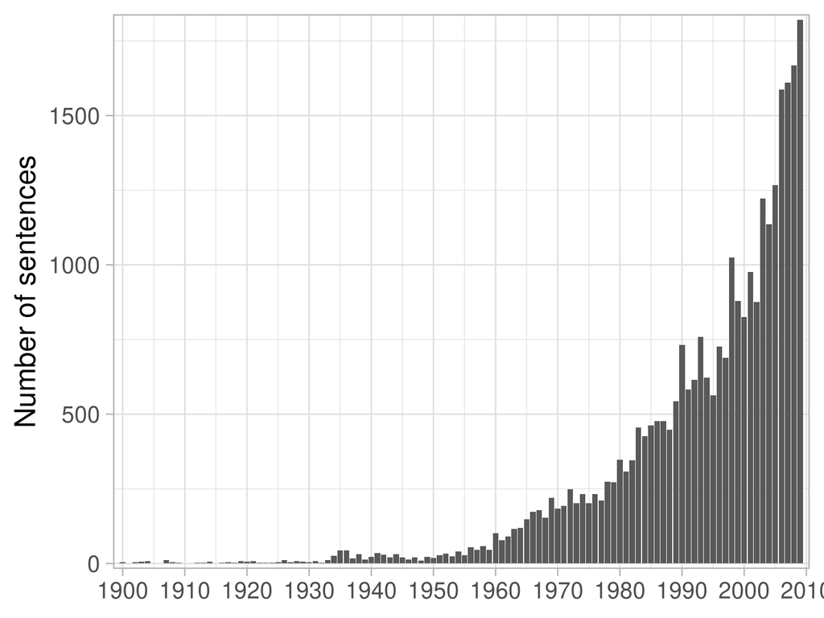

### Closest sentence from ‘rational’ and ‘rationality’ of the backbone community

| Sentence | Title | Year | Journal | Authors | Words Similarity |
| --- | --- | --- | --- | --- | --- |
| In the context of this debate, it becomes very important that a deviation from rationality is first precisely measured at the individual level and then measured again in a market setting to see its ag… | Is the lure of choice reflected in market prices? Experimental evidence based on the 4-door Monty Hall problem | 2009 | Journal of Economic Psychology | Siddiqi H. | 0.799 |
| For example, it is often argued that even if there are irrational investors, the ‘marginal investor’ is rational, so that prices must be set rationally. | Limited attention, information disclosure, and financial reporting | 2003 | Journal of Accounting and Economics | Hirshleifer D. | 0.787 |
| Incentives to be Rational Although the analysis in the previous sub-section shows that irrational agents will survive (under a large set of parameters), this analysis does not indicate whether irratio… | On the Impossibility of Weak-form Efficient Markets | 2003 | Journal of Financial and Quantitative Analysis | Slezak S.L. | 0.786 |
| Russell and Thaler (1985)investigate in a more abstract setup the proportion of rational agents necessary to obtain a “rational” market outcome (cf. | Ricardian equivalence with uninformed consumers? | 1999 | European Journal of Political Economy | Reiter M. | 0.785 |
| Thus, if irrational agents can choose to become rational on the basis of expected return, a mass of irrational investors will persist in equilibrium as long as there is a positive cost associated with… | On the Impossibility of Weak-form Efficient Markets | 2003 | Journal of Financial and Quantitative Analysis | Slezak S.L. | 0.782 |
| The principles which justify the quantification of rationality at the individual level (linearity, additivity, and no arbitrage opportunities) are the same principles which apply even more forcefully … | Arbitrage, rationality, and equilibrium | 1991 | Theory and Decision | Nau R.F. | 0.780 |
| Markets cannot be rational if agents are not fully rational in the particular sense in which theorists have modeled it, and this proposition has been uncritically accepted by psychologists and behavio… | Behavioral economics research and the foundations of economics | 2005 | Journal of Socio Economics | Smith V. | 0.780 |
| Consider an investor who prefers more money to less, but additionally exhibits the empirically observed boundedly rational behavior of framing the investment possibilities into different mental accoun… | The behavioral relevance of mental accounting for the pricing of financial options | 2004 | Journal of Economic Behavior and Organization | Rockenbach B. | 0.778 |
| Although I must confess to a traditional view on the central role of rational behavior in finance, I also believe that financial models based on frictionless markets and complete information are often… | [A Simple Model of Capital Market Equilibrium with Incomplete Information](http://www.jstor.org/stable/2328367) | 1987 | The Journal of Finance | Robert C. Merton | 0.778 |
| This sophisticated rationality yields results that differ, markedly at times, from behavioral models in which one side of the market has agents who react plausibly, but not rationally, to market condi… | [Quality Uncertainty, Search, and Advertising](http://www.jstor.org/stable/1814660) | 1983 | The American Economic Review | Steven N. Wiggins, W. J. Lane | 0.774 |
| Blume and Easley (1990) also address the question of whether rationality alone is a sufficient condition for survival in a financial market, and find this is not the case. | Agent-based computational finance: Suggested readings and early research | 2000 | Journal of Economic Dynamics and Control | LeBaron B. | 0.769 |
| Firstly, only those market participants will be considered who are expected to be the most rational, i.e. | The noise trading approach - Questionnaire evidence from foreign exchange | 1998 | Journal of International Money and Finance | Menkhoff L. | 0.768 |
| concur with their modeling of a rational market maker who correctly infers that certain investors with low valuations are constrained from selling their stock; as the rational market maker refuses to … | An exploration of earnings whispers forecasts as predictors of stock returns | 2005 | Journal of Economic Studies | Abraham R. | 0.768 |
| Not all market participants have to be rational in order for a market to display rational expectations. | [Are Market Forecasts Rational?](http://www.jstor.org/stable/1802780) | 1981 | The American Economic Review | Frederic S. Mishkin | 0.766 |
| Yet modern finance theory has assumed that there is such a thing (as “rational behavior”), has based its methodology and its methods on the existence of such a thing, and is forcing BF to be structure… | Resistance is futile: The assimilation of behavioral finance | 2002 | Journal of Economic Behavior and Organization | Frankfurter G. | 0.762 |
| In our model rationality is important on the level of the market since market selection may ultimately give pressure for selecting the rational portfolio rules. | [Evolutionary Stable Stock Markets](http://www.jstor.org/stable/25056027) | 2006 | Economic Theory | Igor V. Evstigneev, Thorsten Hens, Klaus Reiner Schenk-Hoppé | 0.761 |
| Although there is still not a widely accepted irrational model, we believe that the reactions of market participant may not be as rational as we assumed. | Continuous overreaction, insiders trading activities and momentum strategies | 2002 | Journal of Multinational Financial Management | Xiang J. | 0.760 |
| It is worthwhile to take a moment to the way in which irrationality is formalized and to consider whether this particular form of imperfect rationality is likely to be one that is at work in a signifi… | [Comment on Financial Fragility with Rational and Irrational Exuberance](http://www.jstor.org/stable/2601073) | 1999 | Journal of Money, Credit and Banking | John Weinberg | 0.759 |
| Moreover, the benefits for rational traders are higher, the more boundedly rational agents are present in the market (i.e. | More hedging instruments may destabilize markets | 2009 | Journal of Economic Dynamics and Control | Brock W.A. | 0.759 |
| Rational behavior is often a forgone conclusion in many investigations of the market’s reaction to a variety of events, such as those mentioned above. | The market’s reaction to unexpected, catastrophic events: The case of airline stock returns and the September 11th attacks | 2004 | Quarterly Review of Economics and Finance | Carter D.A. | 0.758 |
| The successive elimination of arbitrage states, may be interpreted as a rational behavior. | [Elimination of Arbitrage States in Asymmetric Information Models](http://www.jstor.org/stable/40282959) | 2009 | Economic Theory | Bernard Cornet, Lionel De Boisdeffre | 0.758 |

### Closest sentences from ‘rational’ and ‘rationality’ of the HDBSCAN cluster

#### Closes sentences 3_1_1900-1919: circulating_capital, farwell, active_influence, influence_determining, capital_rests (1900-1919)

| Sentence | Title | Year | Journal | Authors | Words Similarity |
| --- | --- | --- | --- | --- | --- |
| I anm not stating a paradox; to arrive at a proper result the learned judge was driven by previous decisions to hold that blast furnaces and cottages are circulating capital. | [The Legal View of Profits](http://www.jstor.org/stable/2220883) | 1903 | The Economic Journal | C. P. Sanger | 0.619 |
| The principle of diminishing returns, also, has been variously treated according as the writer was reasoning from an individual or a social point of view. | [The Social Point of View in Economics](http://www.jstor.org/stable/1884931) | 1913 | The Quarterly Journal of Economics | Lewis H. Haney | 0.605 |
| This curious process of reasoning is illustrated by the following passage, which is typical of many others: B A .A PA A’ ; Labor, applied to the whole fund of capital in land and all other instruments… | [The Marginal Productivity Theory of Distribution](http://www.jstor.org/stable/1817948) | 1907 | Journal of Political Economy | U. S. Parker | 0.597 |
| On the consequences of leaving the agents with less than a fair return on the requisite capital it is unnecessary to dwell; there would cease to be agents-a condition of things which has not arisen si… | [The Monopoly in Alcoholic Drink](http://www.jstor.org/stable/2959904) | 1919 | The Economic Journal | J. S. Eagles | 0.593 |
| But surely this power can be best determined not by mere presumption, but by results, viz., the higher yield upon capital. | [The Special Taxation of Business Profits in Relation to the Present Position of National Finance](http://www.jstor.org/stable/2223351) | 1919 | The Economic Journal | J. C. Stamp | 0.592 |
| There is, therefore, a radical difference between the causes of irregularity in production arising in this way, and those affecting the production of durable goods, because in the latter case sound ju… | [A Non-Monetary Cause of Fluctuations in Employment](http://www.jstor.org/stable/2221995) | 1914 | The Economic Journal | C. F. Bickerdike | 0.587 |
| But if it is permissible to refuse to regard men as capital, there is logically no place for choses in action, unless upon the acceptance of the private-capital concept - an -outcome which both Fetter… | [Capital as a Competitive Concept](http://www.jstor.org/stable/1817716) | 1904 | Journal of Political Economy | H. J. Davenport | 0.585 |
| But the acceptance of this explanation implies an acceptance of the corollary that, inasmuch as preliminary restriction of consumption is required, capital formation must proceed at a less rapid rate … | [Commercial Banking and Capital Formation: IV](http://www.jstor.org/stable/1822000) | 1918 | Journal of Political Economy | H. G. Moulton | 0.584 |
| To explain or justify interest it was necessary to show that the creation of capital involved a sacrifice or cost which was as mucb entitled to a reward as labor and which if unrewarded would not be u… | [Commercial Banking and Capital Formation: IV](http://www.jstor.org/stable/1822000) | 1918 | Journal of Political Economy | H. G. Moulton | 0.584 |
| It is interesting to notice that Veblen recognized the self-consistency of Fisher’s treatise as an example of the mechanics of self-interest, and held that the omission of pecuniary concepts creates d… | [The Rationality of Economic Activity](http://www.jstor.org/stable/1820997) | 1910 | Journal of Political Economy | Wesley C. Mitchell | 0.582 |

#### Closes sentences 3_1_1920-1929: prudent_investment, customer_ownership, physical_assets, banker, dividends (1920-1929)

| Sentence | Title | Year | Journal | Authors | Words Similarity |
| --- | --- | --- | --- | --- | --- |
| There can be no doubt as to the existence of such a tendency resulting from the motives of accumulation and capitalization which we have described. | [The Theory of Economic Cycles Based on the Tendency Toward Excessive Capitalization](http://www.jstor.org/stable/1927217) | 1928 | The Review of Economics and Statistics | Mentor Bouniatian | 0.596 |
| The practical difficulties involved (e.g., the determination of the amount of capital to be included in any case and the selection of a rate) have no doubt weighed most heavily in establishing this at… | [Interest During Construction](http://www.jstor.org/stable/1822214) | 1920 | Journal of Political Economy | W. A. Paton | 0.589 |
| If A were to continue in business year after year and be unsuccessful with respect to operation, he surely would not be justified in complacently assuming that interest was steadily accruing on his in… | [Interest During Construction](http://www.jstor.org/stable/1822214) | 1920 | Journal of Political Economy | W. A. Paton | 0.570 |
| Such a procedure, to be logical, requires that there be some measure of the value of invested capital independent of the earnings. | [Suggestions for Revision of the Federal Taxation of Income and Profits](http://www.jstor.org/stable/1803340) | 1920 | The American Economic Review | Fred Rogers Fairchild | 0.564 |
| The mornentous fact stated above is so evidently a lnecessary deduction from orienting economics on enterprise, and of defining capital in terms of its relation to enterprise, that it would have promp… | [The Orientation of Economics on Enterprise](http://www.jstor.org/stable/1810855) | 1927 | The American Economic Review | Frederick Barnard Hawley | 0.563 |
| Tracing the criticisms based upon the exclusion of borrowed capital back to their ultimate source, we find their true significance to be that a sound determination of the normal deduction cannot be ma… | [Should The Excess Profits Tax be Repealed](http://www.jstor.org/stable/1884092) | 1921 | The Quarterly Journal of Economics | Thomas S. Adams | 0.562 |
| He adds: “There can be no alternative; for to allow only a non-speculative return on the investment, the objective of all regulation and yet not to guarantee that return is for the public to attempt t… | [Economic Purposes and Limitations of Consolidation](http://www.jstor.org/stable/1801697) | 1924 | The American Economic Review | Winthrop M. Daniels | 0.552 |
| It may be natural, at a time when high-price levels would make reproduction valuations immediately advantageous to the common stock, for the holders of such stock to feel that present advantages, real… | [Undepreciated Investment as a Utility Rate Base](http://www.jstor.org/stable/3138894) | 1925 | The Journal of Land & Public Utility Economics | George C. Mathews | 0.550 |
| Nevertheless, for the reasons urged, we may conclude that the problem which it is designed to meet can best be handled through the rate of return rather than through an inflation of the capital base. | [Going Value–Comments on its Nature and Legal Status](http://www.jstor.org/stable/1805912) | 1927 | The American Economic Review | Ben W. Lewis | 0.548 |
| The economic question-begging, or confusions of thought on the other side, bluntly summarised, were: ” Capital is an essential of life, and the worker would be badly off if it were not accumulated. | [Inheritance as an Economic Factor](http://www.jstor.org/stable/2959788) | 1926 | The Economic Journal | Josiah Stamp | 0.548 |

#### Closes sentences 3_3_1930-1939: investment, investment_period, overinvestment, acceleration_principle, fluidity (1930-1939)

| Sentence | Title | Year | Journal | Authors | Words Similarity |
| --- | --- | --- | --- | --- | --- |
| There are, however, reasons for believing in the interpretation given” and then it seems that a better explanation of investment is possible than the poor one yielded by the acceleration principle. | [Statistical Evidence on the Acceleration Principle](http://www.jstor.org/stable/2549019) | 1938 | Economica | J. Tinbergen | 0.636 |
| It might be argued that since different forms of investment involve different costs the choice is not so simply determined. | [Fluctuations in Capital and the Demand for Money](http://www.jstor.org/stable/2967549) | 1934 | The Review of Economic Studies | S. P. Chambers | 0.613 |
| But the realization that such a “cast of thought” exists does not help us here, nor can we derive any solution of our problem from the fact that one investment is the rival of another. | [A Break in Keynes’s Theory of Interest](http://www.jstor.org/stable/192) | 1937 | The American Economic Review | Carl Landauer | 0.604 |
| It seems safe to assert, however, that this is not the case in reality, that the only consideration leading to a discrimination against extremely long construction periods, such as the planting of tre… | [The Quantity of Capital and the Rate of Interest: I](http://www.jstor.org/stable/1823196) | 1936 | Journal of Political Economy | Frank H. Knight | 0.594 |
| The whole matter of overinvestment and rationalization requires more incisive theoretical analysis and thorough examination of the facts in a number of industries. | [Monopolistic Competition and Public Policy](http://www.jstor.org/stable/1807766) | 1936 | The American Economic Review | Donald H. Wallace | 0.587 |
| Thus in most real cases the computation necessary for the perfectly rational directing of investment is far more complex than we have indicated.9 The root of the difficulty as regards capital, viewed … | [The Quantity of Capital and the Rate of Interest: I](http://www.jstor.org/stable/1823196) | 1936 | Journal of Political Economy | Frank H. Knight | 0.583 |
| And, if the investment is rationally made, this quantity will be equal to the present worth of the income stream to be derived from the use of the capital good. | [The Quantity of Capital and the Rate of Interest: I](http://www.jstor.org/stable/1823196) | 1936 | Journal of Political Economy | Frank H. Knight | 0.577 |
| But these considerations do not call for any essential modification of the basic general theory.2’ The importance even of provision for possible real disinvestment, i.e., actual consumption of capital… | [The Quantity of Capital and the Rate of Interest: I](http://www.jstor.org/stable/1823196) | 1936 | Journal of Political Economy | Frank H. Knight | 0.572 |
| And with the abandonment of this basis of the distinction, there will, of course, have to fall the habitual practice of economists of separating out such part of general investment activity as happens… | [The Maintenance of Capital](http://www.jstor.org/stable/2548607) | 1935 | Economica | F. A. von Hayek | 0.571 |
| It is an open question whether this can be regarded as evidence that they reckon on unfavourable developments, which would make the investment unprofitable, as probable enough to make it not worth whi… | [Some Notes on the Stockholm Theory of Savings and Investment I](http://www.jstor.org/stable/2225278) | 1937 | The Economic Journal | Bertil Ohlin | 0.569 |

#### Closes sentences 3_2_1930-1939: capital, capital_intact, investment_period, production_period, maintain_capital (1930-1939)

| Sentence | Title | Year | Journal | Authors | Words Similarity |
| --- | --- | --- | --- | --- | --- |
| On the face of it, there must be plausible reasons for holding that the use of more capital is equivalent to the use of more time in production; otherwise the doctrine would not have been so generally… | [Professor Hayek and the Theory of Investment](http://www.jstor.org/stable/2224581) | 1935 | The Economic Journal | Frank H. Knight | 0.659 |
| recognised the much more fundamental fact that such constancy of the value dimension has no necessary connection with the reasons why we wish to ” maintain capital intact,” and that in consequence the… | [The Maintenance of Capital](http://www.jstor.org/stable/2548607) | 1935 | Economica | F. A. von Hayek | 0.654 |
| powers, it should be also admitted that other conditions, especially the amount of capital, for instance, will sooner or later correspond to it. | A CRITICAL ANALYSIS OF BÖHMBAWERK’S THEORY OF CAPITAL | 1934 | Kyoto University Economic Review | Yasuma Takata | 0.603 |
| It need only be added here that the doctrines to be eliminated include all notions of any definite relation between quantity of capital and the ” length of the production process,” or ” time ” in any … | [Capital, Time, and the Interest Rate](http://www.jstor.org/stable/2548804) | 1934 | Economica | Frank H. Knight | 0.591 |
| The latter part of the assumption might be argued to raise more serious questions than the first part; there are fairly clear reasons why personal qualities are not capitalized to anything like the sa… | [The Quantity of Capital and the Rate of Interest: I](http://www.jstor.org/stable/1823196) | 1936 | Journal of Political Economy | Frank H. Knight | 0.584 |
| That the increasing money values of capital cannot be maintained without further inflation if the amount of appreciation is generally used for consumption purposes, is, of course, only another form of… | [The Maintenance of Capital](http://www.jstor.org/stable/2548607) | 1935 | Economica | F. A. von Hayek | 0.583 |
| The assumption is that the capitalist is driven by the inward laws of his nature to accumulate and invest. ” | [Marx and the Trade Cycle](http://www.jstor.org/stable/2967454) | 1937 | The Review of Economic Studies | Henry Smith | 0.582 |
| somewhat nearer a realistic assumption by stating that what people aim to maintain constant is not some physical or value dimension of capital, but its ” capacity to render service.”’ | [The Mythology of Capital](http://www.jstor.org/stable/1885022) | 1936 | The Quarterly Journal of Economics | F. A. v. Hayek | 0.582 |
| Also, to clarify and emphasize the sound general view of capital, into which any possible instance which may conform to the view of it as time or roundaboutness fits naturally as a special case. | [The Theory of Investment Once More: Mr. Boulding and the Austrians](http://www.jstor.org/stable/1882342) | 1935 | The Quarterly Journal of Economics | Frank H. Knight | 0.581 |
| All that is required is that the value of the services which depend on the existence of a certain capital good be no higher than the cost of reproduction of a good that will render the same service or… | [The Mythology of Capital](http://www.jstor.org/stable/1885022) | 1936 | The Quarterly Journal of Economics | F. A. v. Hayek | 0.579 |

#### Closes sentences 3_2_1940-1949: blueprint, investment, focus_gain, capital_intact, investment_decisions (1940-1949)

| Sentence | Title | Year | Journal | Authors | Words Similarity |
| --- | --- | --- | --- | --- | --- |
| As has already been said, where investment decisions are based on subjective judgments of the relative values of different things and not objective comparison of their values expressed in some common … | [Investment Policy in a Nationalised Industry](http://www.jstor.org/stable/2296277) | 1949 | The Review of Economic Studies | M. F. Scott | 0.654 |
| But on the other hand it seems obviously unreasonable to demand that the project of a particular enterprise, which shows good prospects of success in view of exceptional care having been taken over it… | [Patent Reform](http://www.jstor.org/stable/2295967) | 1944 | The Review of Economic Studies | Michael Polanvyi, Michael Polanyi | 0.626 |
| But it is permissible for me to express the opinion that the ” real capital” conception is more sensible (which is not the same as saying more logical) than the financial conceptions of business men a… | [Commodity Stocks and the Trade Cycle: A Reply](http://www.jstor.org/stable/2550287) | 1944 | Economica | K. Lacey | 0.621 |
| This criterion, which should take precedence over the Marginal Rule, would tend to foster efficiency and economy in management, would give some guide to investment policy even if slightly incorrect an… | [Price and Outlay Policy of State Enterprise](http://www.jstor.org/stable/2226038) | 1945 | The Economic Journal | T. Wilson | 0.619 |
| It cannot, of course, be pretended that such an approach would avoid very difficult decisions, but it is true that there would need to be emphasis on central decision rather than on the application of… | [The Optimal Utilization of National Resources](http://www.jstor.org/stable/1907303) | 1949 | Econometrica | J. Stafford | 0.614 |
| He must decide rationally which of the above alternatives he shall take with his holdings of particular capital goods, or in what proportions he shall take both. | [The Role of Money in Equilibrium Capital Theory](http://www.jstor.org/stable/1905717) | 1943 | Econometrica | Martin Bronfenbrenner | 0.613 |
| This fact already suggests that the possibility of a rational theory of investment requires a theory that involves at least some sort of dynamic elements. | [A Note on the Theory of Investment](http://www.jstor.org/stable/2295718) | 1949 | The Review of Economic Studies | T. Haavelmo | 0.611 |
| If carried out “rationally,” this implies equalization of the rate of return for all forms of investment that are open to the investor in our case to “society.” | [Diminishing Returns from Investment](http://www.jstor.org/stable/1830979) | 1944 | Journal of Political Economy | Frank H. Knight | 0.603 |
| 4 To state the criterion in this way incidentally rules out any effect of mere time-preference as a determinant of what is and what is not capital. | [Permanent Resources](http://www.jstor.org/stable/2549986) | 1943 | Economica | G. F. Thirlby | 0.603 |
| First, for reasons developed above, businessmen may be led to act ” bearishly ” in their investment decisions. ” | [Investment in a Monetary Economy](http://www.jstor.org/stable/2549587) | 1949 | Economica | J. S. G. Wilson | 0.603 |

#### Closes sentences 3_5_1950-1959: investment, investment_decisions, acceleration_principle, investment_decision, acceleration (1950-1959)

Year

Journal

Authors

Words Similarity

As was stated earlier, it is impossible to generalize about the appropriate choice of investment priorities; the arguments made here are such that each case has to be examined on its own merits.

[Maintenance Costs and Economic Development](http://www.jstor.org/stable/1827310)

1959

Journal of Political Economy

Rudolph C. Blitz

0.661

Since this discussion relies greatly on presumptions, it must be admitted that such firms might be prone to rationalize their behavior in terms of a factor entirely bevond their control such as the cost of capital.

[Interest Inelasticity of Investment Demand: The Case from Business Attitude Surveys Re-Examined](http://www.jstor.org/stable/1814283)

1956

The American Economic Review

William H. White

0.641

I shall assume that investment preferences, including those termed “traditional,” are rational and can therefore be explained in terms of the two chief considerations that enter into all investment decisions: profit and risk.

[Industrial Investment Decisions: A Comparative Analysis](http://www.jstor.org/stable/2114427)

1955

The Journal of Economic History

Henry G. Aubrey

0.632

“7 Hebelievesthatheestablishes this by the use of a particular analysis of the investment decision, It seems to me that what he offers is only another way of chopping up an idealized investment decision, which can prove nothing as to the way in which actual investment decisions are made.

[Culbertson on Interest Structure: Reply](http://www.jstor.org/stable/1884340)

1958

The Quarterly Journal of Economics

J. M. Culbertson

0.630

[Comment on the Marginal Efficiency of Capital and Investment Programming](http://www.jstor.org/stable/2227389)

1957

The Economic Journal

J. A. Scott

0.628

Thus it rules out inventory decision [8] and investment problems in which the storage levels or investment programs to be chosen constrain some of the choices subsequently to be made, the “correctness” of current choices not being known until a subsequent observation time.

[Centralization and Decentralization in Economic Organizations](http://www.jstor.org/stable/1909469)

1959

Econometrica

Thomas Marschak

0.621

To illustrate this point, consider the problem of investment decisions.

[On the Use of the Theory of Probability in Economics](http://www.jstor.org/stable/2295889)

1952

The Review of Economic Studies

R. S. Weckstein

0.618

1. Reference to a more or less developed concept of opportunity cost was especially marked among those engineers who were seeking a rational method of allocating scarce investment funds.

[Scarce Capital and Soviet Doctrine](http://www.jstor.org/stable/1881692)

1953

The Quarterly Journal of Economics

Gregory Grossman

0.614

The checks on the performance of central planners are also likely to be much weaker than the checks on private decision-makers.5 But whatever may be the merits of various systems, it is clear that an investment criterion which is to be applied by public authorities must reflect these repercussion effects and thus must look beyond given sets of market prices.

[Investment Criteria for Economic Development and the Theory of Intertemporal Welfare Economics](http://www.jstor.org/stable/1882296)

1957

The Quarterly Journal of Economics

Otto Eckstein

0.599

The authors do not explain why capital has to bear a charge justified and determined on this basis; they present it as a self-evident proposition.

[Scarce Capital and Soviet Doctrine](http://www.jstor.org/stable/1881692)

1953

The Quarterly Journal of Economics

Gregory Grossman

0.597

#### Closes sentences 3_5_1960-1969: investment, investment_decisions, capital, investments, investment_decision (1960-1969)

| Sentence | Title | Year | Journal | Authors | Words Similarity |
| --- | --- | --- | --- | --- | --- |
| When uncertainty prevails the treatment of rational behaviour is complicated by the fact that the investor’s planning of his future dispositions in connection with the investment activity will not inv… | [Some Reflexions on the Theories of Choice between Alternative Investment Opportunities](http://www.jstor.org/stable/40436564) | 1967 | Weltwirtschaftliches Archiv | Tönu Puu | 0.688 |
| Much of his argument is thus at cross purposes; it may be somewhere in this confusion that he sees the distinction between criteria and maximands.6 As we see it, the investor can only have one maximan… | [Present Value Versus Internal Rate of Return: A Comment](http://www.jstor.org/stable/2228526) | 1964 | The Economic Journal | John S. Flemming, Martin S. Feldstein | 0.671 |
| To the extent to which any part of such an expenditure is investment in this sense it is rarely if ever “rational” investment based on a careful comparison of alternate investment opportunities, with … | [Investment in Human Capital: Comment](http://www.jstor.org/stable/1813847) | 1961 | The American Economic Review | Harry G. Shaffer | 0.671 |
| After all, a rational investment is one made after considering all the alternatives, and if the incentives widen the range of possibilities considered, they must have some positive impact. | [Tax Incentives and Economic Development: The Ecuadorian Experience](http://www.jstor.org/stable/40910614) | 1969 | FinanzArchiv / Public Finance Analysis | Vito Tanzi | 0.667 |
| To public policy makers it may appear irrational to choose an investment program which maximizes investment potential in preference to maximizing production in the commodities production sector. | THE APPLICATION OF AN INVESTMENT MODEL TO RURAL LAND SETTLEMENT SCHEMES IN MALAYSIA | 1967 | Proceedings of the Annual Meeting (Western Farm Economics Association) | Thaine H. Allison Jr. | 0.666 |
| The theorist could not for too long shut his eyes to these practices; and, even if only hesitantly, he has followed the practical men in the quest for some rational investment criterion. | [The Soviet and Polish Quest for a Criterion of Investment Efficiency](http://www.jstor.org/stable/2551225) | 1962 | Economica | Alfred Zauberman | 0.663 |
| Its decisions are motivated by the desire to maximize stockholder net worth and are made by simultaneously weighing the effects of one choice versus those of the others In order to conserve space we s… | [The Firm Decision Process: An Econometric Investigation](http://www.jstor.org/stable/1879673) | 1967 | The Quarterly Journal of Economics | Dennis C. Mueller | 0.641 |
| On the other hand, however, the world of individual investment as determined by the quantum of “decision-effort” allocated to the particular investment-possibility being considered. | [Uncertainty, Likelihoods and Investment Decisions](http://www.jstor.org/stable/1884131) | 1960 | The Quarterly Journal of Economics | James W. Angell | 0.640 |
| But against ’the background of a different “model” of capital budgeting that does more justice to the interdependence of the investment decision this behavior could be viewed as more complex than irra… | [Business Tax Provisions of the 1962 and 1964 Acts](http://www.jstor.org/stable/2977234) | 1965 | The Journal of Finance | Daniel M. Holland | 0.638 |
| But, in fact, a good many firms base their investment decisions on less complex and seemingly less “rational” procedures. | [Business Tax Provisions of the 1962 and 1964 Acts](http://www.jstor.org/stable/2977234) | 1965 | The Journal of Finance | Daniel M. Holland | 0.635 |

#### Closes sentences 3_8_1970-1979: investment, portfolio, investors, risk, investor (1970-1979)

| Sentence | Title | Year | Journal | Authors | Words Similarity |
| --- | --- | --- | --- | --- | --- |
| Another advantage of the system is that it creates conditions in which the base level not only wants but also must undertake rational investment decisions, although they are rational from their own an… | [The Investment System of a Socialist Economy](http://www.jstor.org/stable/4379461) | 1973 | Eastern European Economics | Eugeniusz Rychlewski, A. I. Ross | 0.707 |
| There are different criteria for appraising investment and operation activity with marked dominance of the latter criteria, and as a result rational investment decisions are either not made or unwilli… | [The Investment System of a Socialist Economy](http://www.jstor.org/stable/4379461) | 1973 | Eastern European Economics | Eugeniusz Rychlewski, A. I. Ross | 0.701 |
| That is, individuals are presumed to adhere to certain postulates of rational behavior, which in turn lead them to evaluate their portfolios on the basis of expected utility.6 The utility of a portfol… | Mutual Life Insurer’s Portfolio and Policyholder Utility Functions | 1974 | The Journal of Risk and Insurance | Richard A. Cohn | 0.697 |
| And, as the reader must have gathered, my purpose in reviewing this Hicksian line of reasoning is to point out that for a firm to constrain its financial policies so as to have the same capital value … | [Comments: Replies](http://www.jstor.org/stable/2326871) | 1975 | The Journal of Finance | Fred D. Arditti | 0.674 |
| Also, segmentation may result when investors’ utility functions are not restricted to embodying only probability distributions of future wealth, but rather might encompass considerations which may, on… | [General Model of Imperfect Capital Markets](http://www.jstor.org/stable/1056874) | 1973 | Southern Economic Journal | Dennis E. Logue, Larry J. Merville | 0.662 |
| The extension of investments beyond this point cannot be considered as rational, and this point can therefore be considered as the rational maximum or, in other words, the optimum of investment. | [THE OPTIMAL RATE OF GROWTH OF THE CAPITAL STOCK](http://www.jstor.org/stable/40728054) | 1972 | Acta Oeconomica | L. Mihályffy, Gy. Szakolczai | 0.661 |
| The analysis assumes rational decision making in which investments are made up to the point where the marginal internal rate of return is equal to the marginal cost of the funds that are invested. | [Earnings Inequality and Economic Development](http://www.jstor.org/stable/1881838) | 1971 | The Quarterly Journal of Economics | Barry R. Chiswick | 0.658 |
| Furthermore, it seems rational from the point of view of society that an investment be undertaken only if it is expected to offer at least this return. | Optimal Depreciation Policy: Pricing the Products of Durable Assets | 1971 | The Bell Journal of Economics and Management Science | William J. Baumol | 0.654 |
| The problems related to non-economic factors influencing the decision maker’s attitudes are well-known in traditional investment planning. | [Stochastic Investment Models and Decision Criteria](http://www.jstor.org/stable/3439055) | 1971 | The Swedish Journal of Economics | Søren Duus Østergaard | 0.653 |
| If a firm’s decisions are confined to “productive decisions,” and if the range of available assets is sufficiently great that stockholders can undo, by portfolio adjustments, what firms do by incremen… | The Economics of Internal Organization: An Introduction | 1975 | The Bell Journal of Economics | A. Michael Spence | 0.646 |

#### Closes sentences 3_14_1980-1989: asset, arbitrage, investors, markets, traders (1980-1989)

| Sentence | Title | Year | Journal | Authors | Words Similarity |
| --- | --- | --- | --- | --- | --- |
| Although I must confess to a traditional view on the central role of rational behavior in finance, I also believe that financial models based on frictionless markets and complete information are often… | [A Simple Model of Capital Market Equilibrium with Incomplete Information](http://www.jstor.org/stable/2328367) | 1987 | The Journal of Finance | Robert C. Merton | 0.778 |
| This sophisticated rationality yields results that differ, markedly at times, from behavioral models in which one side of the market has agents who react plausibly, but not rationally, to market condi… | [Quality Uncertainty, Search, and Advertising](http://www.jstor.org/stable/1814660) | 1983 | The American Economic Review | Steven N. Wiggins, W. J. Lane | 0.774 |
| Not all market participants have to be rational in order for a market to display rational expectations. | [Are Market Forecasts Rational?](http://www.jstor.org/stable/1802780) | 1981 | The American Economic Review | Frederic S. Mishkin | 0.766 |
| Rationality of both behavior and of expectations often does not imply that the price of an asset be equal to its fundamental value. | [Testing for Bubbles in Exchange Markets: A Case of Sparkling Rates?](http://www.jstor.org/stable/1837408) | 1986 | Journal of Political Economy | Richard A. Meese | 0.751 |
| It does raise interesting questions about the meaning and nature of rationality in a market where various agents attach different, and possibly time-varying, weights to differing models. | [The Foreign Exchange Market: A Random Walk with a Dragging Anchor](http://www.jstor.org/stable/2553908) | 1988 | Economica | Charles Goodhart | 0.739 |
| In particular, it might be claimed that, since it may only take a few, well-informed individuals to police a particular rational expectations equilibrium, evidence on the irrationality of a few market… | [What Do Investment Managers Know? An Empirical Study of Practioners’ Predictions](http://www.jstor.org/stable/2554467) | 1988 | Economica | Mark P. Taylor | 0.735 |
| To see this note that rationality requires that the matrix of coefficient weights (^y) that determine the stochastic structure of X, coincides with the weights employed by investors (as depicted in eq… | [The Impact of News and Alternative Theories of Exchange Rate Determination](http://www.jstor.org/stable/1992628) | 1985 | Journal of Money, Credit and Banking | Dennis L. Hoffman, Don E. Schlagenhauf | 0.723 |
| 5 Rational behavior and perfect markets then imply that such securities’ present values differ by those same proportionality factors. | The natural taxation of capital gains and losses when incomes is taxed | 1984 | Journal of Banking and Finance | Ball R. | 0.716 |
| One might argue that if market participants had been truly rational, their behavior would have been more consistent with the best predicting ARIMA model, regardless of subsequent events. | [Reason and Rationality during Energy Crises](http://www.jstor.org/stable/1840436) | 1983 | Journal of Political Economy | George G. Daly, Thomas H. Mayor | 0.714 |
| The need for substantial wealth on the part of rational agents is obvious: The existence of a lower bound (zero) on any agent’s consumption in any state implies the existence of bounds on that agent’s… | [Efficient Capital Markets and Martingales](http://www.jstor.org/stable/2727024) | 1989 | Journal of Economic Literature | Stephen F. LeRoy | 0.713 |

#### Closes sentences 3_12_1980-1989: investment, capital_stock, investment_decisions, investment_decision, optimal (1980-1989)

| Sentence | Title | Year | Journal | Authors | Words Similarity |
| --- | --- | --- | --- | --- | --- |
| Thus assume that uncertainty is present in nontrivial degree and consider the ramifications for contract of differences in bounded rationality, opportunism, and asset specificity. | [Assessing Contract](http://www.jstor.org/stable/764911) | 1985 | Journal of Law, Economics, & Organization | Oliver E. Williamson | 0.701 |
| Thus, if there is great uncertainty surrounding investment decisions, and producers respond to this by making, so far as possible, the same investment decisions this period as last period (since, afte… | [Deficient Foresight: A Troublesome Theme in Keynesian Economics](http://www.jstor.org/stable/1831546) | 1982 | The American Economic Review | Alan Coddington | 0.648 |
| They argue informally that the introduction of conduct into a model with investment decisions would substantially alter the accepted intuition. | [Entry, Sunk Costs and Renegotiation in Duopoly](http://www.jstor.org/stable/20075756) | 1989 | Annales d’Économie et de Statistique | James Bergin, W. Bentley Macleod | 0.643 |
| Even Coddington notes that ‘if there is great uncertainty surrounding investment decisions, and producers respond to this by making, so far as possible, the same investment decisions this period as la… | [Uncertainty and Economic Analysis](http://www.jstor.org/stable/2233256) | 1985 | The Economic Journal | Tony Lawson | 0.639 |
| To this extent, a firm’s choice to invest abroad must be based on some criterion of rational choice, i.e., on expectations of being able to realize, directly or indirectly, in the short run or long ru… | Third world multinationals. The characteristics of Indian firms investing abroad | 1986 | Journal of Development Economics | Lall R. | 0.638 |
| In another paper Bernhard (1981) claims that my theory of investment evaluation under uncertainty (Blatt, 1979) is irrational. | [The Utility of Being Hanged on the Gallows: Some Replies](http://www.jstor.org/stable/4537667) | 1981 | Journal of Post Keynesian Economics | John M. Blatt | 0.624 |
| In fine, and at the bottom line, we merely restate here that in terms of real-world situa tions where the rate of inflation exceeds the rate of return of the best investment alterna tive, the decision… | [Inflation and the Rationality of Investing in Projects with Negative Net Present Values](http://www.jstor.org/stable/25603582) | 1983 | The American Economist | Michael G. Angel, Thomas O. Nitsch | 0.621 |
| They thus incorporate expectations into fix price theory but cannot treat properly the investment decisions of firms, the importance of which is emphasized in Malinvaud (1982). | [Demand Constraints, Rational Expectations and Investment Theory](http://www.jstor.org/stable/2663044) | 1985 | Oxford Economic Papers | Mark Precious | 0.618 |
| Also the objective function we use, which defines ‘rational’ investment decisions, reflects a tracking problem. | Project impact analysis as an optimal control problem | 1983 | Journal of Economic Dynamics and Control | Anandalingam G. | 0.615 |
| We thus obtain an (MM) proposition of financial irrelevance, where all the action comes from the firm’s decision to invest. | Corporate financing and investment decisions when firms have information that investors do not have | 1984 | Journal of Financial Economics | Myers S.C. | 0.614 |

#### Closes sentences 3_10_1990-1999: option, investment, irreversible_investment, investment_decisions, options (1990-1999)

| Sentence | Title | Year | Journal | Authors | Words Similarity |
| --- | --- | --- | --- | --- | --- |
| The rational theory can predict why individual option-holders will respond to the ratio of intrinsic to expected value, but it has difficulty explaining why option-holders would react to trends or a s… | [Psychological Factors and Stock Option Exercise](http://www.jstor.org/stable/2587018) | 1999 | The Quarterly Journal of Economics | Chip Heath, Steven Huddart, Mark Lang | 0.732 |
| Such a possibility, argue, arises because rational behavior requires that only those investment projects whose risk-adjusted expected returns are greater than their opportunity costs be undertaken. | The investment-cash flow linkage revisited: Evidence from aggregate data and multivariate Granger-causality tests | 1993 | Quarterly Review of Economics and Finance | Kholdy S. | 0.685 |
| Proposition 4 is our ‘’rational indecision’’ result, which proves that, no matter how deep in the money the option-to-build is, construction should not occur as long as V exactly equals W. This is les… | Insights on the effect of land use choice: The perpetual option on the best of two underlying assets | 1996 | Journal of Urban Economics | Geltner D. | 0.654 |
| Of course, the rational explanation was to be found in the basic lag structure Contractual in investment behavior, plus uncertainties of matching the two different economic systems . | United States-China joint ventures: The issue of ownership | 1991 | Journal of Asian Economics | Dutta M. | 0.653 |
| On the contrary, if we stress the assumption of decentralised investment decisions, we find -even assuming perfect foresight and knowledge -good reasons to deny the general possibility of the adjustme… | Capacity utilisation in the long run and the autonomous components of aggregate demand | 1995 | Contributions to Political Economy | Trezzini A. | 0.645 |
| However, it seems that the implicit rationality assumptions that underlie the foundations of these strategic tools are more uncertain than the early applications of economic analysis in capital invest… | Planning in firms as an interactive process | 1993 | Theory and Decision | Ponssard J.P. | 0.641 |
| This behavior is irrational according to the life cycle hypothesis, inconsistent with Grandmont-Laroque option demand for waiting, and not compatible with Kreps’s waiting, unless one is willing to adm… | [Is Probability Theory Relevant for Uncertainty? A Post Keynesian Perspective](http://www.jstor.org/stable/1942706) | 1991 | The Journal of Economic Perspectives | Paul Davidson | 0.640 |
| However, if we stress the assumption of decentralised investment decisions, we find -even assuming perfect foresight and knowledge -good reasons to deny the possibility of the adjustment. | Capacity utilisation in the long run and the autonomous components of aggregate demand | 1995 | Contributions to Political Economy | Trezzini A. | 0.639 |
| Because of the possibility of local-global confusion, these rational expectations about average investment are less sensitive to industry-wide shocks than the actual average investment. | [Differential Information, Monopolistic Competition, and Investment](http://www.jstor.org/stable/2527035) | 1991 | International Economic Review | Kiyohiko G. Nishimura | 0.638 |
| They are cases in which people make probability assessments of future events and then make rational decisions that maximize the expected utility they will receive from their investment opportunities. | [On Financial Frauds and Their Causes: Investor Overconfidence](http://www.jstor.org/stable/3487115) | 1998 | The American Journal of Economics and Sociology | Steven Pressman | 0.636 |

#### Closes sentences 3_9_1990-1999: traders, investors, informed_traders, trading, noise_traders (1990-1999)

| Sentence | Title | Year | Journal | Authors | Words Similarity |
| --- | --- | --- | --- | --- | --- |
| Russell and Thaler (1985)investigate in a more abstract setup the proportion of rational agents necessary to obtain a “rational” market outcome (cf. | Ricardian equivalence with uninformed consumers? | 1999 | European Journal of Political Economy | Reiter M. | 0.785 |
| The principles which justify the quantification of rationality at the individual level (linearity, additivity, and no arbitrage opportunities) are the same principles which apply even more forcefully … | Arbitrage, rationality, and equilibrium | 1991 | Theory and Decision | Nau R.F. | 0.780 |
| Firstly, only those market participants will be considered who are expected to be the most rational, i.e. | The noise trading approach - Questionnaire evidence from foreign exchange | 1998 | Journal of International Money and Finance | Menkhoff L. | 0.768 |
| It is worthwhile to take a moment to the way in which irrationality is formalized and to consider whether this particular form of imperfect rationality is likely to be one that is at work in a signifi… | [Comment on Financial Fragility with Rational and Irrational Exuberance](http://www.jstor.org/stable/2601073) | 1999 | Journal of Money, Credit and Banking | John Weinberg | 0.759 |
| At the same time, they show that there are circumstances under which rational traders can be driven out by irrational ones, and under which prices need not be set at rational expectations equilibrium … | Recent advances in evolutionary economics: comments | 1993 | Economics Letters | Samuelson L. | 0.752 |
| To save the efficient markets view it is not sufficient to assume symmetric rationality. | [The Concept of Information, Intractable Uncertainty, and the Current State of the “Efficient Markets” Theory: A Post Keynesian View](http://www.jstor.org/stable/4538397) | 1994 | Journal of Post Keynesian Economics | Murray Glickman | 0.747 |
| Although we make two distinct bounded-rationality assumptions, our model can be said to “unify” underreaction and overreaction in the following sense. | [A Unified Theory of Underreaction, Momentum Trading, and Overreaction in Asset Markets](http://www.jstor.org/stable/797990) | 1999 | The Journal of Finance | Harrison Hong, Jeremy C. Stein | 0.744 |
| While most economists recognize that, in fact, not everyone is fully rational, the existence of an irrational segment of the economy is often dismissed as irrelevant with the claim that there will be … | [Do Security Analysts Overreact?](http://www.jstor.org/stable/2006542) | 1990 | The American Economic Review | Werner F. M. De Bondt, Richard H. Thaler | 0.744 |
| Although irrational pricing theories can incorporate selected aspects of rational expectations and the rational determination of fundamental value, they take the position that market prices deviate fr… | Financial Market Volatility: A Survey | 1991 | Staff Papers (International Monetary Fund) | Louis O. Scott | 0.743 |
| When traders operate under suchuncertainty, no simple dividing line between rational and irrational behavior can be set down,13 and no paradox arises. | [The Concept of Information, Intractable Uncertainty, and the Current State of the “Efficient Markets” Theory: A Post Keynesian View](http://www.jstor.org/stable/4538397) | 1994 | Journal of Post Keynesian Economics | Murray Glickman | 0.742 |
| The proposition formalizes the intuitive point-common to many models in this genre-that risk-averse fully rational arbitrageurs attenuate, but do not eliminate, the effects induced by other less-than-… | [A Unified Theory of Underreaction, Momentum Trading, and Overreaction in Asset Markets](http://www.jstor.org/stable/797990) | 1999 | The Journal of Finance | Harrison Hong, Jeremy C. Stein | 0.742 |

#### Closes sentences 3_13_2000-2009: traders, investors, trading, informed_traders, volatility (2000-2009)

| Sentence | Title | Year | Journal | Authors | Words Similarity |
| --- | --- | --- | --- | --- | --- |
| In the context of this debate, it becomes very important that a deviation from rationality is first precisely measured at the individual level and then measured again in a market setting to see its ag… | Is the lure of choice reflected in market prices? Experimental evidence based on the 4-door Monty Hall problem | 2009 | Journal of Economic Psychology | Siddiqi H. | 0.799 |
| For example, it is often argued that even if there are irrational investors, the ‘marginal investor’ is rational, so that prices must be set rationally. | Limited attention, information disclosure, and financial reporting | 2003 | Journal of Accounting and Economics | Hirshleifer D. | 0.787 |
| Incentives to be Rational Although the analysis in the previous sub-section shows that irrational agents will survive (under a large set of parameters), this analysis does not indicate whether irratio… | On the Impossibility of Weak-form Efficient Markets | 2003 | Journal of Financial and Quantitative Analysis | Slezak S.L. | 0.786 |
| Thus, if irrational agents can choose to become rational on the basis of expected return, a mass of irrational investors will persist in equilibrium as long as there is a positive cost associated with… | On the Impossibility of Weak-form Efficient Markets | 2003 | Journal of Financial and Quantitative Analysis | Slezak S.L. | 0.782 |
| Markets cannot be rational if agents are not fully rational in the particular sense in which theorists have modeled it, and this proposition has been uncritically accepted by psychologists and behavio… | Behavioral economics research and the foundations of economics | 2005 | Journal of Socio Economics | Smith V. | 0.780 |
| Consider an investor who prefers more money to less, but additionally exhibits the empirically observed boundedly rational behavior of framing the investment possibilities into different mental accoun… | The behavioral relevance of mental accounting for the pricing of financial options | 2004 | Journal of Economic Behavior and Organization | Rockenbach B. | 0.778 |
| Blume and Easley (1990) also address the question of whether rationality alone is a sufficient condition for survival in a financial market, and find this is not the case. | Agent-based computational finance: Suggested readings and early research | 2000 | Journal of Economic Dynamics and Control | LeBaron B. | 0.769 |
| concur with their modeling of a rational market maker who correctly infers that certain investors with low valuations are constrained from selling their stock; as the rational market maker refuses to … | An exploration of earnings whispers forecasts as predictors of stock returns | 2005 | Journal of Economic Studies | Abraham R. | 0.768 |
| Yet modern finance theory has assumed that there is such a thing (as “rational behavior”), has based its methodology and its methods on the existence of such a thing, and is forcing BF to be structure… | Resistance is futile: The assimilation of behavioral finance | 2002 | Journal of Economic Behavior and Organization | Frankfurter G. | 0.762 |
| In our model rationality is important on the level of the market since market selection may ultimately give pressure for selecting the rational portfolio rules. | [Evolutionary Stable Stock Markets](http://www.jstor.org/stable/25056027) | 2006 | Economic Theory | Igor V. Evstigneev, Thorsten Hens, Klaus Reiner Schenk-Hoppé | 0.761 |

#### Closes sentences 3_12_2000-2009: option, real_options, investment, options, irreversibility (2000-2009)

Sentence

Title

Year

Journal

Authors

Words Similarity

1999. that option exercises are related to both rational economic factors as well as to psychological factors that are hard to explain within the context of rationality.

Stock option plans for non-executive employees

2001

Journal of Financial Economics

Core J.

0.741

4. describes the behavior of boundedly rational agents who, far from being perfectly rational, rely on the Black–Scholes formula to price options and use a simple but reasonable rule of thumb (averaging) to resolve the uncertainty around the underlying stock volatility (e.g., Schelling, 1960; Arthur, 1994).

The Black-Scholes model as a determinant of the implied volatility smile: A simulation study

2009

Journal of Economic Behavior and Organization

Vagnani G.

0.729

In contrast, the hypotheses REE and PI rest on the assumption that the subjects act not fully rational by regarding the option market as an isolated problem, independent from the stock and the bond trading.

[Information aggregation, speculation, and arbitrage in a simple option market experiment / Agrégation d’information, spéculation et arbitrage dans une expérimentation simple de marché d’options](http://www.jstor.org/stable/24701580)

2001

Revue d’économie politique

Bettina Rockenbach

0.720

With these realistic investment alternatives we find that most subjects’ choices conform with the FSD criterion, and the subjects are therefore rational in the sense that they prefer more over less.

Testing for risk aversion: A stochastic dominance approach

2001

Economics Letters

Levy M.

0.714

Abel and Eberly (1999) argue that real investment options are appreciated by rational agents, and that the effects of uncertainty are embedded in the Q ratio.

Investment and uncertainty in the international oil and gas industry

2009

Energy Economics

Mohn K.

0.701

We argued earlier that the assumption that investment decisions are nonverifiable may be realistic in some cases, but less realistic in others.

[Internal versus External Financing: An Optimal Contracting Approach](http://www.jstor.org/stable/3094571)

2003

The Journal of Finance

Roman Inderst, Holger M. Müller

0.701

Although this is the implication of the theory, notice that firms with low investment costs are almost indifferent between investing in round 0 and waiting, and that common knowledge of rationality might be a strong assumption in practice.

Investment dynamics with common and private values

2008

Journal of Economic Theory

Levin D.

0.688

Even in this case, A’s investment decision remains qualitatively the same as the case in which p is given, because he chooses an investment level based on his observation of e or his rational expectation of it, and the main result on social welfare will be carried over to this general model.

Good-faith error and intentional trespassing in adverse possession

2004

International Review of Law and Economics

Kim J.

0.679

Supposing that people differ only in their decision to invest, Rosen (1977) notes that there must be some unobservable factor that underlies this different behavior.

Matching, human capital, and the covariance structure of earnings

2002

Labour Economics

Parent D.

0.678

Our test for rationality is therefore robust to the biases arising from the potential misspecification of the option pricing model, the data-generating process for the asset values, and the specification of investors’ preferences.

Do option markets correctly price the probabilities of movement of the underlying asset?

2001

Journal of Econometrics

Aït-Sahalia Y.

0.675

### Closest sentences of the backbone community’s centroid

| Sentence | Title | Year | Journal | Authors | Similarity to Backbone Centroid |
| --- | --- | --- | --- | --- | --- |
| It also lends validity to a number of investment strategies that should not work if markets are efficient,…. | Evolving traders and the business school with genetic programming: A new architecture of the agent-based artificial stock market | 2001 | Journal of Economic Dynamics and Control | Chen S. | 0.822 |
| This explanation may be perfectly correct in some instances; in others, however, such “investment” may result from preferences xvell founded in the expectation of profit or, conversely, of security ag… | [Capital Formation in Underdeveloped Countries](http://www.jstor.org/stable/1812467) | 1960 | The American Economic Review | Nathan Rosenberg | 0.809 |
| The necessary corollary, even if obvious, assumption is that prior rates of return are themselves unaffected by current investment.19 Intuitively, we can visualize a stylized system in which the rate … | [Entry in Commercial Banking](http://www.jstor.org/stable/724784) | 1965 | The Journal of Law & Economics | Sam Peltzman | 0.808 |
| Because and insofar as investments in securities are revocable, because and insofar as the investment ends of persons are transient and the environment is fluid, and because and insofar as the reliabl… | [Uncertainty, Information and Investment Decisions](http://www.jstor.org/stable/2325741) | 1971 | The Journal of Finance | R. G. E. Smith | 0.790 |
| A certain degree of predictability may be necessary to reward investors for bearing certain dynamic risks”. | Martingales, nonlinearity, and chaos | 2000 | Journal of Economic Dynamics and Control | Barnett W. | 0.788 |
| A certain degree of predictability may be necessary to reward investors for bearing certain dynamic risks”. | Dancing with bulls and bears: Nearest-neighbour forecasts for the Nikkei index | 1999 | Japan and the World Economy | Fernández-Rodríguez F. | 0.788 |
| One important implication of the standard models of reversible investment, as Arrow noted, is that “decision as to the stock of capital to be held at any instant of time is myopic.” | [The Demand for Land: The United States, 1820-1860](http://www.jstor.org/stable/2121686) | 1985 | The Journal of Economic History | Stanley Lebergott | 0.787 |
| Instead of assuming that investment consists only in reduplication of existing stocks, the opposite assumption is made, that in the investment process there is always some element of novelty present. | Endogenous technical progress induced by CO2 reduction policies: Simulation results for Austria | 1995 | Environmental Resource Economics | Glueck H. | 0.786 |
| The purpose of this article is to present a model of investment choices to provide back up material for this intuition. | Choice of nuclear power investments under price uncertainty: Valuing modularity | 2005 | Energy Economics | Gollier C. | 0.785 |
| This condition in various forms (certainty as to investment outcomes, homogeneous probability beliefs, full or perfect information on planning strategies) is perhaps unobjectionable in abstract genera… | [Information Exchange in Security Markets and the Assumption of “Homogeneous Beliefs”](http://www.jstor.org/stable/2978397) | 1974 | The Journal of Finance | Peter S. Albin | 0.784 |
| We argued earlier that the assumption that investment decisions are nonverifiable may be realistic in some cases, but less realistic in others. | [Internal versus External Financing: An Optimal Contracting Approach](http://www.jstor.org/stable/3094571) | 2003 | The Journal of Finance | Roman Inderst, Holger M. Müller | 0.784 |
| This forces agents to acknowledge that ignorance and conjecture enter decisions to create and finance capital assets whose value, once they are in place, depends upon the markets’ view of their prospe… | [Uncertainty and the Institutional Structure of Capitalist Economies: Remarks upon Receiving the Veblen-Commons Award](http://www.jstor.org/stable/4452235) | 1996 | Journal of Economic Issues | Hyman P. Minsky | 0.784 |
| These theories provided useful insights about the decision to invest but failed to fully consider the following three main features of investment decisions (Dixit and Pindyck, 1994): (a)The partial or… | Factors Affecting Investment in Developing Countries: A Panel Data Study | 2008 | The Journal of Developing Areas | Mohammad Salahuddin, Md. Rabiul Islam | 0.784 |
| In this paper we want to emphasize that the investing party’s decision in practice is more complex than simply deciding on the amount of effort invested in production. | On synergies and vertical integration | 2001 | International Journal of Industrial Organization | Schmitz P.W. | 0.783 |
| It is tempting to reason that each firm can calculate what would happen if it invested a fixed amount; if a firm anticipates that it will lose the deterministic race, then it will simply forego invest… | Innovation and the persistence of monopoly | 1992 | Economics Letters | Lippman S. | 0.783 |

### Closest sentences of each HDBSCAN cluster’s centroid composing the backbone community

#### Closes sentences 3_1_1900-1919: circulating_capital, farwell, active_influence, influence_determining, capital_rests (1900-1919)

| Sentence | Title | Year | Journal | Authors | Similarity to HDSBSCAN Centroid |
| --- | --- | --- | --- | --- | --- |
| And I shall say more: among those who have had a clear conception of capital it seems that certain ones had a vague feeling that their conception of capital was not the one which permits us to assign … | [On the Returns of Productive Agents and on the Productivity of Capital in Particular](http://www.jstor.org/stable/1883520) | 1909 | The Quarterly Journal of Economics | Adolphe Landry | 0.823 |
| The propriety, likewise, of confining the term capital to that portion of a man’s stock which is actually employed in increasing the productiveness of labour, has likewise been questioned, with good r… | [The Fundamental Notion of Capital, Once More](http://www.jstor.org/stable/1884864) | 1904 | The Quarterly Journal of Economics | Charles A. Tuttle | 0.793 |
| “33 But he treats capitalization as subsequent to a rate of interest, saying:3 When any other goods than enjoyment incomes are considered their values already imply a rate of interest. | [Interest Theories, Old and New](http://www.jstor.org/stable/1804984) | 1914 | The American Economic Review | Frank A. Fetter | 0.788 |
| But in attempting to extend the proposition to that capital which a business man invests in undertakings other than his own, one is met by the difficulty that their imperfect availability evidently do… | [Uncertainty in its Relation to the Net Rate of Interest](http://www.jstor.org/stable/2221946) | 1912 | The Economic Journal | F. Lavington | 0.788 |
| important characteristic in the capital concept, has proposed not only to drop from the concept the truly fundamental element,-the idea of a surplus,-but to perpetuate the erroneous assumption of Adam… | [The Real Capital Concept](http://www.jstor.org/stable/1882775) | 1903 | The Quarterly Journal of Economics | Charles A. Tuttle | 0.773 |
| To quote: “An individual thinks that to be capital whiclh yields him an income. | [Organization, Distribution, and Wages](http://www.jstor.org/stable/1804671) | 1919 | The American Economic Review | Herbert Feis | 0.770 |
| This view that capital should be based, inot on the property actually held, but on that required, may seem somewhat novel, but it is doubtless well justified. | [The Prevention of Stock-Watering by Public-Service Corporations](http://www.jstor.org/stable/1817646) | 1906 | Journal of Political Economy | Arthur W. Spencer | 0.767 |
| To explain or justify interest it was necessary to show that the creation of capital involved a sacrifice or cost which was as mucb entitled to a reward as labor and which if unrewarded would not be u… | [Commercial Banking and Capital Formation: IV](http://www.jstor.org/stable/1822000) | 1918 | Journal of Political Economy | H. G. Moulton | 0.761 |
| It compels us to say that a thing becomes capital or ceases to be capital not because of any change in its physical or economic nature, not because it is more or less serviceable to the community, not… | [Recent Discussion of the Capital Concept](http://www.jstor.org/stable/1885860) | 1900 | The Quarterly Journal of Economics | Frank A. Fetter | 0.756 |
| It is fundamental to the conception of the capitalization theory, however, that these impulses from the money market are not, as they superficially appear, primary or causal in a theory of interest, i… | [Interest Theories, Old and New](http://www.jstor.org/stable/1804984) | 1914 | The American Economic Review | Frank A. Fetter | 0.754 |

#### Closes sentences 3_1_1920-1929: prudent_investment, customer_ownership, physical_assets, banker, dividends (1920-1929)

| Sentence | Title | Year | Journal | Authors | Similarity to HDSBSCAN Centroid |
| --- | --- | --- | --- | --- | --- |
| In so doing he may find it desirable to distinguish between his pure or excess profits and the ordinary returns to capital and labor; but he can accomplish this without tbe necessity of carrying inter… | [Interest on Enterprisers’ Capital as a Cost in the Light of Economic Theory](http://www.jstor.org/stable/1805357) | 1926 | The American Economic Review | Raymond T. Bye | 0.754 |
| If his investment is justified at all, the chances are that the relative importance of such new capital as is put to productive use is not great enough seriously to alter t | [Rubber: A Case Study](http://www.jstor.org/stable/1805910) | 1927 | The American Economic Review | William Orton | 0.749 |
| The fallacy of thinking in terms of capital in this connection was a frequent one, and evidence of it may be found in our early law | [Earlier Theories of Crises and Cycles in the United States](http://www.jstor.org/stable/1884014) | 1924 | The Quarterly Journal of Economics | Harry E. Miller | 0.747 |
| There can be no doubt as to the existence of such a tendency resulting from the motives of accumulation and capitalization which we have described. | [The Theory of Economic Cycles Based on the Tendency Toward Excessive Capitalization](http://www.jstor.org/stable/1927217) | 1928 | The Review of Economics and Statistics | Mentor Bouniatian | 0.741 |
| With regard to capital, attention must first be called to a (listinction which, while firmly embodied in the business convention of the past, does not seem to have its roots in any inherent fact of hu… | [Economic Incentive](http://www.jstor.org/stable/2548301) | 1921 | Economica | D. H. Robertson | 0.739 |
| Tracing the criticisms based upon the exclusion of borrowed capital back to their ultimate source, we find their true significance to be that a sound determination of the normal deduction cannot be ma… | [Should The Excess Profits Tax be Repealed](http://www.jstor.org/stable/1884092) | 1921 | The Quarterly Journal of Economics | Thomas S. Adams | 0.734 |
| A little further on,’ referring specifically to “the problem of vested rights,” he says: To the present owners, the capitalized value represents an investment or an inheritance, precisely as does the … | [The Single-Tax Complex of Some Contemporary Economists](http://www.jstor.org/stable/1826183) | 1924 | Journal of Political Economy | Harry Gunnison Brown | 0.730 |
| B. Clark, while clearly recognizing the value conception of capital and distinguishing it from concrete “capital goods,” seems to have used this merely as a logical device in theorizing; he does not s… | [Value and the Larger Economics: Value Giving Way to Welfare](http://www.jstor.org/stable/1822445) | 1923 | Journal of Political Economy | Frank A. Fetter | 0.725 |
| But the whole or most of the convenience which is obtained from the use of the conception would be lost if the capital was continually varying with every fluctuation in the money value of the stock in… | [Early History of the Term Capital](http://www.jstor.org/stable/1884097) | 1921 | The Quarterly Journal of Economics | Edwin Cannan | 0.718 |
| In many cases other than those he mentions, I hold that the value, or property, concept of capital is out of accord with the wealth and welfare concepts. | [Price Economics Versus Welfare Economics: Contemporary Opinion](http://www.jstor.org/stable/1803336) | 1920 | The American Economic Review | Frank A. Fetter | 0.717 |

#### Closes sentences 3_3_1930-1939: investment, investment_period, overinvestment, acceleration_principle, fluidity (1930-1939)

| Sentence | Title | Year | Journal | Authors | Similarity to HDSBSCAN Centroid |
| --- | --- | --- | --- | --- | --- |
| (It is not denied, of course, that the kind of investment which results may be less desirable.) | [International Short-Term Capital Movements](http://www.jstor.org/stable/2549076) | 1939 | Economica | P. Barrett Whale | 0.817 |
| There are, however, reasons for believing in the interpretation given” and then it seems that a better explanation of investment is possible than the poor one yielded by the acceleration principle. | [Statistical Evidence on the Acceleration Principle](http://www.jstor.org/stable/2549019) | 1938 | Economica | J. Tinbergen | 0.812 |
| I think Mr. Kaldor recognizes this “ceteris paribus,” and the fact that there are infinitely many other ways of investing more capital, apart from replacing individual instruments with others which co… | [On the Theory of Capital: In Reply to Mr. Kaldor](http://www.jstor.org/stable/1910085) | 1938 | Econometrica | Frank H. Knight | 0.782 |
| It might be argued that since different forms of investment involve different costs the choice is not so simply determined. | [Fluctuations in Capital and the Demand for Money](http://www.jstor.org/stable/2967549) | 1934 | The Review of Economic Studies | S. P. Chambers | 0.782 |
| Finally, it should be remembered that the explanation of overinvestment may often be found in uncertainties and poor knowledge, in overoptimism, in the existence of corporate surpluses to which no one… | [Monopolistic Competition and Public Policy](http://www.jstor.org/stable/1807766) | 1936 | The American Economic Review | Donald H. Wallace | 0.780 |
| But these considerations do not call for any essential modification of the basic general theory.2’ The importance even of provision for possible real disinvestment, i.e., actual consumption of capital… | [The Quantity of Capital and the Rate of Interest: I](http://www.jstor.org/stable/1823196) | 1936 | Journal of Political Economy | Frank H. Knight | 0.776 |
| Thus in most real cases the computation necessary for the perfectly rational directing of investment is far more complex than we have indicated.9 The root of the difficulty as regards capital, viewed … | [The Quantity of Capital and the Rate of Interest: I](http://www.jstor.org/stable/1823196) | 1936 | Journal of Political Economy | Frank H. Knight | 0.756 |
| In other cases, however, the principle is meant to explain investment fluctuations. | [Statistical Evidence on the Acceleration Principle](http://www.jstor.org/stable/2549019) | 1938 | Economica | J. Tinbergen | 0.755 |
| But the validity of this assumption is by no means self-evident, and should be verified before it is used as a basis for the “pure cycle” in reinvestment. | [The Relation of the Economic Life of Equipment to Reinvestment Cycles](http://www.jstor.org/stable/1927759) | 1939 | The Review of Economics and Statistics | Joe S. Bain | 0.754 |
| Thus there must exist a factor restricting the size of investment which we have not taken into account in the above argument. | [The Principle of Increasing Risk](http://www.jstor.org/stable/2626879) | 1937 | Economica | M. Kalecki | 0.752 |

#### Closes sentences 3_2_1930-1939: capital, capital_intact, investment_period, production_period, maintain_capital (1930-1939)

| Sentence | Title | Year | Journal | Authors | Similarity to HDSBSCAN Centroid |
| --- | --- | --- | --- | --- | --- |
| recognised the much more fundamental fact that such constancy of the value dimension has no necessary connection with the reasons why we wish to ” maintain capital intact,” and that in consequence the… | [The Maintenance of Capital](http://www.jstor.org/stable/2548607) | 1935 | Economica | F. A. von Hayek | 0.800 |
| But it must be remembered that the amount of capital is by no means determined by such circumstances only as are 1) ibid. | ON BÖHM-BAWERK’S THEORY OF INTEREST-RATE | 1935 | Kyoto University Economic Review | Kei Shibata | 0.774 |
| But what exactly this ” given quantity of capital ” means, and what will be the effects of methods of production that are not in accord with it, this, it seems to me, can only be explained by means of… | [On the Relationship Between Investment and Output](http://www.jstor.org/stable/2224763) | 1934 | The Economic Journal | F. A. von Hayek | 0.772 |
| But a particular item or capital good need not really be equal now to the quantity of the investment historically made in the past in creating it. | [The Quantity of Capital and the Rate of Interest: I](http://www.jstor.org/stable/1823196) | 1936 | Journal of Political Economy | Frank H. Knight | 0.759 |
| In the third place, even if we grant that the amount of capital represented by a single agency ears some, relation (under given stationary conditions) to some kind of average time interval or “structu… | [The Theory of Investment Once More: Mr. Boulding and the Austrians](http://www.jstor.org/stable/1882342) | 1935 | The Quarterly Journal of Economics | Frank H. Knight | 0.756 |
| But such a production period explanation of capital is reasonably sound only with reference to assumptions which are alnost entirely false basis, either a dated interval of time, or a particular item … | [Professor Hayek and the Theory of Investment](http://www.jstor.org/stable/2224581) | 1935 | The Economic Journal | Frank H. Knight | 0.752 |
| On the face of it, there must be plausible reasons for holding that the use of more capital is equivalent to the use of more time in production; otherwise the doctrine would not have been so generally… | [Professor Hayek and the Theory of Investment](http://www.jstor.org/stable/2224581) | 1935 | The Economic Journal | Frank H. Knight | 0.750 |
| We mention this point in order to defend our exposition against an objection which lies near at hand; namely, that the confiscation of the return to capital would not involve deterioration of capital,… | [The Consumption of Capital in Austria](http://www.jstor.org/stable/1928519) | 1935 | The Review of Economics and Statistics | Fritz Machlup | 0.749 |
| In my view, even if the investment-period theory were found to be a tenable explanation of the nature of capital in the stationary state, it could not be regarded as such for a society which is in a p… | [On the Theory of Capital: A Rejoinder to Professor Knight](http://www.jstor.org/stable/1907149) | 1938 | Econometrica | Nicholas Kaldor | 0.747 |
| This attitude is not very far from the assertions sometimes found in the literature that apart from “frictions” invested capital ought to be regarded as completely mobile between different uses (presu… | [The Mythology of Capital](http://www.jstor.org/stable/1885022) | 1936 | The Quarterly Journal of Economics | F. A. v. Hayek | 0.746 |

#### Closes sentences 3_2_1940-1949: blueprint, investment, focus_gain, capital_intact, investment_decisions (1940-1949)

| Sentence | Title | Year | Journal | Authors | Similarity to HDSBSCAN Centroid |
| --- | --- | --- | --- | --- | --- |
| The concept of invested capital is complex and, in some aspects, illogical. | [The Federal Excess Profits Tax. Part One: Development and Present Status](http://www.jstor.org/stable/1052210) | 1945 | Southern Economic Journal | B. U. Ratchford | 0.777 |
| Of course there are difficulties, or rather inevitable arbitrarinesses, in defining what is meant by keeping capital intact so as to give a base line from which to measure net investment, but that is … | [Professor Hicks’ Dynamics](http://www.jstor.org/stable/1883336) | 1940 | The Quarterly Journal of Economics | A. P. Lerner | 0.773 |
| It should be noted, and this is a factor insufficiently stressed by most writers, that all kinds of investment are not equally useful from this point of view.10 For after all, private investment is mo… | [The Theory of Pump-Priming Reëxamined](http://www.jstor.org/stable/1807577) | 1940 | The American Economic Review | Paul A. Samuelson | 0.771 |
| But this view of capital as an accumulating good is itself based on the assumption that there is no limit to the amount of additional capital (investment) which can be absorbed at any one time, and th… | [Professor Knight on Limits to the Use of Capital](http://www.jstor.org/stable/1882845) | 1944 | The Quarterly Journal of Economics | David McCord Wright | 0.769 |
| Not only is a change in output or in the level of business earnings likely to have an effect upon deliberate investment decisions one way or another, but it is common knowledge that no change in outpu… | [Price and Wage Policies and the Theory of Employment](http://www.jstor.org/stable/1909099) | 1940 | Econometrica | Richard M. Bissell, Jr. | 0.756 |
| As has already been said, where investment decisions are based on subjective judgments of the relative values of different things and not objective comparison of their values expressed in some common … | [Investment Policy in a Nationalised Industry](http://www.jstor.org/stable/2296277) | 1949 | The Review of Economic Studies | M. F. Scott | 0.753 |
| Moreover, the capital which participants advance is not advanced in anticipation of the returns they may receive upon it, but as a necessary condition in order to make certain desired services availab… | [A Theory of Cooperation](http://www.jstor.org/stable/1232938) | 1947 | Journal of Farm Economics | Frank Robotka | 0.749 |
| It is also clear that not all of this capital can be attracted by purely financial considerations. | [Palestine: A Problem in Economic Evaluation](http://www.jstor.org/stable/1810243) | 1944 | The American Economic Review | Alfred E. Kahn | 0.744 |
| But on the other hand it seems obviously unreasonable to demand that the project of a particular enterprise, which shows good prospects of success in view of exceptional care having been taken over it… | [Patent Reform](http://www.jstor.org/stable/2295967) | 1944 | The Review of Economic Studies | Michael Polanvyi, Michael Polanyi | 0.741 |
| But it is permissible for me to express the opinion that the ” real capital” conception is more sensible (which is not the same as saying more logical) than the financial conceptions of business men a… | [Commodity Stocks and the Trade Cycle: A Reply](http://www.jstor.org/stable/2550287) | 1944 | Economica | K. Lacey | 0.741 |

#### Closes sentences 3_5_1950-1959: investment, investment_decisions, acceleration_principle, investment_decision, acceleration (1950-1959)

| Sentence | Title | Year | Journal | Authors | Similarity to HDSBSCAN Centroid |
| --- | --- | --- | --- | --- | --- |
| Thus the conditions under which funds are available, the prices of investment goods, and the level of profits prevailing around the time of the decision would seem more significant than those at the t… | [Interest Rates and Manufacturers’ Fixed Investment](http://www.jstor.org/stable/1812287) | 1957 | The American Economic Review | Franz Gehrels, Suzanne Wiggins | 0.804 |
| To illustrate this point, consider the problem of investment decisions. | [On the Use of the Theory of Probability in Economics](http://www.jstor.org/stable/2295889) | 1952 | The Review of Economic Studies | R. S. Weckstein | 0.796 |
| Somehow or other investment decisions have to be taken. | [Some Problems of Definition and Measurement of Capital](http://www.jstor.org/stable/2662121) | 1959 | Oxford Economic Papers | Joan Robinson | 0.791 |
| However, a cumulative rise in the willingness to invest is not an automatic accompaniment of the increase in the quantity of money; it must result from some sort of additional assumption being introdu… | [Some Cambridge Controversies in Monetary Theory](http://www.jstor.org/stable/2295737) | 1951 | The Review of Economic Studies | Harry G. Johnson | 0.776 |
| As has already been indicated, however, the general solution of the investment decision problem cannot rely solely on either present-value or rate-of-return reasoning. | [Formal Criteria for Investment Decisions](http://www.jstor.org/stable/1826746) | 1959 | Journal of Political Economy | Martin J. Bailey | 0.773 |
| Clearly the problems involved in making the crucial estimates and in planning the optimal financial strategy are by no means trivial, even though they should have no bearing on the basic decision to i… | [The Cost of Capital, Corporation Finance and the Theory of Investment](http://www.jstor.org/stable/1809766) | 1958 | The American Economic Review | Franco Modigliani, Merton H. Miller | 0.772 |
| We have shown, moreover, how this theory can lead to an operational definition of the cost of capital and how that concept can be used in turn as a basis for rational investment decision-making within… | [The Cost of Capital, Corporation Finance and the Theory of Investment](http://www.jstor.org/stable/1809766) | 1958 | The American Economic Review | Franco Modigliani, Merton H. Miller | 0.763 |
| Even though such investment may meet the basic requirement of not being made merely to permit larger outputs, we would be guilty of overstating the case were we to deny all influence on expectations, … | [Income Growth in Secular Stagnation and Inflation](http://www.jstor.org/stable/2226449) | 1953 | The Economic Journal | D. Hamberg | 0.761 |
| As was stated earlier, it is impossible to generalize about the appropriate choice of investment priorities; the arguments made here are such that each case has to be examined on its own merits. | [Maintenance Costs and Economic Development](http://www.jstor.org/stable/1827310) | 1959 | Journal of Political Economy | Rudolph C. Blitz | 0.759 |
| Since this discussion relies greatly on presumptions, it must be admitted that such firms might be prone to rationalize their behavior in terms of a factor entirely bevond their control such as the co… | [Interest Inelasticity of Investment Demand: The Case from Business Attitude Surveys Re-Examined](http://www.jstor.org/stable/1814283) | 1956 | The American Economic Review | William H. White | 0.756 |

#### Closes sentences 3_5_1960-1969: investment, investment_decisions, capital, investments, investment_decision (1960-1969)

| Sentence | Title | Year | Journal | Authors | Similarity to HDSBSCAN Centroid |
| --- | --- | --- | --- | --- | --- |
| After all, investment is presumably dependent upon current profit expectations whereas those who argue that finance is a limiting factor tend to confuse two propositions: (1) that imperfections in the… | [Investment Control in Post-War Britain, 1945-1955](http://www.jstor.org/stable/139463) | 1963 | The Canadian Journal of Economics and Political Science / Revue canadienne d’Economique et de Science politique | Marvin E. Rozen | 0.817 |
| This explanation may be perfectly correct in some instances; in others, however, such “investment” may result from preferences xvell founded in the expectation of profit or, conversely, of security ag… | [Capital Formation in Underdeveloped Countries](http://www.jstor.org/stable/1812467) | 1960 | The American Economic Review | Nathan Rosenberg | 0.813 |
| As we shall see, it is likely to be valid when there is no direct relation between the amount to be allowed for risk on, and the yield expected from, each project; or when the supply price of investme… | [The Elasticity of the Marginal Efficiency Function](http://www.jstor.org/stable/1813844) | 1961 | The American Economic Review | Lorie Tarshis | 0.799 |
| This does not deny that risk may enter into the selection among investment alternatives or that profitability may have some influence on the scale of investment. | [Security and a Financial Theory of Investment](http://www.jstor.org/stable/1883062) | 1960 | The Quarterly Journal of Economics | Myron J. Gordon | 0.795 |
| R. K. HARVEy The Ohio State University IT HAS LONG BEEN RECOGNIZED that the capital investment decision has two aspects: (1) it requires a commitment of wealth at one point in time in exchange for the… | [A Portfolio Model of Capital Budgeting Under Risk](http://www.jstor.org/stable/2325922) | 1968 | The Journal of Finance | R. K. Harvey | 0.795 |
| In spite of the fact that the desired stock of capital can never be isolated, it is nonetheless fruitful to view investment decisions as part of the broader framework in which assets are allocated as … | [The Demand for Physical Capital: Application of a Wealth Model](http://www.jstor.org/stable/2977199) | 1963 | The Journal of Finance | Frederick S. Hammer | 0.792 |
| And, in view of the assumed premium on investment decision-making capacity, unbalanced investment which is successful in this respect will change not the assumed capacity but the inducement, given tha… | [Balanced and Unbalanced Growth](http://www.jstor.org/stable/1879659) | 1964 | The Quarterly Journal of Economics | Robert B. Sutcliffe | 0.783 |
| An alternative theory of investment is that desired capital is proportional to profit. | [A Comparison of Alternative Theories of Corporate Investment Behavior](http://www.jstor.org/stable/1815529) | 1968 | The American Economic Review | Dale W. Jorgenson, Calvin D. Siebert | 0.779 |
| of capital construction, the requirement for a certain minimum limit of lucrativeness will play a role, as will the principle of returns from invested means. | [Improvement of the Organization and Planned Management of the National Economy](http://www.jstor.org/stable/4379314) | 1965 | Eastern European Economics | Josef Lenart | 0.776 |
| A prediction of investment based on profits, liquidity, capacity utilization, and other variables that enter into a firm’s ability and incentives to invest is genuinely different from one that rests i… | [The Predictive Value of Surveys of Business Intentions](http://www.jstor.org/stable/1910885) | 1962 | The American Economic Review | Arthur M. Okun | 0.774 |

#### Closes sentences 3_8_1970-1979: investment, portfolio, investors, risk, investor (1970-1979)

| Sentence | Title | Year | Journal | Authors | Similarity to HDSBSCAN Centroid |
| --- | --- | --- | --- | --- | --- |
| This condition in various forms (certainty as to investment outcomes, homogeneous probability beliefs, full or perfect information on planning strategies) is perhaps unobjectionable in abstract genera… | [Information Exchange in Security Markets and the Assumption of “Homogeneous Beliefs”](http://www.jstor.org/stable/2978397) | 1974 | The Journal of Finance | Peter S. Albin | 0.796 |
| Because and insofar as investments in securities are revocable, because and insofar as the investment ends of persons are transient and the environment is fluid, and because and insofar as the reliabl… | [Uncertainty, Information and Investment Decisions](http://www.jstor.org/stable/2325741) | 1971 | The Journal of Finance | R. G. E. Smith | 0.772 |
| Here we assume that the vital factor in the investment decision function is the expected profitability of an investment (or, what ordinarily gives the same results, the anticipated present value of th… | [The Effects of Tax Exemption on Investment by Industrial Firms in Colombia](http://www.jstor.org/stable/40437922) | 1972 | Weltwirtschaftliches Archiv | Richard E. Bilsborrow, Richard C. Porter | 0.772 |
| Too often the choice of an investment variant is based on the conviction of its technical suitable- | [The Investment System of a Socialist Economy](http://www.jstor.org/stable/4379461) | 1973 | Eastern European Economics | Eugeniusz Rychlewski, A. I. Ross | 0.768 |
| It is first demonstrated that the investor need consider only a fraction of the various different combinations of alternatives available to him, none of these involving investment in more than two alt… | Decision rules for an investor in forward exchange markets | 1979 | Journal of International Economics | Dalal A. | 0.767 |
| Assuming that asset prices are determined according to the capital asset pricing model, the preceding assumptions imply that the total market value of each of these distributions is identical, and we … | Theory of the firm: Managerial behavior, agency costs and ownership structure | 1976 | Journal of Financial Economics | Jensen M.C. | 0.766 |
| In the theory of investment behavior, the desired level of capital is assumed to be proportional to output or to profit. | [A Conspicuous Production Theory of Hospital Behavior](http://www.jstor.org/stable/1056067) | 1971 | Southern Economic Journal | Maw Lin Lee | 0.763 |
| A number of distinguished economists have argued that, under uncertainty, investment decisions cannot be viewed as choosing from among probability distributions of alternative outcomes with some expec… | [Some Macroeconomic Consequences of Corporate Equities](http://www.jstor.org/stable/134089) | 1973 | The Canadian Journal of Economics / Revue canadienne d’Economique | Basil J. Moore | 0.763 |
| All that is necessary is that the profits from the proposed investment should be reckoned to be of similar riskiness to the profits from present operations, for this degree of riskiness is assumed in … | [The Stock Market Valuation of British Companies and the Cost of Capital 1955-69](http://www.jstor.org/stable/2662163) | 1973 | Oxford Economic Papers | Andrew Glyn | 0.763 |
| This well-established principle has been translated in the finance literature of the last two decades into a decision rule which recommends that the desirability of alternative courses of investment a… | [Analysis of the Lease-Or-Buy Decision](http://www.jstor.org/stable/2978670) | 1972 | The Journal of Finance | Robert W. Johnson, Wilbur G. Lewellen | 0.763 |

#### Closes sentences 3_14_1980-1989: asset, arbitrage, investors, markets, traders (1980-1989)

| Sentence | Title | Year | Journal | Authors | Similarity to HDSBSCAN Centroid |
| --- | --- | --- | --- | --- | --- |
| If Assumption 1 holds with heterogeneous information, however, then (13~ characterizes the expectations of all investors who perceive no arbitrage opportunities. | Arbitrage pricing with information | 1983 | Journal of Financial Economics | Stambaugh R. | 0.811 |
| The price ought then to reflect the information that the market learns, weakening the importance of this arbitrage by managers.21 Generalizing the previous results to handle more than two types of sec… | [Interest Rates, Inflation, and Corporate Financial Policy](http://www.jstor.org/stable/2534339) | 1982 | Brookings Papers on Economic Activity | Roger H. Gordon, John B. Shoven | 0.809 |
| This gives a neat background for discussing aspects of the efficient capital market hypothesis, in particular we shall show that when agents may find it optimal to step out of the market the informati… | [Speculation, Optimism and Differential Information](http://www.jstor.org/stable/1058961) | 1986 | Southern Economic Journal | Torben M. Andersen | 0.806 |
| Introduction In the theoretical literature of finance,it has been assumed for some time that capital markets are efficient,with security prices reflecting all available information . | The price effects of rights offerings | 1980 | Journal of Financial and Quantitative Analysis | White R. | 0.798 |
| As the model is specified the only rationale for trading in the asset is differences in information, and we shall in this section discuss the possibility of speculative trading being caused by differe… | [Speculation, Optimism and Differential Information](http://www.jstor.org/stable/1058961) | 1986 | Southern Economic Journal | Torben M. Andersen | 0.796 |
| This stronger condition on beliefs is the restriction normally imposed in the existing arbitrage pricing literature [see and ]. | Beliefs and arbitrage pricing | 1987 | Economics Letters | Jarrow R. | 0.789 |
| If divergent beliefs are essential for speculative trading in general and futures trading in particular and if allowance is also made for the possibility that some traders may not trust their beliefs … | [Information Processing in Futures Markets — An Essay on Adequate Abstraction / Informationsprozesse auf Terminkontraktmärkten — Ein Essay über adäquate Abstraktion](http://www.jstor.org/stable/442115… | 1984 | Jahrbücher für Nationalökonomie und Statistik / Journal of Economics and Statistics | Manfred E. Streit | 0.789 |
| Verrecchie has shown, theoretically, that as the number of traders who participate in the market becomes large, the variations in the price of a security, caused by the variation in traders’ belief, m… | STOCK EXCHANGES IN DEVELOPING COUNTRIES / LA BOURSE DES VALEURS DANS LES PAYS EN VOIE DE DEVELOPPEMENT | 1981 | Savings and Development | I.M. Samuels, N. Yacout, J.M. Samuels | 0.789 |
| Several years ago, showed that if one class of investors has superior information about the terminal value of an asset, the information can be read by anyone from the equilibrium price. | Why new issues are underpriced | 1986 | Journal of Financial Economics | Rock K. | 0.785 |
| Concluding Comments The particular model that we have used to show how price can change through the effects of market created risk, even in the absence of new information about asset payoffs, is clear… | [Market Created Risk](http://www.jstor.org/stable/2328770) | 1989 | The Journal of Finance | Alan Kraus, Maxwell Smith | 0.784 |

#### Closes sentences 3_12_1980-1989: investment, capital_stock, investment_decisions, investment_decision, optimal (1980-1989)

| Sentence | Title | Year | Journal | Authors | Similarity to HDSBSCAN Centroid |
| --- | --- | --- | --- | --- | --- |
| One important implication of the standard models of reversible investment, as Arrow noted, is that “decision as to the stock of capital to be held at any instant of time is myopic.” | [The Demand for Land: The United States, 1820-1860](http://www.jstor.org/stable/2121686) | 1985 | The Journal of Economic History | Stanley Lebergott | 0.791 |
| Thus assume that uncertainty is present in nontrivial degree and consider the ramifications for contract of differences in bounded rationality, opportunism, and asset specificity. | [Assessing Contract](http://www.jstor.org/stable/764911) | 1985 | Journal of Law, Economics, & Organization | Oliver E. Williamson | 0.789 |
| Part 2 proves that under uncertainty, a flexible series of choices (i.e., a rule that selects short or long according to the outcomes of C. and C, instead of by a prearranged plan) increases the initi… | [Inflation, Uncertainty, and Investment](http://www.jstor.org/stable/2328496) | 1986 | The Journal of Finance | Carliss Y. Baldwin, Richard S. Ruback | 0.788 |
| CONCLUSION While this paper has set up a fairly general model of the irreversible investment decision and provided interpretations of the optimal decision rules, it was here neither our goal nor our a… | [Irreversibility, Uncertainty, and Cyclical Investment](http://www.jstor.org/stable/1885568) | 1983 | The Quarterly Journal of Economics | Ben S. Bernanke | 0.786 |
| But if one regards the investment decision under uncertainty as essentially a choice between no investment and various postponable additions to a heterogeneous capital stock, then the illiquidity of s… | [Flexibility and Uncertainty](http://www.jstor.org/stable/2297702) | 1984 | The Review of Economic Studies | Robert A. Jones, Joseph M. Ostroy | 0.782 |
| While a great deal of the economic intuition of investment theory can be developed with the aid of fundamentally static models, several of our results are truly dynamic in nature. | [Dynamic Ramsey Pricing](http://www.jstor.org/stable/2526704) | 1985 | International Economic Review | W. A. Brock, W. D. Dechert | 0.780 |
| Since the return to a particular investment must be anticipated, the uncertainty of the investment decision becomes crucial to its conceptualization. | [Three Principles of Post Keynesian Methodology](http://www.jstor.org/stable/4538034) | 1987 | Journal of Post Keynesian Economics | J. B. Davis | 0.775 |
| 5 Uncertainty is introduced into the investor’s problem by assuming the end-of-period values of the various investment opportunities may be stochastic. | Information Dissemination and Portfolio Choice | 1983 | Journal of Financial and Quantitative Analysis | Barry C.B. | 0.774 |
| When, for technological reasons, the decision cannot be altered in the short run, the problem takes on the nature of a quasi-investment decision, conditioned on the longer run investment problem regar… | Discrete modelling of supply response under uncertainty: The case of the fishery | 1983 | Journal of Environmental Economics and Management | Bockstael N. | 0.771 |
| Since all that is required to generate incentives to diverge from the optimal decisions for reversible investments is a nonzero probability of an increase in the value attached to preservation, uncert… | Environmental policy choice with an uncertain chance of irreversibility | 1985 | Journal of Environmental Economics and Management | Kip Viscusi W. | 0.769 |

#### Closes sentences 3_10_1990-1999: option, investment, irreversible_investment, investment_decisions, options (1990-1999)

Sentence

Title

Year

Journal

Authors

Similarity to HDSBSCAN Centroid

A second theory, discussed by and , focuses on the inverse relationship between uncertainty and investment due to the option value of waiting for the uncertainty to be resolved.

What happened to the oil price - Macroeconomy relationship?

1996

Journal of Monetary Economics

Hooker M.A.

0.850

, following ideas in and , argue that even in the absence of risk aversion, it may be optimal to postpone investments in the face of greater uncertainty, because the decision may be irreversible, and uncertainty may resolve itself with the passage of time.

Mexico’s investment collapse: debt or oil?

1994

Journal of International Money and Finance

Warner A.

0.827

2. Review of the Theory and Its Implications It is useful to begin by summarizing the basic intuition underlying the theory of irreversible investment under uncertainty, and some of the more important results from the literature.

[Economic Instability and Aggregate Investment](http://www.jstor.org/stable/3585033)

1993

NBER Macroeconomics Annual

Robert S. Pindyck, Andrés Solimano

0.827

It has long been an issue in the theory of investment how increased uncertainty interacts with investment behavior, cf.

Tax policy uncertainty and corporate investment: A theory of tax-induced investment spurts

1998

Journal of Public Economics

Alvarez L.H.R.

0.819

Investors make a choice between the expected return of a specific investment and the flexibility of postponing irreversible decisions until more information is available.

Power shifts: The dynamics of energy efficiency

1998

Energy Economics

Edenhofer O.

0.819

The theory of investment decisions of firms has gradually recognized the importance of irreversibility and uncertainty.

Irreversible investment with uncertainty and scale economies

1995

Journal of Economic Dynamics and Control

Dixit A.

0.818

The characteristic feature of investment decisions is their concern with benefits and costs that arise at different points in time and may be uncertain.

[INVESTMENT APPRAISAL IN THE PUBLIC SECTOR](http://www.jstor.org/stable/23606427)

1997

Oxford Review of Economic Policy

R. A. BREALEY, I. A. COOPER, M. A. HABIB

0.818

This paper studies the implications of cost uncertainty for irreversible investment decisions.

Investments of uncertain cost

1993

Journal of Financial Economics

Pindyck R.S.

0.816

This introduces an important mechanism through which uncertainty can affect the investment decision, even with risk neutrality.

[The Implications of Parameter Uncertainty for Irreversible Investment Decisions](http://www.jstor.org/stable/136499)

1998

The Canadian Journal of Economics / Revue canadienne d’Economique

Michael Sampson

0.815

there is uncertainty over the future rewards from the investment, and finally

An option pricing approach to exploration licensing strategy

1998

Resources Policy

Sunnevåg K.

0.813

#### Closes sentences 3_9_1990-1999: traders, investors, informed_traders, trading, noise_traders (1990-1999)

| Sentence | Title | Year | Journal | Authors | Similarity to HDSBSCAN Centroid |
| --- | --- | --- | --- | --- | --- |
| When rational traders trade with overconfident traders who undervalue the signals of others (y c 1), the information of rational traders will be underrepresented in price. | [Volume, Volatility, Price, and Profit When All Traders Are above Average](http://www.jstor.org/stable/117456) | 1998 | The Journal of Finance | Terrance Odean | 0.827 |
| However, the qualitative conclusion that more heterogeneity of beliefs leads to greater deviations of prices from traders’ fundamental valuations would be robust.2 The pricing scheme p* characterized … | [Speculative Investor Behavior and Learning](http://www.jstor.org/stable/2946709) | 1996 | The Quarterly Journal of Economics | Stephen Morris | 0.823 |
| These papers suggest a variety of mechanisms other than those presented here through which such rational reassessments can occur: self-fulfilling expectations (Leonard J. Mirman and Haim Reisman, 1988… | [Rational Asset-Price Movements Without News](http://www.jstor.org/stable/2117551) | 1993 | The American Economic Review | David Romer | 0.821 |
| Section 4focusses on the dynamics of equilibrium asset prices with a small number (two, three or four) of simple, linear belief types, such as rational (perfect foresight) agents, fundamentalist, tren… | Heterogeneous beliefs and routes to chaos in a simple asset pricing model | 1998 | Journal of Economic Dynamics and Control | Brock W.A. | 0.819 |
| We have shown that the contrast between our results and those of Kyle (1985), which assumes the presence of a single informed trader, are far from trivial. | [Long-Lived Private Information and Imperfect Competition](http://www.jstor.org/stable/2329097) | 1992 | The Journal of Finance | Craig W. Holden, Avanidhar Subrahmanyam | 0.818 |
| As Andersen (1983) observed, if all investors start to think that all other agents will think that a variable not included in the original information set reveals relevant information, their conjectur… | [Veblenian Stock Markets and the Efficient Markets Hypothesis](http://www.jstor.org/stable/4538523) | 1996 | Journal of Post Keynesian Economics | J. Patrick Raines, Charles G. Leathers | 0.817 |
| These authors also show with a simple model that irrational traders with erroneous stochastic beliefs can both affect prices and earn higher expected returns. | Pricing Insurance and Warranties: Ambiguity and Correlated Risks | 1992 | The Geneva Papers on Risk and Insurance Theory | ROBIN M. HOGARTH, HOWARD KUNREUTHER | 0.816 |
| In financial markets, divergent beliefs arising from asymmetric information play an important role in generating activity. | [Testing Financial Market Equilibrium under Asymmetric Information](http://www.jstor.org/stable/2138610) | 1992 | Journal of Political Economy | Larry H. P. Lang, Robert H. Litzenberger, Vicente Madrigal | 0.814 |
| I3 show that multiple sources of uncertainty can lead to a different interpretation of price history by the market-maker and mildly informed traders. | Rational herding in financial economics | 1996 | European Economic Review | Devenow A. | 0.812 |
| Hence, the Intuitive Criterion does not rule out any investor beliefs, including those which support the equilibrium, namely that deviators are uninformed.□ | Reputation and performance fee effects on portfolio choice by investment advisers | 1999 | Journal of Financial Markets | Huddart S. | 0.808 |

#### Closes sentences 3_13_2000-2009: traders, investors, trading, informed_traders, volatility (2000-2009)

Sentence

Title

Year

Journal

Authors

Similarity to HDSBSCAN Centroid

1990. argue that noise traders’ unpredictable beliefs create a risk in the price of the asset that deters rational arbitrageurs from eliminating price deviations from fundamental values.

[Marketwide Private Information in Stocks: Forecasting Currency Returns](http://www.jstor.org/stable/25094508)

2008

The Journal of Finance

Rui Albuquerque, Eva De Francisco, Luis B. Marques

0.850

Informational asymmetry may cause uninformed but rational speculators to choose to trade in the same way as informed traders (Bikhchandani et al., 1992; Banerjee, 1992).

Foreign portfolio investors before and during a crisis

2002

Journal of International Economics

Kim W.

0.838

Informational asymmetry may cause uninformed but rational speculators to choose to trade in the same way as informed traders (Bikhchandani et al., 1992; Banerjee, 1992).

Offshore investment funds: Monsters in emerging markets?

2002

Journal of Development Economics

Kim W.

0.838

(1990b) showed that the unpredictability of noise traders’ beliefs creates a risk that rational traders are unable to eliminate.

The effects of intelligence on price discovery and market efficiency

2008

Journal of Economic Behavior and Organization

Yeh C.H.

0.838

Proposition 6 indicates that, consistent with the numerical results of the general model, a sufficiently high feedback parameter causes the expected profitability of irrational traders to be greater than that of rational informed traders.

Feedback and the success of irrational investors

2006

Journal of Financial Economics

Hirshleifer D.

0.837

Recently even greater departures from rationality have been proposed: that investors overestimate their ability to make predictions, that investors make systematic and predictable errors, that investors are subject to loss aversion or herd behavior, that investors have psychological anchors or reference points.

New Eras and stock market Bubbles

2003

Structural Change and Economic Dynamics

Sampson M.

0.836

Unlike psychological theories of mass hysteria or limited cognition, these models show that indeterminacy of security prices can arise because even rational investors may not have the knowledge, beliefs, and coordination devices necessary for prices to coincide with the fundamental values.

Price bubbles sans dividend anchors: Evidence from laboratory stock markets

2007

Journal of Economic Dynamics and Control

Hirota S.

0.833

When such beliefs are translated into a model of the market pricing of equity they provide a rationalisation for the “excess volatility” which some observers claim to detect in share prices.

“You’d have to be green to invest in this”: Popular economic models, financial journalism, and ethical investment

2000

Journal of Economic Psychology

Winnett A.

0.830

Although we observe underreaction, (v) market prices are much more strongly influenced by traders’ fundamental information than by traders’ adaptive expectations, trend following or contrarian trading rules.

Underreaction to fundamental information and asymmetry in mispricing between bullish and bearish markets. An experimental study

2009

Journal of Economic Dynamics and Control

Kirchler M.

0.830

A competing model to the one discussed here is one in which investors are only one of two types: informed, and uninformed who glean some knowledge by conditioning their beliefs on price (see, for example, Grossman and Stiglitz, 1980; Demski and Feltham, 1994).

Essays on disclosure

2001

Journal of Accounting and Economics

Verrecchia R.E.

0.829

#### Closes sentences 3_12_2000-2009: option, real_options, investment, options, irreversibility (2000-2009)

| Sentence | Title | Year | Journal | Authors | Similarity to HDSBSCAN Centroid |
| --- | --- | --- | --- | --- | --- |
| In particular, the option theory of irreversible investment ( ) predicts that uncertainty raises the critical value at which it is optimal to invest. | The hazard rate of foreign direct investment: A structural estimation of a real-option model | 2006 | Oxford Bulletin of Economics and Statistics | Pennings E. | 0.844 |
| Choice of irreversible investment under uncertainty relates directly to the option value theory (McDonald and Siegel, 1986; Dixit and Pindyck, 1994), which predicts that firms may delay investment bec… | The effect of uncertainty on pollution abatement investments: Measuring hurdle rates for Swedish industry | 2008 | Resource and Energy Economics | Löfgren A. | 0.831 |
| These are: the uncertainty is coupled with at least some irreversibility and firms have some option to put off the investment for a later time period (McDonald and Siegel, 1986 Kelly, 1991; Dixit, 199… | Real option theories and investment in emerging economies | 2000 | Emerging Markets Review | Vonneguta A. | 0.830 |
| Irreversibility and options value of waiting: Following Dixit and Pindyck (1994) the basic prediction of the real options theory of investment is that uncertainty depresses investment because higher u… | The impact of uncertainty on firm investment: Evidence from machinery industry in Liaoning province of China | 2002 | Economic Systems | Bo H. | 0.829 |
| As shown by Hartman (1972) and Abel (1983), in such a setting uncertainty hastens investment. | Finite project life and uncertainty effects on investment | 2008 | Journal of Economic Dynamics and Control | Gryglewicz S. | 0.829 |
| It is shown that irreversibility and uncertainty induce a firm to invest (optimally) only when the value of a completed investment exceeds the value of the option to invest. | Competition and irreversible investments | 2002 | International Journal of Industrial Organization | Nielsen M.J. | 0.826 |
| Theoretical results indicate that, with irreversibility, greater uncertainty is likely to lower investment due to an option value of waiting. | [The Differential Impact of Uncertainty on Investment in Small and Large Businesses](http://www.jstor.org/stable/2646827) | 2000 | The Review of Economics and Statistics | Vivek Ghosal, Prakash Loungani | 0.826 |
| In particular, it shows that irreversibility and uncertainty induce the firm to optimally invest only when the value of the investment exceeds the value of the option of waiting before making the irre… | Investment in hospital care technology under different purchasing rules: A real option approach | 2008 | Bulletin of Economic Research | Levaggi R. | 0.825 |
| Based on the real option analogy, they find that uncertainty increases the firm’s opportunity costs of investment and raises the threshold rate of return required to induce the firm to forgo its optio… | Evidence of irreversibility in the UK property market | 2001 | Quarterly Review of Economics and Finance | Sing T.F. | 0.824 |
| Thus according to the new theory, the option to defer investment, partial or complete irreversibility of most investment expenditures, and uncertainty over the future returns from that investment are … | Macroeconomic uncertaintly and aggregate private investment in South Africa | 2006 | South African Journal of Economics | Kumo W. | 0.823 |

### Top articles (most sentences) of the backbone cluster

| Title | Year | Journal | Authors | Number sentences | Proportion sentences | Words Similarity |
| --- | --- | --- | --- | --- | --- | --- |
| Feedback and the success of irrational investors | 2006 | Journal of Financial Economics | Hirshleifer D. | 144 | 0.3272727 | 0.613 |
| [The Price Impact and Survival of Irrational Traders](http://www.jstor.org/stable/3699339) | 2006 | The Journal of Finance | Leonid Kogan, Stephen A. Ross, Jiang Wang, Mark M. Westerfield | 94 | 0.2238095 | 0.592 |
| Aggressiveness and survival of overconfident traders | 1998 | Journal of Financial Markets | Benos A.V. | 74 | 0.1994609 | 0.588 |
| Arrogance can be a virtue: Overconfidence, information acquisition, and market efficiency | 2007 | Journal of Financial Economics | Ko K. | 64 | 0.1319588 | 0.583 |
| [Volume, Volatility, Price, and Profit When All Traders Are above Average](http://www.jstor.org/stable/117456) | 1998 | The Journal of Finance | Terrance Odean | 61 | 0.0924242 | 0.568 |
| Public information and heuristic trade | 1999 | Journal of Accounting and Economics | Fischer P. | 58 | 0.1853035 | 0.549 |
| On the Impossibility of Weak-form Efficient Markets | 2003 | Journal of Financial and Quantitative Analysis | Slezak S.L. | 58 | 0.2109091 | 0.617 |
| Speculating against an overconfident market | 2003 | Journal of Financial Markets | Caballé J. | 54 | 0.1171367 | 0.542 |
| A simple asset pricing model with social interactions and heterogeneous beliefs | 2007 | Journal of Economic Dynamics and Control | Chang S.K. | 53 | 0.1536232 | 0.584 |
| The effects of intelligence on price discovery and market efficiency | 2008 | Journal of Economic Behavior and Organization | Yeh C.H. | 52 | 0.1268293 | 0.582 |
| [Clearly Irrational Financial Market Behavior: Evidence from the Early Exercise of Exchange Traded Stock Options](http://www.jstor.org/stable/3094481) | 2003 | The Journal of Finance | Allen M. Poteshman, Vitaly Serbin | 52 | 0.1293532 | 0.587 |
| [Positive Feedback Investment Strategies and Destabilizing Rational Speculation](http://www.jstor.org/stable/2328662) | 1990 | The Journal of Finance | J. Bradford de Long, Andrei Shleifer, Lawrence H. Summers, Robert J. Waldmann | 50 | 0.2008032 | 0.569 |
| [Overconfidence and market efficiency with heterogeneous agents](http://www.jstor.org/stable/27822479) | 2007 | Economic Theory | Diego García, Francesco Sangiorgi, Branko Urošević | 49 | 0.1713287 | 0.605 |
| Investor psychology in capital markets: Evidence and policy implications | 2002 | Journal of Monetary Economics | Daniel K. | 46 | 0.0422018 | 0.580 |
| Common beliefs and the existence of speculative trade | 1996 | Games and Economic Behavior | Neeman Z. | 45 | 0.1679104 | 0.590 |

### Top articles (most sentences) of the cluster for each time window

#### Top articles for 3_1_1900-1919: circulating_capital, farwell, active_influence, influence_determining, capital_rests (1900-1919)

| Title | Year | Journal | Authors | Number sentences | Proportion sentences | Words Similarity |
| --- | --- | --- | --- | --- | --- | --- |
| [Capital and Interest Once More: II. A Relapse to the Productivity Theory](http://www.jstor.org/stable/1883433) | 1907 | The Quarterly Journal of Economics | E. Böhm-Bawerk | 5 | 0.0114943 | 0.530 |
| [Organization, Distribution, and Wages](http://www.jstor.org/stable/1804671) | 1919 | The American Economic Review | Herbert Feis | 4 | 0.0246914 | 0.528 |
| [Recent Discussion of the Capital Concept](http://www.jstor.org/stable/1885860) | 1900 | The Quarterly Journal of Economics | Frank A. Fetter | 4 | 0.0084926 | 0.541 |
| [Interest Theories, Old and New](http://www.jstor.org/stable/1804984) | 1914 | The American Economic Review | Frank A. Fetter | 3 | 0.0150000 | 0.544 |
| [The Real Capital Concept](http://www.jstor.org/stable/1882775) | 1903 | The Quarterly Journal of Economics | Charles A. Tuttle | 3 | 0.0079576 | 0.544 |
| [The “Roundabout Process” In the Interest Theory](http://www.jstor.org/stable/1884714) | 1902 | The Quarterly Journal of Economics | Frank A. Fetter | 3 | 0.0177515 | 0.555 |
| [The Fundamental Notion of Capital, Once More](http://www.jstor.org/stable/1884864) | 1904 | The Quarterly Journal of Economics | Charles A. Tuttle | 3 | 0.0120000 | 0.554 |
| [Concerning the Nature of Capital: A Reply](http://www.jstor.org/stable/1884903) | 1907 | The Quarterly Journal of Economics | John Bates Clark | 3 | 0.0159574 | 0.549 |
| [The Legal View of Profits](http://www.jstor.org/stable/2220883) | 1903 | The Economic Journal | C. P. Sanger | 3 | 0.0225564 | 0.567 |
| [The Nature of Capital and Income](http://www.jstor.org/stable/1817446) | 1907 | Journal of Political Economy | Frank A. Fetter | 2 | 0.0111732 | 0.526 |

#### Top articles for 3_1_1920-1929: prudent_investment, customer_ownership, physical_assets, banker, dividends (1920-1929)

| Title | Year | Journal | Authors | Number sentences | Proportion sentences | Words Similarity |
| --- | --- | --- | --- | --- | --- | --- |
| [Public Utility Valuation for Rate Purposes](http://www.jstor.org/stable/1811403) | 1926 | The American Economic Review | John H. Bickley | 2 | 0.0060060 | 0.513 |
| [Railroad Valuation with Special Reference to the O’Fallon Decision](http://www.jstor.org/stable/1811559) | 1928 | The American Economic Review | James C. Bonbright | 2 | 0.0073260 | 0.528 |
| [Paper Eligible for Rediscount at Federal Reserve Banks: Theories Underlying Federal Reserve Board Rulings](http://www.jstor.org/stable/1820590) | 1926 | Journal of Political Economy | W. H. Steiner | 2 | 0.0056980 | 0.507 |
| [Railroad Valuation Again: A Reply](http://www.jstor.org/stable/1820651) | 1926 | Journal of Political Economy | Harry Gunnison Brown | 2 | 0.0135135 | 0.515 |
| [Interest During Construction](http://www.jstor.org/stable/1822214) | 1920 | Journal of Political Economy | W. A. Paton | 2 | 0.0092166 | 0.580 |
| [Carrier Property Consumed in Operation and the Regulation of Profits](http://www.jstor.org/stable/1882471) | 1929 | The Quarterly Journal of Economics | George O. May | 2 | 0.0089686 | 0.543 |
| [The Theory of Economic Cycles Based on the Tendency Toward Excessive Capitalization](http://www.jstor.org/stable/1927217) | 1928 | The Review of Economics and Statistics | Mentor Bouniatian | 2 | 0.0114943 | 0.570 |
| [Undepreciated Investment as a Utility Rate Base](http://www.jstor.org/stable/3138894) | 1925 | The Journal of Land & Public Utility Economics | George C. Mathews | 2 | 0.0094340 | 0.541 |
| [Economic Purposes and Limitations of Consolidation](http://www.jstor.org/stable/1801697) | 1924 | The American Economic Review | Winthrop M. Daniels | 1 | 0.0086957 | 0.552 |
| [Price Economics Versus Welfare Economics: Contemporary Opinion](http://www.jstor.org/stable/1803336) | 1920 | The American Economic Review | Frank A. Fetter | 1 | 0.0073529 | 0.518 |

#### Top articles for 3_3_1930-1939: investment, investment_period, overinvestment, acceleration_principle, fluidity (1930-1939)

| Title | Year | Journal | Authors | Number sentences | Proportion sentences | Words Similarity |
| --- | --- | --- | --- | --- | --- | --- |
| [The Quantity of Capital and the Rate of Interest: I](http://www.jstor.org/stable/1823196) | 1936 | Journal of Political Economy | Frank H. Knight | 6 | 0.0197368 | 0.563 |
| [Statistical Evidence on the Acceleration Principle](http://www.jstor.org/stable/2549019) | 1938 | Economica | J. Tinbergen | 4 | 0.0350877 | 0.551 |
| [Some Alternative Bases for Public Power Projects](http://www.jstor.org/stable/1052781) | 1938 | Southern Economic Journal | Herbert B. Dorau | 3 | 0.0187500 | 0.527 |
| [Saving, Investment, and Crisis](http://www.jstor.org/stable/1824545) | 1935 | Journal of Political Economy | Walter Egle | 3 | 0.0167598 | 0.524 |
| [The Rate of Interest](http://www.jstor.org/stable/1804485) | 1938 | The American Economic Review | Richard M. Bissell, Jr. | 2 | 0.0082305 | 0.545 |
| [Monopolistic Competition and Public Policy](http://www.jstor.org/stable/1807766) | 1936 | The American Economic Review | Donald H. Wallace | 2 | 0.0192308 | 0.565 |
| [Socialism, Planning, and the Business Cycle](http://www.jstor.org/stable/1823455) | 1936 | Journal of Political Economy | Wilhelm Röpke | 2 | 0.0147059 | 0.526 |
| [Theory and Practice in Dividend Distribution](http://www.jstor.org/stable/1884107) | 1938 | The Quarterly Journal of Economics | Norman S. Buchanan | 2 | 0.0079365 | 0.563 |
| [On the Theory of Capital: In Reply to Mr. Kaldor](http://www.jstor.org/stable/1910085) | 1938 | Econometrica | Frank H. Knight | 2 | 0.0088106 | 0.536 |
| [The Relation of the Economic Life of Equipment to Reinvestment Cycles](http://www.jstor.org/stable/1927759) | 1939 | The Review of Economics and Statistics | Joe S. Bain | 2 | 0.0119048 | 0.522 |

#### Top articles for 3_2_1930-1939: capital, capital_intact, investment_period, production_period, maintain_capital (1930-1939)

| Title | Year | Journal | Authors | Number sentences | Proportion sentences | Words Similarity |
| --- | --- | --- | --- | --- | --- | --- |
| [The Mythology of Capital](http://www.jstor.org/stable/1885022) | 1936 | The Quarterly Journal of Economics | F. A. v. Hayek | 12 | 0.0615385 | 0.546 |
| [The Maintenance of Capital](http://www.jstor.org/stable/2548607) | 1935 | Economica | F. A. von Hayek | 11 | 0.0375427 | 0.553 |
| [The Quantity of Capital and the Rate of Interest: I](http://www.jstor.org/stable/1823196) | 1936 | Journal of Political Economy | Frank H. Knight | 5 | 0.0164474 | 0.556 |
| [On the Theory of Capital: In Reply to Mr. Kaldor](http://www.jstor.org/stable/1910085) | 1938 | Econometrica | Frank H. Knight | 5 | 0.0220264 | 0.533 |
| [Professor Hayek and the Theory of Investment](http://www.jstor.org/stable/2224581) | 1935 | The Economic Journal | Frank H. Knight | 5 | 0.0241546 | 0.569 |
| [On the Relationship Between Investment and Output](http://www.jstor.org/stable/2224763) | 1934 | The Economic Journal | F. A. von Hayek | 5 | 0.0246305 | 0.536 |
| [Professor Knight and the “Period of Production”](http://www.jstor.org/stable/1823312) | 1935 | Journal of Political Economy | Fritz Machlup | 4 | 0.0082645 | 0.528 |
| [The Theory of Investment Once More: Mr. Boulding and the Austrians](http://www.jstor.org/stable/1882342) | 1935 | The Quarterly Journal of Economics | Frank H. Knight | 4 | 0.0134680 | 0.545 |
| [Annual Survey of Economic Theory: The Recent Controversy on the Theory of Capital](http://www.jstor.org/stable/1905512) | 1937 | Econometrica | Nicholas Kaldor | 4 | 0.0152672 | 0.529 |
| [On the Theory of Capital: A Rejoinder to Professor Knight](http://www.jstor.org/stable/1907149) | 1938 | Econometrica | Nicholas Kaldor | 3 | 0.0211268 | 0.525 |

#### Top articles for 3_2_1940-1949: blueprint, investment, focus_gain, capital_intact, investment_decisions (1940-1949)

| Title | Year | Journal | Authors | Number sentences | Proportion sentences | Words Similarity |
| --- | --- | --- | --- | --- | --- | --- |
| [A Theory of Investment-Decisions](http://www.jstor.org/stable/2663465) | 1942 | Oxford Economic Papers | G. L. S. Shackle | 9 | 0.0476190 | 0.538 |
| [Prices, Costs, and Investment](http://www.jstor.org/stable/1816430) | 1941 | The American Economic Review | Richard M. Bissell, Jr. | 5 | 0.0136612 | 0.547 |
| [Diminishing Returns from Investment](http://www.jstor.org/stable/1830979) | 1944 | Journal of Political Economy | Frank H. Knight | 5 | 0.0176678 | 0.558 |
| [The Expectational Dynamics of the Individual](http://www.jstor.org/stable/2549459) | 1943 | Economica | G. L. Shackle | 5 | 0.0131234 | 0.535 |
| [Professor Hayek on the Pure Theory of Capital](http://www.jstor.org/stable/1803239) | 1941 | The American Economic Review | Arthur Smithies | 4 | 0.0298507 | 0.522 |
| [Professor Knight on Limits to the Use of Capital](http://www.jstor.org/stable/1882845) | 1944 | The Quarterly Journal of Economics | David McCord Wright | 4 | 0.0108992 | 0.562 |
| [Investment Policy in a Nationalised Industry](http://www.jstor.org/stable/2296277) | 1949 | The Review of Economic Studies | M. F. Scott | 4 | 0.0223464 | 0.556 |
| [Lauderdale’s Oversaving Theory](http://www.jstor.org/stable/1811441) | 1945 | The American Economic Review | Frank Albert Fetter | 3 | 0.0130435 | 0.546 |
| [A Note on Maximization Criteria](http://www.jstor.org/stable/1882407) | 1946 | The Quarterly Journal of Economics | Clifford Hildreth | 3 | 0.0306122 | 0.557 |
| [The Optimal Utilization of National Resources](http://www.jstor.org/stable/1907303) | 1949 | Econometrica | J. Stafford | 3 | 0.0300000 | 0.583 |

#### Top articles for 3_5_1950-1959: investment, investment_decisions, acceleration_principle, investment_decision, acceleration (1950-1959)

| Title | Year | Journal | Authors | Number sentences | Proportion sentences | Words Similarity |
| --- | --- | --- | --- | --- | --- | --- |
| [On the Theory of Optimal Investment Decision](http://www.jstor.org/stable/1827424) | 1958 | Journal of Political Economy | J. Hirshleifer | 7 | 0.0201729 | 0.527 |
| [The Cost of Capital, Corporation Finance and the Theory of Investment](http://www.jstor.org/stable/1809766) | 1958 | The American Economic Review | Franco Modigliani, Merton H. Miller | 5 | 0.0135870 | 0.552 |
| [The Acceleration Principle Reconsidered](http://www.jstor.org/stable/1885334) | 1953 | The Quarterly Journal of Economics | R. S. Eckaus | 5 | 0.0242718 | 0.534 |
| [The Pattern of Growth in Belgian Manufacturing Industry, 1937-1956](http://www.jstor.org/stable/2097695) | 1958 | The Journal of Industrial Economics | Alexandre Lamfalussy | 5 | 0.0097087 | 0.527 |
| [The Disaggregation of Investment in the Study of Economic Growth](http://www.jstor.org/stable/2227967) | 1956 | The Economic Journal | A. J. Youngson | 5 | 0.0641026 | 0.522 |
| [The Acceleration Principle and the Theory of Investment: A Survey](http://www.jstor.org/stable/2550657) | 1952 | Economica | A. D. Knox | 5 | 0.0140056 | 0.533 |
| [Utility Theory, Decision Theory, and Profit Maximization](http://www.jstor.org/stable/1812912) | 1959 | The American Economic Review | Joseph E. Haring, Gorman C. Smith | 4 | 0.0204082 | 0.545 |
| [Culbertson on Interest Structure: Reply](http://www.jstor.org/stable/1884340) | 1958 | The Quarterly Journal of Economics | J. M. Culbertson | 4 | 0.0421053 | 0.574 |
| [The Accelerator and the Overinvestment and Underconsumption Models](http://www.jstor.org/stable/2227402) | 1956 | The Economic Journal | F. E. Norton | 4 | 0.0172414 | 0.515 |
| [On the Use of the Theory of Probability in Economics](http://www.jstor.org/stable/2295889) | 1952 | The Review of Economic Studies | R. S. Weckstein | 4 | 0.0184332 | 0.558 |

#### Top articles for 3_5_1960-1969: investment, investment_decisions, capital, investments, investment_decision (1960-1969)

| Title | Year | Journal | Authors | Number sentences | Proportion sentences | Words Similarity |
| --- | --- | --- | --- | --- | --- | --- |
| [Uncertainty, Likelihoods and Investment Decisions](http://www.jstor.org/stable/1884131) | 1960 | The Quarterly Journal of Economics | James W. Angell | 17 | 0.0423940 | 0.541 |
| [Some Reflexions on the Theories of Choice between Alternative Investment Opportunities](http://www.jstor.org/stable/40436564) | 1967 | Weltwirtschaftliches Archiv | Tönu Puu | 15 | 0.0867052 | 0.553 |
| [A Neglected Issue in Capital Rationing–The Asset Demand for Money](http://www.jstor.org/stable/2977530) | 1966 | The Journal of Finance | Robert E. Krainer | 11 | 0.1358025 | 0.528 |
| [The Investment Decision in Our System of Capital Formation](http://www.jstor.org/stable/4379272) | 1964 | Eastern European Economics | Drago Gorupić | 10 | 0.0793651 | 0.536 |
| A Time-State-Preference model of security valuation | 1968 | Journal of Financial and Quantitative Analysis | Myers S. | 9 | 0.0295082 | 0.533 |
| [Risk and Return: Instability of Earnings as a Measure of Risk](http://www.jstor.org/stable/3145128) | 1969 | Land Economics | Walter A. Morton | 9 | 0.0157895 | 0.541 |
| [The Theory of Investment Cycles in a Socialist Economy](http://www.jstor.org/stable/4379376) | 1968 | Eastern European Economics | Nikola Čobeljić, Radmila Stojanović | 8 | 0.0036314 | 0.523 |
| [Security and a Financial Theory of Investment](http://www.jstor.org/stable/1883062) | 1960 | The Quarterly Journal of Economics | Myron J. Gordon | 7 | 0.0295359 | 0.538 |
| [Ideal and Reality in the Choice of Techniques](http://www.jstor.org/stable/2662386) | 1965 | Oxford Economic Papers | G. B. Richardson | 7 | 0.0933333 | 0.533 |
| The Locational Decision from the Point of View of the Individual Company | 1964 | Ekonomisk Tidskrift | Albert Danielsson | 7 | 0.0147679 | 0.547 |

#### Top articles for 3_8_1970-1979: investment, portfolio, investors, risk, investor (1970-1979)

| Title | Year | Journal | Authors | Number sentences | Proportion sentences | Words Similarity |
| --- | --- | --- | --- | --- | --- | --- |
| [Uncertainty, Information and Investment Decisions](http://www.jstor.org/stable/2325741) | 1971 | The Journal of Finance | R. G. E. Smith | 27 | 0.1129707 | 0.532 |
| [The Investment Decision of the Firm Under Uncertainty and the Allocative Efficiency of Capital Markets](http://www.jstor.org/stable/2326628) | 1976 | The Journal of Finance | Niels Christian Nielsen | 21 | 0.1272727 | 0.541 |
| Production Theory and the Stock Market | 1974 | The Bell Journal of Economics and Management Science | Hayne E. Leland | 14 | 0.0627803 | 0.536 |
| [Some Aspects of Firms’ Decision Making in an Economy with Incomplete Capital Markets](http://www.jstor.org/stable/3439362) | 1974 | The Swedish Journal of Economics | Steinar Ekern | 12 | 0.0833333 | 0.536 |
| On the financing and investment decisions of the firm | 1978 | Journal of Banking and Finance | Nielsen N.C. | 11 | 0.0591398 | 0.542 |
| [The Investment System of a Socialist Economy](http://www.jstor.org/stable/4379461) | 1973 | Eastern European Economics | Eugeniusz Rychlewski, A. I. Ross | 11 | 0.0278481 | 0.581 |
| [A Theory of Competitive Equilibrium in Stock Market Economies](http://www.jstor.org/stable/1914186) | 1979 | Econometrica | Sanford J. Grossman, Oliver D. Hart | 10 | 0.0243902 | 0.547 |
| [Welfare Aspects of Options and Supershares](http://www.jstor.org/stable/2326472) | 1978 | The Journal of Finance | Nils H. Hakansson | 10 | 0.0537634 | 0.531 |
| [A Note on Investment Evaluations in Light of Uncertain Future Opportunities](http://www.jstor.org/stable/2978852) | 1972 | The Journal of Finance | Bernhard Schwab, Peter Lusztig | 10 | 0.1075269 | 0.536 |
| [The Optimality of Risk Allocation: A Synthesis](http://www.jstor.org/stable/1057728) | 1978 | Southern Economic Journal | Clement G. Krouse | 9 | 0.0687023 | 0.533 |

#### Top articles for 3_14_1980-1989: asset, arbitrage, investors, markets, traders (1980-1989)

| Title | Year | Journal | Authors | Number sentences | Proportion sentences | Words Similarity |
| --- | --- | --- | --- | --- | --- | --- |
| [Efficient Capital Markets and Martingales](http://www.jstor.org/stable/2727024) | 1989 | Journal of Economic Literature | Stephen F. LeRoy | 42 | 0.0707071 | 0.569 |
| [Dividend Variability and Variance Bounds Tests for the Rationality of Stock Market Prices](http://www.jstor.org/stable/1813364) | 1986 | The American Economic Review | Terry A. Marsh, Robert C. Merton | 31 | 0.1428571 | 0.588 |
| [Informed Speculation with Imperfect Competition](http://www.jstor.org/stable/2297551) | 1989 | The Review of Economic Studies | Albert S. Kyle | 25 | 0.0381098 | 0.529 |
| [Stock Prices and Social Dynamics](http://www.jstor.org/stable/2534436) | 1984 | Brookings Papers on Economic Activity | Robert J. Shiller, Stanley Fischer, Benjamin M. Friedman | 24 | 0.0383387 | 0.546 |
| Information Dissemination and Portfolio Choice | 1983 | Journal of Financial and Quantitative Analysis | Barry C.B. | 21 | 0.0886076 | 0.538 |
| [Speculation, Optimism and Differential Information](http://www.jstor.org/stable/1058961) | 1986 | Southern Economic Journal | Torben M. Andersen | 18 | 0.0818182 | 0.558 |
| [Profitable Speculation and Price Stability / Gewinnbringende Spekulation und Preisstabilität](http://www.jstor.org/stable/23809920) | 1984 | Jahrbücher für Nationalökonomie und Statistik / Journal of Economics and Statistics | Gerhard Orosel | 18 | 0.0853081 | 0.558 |
| [Information and Equilibrium with Inside Traders](http://www.jstor.org/stable/2234077) | 1989 | The Economic Journal | Leonard J. Mirman, Larry Samuelson | 17 | 0.0680000 | 0.539 |
| [On the Possibility of Speculation under Rational Expectations](http://www.jstor.org/stable/1911868) | 1982 | Econometrica | Jean Tirole | 16 | 0.0613027 | 0.559 |
| [Expectations Models of Asset Prices: A Survey of Theory](http://www.jstor.org/stable/2327125) | 1982 | The Journal of Finance | Stephen F. Leroy | 16 | 0.0344828 | 0.563 |

#### Top articles for 3_12_1980-1989: investment, capital_stock, investment_decisions, investment_decision, optimal (1980-1989)

| Title | Year | Journal | Authors | Number sentences | Proportion sentences | Words Similarity |
| --- | --- | --- | --- | --- | --- | --- |
| [Irreversibility, Uncertainty, and Cyclical Investment](http://www.jstor.org/stable/1885568) | 1983 | The Quarterly Journal of Economics | Ben S. Bernanke | 11 | 0.0447154 | 0.553 |
| The effects of uncertainty on investment and the expected long-run capital stock | 1984 | Journal of Economic Dynamics and Control | Abel A. | 7 | 0.0636364 | 0.543 |
| Environmental policy choice with an uncertain chance of irreversibility | 1985 | Journal of Environmental Economics and Management | Kip Viscusi W. | 5 | 0.0261780 | 0.542 |
| Corporate financing and investment decisions when firms have information that investors do not have | 1984 | Journal of Financial Economics | Myers S.C. | 5 | 0.0087566 | 0.548 |
| [Financial Volatility and the q Theory of Investment](http://www.jstor.org/stable/2554517) | 1986 | Economica | Kazuo Ueda, Hiroshi Yoshikawa | 5 | 0.0250000 | 0.543 |
| [DETERMINANTS OF SECTORAL INVESTMENT ALLOCATION IN HUNGARY](http://www.jstor.org/stable/40728931) | 1982 | Acta Oeconomica | G. FINK | 5 | 0.0510204 | 0.552 |
| [The Economics of Michał Kalecki](http://www.jstor.org/stable/4379705) | 1985 | Eastern European Economics | Malcolm C. Sawyer | 5 | 0.0016540 | 0.538 |
| [Deficient Foresight: A Troublesome Theme in Keynesian Economics](http://www.jstor.org/stable/1831546) | 1982 | The American Economic Review | Alan Coddington | 4 | 0.0350877 | 0.581 |
| [Financial Constraints and Capital Accumulation](http://www.jstor.org/stable/2526359) | 1980 | International Economic Review | William E. Schworm | 4 | 0.0145985 | 0.517 |
| [Determinants of Investment Volatility](http://www.jstor.org/stable/41796247) | 1984 | Zeitschrift für Nationalökonomie / Journal of Economics | Ingemar Hansson | 4 | 0.0330579 | 0.542 |

#### Top articles for 3_10_1990-1999: option, investment, irreversible_investment, investment_decisions, options (1990-1999)

| Title | Year | Journal | Authors | Number sentences | Proportion sentences | Words Similarity |
| --- | --- | --- | --- | --- | --- | --- |
| The effects of irreversibility and uncertainty on capital accumulation | 1999 | Journal of Monetary Economics | Abel A.B. | 17 | 0.0395349 | 0.539 |
| [Psychological Factors and Stock Option Exercise](http://www.jstor.org/stable/2587018) | 1999 | The Quarterly Journal of Economics | Chip Heath, Steven Huddart, Mark Lang | 11 | 0.0366667 | 0.565 |
| Real investment decisions under adjustment costs and asymmetric information | 1998 | Journal of Economic Dynamics and Control | Gaudet G. | 10 | 0.0250627 | 0.539 |
| Measuring option prices from market behavior | 1992 | Journal of Environmental Economics and Management | Larson D. | 10 | 0.0546448 | 0.530 |
| An empirical analysis of common stock call exercise: A note | 1997 | Journal of Banking and Finance | Finucane T.J. | 9 | 0.0891089 | 0.545 |
| [Investment and Hysteresis](http://www.jstor.org/stable/2138376) | 1992 | The Journal of Economic Perspectives | Avinash Dixit | 9 | 0.0211268 | 0.528 |
| [A General Equilibrium Analysis of Option and Stock Market Interactions](http://www.jstor.org/stable/2526876) | 1991 | International Economic Review | Jerome Detemple, Larry Selden | 9 | 0.0264706 | 0.536 |
| [Irreversibility, Uncertainty, and Investment](http://www.jstor.org/stable/2727613) | 1991 | Journal of Economic Literature | Robert S. Pindyck | 9 | 0.0118577 | 0.536 |
| [Option Volume and Stock Prices: Evidence on Where Informed Traders Trade](http://www.jstor.org/stable/117358) | 1998 | The Journal of Finance | David Easley, Maureen O’Hara, P. S. Srinivas | 8 | 0.0144665 | 0.530 |
| [Inflation Uncertainty, Relative Price Uncertainty, and Investment in U.S. Manufacturing](http://www.jstor.org/stable/2077721) | 1993 | Journal of Money, Credit and Banking | John Huizinga | 8 | 0.0231214 | 0.526 |

#### Top articles for 3_9_1990-1999: traders, investors, informed_traders, trading, noise_traders (1990-1999)

| Title | Year | Journal | Authors | Number sentences | Proportion sentences | Words Similarity |
| --- | --- | --- | --- | --- | --- | --- |
| Aggressiveness and survival of overconfident traders | 1998 | Journal of Financial Markets | Benos A.V. | 74 | 0.1994609 | 0.588 |
| [Volume, Volatility, Price, and Profit When All Traders Are above Average](http://www.jstor.org/stable/117456) | 1998 | The Journal of Finance | Terrance Odean | 61 | 0.0924242 | 0.568 |
| Public information and heuristic trade | 1999 | Journal of Accounting and Economics | Fischer P. | 58 | 0.1853035 | 0.549 |
| [Positive Feedback Investment Strategies and Destabilizing Rational Speculation](http://www.jstor.org/stable/2328662) | 1990 | The Journal of Finance | J. Bradford de Long, Andrei Shleifer, Lawrence H. Summers, Robert J. Waldmann | 50 | 0.2008032 | 0.569 |
| Common beliefs and the existence of speculative trade | 1996 | Games and Economic Behavior | Neeman Z. | 45 | 0.1679104 | 0.590 |
| Reputation and performance fee effects on portfolio choice by investment advisers | 1999 | Journal of Financial Markets | Huddart S. | 42 | 0.0686275 | 0.573 |
| Endogenous sunspots, pseudo-bubbles, and beliefs about beliefs | 1998 | Journal of Financial Markets | Kraus A. | 41 | 0.1253823 | 0.567 |
| [Noise Trader Risk in Financial Markets](http://www.jstor.org/stable/2937765) | 1990 | Journal of Political Economy | J. Bradford De Long, Andrei Shleifer, Lawrence H. Summers, Robert J. Waldmann | 38 | 0.0811966 | 0.556 |
| [Rational Asset-Price Movements Without News](http://www.jstor.org/stable/2117551) | 1993 | The American Economic Review | David Romer | 36 | 0.1049563 | 0.573 |
| [Speculation Duopoly with Agreement to Disagree: Can Overconfidence Survive the Market Test?](http://www.jstor.org/stable/2329474) | 1997 | The Journal of Finance | Albert S. Kyle, F. Albert Wang | 30 | 0.1621622 | 0.578 |

#### Top articles for 3_13_2000-2009: traders, investors, trading, informed_traders, volatility (2000-2009)

| Title | Year | Journal | Authors | Number sentences | Proportion sentences | Words Similarity |
| --- | --- | --- | --- | --- | --- | --- |
| Feedback and the success of irrational investors | 2006 | Journal of Financial Economics | Hirshleifer D. | 144 | 0.3272727 | 0.613 |
| [The Price Impact and Survival of Irrational Traders](http://www.jstor.org/stable/3699339) | 2006 | The Journal of Finance | Leonid Kogan, Stephen A. Ross, Jiang Wang, Mark M. Westerfield | 94 | 0.2238095 | 0.592 |
| Arrogance can be a virtue: Overconfidence, information acquisition, and market efficiency | 2007 | Journal of Financial Economics | Ko K. | 63 | 0.1298969 | 0.583 |
| On the Impossibility of Weak-form Efficient Markets | 2003 | Journal of Financial and Quantitative Analysis | Slezak S.L. | 58 | 0.2109091 | 0.617 |
| Speculating against an overconfident market | 2003 | Journal of Financial Markets | Caballé J. | 54 | 0.1171367 | 0.542 |
| A simple asset pricing model with social interactions and heterogeneous beliefs | 2007 | Journal of Economic Dynamics and Control | Chang S.K. | 53 | 0.1536232 | 0.584 |
| The effects of intelligence on price discovery and market efficiency | 2008 | Journal of Economic Behavior and Organization | Yeh C.H. | 52 | 0.1268293 | 0.582 |
| [Overconfidence and market efficiency with heterogeneous agents](http://www.jstor.org/stable/27822479) | 2007 | Economic Theory | Diego García, Francesco Sangiorgi, Branko Urošević | 49 | 0.1713287 | 0.605 |
| Investor psychology in capital markets: Evidence and policy implications | 2002 | Journal of Monetary Economics | Daniel K. | 46 | 0.0422018 | 0.580 |
| On the survival of overconfident traders in a competitive securities market | 2001 | Journal of Financial Markets | Hirshleifer D. | 44 | 0.2558140 | 0.578 |

#### Top articles for 3_12_2000-2009: option, real_options, investment, options, irreversibility (2000-2009)

| Title | Year | Journal | Authors | Number sentences | Proportion sentences | Words Similarity |
| --- | --- | --- | --- | --- | --- | --- |
| [Clearly Irrational Financial Market Behavior: Evidence from the Early Exercise of Exchange Traded Stock Options](http://www.jstor.org/stable/3094481) | 2003 | The Journal of Finance | Allen M. Poteshman, Vitaly Serbin | 46 | 0.1144279 | 0.582 |
| Devaluating projects and the investment-uncertainty relationship | 2007 | Journal of Economic Dynamics and Control | Gutiérrez O. | 22 | 0.1746032 | 0.550 |
| Evidence of irreversibility in the UK property market | 2001 | Quarterly Review of Economics and Finance | Sing T.F. | 20 | 0.0754717 | 0.545 |
| Investment timing and predatory behavior in a duopoly with endogenous exit | 2007 | Journal of Economic Dynamics and Control | Bayer C. | 19 | 0.0223267 | 0.548 |
| Finite project life and uncertainty effects on investment | 2008 | Journal of Economic Dynamics and Control | Gryglewicz S. | 19 | 0.0529248 | 0.553 |
| The behavioral relevance of mental accounting for the pricing of financial options | 2004 | Journal of Economic Behavior and Organization | Rockenbach B. | 17 | 0.0682731 | 0.582 |
| Uncertainty, irreversibility, and the likelihood of entry: An empirical assessment of the option to defer | 2006 | Journal of Economic Behavior and Organization | Folta T.B. | 17 | 0.0551948 | 0.543 |
| Investment, consumption, and hedging under incomplete markets | 2007 | Journal of Financial Economics | Miao J. | 17 | 0.0298770 | 0.542 |
| Work hard, not smart: Stock options in executive compensation | 2008 | Journal of Economic Behavior and Organization | Barron J.M. | 17 | 0.0680000 | 0.545 |
| Market concentration, macroeconomic uncertainty and monetary policy | 2008 | European Economic Review | Giovannoni F. | 15 | 0.0396825 | 0.543 |

### Most cited references in the backbone community

| First Author | Year | Journal | Citation by article | Citation by sentence |
| --- | --- | --- | --- | --- |
| BLACK-F | 1973 | J POLITICAL EC | 156 | 4680 |
| SHARPE-W | 1964 | J FINANCE | 91 | 1092 |
| MODIGLIANI-F | 1958 | AM EC REV | 76 | 912 |
| TOBIN-J | 1958 | REV EC STUDIES | 55 | 220 |
| LINTNER-J | 1965 | REV EC STATISTICS | 49 | 196 |
| PINDYCK-R | 1991 | J ECON LIT | 46 | 322 |
| JENSEN-M | 1976 | J FINANCIAL EC | 41 | 82 |
| MERTON-R | 1973 | ECONOMETRICA | 37 | 1665 |
| GROSSMAN-S | 1986 | J POLITICAL EC | 37 | 37 |
| MERTON-R | 1973 | BELL J EC MANAGEMENT | 32 | 576 |
| MCDONALD-R | 1986 | Q J EC | 32 | 928 |
| HAYASHI-F | 1982 | ECONOMETRICA | 27 | 81 |
| PINDYCK-R | 1988 | AM ECON REV | 22 | 220 |
| GOULD-J | 1968 | REV EC STUDIES | 18 | 72 |
| LUCAS-R | 1967 | J POLITICAL EC | 17 | 68 |

| First Author | Year | Journal | Citation by article | Citation by sentence |
| --- | --- | --- | --- | --- |
| DIXIT-A | 1994 | INVESTMENT UNCERTAIN | 269 | 10491 |
| KEYNES-J | 1936 | GENERAL THEORY EMPLO | 165 | 17820 |
| MARKOWITZ-H | 1959 | PORTFOLIO SELECTION | 93 | 1023 |
| FRIEDMAN-M | 1953 | ESSAYS POSITIVE EC | 87 | 13224 |
| CAMPBELL-J | 1997 | ECONOMETRICS FINANCI | 84 | 5292 |
| DEBREU-G | 1959 | THEORY VALUE | 82 | 3034 |
| FAMA-E | 1976 | F FINANCE | 79 | 3318 |
| SHILLER-R | 2000 | IRRATIONAL EXUBERANC | 78 | 11232 |
| SHLEIFER-A | 2000 | INEFFICIENT MARKETS | 75 | 3675 |
| KEYNES-J | 1936 | GEN THEORY EMPLOYMEN | 68 | 2380 |
| FAMA-E | 1972 | THEORY FINANCE | 48 | 576 |
| KAHNEMAN-D | 1982 | JUDGMENT UNCERTAINTY | 38 | 3800 |
| SHILLER-R | 1989 | MARKET VOLATILITY | 37 | 2257 |
| BLACK-F | 1972 | STUDIES THEORY CAPIT | 36 | 252 |
| COX-J | 1985 | OPTIONS MARKETS | 24 | 216 |

### Most cited references per hdbscan clusters

#### Most cited references for 3_2_1940-1949: blueprint, investment, focus_gain, capital_intact, investment_decisions (1940-1949)

| First Author | Year | Journal | Citation by article | Citation by sentence |
| --- | --- | --- | --- | --- |
| HARROD-R | 1939 | ECON J | 2 | 2 |
| DOMAR-E | 1946 | ECONOMETRICA | 2 | 2 |
| BROWN | 1493 | HIST ACCOUNTING ACCO | 1 | 3 |
| BURN | 1940 | EC HIST STEEL MAKING | 1 | 3 |
| HAYEK | 1944 | ECONOMICA | 1 | 3 |
| MACHLUPF | 1942 | ECONOMICA 1 | 1 | 3 |
| MACHLUP | 1942 | ECONOMICA 2 | 1 | 3 |
| ROBBINSL | 1933 | COMMON SENSE POLITIC | 1 | 3 |
| THIRLBYGF | 1943 | ECONOMICA | 1 | 3 |
| *USDA | 1945 | USDA TECHN B | 1 | 3 |

| First Author | Year | Journal | Citation by article | Citation by sentence |
| --- | --- | --- | --- | --- |
| GEORGEEB | 1948 | DUNS REV OCT | 3 | 3 |
| LACEYK | 1944 | ECONOMICA | 2 | 6 |
| FISKHE | 1920 | ENGLISH PUBLIC FINAN | 1 | 3 |
| SMART | 1801 | EC ANN 19 CENTURY | 1 | 3 |
| STIGLER | 1941 | PRODUCTION DISTRIBUT | 1 | 3 |
| LUTZFA | 1914 | CORPORATE CASH BALAN | 1 | 3 |
| NORRISH | 1944 | TB EC J | 1 | 3 |
| RICHARDSCS | 1944 | S AFRICAN J EC | 1 | 3 |
| THIRLBYGF | 1942 | SOCIOLOGICAL REV | 1 | 3 |
| FISHERI | 1930 | THEORY INTEREST | 1 | 2 |

#### Most cited references for 3_5_1950-1959: investment, investment_decisions, acceleration_principle, investment_decision, acceleration (1950-1959)

| First Author | Year | Journal | Citation by article | Citation by sentence |
| --- | --- | --- | --- | --- |
| LORIE-J | 1955 | J BUSINESS | 1 | 7 |
| ALCHIAN-A | 1955 | AM ECONOMIC REV | 1 | 7 |
| SAMUELSON-P | 1936 | Q J EC | 1 | 7 |
| ROBERTS-H | 1957 | J BUS | 1 | 7 |
| HART-A | 1937 | Q J EC | 1 | 7 |
| LUTZ-F | 1951 | THEORY INVESTMENT FI | 1 | 7 |
| SOLOMON-E | 1956 | J BUSINESS | 1 | 7 |
| SCITOVSKY-T | 1951 | WELFARE COMPETITION | 1 | 7 |
| DEAN-J | 1951 | MANAGERIAL EC | 1 | 7 |
| DEAN-J | 1951 | CAPITAL BUDGETING | 1 | 7 |

| First Author | Year | Journal | Citation by article | Citation by sentence |
| --- | --- | --- | --- | --- |
| HICKSJR | 1950 | CONTRIBUTION THEORY | 10 | 50 |
| HARRODRF | 1936 | TRADE CYCLE | 4 | 20 |
| EINARSENJ | 1938 | REINVESTMENT CYCLES | 4 | 20 |
| HARRODRF | 1948 | DYNAMIC EC | 4 | 20 |
| SAMUELSONPA | 1939 | J POLITICAL EC | 4 | 20 |
| HICKS-J | 1950 | CONTRIBUTION THEORY | 4 | 16 |
| TINBERGEN-J | 1952 | Q REV OCT | 4 | 12 |
| KEYNES-J | 1936 | GENERAL THEORY EMPLO | 3 | 15 |
| HARRODRF | 1939 | EC J | 3 | 15 |
| HICKSJR | 1949 | ECONOMICA | 3 | 15 |

#### Most cited references for 3_5_1960-1969: investment, investment_decisions, capital, investments, investment_decision (1960-1969)

| First Author | Year | Journal | Citation by article | Citation by sentence |
| --- | --- | --- | --- | --- |
| MODIGLIANI-F | 1958 | AM EC REV | 9 | 18 |
| SOLOW-R | 1956 | Q J EC | 9 | 9 |
| MODIGLIANI-F | 1958 | AM EC REV | 3 | 9 |
| SHARPE-W | 1963 | MANAGEMENT SCI | 2 | 10 |
| LINTNER-J | 1962 | REV EC STATIST | 2 | 10 |
| SCOTT-I | 1957 | REV EC STUDIES | 1 | 17 |
| HIRSHLEIFER-J | 1958 | J POLITICAL ECONOMY | 1 | 15 |
| LUTZ-F | 1951 | THEORY INVESTMENT FI | 1 | 15 |
| PUU-T | 1964 | STUDIER DET OPTIMALA | 1 | 15 |
| ODHNOFF-J | 1965 | SWEDISH J ECONOMICS | 1 | 15 |

| First Author | Year | Journal | Citation by article | Citation by sentence |
| --- | --- | --- | --- | --- |
| MARKOWITZ-H | 1959 | PORTFOLIO SELECTION | 30 | 150 |
| MEYER-J | 1957 | INVESTMENT DECISION | 19 | 133 |
| DUESENBERRY-J | 1958 | BUSINESS CYCLES EC G | 18 | 108 |
| KOYCK-L | 1954 | DISTRIBUTED LAGS INV | 16 | 80 |
| GORDON-M | 1962 | INVESTMENT FINANCING | 15 | 75 |
| BAUMOL-W | 1959 | BUSINESS BEHAVIOR VA | 13 | 78 |
| KEYNES-J | 1936 | GENERAL THEORY EMPLO | 11 | 66 |
| LUTZ-F | 1951 | THEORY INVESTMENT FI | 10 | 110 |

#### Most cited references for 3_8_1970-1979: investment, portfolio, investors, risk, investor (1970-1979)

| First Author | Year | Journal | Citation by article | Citation by sentence |
| --- | --- | --- | --- | --- |
| SHARPE-W | 1964 | J FINANCE | 46 | 46 |
| LINTNER-J | 1965 | REV EC STATISTICS | 39 | 39 |
| TOBIN-J | 1958 | REV EC STUDIES | 31 | 31 |
| MODIGLIANI-F | 1958 | AM EC REV | 28 | 28 |
| SHARPE-W | 1964 | J FINANCE | 16 | 32 |
| MODIGLIANI-F | 1958 | AM EC REV | 15 | 30 |
| MOSSIN-J | 1966 | ECONOMETRICA | 13 | 26 |
| PRATT-J | 1964 | ECONOMETRICA | 12 | 24 |
| TOBIN-J | 1958 | REV EC STUDIES | 12 | 24 |
| LINTNER-J | 1965 | J FINANCE | 12 | 24 |

| First Author | Year | Journal | Citation by article | Citation by sentence |
| --- | --- | --- | --- | --- |
| MARKOWITZ-H | 1959 | PORTFOLIO SELECTION | 63 | 378 |
| FAMA-E | 1972 | THEORY FINANCE | 48 | 576 |
| DEBREU-G | 1959 | THEORY VALUE | 40 | 840 |
| BLACK-F | 1972 | STUDIES THEORY CAPIT | 36 | 252 |
| FISHER-I | 1930 | THEORY INTEREST | 21 | 441 |
| MOSSIN-J | 1973 | THEORY FINANCIAL MAR | 20 | 420 |
| RUBINSTEIN-M | 1974 | 26 BERK RES PROGR FI | 16 | 336 |
| MERTON-R | 1973 | ECONOMETRICA SEP | 15 | 315 |

#### Most cited references for 3_14_1980-1989: asset, arbitrage, investors, markets, traders (1980-1989)

| First Author | Year | Journal | Citation by article | Citation by sentence |
| --- | --- | --- | --- | --- |
| BLACK-F | 1973 | J POLITICAL EC | 51 | 51 |
| MERTON-R | 1973 | ECONOMETRICA | 23 | 46 |
| ROSS-S | 1976 | J EC THEORY | 3 | 42 |
| BASU-S | 1977 | J FINANCE | 1 | 42 |
| BLACK-F | 1986 | J FINANCE | 1 | 42 |
| DEBONDT-W | 1985 | J FINANC | 1 | 42 |
| DEBONDT-W | 1987 | J FINANC | 1 | 42 |
| FAMA-E | 1973 | J POLITICAL EC | 1 | 42 |
| SHILLER-R | 1984 | BROOKINGS PAP ECO AC | 1 | 42 |
| KEIM-D | 1983 | J FINAN EC | 1 | 42 |

| First Author | Year | Journal | Citation by article | Citation by sentence |
| --- | --- | --- | --- | --- |
| FAMA-E | 1976 | F FINANCE | 79 | 3318 |
| KEYNES-J | 1936 | GENERAL THEORY EMPLO | 56 | 2352 |
| DEBREU-G | 1959 | THEORY VALUE | 42 | 672 |
| KAHNEMAN-D | 1982 | JUDGMENT UNCERTAINTY | 15 | 630 |
| MARSH-T | 1983 | 147583 SLOAN SCH MAN | 14 | 434 |

#### Most cited references for 3_12_1980-1989: investment, capital_stock, investment_decisions, investment_decision, optimal (1980-1989)

| First Author | Year | Journal | Citation by article | Citation by sentence |
| --- | --- | --- | --- | --- |
| JENSEN-M | 1976 | J FINANCIAL EC | 18 | 18 |
| TOBIN-J | 1969 | J MONEY CREDIT BANKI | 15 | 15 |
| GOULD-J | 1968 | REV EC STUDIES | 14 | 14 |
| MERTON-R | 1973 | ECONOMETRICA | 13 | 13 |
| SHARPE-W | 1964 | J FINANCE | 13 | 13 |
| LUCAS-R | 1967 | J POLITICAL EC | 13 | 13 |
| MODIGLIANI-F | 1958 | AM EC REV | 13 | 13 |
| LUCAS-R | 1967 | INT EC REV | 13 | 13 |
| MYERS-S | 1977 | J FINANCIAL EC | 12 | 12 |
| MERTON-R | 1971 | J EC THEORY | 12 | 12 |

| First Author | Year | Journal | Citation by article | Citation by sentence |
| --- | --- | --- | --- | --- |
| KEYNES-J | 1936 | GENERAL THEORY EMPLO | 37 | 185 |
| KEYNES-J | 1973 | COLLECTED WRITINGS J | 17 | 51 |
| NICKELL-S | 1978 | INVESTMENT DECISIONS | 13 | 52 |
| ABEL-A | 1979 | INVESTMENT VALUE CAP | 9 | 45 |

#### Most cited references for 3_10_1990-1999: option, investment, irreversible_investment, investment_decisions, options (1990-1999)

| First Author | Year | Journal | Citation by article | Citation by sentence |
| --- | --- | --- | --- | --- |
| BLACK-F | 1973 | J POLITICAL EC | 41 | 41 |
| PINDYCK-R | 1991 | J ECON LIT | 28 | 28 |
| MERTON-R | 1973 | BELL J EC MANAGEMENT | 25 | 25 |
| JENSEN-M | 1976 | J FINANCIAL EC | 23 | 23 |
| HAYASHI-F | 1982 | ECONOMETRICA | 21 | 21 |
| PINDYCK-R | 1988 | AM ECON REV | 20 | 20 |
| MCDONALD-R | 1986 | Q J EC | 18 | 18 |
| BLACK-F | 1973 | J POLITICAL EC | 10 | 20 |
| MCDONALD-R | 1986 | Q J EC | 10 | 20 |
| PINDYCK-R | 1991 | J ECON LIT | 9 | 36 |

| First Author | Year | Journal | Citation by article | Citation by sentence |
| --- | --- | --- | --- | --- |
| DIXIT-A | 1994 | INVESTMENT UNCERTAIN | 64 | 1088 |
| COX-J | 1985 | OPTIONS MARKETS | 24 | 216 |

#### Most cited references for 3_9_1990-1999: traders, investors, informed_traders, trading, noise_traders (1990-1999)

| First Author | Year | Journal | Citation by article | Citation by sentence |
| --- | --- | --- | --- | --- |
| DELONG-J | 1990 | J POLIT ECON | 3 | 63 |
| KAHNEMAN-D | 1979 | ECONOMETRICA | 1 | 61 |
| BERNARD-V | 1989 | J ACCOUNTING RES | 1 | 61 |
| DEBONDT-W | 1985 | J FINANC | 1 | 61 |
| DEBONDT-W | 1987 | J FINANC | 1 | 61 |
| DELONG-J | 1990 | J POLIT ECON | 1 | 61 |
| JEGADEESH-N | 1993 | J FINANC | 1 | 61 |
| LAKONISHOK-J | 1992 | BROOKINGS PAP ECO AC | 1 | 61 |
| HIRSHLEIFER-D | 1994 | J FINANC | 1 | 61 |
| BROWN-D | 1989 | REV FINANC STUD | 1 | 61 |

| First Author | Year | Journal | Citation by article | Citation by sentence |
| --- | --- | --- | --- | --- |
| KEYNES-J | 1936 | GENERAL THEORY EMPLO | 58 | 2900 |
| SHILLER-R | 1989 | MARKET VOLATILITY | 37 | 2257 |
| FRIEDMAN-M | 1953 | ESSAYS POSITIVE EC | 36 | 2088 |
| KAHNEMAN-D | 1982 | JUDGMENT UNCERTAINTY | 23 | 1334 |
| KINDLEBERGER-C | 1978 | MANIAS PANICS CRASHE | 14 | 700 |

#### Most cited references for 3_13_2000-2009: traders, investors, trading, informed_traders, volatility (2000-2009)

| First Author | Year | Journal | Citation by article | Citation by sentence |
| --- | --- | --- | --- | --- |
| DELONG-J | 1990 | J POLIT ECON | 1 | 144 |
| HIRSHLEIFER-D | 1994 | J FINANC | 1 | 144 |
| DELONG-J | 1991 | J BUS | 1 | 144 |
| FROOT-K | 1992 | J FINANC | 1 | 144 |
| KYLE-A | 1985 | ECONOMETRICA | 1 | 144 |
| COOPER-R | 1988 | Q J ECON | 1 | 144 |
| GLOSTEN-L | 1985 | J FINANC ECON | 1 | 144 |
| FISHMAN-M | 1989 | J FINANC | 1 | 144 |
| HAYEK-F | 1945 | AM EC REV | 1 | 144 |
| VIVES-X | 1995 | REV FINANC STUD | 1 | 144 |

| First Author | Year | Journal | Citation by article | Citation by sentence |
| --- | --- | --- | --- | --- |
| CAMPBELL-J | 1997 | ECONOMETRICS FINANCI | 84 | 5292 |
| SHILLER-R | 2000 | IRRATIONAL EXUBERANC | 78 | 11232 |
| SHLEIFER-A | 2000 | INEFFICIENT MARKETS | 75 | 3675 |
| KEYNES-J | 1936 | GEN THEORY EMPLOYMEN | 68 | 2380 |
| FRIEDMAN-M | 1953 | ESSAYS POSITIVE EC | 51 | 4794 |

#### Most cited references for 3_12_2000-2009: option, real_options, investment, options, irreversibility (2000-2009)

| First Author | Year | Journal | Citation by article | Citation by sentence |
| --- | --- | --- | --- | --- |
| BLACK-F | 1973 | J POLITICAL EC | 47 | 47 |
| GROSSMAN-S | 1986 | J POLITICAL EC | 37 | 37 |
| BLACK-F | 1973 | J POLITICAL EC | 5 | 40 |
| MERTON-R | 1973 | BELL J EC MANAGEMENT | 4 | 32 |
| GRENADIER-S | 1996 | J FINANC | 2 | 38 |
| BLACK-F | 1973 | J POLITICAL EC | 2 | 34 |
| MCDONALD-R | 1986 | Q J EC | 2 | 34 |
| LEAHY-J | 1996 | J MONEY CREDIT BANK | 2 | 34 |
| HALL-B | 2000 | AM ECON REV | 2 | 34 |
| KAHNEMAN-D | 1979 | ECONOMETRICA | 1 | 46 |

| First Author | Year | Journal | Citation by article | Citation by sentence |
| --- | --- | --- | --- | --- |
| DIXIT-A | 1994 | INVESTMENT UNCERTAIN | 205 | 4510 |

## Intertemporal cluster *4: malthus, adam_smith, moral_sentiments, adam*

The cluster gathers 12766 sentences from our corpus. It represents 5.02% of all the sentences selected over the whole period.

The community exists from 1900 to 2009.

The most recurring journals are Journal of Socio Economics (885 sentences; 210 articles), The American Economic Review (810 sentences; 551 articles), Journal of Political Economy (698 sentences; 313 articles), The Quarterly Journal of Economics (574 sentences; 278 articles), Ecological Economics (487 sentences; 251 articles), Journal of Economic Issues (486 sentences; 285 articles).

- The most recurring authors of the cluster 4_6_1900-1919: adam_smith, adam, mill, mill’s, malthus (1900-1919): Jacob H. Hollander (15 sentences; 7 articles), Edwin R. A. Seligman (12 sentences; 7 articles), F. Y. Edgeworth (11 sentences; 9 articles), L. L. Price (9 sentences; 3 articles), Robert A. MacDonald (7 sentences; 1 articles), Wesley C. Mitchell (6 sentences; 3 articles).
- The most recurring authors of the cluster 4_7_1900-1919: political_economy, labor_concept, spiritual_forces, marx, modern_science (1900-1919): Walton H. Hamilton (21 sentences; 6 articles), Jacob H. Hollander (10 sentences; 4 articles), Thorstein Veblen (7 sentences; 3 articles), L. L. Price (7 sentences; 4 articles), Frank A. Fetter (6 sentences; 4 articles), Wesley C. Mitchell (5 sentences; 4 articles).
- The most recurring authors of the cluster 4_12_1920-1929: religious, puritan, economic_life, economic_harmonies, religion (1920-1929): Paul T. Homan (32 sentences; 3 articles), R. H. Tawney (24 sentences; 3 articles), Allyn A. Young (15 sentences; 4 articles), O. H. Taylor (12 sentences; 1 articles), Frank A. Fetter (11 sentences; 7 articles), Talcott Parsons (11 sentences; 2 articles).
- The most recurring authors of the cluster 4_4_1920-1929: adam_smith, adam, moral_sentiments, smith, nations (1920-1929): Jacob Viner (19 sentences; 3 articles), Glenn R. Morrow (17 sentences; 1 articles), Jacob H. Hollander (8 sentences; 1 articles), William Ashley (8 sentences; 1 articles), A. B. Wolfe (7 sentences; 3 articles), Frank A. Fetter (6 sentences; 2 articles).
- The most recurring authors of the cluster 4_15_1930-1939: marx, mercantilist, science, economics, marx’s (1930-1939): Talcott Parsons (32 sentences; 6 articles), F. A. von Hayek (15 sentences; 5 articles), R. W. Souter (12 sentences; 2 articles), Abram L. Harris (12 sentences; 3 articles), Frank H. Knight (11 sentences; 7 articles), A. B. Wolfe (11 sentences; 2 articles).
- The most recurring authors of the cluster 4_16_1930-1939: malthus, adam_smith, adam, mill’s, montesquieu (1930-1939): Joseph J. Spengler (17 sentences; 4 articles), George Johnson Cady (17 sentences; 1 articles), O. H. Taylor (11 sentences; 1 articles), Jacob Viner (8 sentences; 3 articles), Victor Edelberg (5 sentences; 1 articles), Marian Bowley (5 sentences; 1 articles).
- The most recurring authors of the cluster 4_16_1940-1949: socialism, marx, socialist, faire, economic_science (1940-1949): Frank H. Knight (31 sentences; 12 articles), William D. Grampp (24 sentences; 6 articles), Joseph A. Schumpeter (20 sentences; 7 articles), Giorgio Tagliacozzo (20 sentences; 1 articles), Jacob Viner (12 sentences; 5 articles), Howard E. Conklin (11 sentences; 1 articles).
- The most recurring authors of the cluster 4_18_1950-1959: soviet, marxian, soviet_planners, economist, socialism (1950-1959): Karl Pribram (23 sentences; 2 articles), Ronald L. Meek (20 sentences; 7 articles), Fritz Machlup (15 sentences; 6 articles), Frank H. Knight (12 sentences; 7 articles), A. W. Coats (11 sentences; 2 articles), Paul A. Samuelson (10 sentences; 6 articles).
- The most recurring authors of the cluster 4_11_1950-1959: malthus, malthus’s, adam_smith, ricardo’s, ricardo (1950-1959): Ronald L. Meek (26 sentences; 5 articles), Seijiro Kishimoto (12 sentences; 1 articles), George J. Stigler (10 sentences; 4 articles), B. A. Corry (7 sentences; 2 articles), H. M. Robertson (6 sentences; 1 articles), W. L. Taylor (6 sentences; 1 articles).
- The most recurring authors of the cluster 4_16_1960-1969: benefit_cost, economic_postulates, economic_analysis, cost_ratio, economic_theory (1960-1969): Jack Melitz (14 sentences; 1 articles), A. N. Halter (11 sentences; 3 articles), H. H. Jack (9 sentences; 1 articles), Thomas Sowell (9 sentences; 2 articles), E. J. Mishan (9 sentences; 5 articles), Fritz Machlup (7 sentences; 3 articles).
- The most recurring authors of the cluster 4_13_1970-1979: neoclassical, externalities, cost_benefit, economics, economist (1970-1979): E. J. Mishan (19 sentences; 6 articles), Charles K. Wilber (16 sentences; 4 articles), Jon D. Wisman (14 sentences; 2 articles), Peter Wiles (11 sentences; 2 articles), Richard R. Nelson (9 sentences; 5 articles), Philip A. Klein (9 sentences; 1 articles).
- The most recurring authors of the cluster 4_2_1980-1989: neoclassical, neoclassical_economics, physics, model, rationality (1980-1989): Kurt Dopfer (22 sentences; 6 articles), Warren J. Samuels (13 sentences; 5 articles), Tony Lawson (13 sentences; 4 articles), John Fagg Foster (11 sentences; 5 articles), Richard B. McKenzie (9 sentences; 3 articles), Philip Mirowski (9 sentences; 4 articles).
- The most recurring authors of the cluster 4_11_1990-1999: neoclassical_economics, neoclassical, economics, mainstream, economists (1990-1999): Tony Lawson (15 sentences; 3 articles), Shira B. Lewin (10 sentences; 1 articles), Amir S. (9 sentences; 3 articles), Den Butter F.A.G. (9 sentences; 1 articles), Kurt Dopfer (9 sentences; 3 articles), Söllner F. (8 sentences; 1 articles).
- The most recurring authors of the cluster 4_6_2000-2009: behavioral_economics, neoclassical, neoclassical_economics, economic_intuition, mainstream (2000-2009): Zafirovski M. (130 sentences; 3 articles), Hosseini H. (69 sentences; 3 articles), Berg N. (47 sentences; 4 articles), Rabin M. (45 sentences; 1 articles), Lea S. (41 sentences; 1 articles), Wolozin H. (39 sentences; 2 articles).

### Top TF-IDF terms describing the community

| Token | TF-IDF |
| --- | --- |
| malthus | 0.0180072 |
| adam_smith | 0.0153084 |
| moral_sentiments | 0.0136108 |
| adam | 0.0134064 |
| malthus’s | 0.0115847 |
| nations | 0.0115722 |
| ricardo’s | 0.0104530 |
| mill’s | 0.0097727 |
| mill | 0.0095336 |
| smith | 0.0090914 |
| adam_smith’s | 0.0082838 |
| sentiments | 0.0080129 |
| ricardo | 0.0079799 |
| smith’s | 0.0078320 |
| montesquieu | 0.0073129 |
| john_stuart | 0.0070364 |
| malthusianism | 0.0067233 |
| stuart_mill | 0.0065104 |
| malthusian | 0.0062832 |
| james_mill | 0.0058650 |

### Top TF-IDF terms describing the different k-means clusters

#### Top terms 4_6_1900-1919: adam_smith, adam, mill, mill’s, malthus (1900-1919)

| Token | TF-IDF |
| --- | --- |
| adam_smith | 0.0207978 |
| adam | 0.0190556 |
| mill | 0.0136762 |
| mill’s | 0.0125208 |
| malthus | 0.0106727 |
| ricardo | 0.0104661 |
| smith’s | 0.0101322 |
| adam_smith’s | 0.0094662 |
| smith | 0.0093573 |
| john_stuart | 0.0070997 |
| stuart_mill | 0.0069114 |
| stuart | 0.0057285 |
| velvet | 0.0050000 |
| equal_sacrifice | 0.0045799 |
| mill_wrote | 0.0039317 |

#### Top terms 4_7_1900-1919: political_economy, labor_concept, spiritual_forces, marx, modern_science (1900-1919)

| Token | TF-IDF |
| --- | --- |
| political_economy | 0.0038437 |
| labor_concept | 0.0036556 |
| spiritual_forces | 0.0036556 |
| marx | 0.0036424 |
| modern_science | 0.0034082 |
| economic_science | 0.0032809 |
| treatises | 0.0032658 |
| science | 0.0032260 |
| eneral | 0.0031628 |
| real_importance | 0.0031628 |
| economic_doctrine | 0.0029821 |
| socialists | 0.0025114 |
| logical_method | 0.0025114 |
| marxian | 0.0024619 |
| truths | 0.0024283 |

#### Top terms 4_12_1920-1929: religious, puritan, economic_life, economic_harmonies, religion (1920-1929)

| Token | TF-IDF |
| --- | --- |
| religious | 0.0056558 |
| puritan | 0.0044635 |
| economic_life | 0.0044215 |
| economic_harmonies | 0.0039289 |
| religion | 0.0038210 |
| harmonies | 0.0033167 |
| sixteenth | 0.0032507 |
| ethics | 0.0032056 |
| capitalism | 0.0030481 |
| economic_actions | 0.0029586 |
| solve_practical | 0.0029467 |
| economic_history | 0.0026155 |
| seventeenth | 0.0026014 |
| scrupulousness | 0.0022706 |
| hsun | 0.0022706 |

#### Top terms 4_4_1920-1929: adam_smith, adam, moral_sentiments, smith, nations (1920-1929)

| Token | TF-IDF |
| --- | --- |
| adam_smith | 0.0177621 |
| adam | 0.0158086 |
| moral_sentiments | 0.0136108 |
| smith | 0.0130363 |
| nations | 0.0115722 |
| malthus | 0.0104082 |
| smith’s | 0.0091211 |
| mill | 0.0082076 |
| mill’s | 0.0081404 |
| sentiments | 0.0080129 |
| adam_smith’s | 0.0071013 |
| james_mill | 0.0058650 |
| malthusian | 0.0048875 |
| dr_bonar | 0.0045010 |
| neo_malthusian | 0.0045010 |

#### Top terms 4_15_1930-1939: marx, mercantilist, science, economics, marx’s (1930-1939)

| Token | TF-IDF |
| --- | --- |
| marx | 0.0027350 |
| mercantilist | 0.0027042 |
| science | 0.0021828 |
| economics | 0.0021426 |
| marx’s | 0.0020282 |
| actualities | 0.0019924 |
| economic_theory | 0.0019625 |
| marx’s_theory | 0.0018506 |
| economic_theorists | 0.0018085 |
| economic_law | 0.0017989 |
| economic_history | 0.0017512 |
| eighteenth_century | 0.0017301 |
| economic_principles | 0.0016831 |
| economic_life | 0.0016447 |
| mercantilist_doctrine | 0.0016441 |

#### Top terms 4_16_1930-1939: malthus, adam_smith, adam, mill’s, montesquieu (1930-1939)

| Token | TF-IDF |
| --- | --- |
| malthus | 0.0242176 |
| adam_smith | 0.0118318 |
| adam | 0.0101740 |
| mill’s | 0.0098212 |
| montesquieu | 0.0073129 |
| mill | 0.0071836 |
| malthusianism | 0.0067233 |
| smith | 0.0062912 |
| population_growth | 0.0055686 |
| everett | 0.0043627 |
| moral_restraint | 0.0043627 |
| population | 0.0043267 |
| ricardo | 0.0042220 |
| providence | 0.0042117 |
| misery | 0.0040042 |

#### Top terms 4_16_1940-1949: socialism, marx, socialist, faire, economic_science (1940-1949)

| Token | TF-IDF |
| --- | --- |
| socialism | 0.0035179 |
| marx | 0.0031069 |
| socialist | 0.0028459 |
| faire | 0.0022346 |
| economic_science | 0.0021493 |
| economist | 0.0020435 |
| laissez | 0.0020093 |
| laissez_faire | 0.0020093 |
| economic_principle | 0.0020006 |
| marxian | 0.0018480 |
| marx’s | 0.0017971 |
| soviet | 0.0017241 |
| capitalism | 0.0017079 |
| science | 0.0015724 |
| economics | 0.0015518 |

#### Top terms 4_18_1950-1959: soviet, marxian, soviet_planners, economist, socialism (1950-1959)

| Token | TF-IDF |
| --- | --- |
| soviet | 0.0066406 |
| marxian | 0.0023530 |
| soviet_planners | 0.0021837 |
| economist | 0.0021078 |
| socialism | 0.0020530 |
| marx | 0.0020307 |
| political_economy | 0.0019286 |
| economic_theory | 0.0019189 |
| natural_law | 0.0018086 |
| economics | 0.0017213 |
| classical_economics | 0.0016907 |
| capitalistic_system | 0.0015949 |
| economists | 0.0014996 |
| economic_analysis | 0.0014121 |
| marx’s | 0.0013983 |

#### Top terms 4_11_1950-1959: malthus, malthus’s, adam_smith, ricardo’s, ricardo (1950-1959)

| Token | TF-IDF |
| --- | --- |
| malthus | 0.0267301 |
| malthus’s | 0.0115847 |
| adam_smith | 0.0108420 |
| ricardo’s | 0.0104530 |
| ricardo | 0.0092515 |
| mill | 0.0090669 |
| mill’s | 0.0086083 |
| adam | 0.0085873 |
| smith | 0.0076806 |
| malthusian | 0.0076789 |
| john_stuart | 0.0069731 |
| stuart_mill | 0.0061094 |
| stuart | 0.0056264 |
| ricardo’s_theory | 0.0043041 |
| smith’s | 0.0042425 |

#### Top terms 4_16_1960-1969: benefit_cost, economic_postulates, economic_analysis, cost_ratio, economic_theory (1960-1969)

| Token | TF-IDF |
| --- | --- |
| benefit_cost | 0.0025683 |
| economic_postulates | 0.0025055 |
| economic_analysis | 0.0019338 |
| cost_ratio | 0.0016509 |
| economic_theory | 0.0016109 |
| economist | 0.0016091 |
| synthetic_statements | 0.0014479 |
| marx | 0.0014427 |
| costing | 0.0013522 |
| project | 0.0013453 |
| cost_benefit | 0.0012932 |
| economic_factors | 0.0011861 |
| benefit_analysis | 0.0011812 |
| economic_development | 0.0011799 |
| projects | 0.0011758 |

#### Top terms 4_13_1970-1979: neoclassical, externalities, cost_benefit, economics, economist (1970-1979)

| Token | TF-IDF |
| --- | --- |
| neoclassical | 0.0030439 |
| externalities | 0.0022529 |
| cost_benefit | 0.0018514 |
| economics | 0.0017655 |
| economist | 0.0017514 |
| economists | 0.0016320 |
| positive_economics | 0.0016260 |
| economic_analysis | 0.0015965 |
| benefit_analysis | 0.0014337 |
| economic_theory | 0.0014317 |
| neoclassical_economics | 0.0012940 |
| benefit_cost | 0.0012413 |
| models | 0.0011798 |
| neoclassical_theory | 0.0011659 |
| model | 0.0011541 |

#### Top terms 4_2_1980-1989: neoclassical, neoclassical_economics, physics, model, rationality (1980-1989)

| Token | TF-IDF |
| --- | --- |
| neoclassical | 0.0065329 |
| neoclassical_economics | 0.0033250 |
| physics | 0.0027020 |
| model | 0.0022081 |
| rationality | 0.0019767 |
| economics | 0.0018963 |
| models | 0.0018715 |
| macroeconomic | 0.0018149 |
| economists | 0.0017175 |
| neoclassical_economic | 0.0016646 |
| economic_theory | 0.0016437 |
| mainstream | 0.0014919 |
| neoclassical_economists | 0.0014085 |
| macroeconomics | 0.0013587 |
| economic_interpretation | 0.0013292 |

#### Top terms 4_11_1990-1999: neoclassical_economics, neoclassical, economics, mainstream, economists (1990-1999)

| Token | TF-IDF |
| --- | --- |
| neoclassical_economics | 0.0035557 |
| neoclassical | 0.0035515 |
| economics | 0.0028025 |
| mainstream | 0.0023616 |
| economists | 0.0023261 |
| economic_intuition | 0.0022113 |
| model | 0.0021406 |
| economic_theory | 0.0021187 |
| models | 0.0020877 |
| rational_mechanics | 0.0019140 |
| physics | 0.0018754 |
| mainstream_economics | 0.0017393 |
| mechanics | 0.0017204 |
| realists | 0.0014396 |
| entropy | 0.0014132 |

#### Top terms 4_6_2000-2009: behavioral_economics, neoclassical, neoclassical_economics, economic_intuition, mainstream (2000-2009)

| Token | TF-IDF |
| --- | --- |
| behavioral_economics | 0.0054129 |
| neoclassical | 0.0038085 |
| neoclassical_economics | 0.0035805 |
| economic_intuition | 0.0030739 |
| mainstream | 0.0029131 |
| economics | 0.0028902 |
| homo | 0.0026491 |
| behavioral | 0.0025566 |
| model | 0.0023996 |
| models | 0.0023218 |
| evolutionary | 0.0022388 |
| homo_economicus | 0.0021076 |
| economicus | 0.0020597 |
| mainstream_economics | 0.0019430 |
| rationality | 0.0017483 |

### Distribution of sentences over time

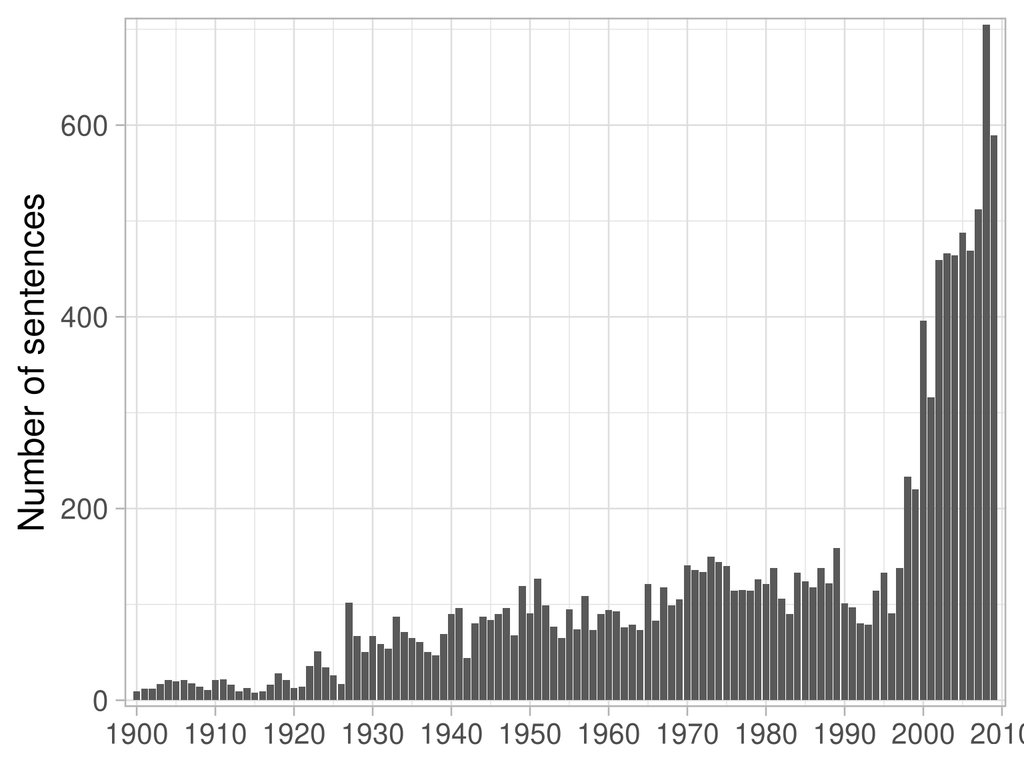

### Closest sentence from ‘rational’ and ‘rationality’ of the backbone community

| Sentence | Title | Year | Journal | Authors | Words Similarity |
| --- | --- | --- | --- | --- | --- |
| This concept was introduced by Simon [4], who states that the behavior of economic agents is “intendedly rational, but only limitedly so”. | Integration of production and logistics - in principle, in practice and in education | 2001 | International Journal of Production Economics | Chikán A. | 0.865 |
| Economic agents are assumed to be rational. | Exchange rate fluctuations and disaggregated economic activity in the US: Theory and evidence | 2002 | Journal of International Money and Finance | Kandil M. | 0.814 |
| Economic agents are assumed to be rational. | The effects of dollar appreciation on sectoral labor market adjustments: Theory and evidence | 2003 | Quarterly Review of Economics and Finance | Kandil M. | 0.813 |
| Economic agents are assumed to be rational. | The Effects of Exchange Rate Fluctuations on Output and Prices: Evidence from Developing Countries | 2005 | The Journal of Developing Areas | Ida Mirzaie, Magda Kandil | 0.813 |
| Economic agents are assumed to be rational. | The effects of exchange rate fluctuations on economic activity in Turkey | 2007 | Journal of Asian Economics | Kandil M. | 0.812 |
| Economic agents are assumed to be rational. | Comparative analysis of exchange rate appreciation and aggregate economic activity: Theory and evidence from Middle Eastern countries | 2008 | Bulletin of Economic Research | Kandil M. | 0.812 |
| Economics agents could be rational. | Controlling endogenous fluctuations of human capital investment in an OLG economy | 2009 | Economic Modelling | Dong C. | 0.805 |
| Economists often avoid addressing these assumptions by indicating that decision-makers need not behave rationally, they simply act “as if” they are rational. | Natural selection, rational economic behavior, and alternative outcomes of the evolutionary process | 2003 | Journal of Socio Economics | Frank J. | 0.803 |
| Much economic research is aimed at the conditions under which certain types of rationality are dominating, and what types of measures are feasible to affect this domination. | Behaviour in commons dilemmas: Homo economicus and Homo psychologicus in an ecological-economic model | 2000 | Ecological Economics | Jager W. | 0.802 |
| Economic agents are assumed to be boundedly rational, i.e. | Coevolution of economic and ecological systems an application to agricultural pesticide resistance | 2008 | Journal of Evolutionary Economics | Noailly J. | 0.798 |
| Empirical evidence from a broad base of economic behavior (Conlisk, 1996) shows that sometimes agents act as if they are unboundedly rational, sometimes they do not. | A political business cycle with boundedly rational agents | 2001 | European Journal of Political Economy | Sieg G. | 0.798 |
| The second assumption is that the economic actor is substantively rational (Simon, 1976 (pp. | Alternative models of individual behaviour and implications for environmental policy | 2000 | Ecological Economics | Van Den Bergh J.C.J.M. | 0.792 |
| As Thaler (1993) suggests in his introduction, “sometimes … it is necessary to entertain the possibility that some of the agents in the economy behave less than fully rationally some of the time”. | Efficiency of consumer intertemporal choice under life cycle cost conditions | 2002 | Journal of Economic Psychology | Liebermann Y. | 0.792 |
| which could be construed as rational only in the games of the theoretical economist. | [Competition, Contestability, and the Liner Shipping Industry (Comment and Rejoinder)](http://www.jstor.org/stable/20052882) | 1989 | Journal of Transport Economics and Policy | W. B. Jankowski, J. E. Davies | 0.788 |
| As Milgrom and Roberts (1992, p. 43) note:Paradoxically, the very imperfections in the rationality of people and in the adaptability of organizations denied by many simple economic theories are necess… | Assessing empirical research in managerial accounting: A value-based management perspective | 2001 | Journal of Accounting and Economics | Ittner C.D. | 0.785 |
| The main focus of this paper is on the conceptual development of ‘rationality’ in economic theory, viz. | Classical and neoclassical conceptions of rationality-Findings of an exploratory survey | 2008 | Journal of Socio Economics | Zafirovski M. | 0.785 |
| Leuthold and Hartmann Reply 587 are considered rational since they depend on the same things as suggested by economic theory and incorporate available information. | [A Semi-Strong Form Evaluation of the Efficiency of the Hog Futures Market: Reply](http://www.jstor.org/stable/1240221) | 1980 | American Journal of Agricultural Economics | Raymond M. Leuthold, Peter A. Hartmann | 0.784 |
| The central assumption of the model of rational irrationality is that agents perceive the price of irrationality without bias. | [Rational Irrationality: A Framework for the Neoclassical-Behavioral Debate](http://www.jstor.org/stable/40325987) | 2000 | Eastern Economic Journal | Bryan Caplan | 0.784 |
| Although a rationality test is beyond the scope of this paper, our results suggest that the data are consistent with economic agents behaving rationally. | Are US output expectations unbiased? A cointegrated VAR analysis in real time | 2006 | Economics Letters | Papaikonomou D. | 0.784 |
| First, as is common in economics, agents are rational. | Costly arbitrage and the myth of idiosyncratic risk | 2006 | Journal of Accounting and Economics | Pontiff J. | 0.784 |

### Closest sentences from ‘rational’ and ‘rationality’ of the HDBSCAN cluster

#### Closes sentences 4_6_1900-1919: adam_smith, adam, mill, mill’s, malthus (1900-1919)

| Sentence | Title | Year | Journal | Authors | Words Similarity |
| --- | --- | --- | --- | --- | --- |
| It was by fixing their attention on the principle of utility, as James Mill had counseled them, that these serious-minded reformers arrived at the conclusions which have here been described. | [The Early Propagandist Movement in English Population Theory](http://www.jstor.org/stable/1814928) | 1911 | The American Economic Review | James A. Field | 0.657 |
| Logically, the issue between Godwin and Malthus, between the Philosophic Radicals and the Conservatives of Mill’s day, between the Socialists and the ” Stand Patters ” of our own time, involves a diff… | [Human Behavior and Economics: A Survey of Recent Literature](http://www.jstor.org/stable/1885296) | 1914 | The Quarterly Journal of Economics | Wesley C. Mitchell | 0.651 |
| It is true, indeed, that in recent times this explanation of Mill has been further elaborated, as, for instance, in the suggested substitution by Professor Edgeworth and by Professor Carver of the pri… | The Progress of Taxation during the Past Twenty-Five Years, and Present Tendencies | 1910 | American Economic Association Quarterly | Edwin R. A. Seligman | 0.628 |
| Mill strongly objects to the quid-pro-quo theory, and lays down ihis genleral principle in the following words: “As in a case of voluntary sulbscription for a purpose in which all are interested, all … | Progressive Taxation in Theory and Practice | 1908 | American Economic Association Quarterly | E. R. A. Seligman | 0.626 |
| However, when the example of Mill is used to point a moral it must be remembered that his disastrous failure would largely have been due to his scrupulous provisions in defence of property already acq… | [The Incidence of Urban Rates III](http://www.jstor.org/stable/2956835) | 1900 | The Economic Journal | F. Y. Edgeworth | 0.626 |
| Schaffle unconsciously uses very much the same language as did Montesquieu more than a century earlier.21 It may be said in criticism of Schaffle that the reasons which he advances in defense of large… | Progressive Taxation in Theory and Practice | 1908 | American Economic Association Quarterly | E. R. A. Seligman | 0.617 |
| They compel me to reconsider my obiter dictum: ” It may well be doubted whether Mill entertained the notion of proportional sacrifice.” | [The Subjective Element in the First Principles of Taxation](http://www.jstor.org/stable/1885206) | 1910 | The Quarterly Journal of Economics | F. Y. Edgeworth | 0.611 |
| One represents a reversion to the looser, but more realistic, usages of Ricardo and of Mill’s Principles. | [The Rationality of Economic Activity: I](http://www.jstor.org/stable/1829775) | 1910 | Journal of Political Economy | Wesley C. Mitchell | 0.607 |
| To this “entire abstraction of every other human passion or motive” Mill admitted two classes of exceptions: (i) motives “which may be regarded as perpetually antagonizing principles to the desire of … | [The Rationality of Economic Activity: I](http://www.jstor.org/stable/1829775) | 1910 | Journal of Political Economy | Wesley C. Mitchell | 0.607 |
| The belief that it was a sound policy involves a theory of the stupidity of our ancestors, whereas, we are told, ” Bacon, in the discussion of economics, could have given J. S. Mill a very bad quarter… | [“Constructive Economics”](http://www.jstor.org/stable/2221384) | 1904 | The Economic Journal | George W. Gough | 0.601 |

#### Closes sentences 4_7_1900-1919: political_economy, labor_concept, spiritual_forces, marx, modern_science (1900-1919)

| Sentence | Title | Year | Journal | Authors | Words Similarity |
| --- | --- | --- | --- | --- | --- |
| To me it seems that the cultivation of the historical tendency in Political Economy only serves to bring the importance of logical method into stronger relief. | [Political Economy in Germany](http://www.jstor.org/stable/2221194) | 1905 | The Economic Journal | G. Cohn | 0.642 |
| For the conclusion, to which abstract theory conducted the signers of that pronouncement on a political problem of great delicacy and vital moment, appeared to me to be but a barren negation; and econ… | [Economic Theory and Fiscal Policy](http://www.jstor.org/stable/2221360) | 1904 | The Economic Journal | L. L. Price | 0.636 |
| But we clearly see that economic theory restrained them from taking that action which would have been dictated by their sympathies and which, indeed, science itself has subsequently come to approve. | Economic Theory and Labor Legislation | 1908 | American Economic Association Quarterly | Richard T. Ely | 0.623 |
| More important still, even if it cannot be called on for a judgment upon the larger questions concerned with the prevailing economic system, it is supposed to furnish the positive material upon which … | [The Place of Value Theory in Economics: I](http://www.jstor.org/stable/1821866) | 1918 | Journal of Political Economy | Walton H. Hamilton | 0.615 |
| If it is insisted that these forerunners of classical doctrine had no distinct speculations upon value, the obvious reply will be that this fact alone proves that they were not systems of economic tho… | [The Place of Value Theory in Economics: I](http://www.jstor.org/stable/1821866) | 1918 | Journal of Political Economy | Walton H. Hamilton | 0.609 |
| It is very fortunate that the reasoning here is expressed in mathematical form, Bertrand’s criticism notwithstanding; for there is less chance of dragging in new conditions, as is usually done when co… | [Paradoxes of Competition](http://www.jstor.org/stable/1883653) | 1906 | The Quarterly Journal of Economics | Henry L. Moore | 0.609 |
| They have only displayed confusion of thought about the true character of economic method, a confusion which, as I have already pointed out, is to-day hardly excusable in view of the light now thrown … | [Modern Logicians and Economic Methods](http://www.jstor.org/stable/2221171) | 1905 | The Economic Journal | R. B. Haldane | 0.604 |
| Not that he did not consciously accept and utilize certain established economic doctrines, such as the theory of land rent, but rather that all such had to be wrought over in his own thinking and thor… | [Jevons’ “Theory of Political Economy.”](http://www.jstor.org/stable/1804593) | 1912 | The American Economic Review | Allyn A. Young | 0.601 |
| But, if I read the history of economic thought aright, such an attitude and disposition had an unwholesome influence, even at a time when it could, perhaps, plead more justification in its behalf. | [The Practical Aspects of Economic](http://www.jstor.org/stable/2221425) | 1909 | The Economic Journal | L. L. Price | 0.601 |
| And while for most men a distinctly concrete handling of economic facts will prove more congenial, for the men who come to economics with a utilitarian purpose this more concrete method will be absolu… | [The Enlargement of Economics](http://www.jstor.org/stable/2220699) | 1908 | The Economic Journal | W. J. Ashley | 0.596 |

#### Closes sentences 4_12_1920-1929: religious, puritan, economic_life, economic_harmonies, religion (1920-1929)

| Sentence | Title | Year | Journal | Authors | Words Similarity |
| --- | --- | --- | --- | --- | --- |
| In particular, moral principles and unselfish motives are advanced as important factors in guiding the action of “the man whom God made,” constituting “the supreme motive in the market-place as elsewh… | [John Bates Clark: Earlier and Later Phases of his Work](http://www.jstor.org/stable/1885364) | 1927 | The Quarterly Journal of Economics | Paul T. Homan | 0.646 |
| So it would be true to say that if economics as a science were to be confined to the analysis of market phenomena, denying the significance of these phenomena as evidences of the nature of human condu… | [Human Nature in Economic Theory](http://www.jstor.org/stable/1822708) | 1922 | Journal of Political Economy | Rexford G. Tugwell | 0.643 |
| For whereas Mr. Hawtrey seems to regard this conclusion as a warrant for substituting as the criterion of economic action his conception of ethical value, most of us, I fancy, will feel that it is mer… | [Mr. Hawtrey on the Scope of Economics](http://www.jstor.org/stable/2548426) | 1927 | Economica | Lionel Robbins | 0.641 |
| About the only remaining aspect of the mechanistic view to occasion any marked difference of opinion is the extent to which logical deduction may lead to economic knowledge. | [Issues in Economic Theory: an Attempt to Clarify](http://www.jstor.org/stable/1884782) | 1928 | The Quarterly Journal of Economics | Paul T. Homan | 0.639 |
| Or one may be skeptical of the possibility of reducing the complicated and changing facts of modern economic life to a logically articulated system of general principles. | [The Impasse in Economic Theory](http://www.jstor.org/stable/1822132) | 1927 | Journal of Political Economy | Paul T. Homan | 0.637 |
| So the doctrine of economic harmonies, while definitely misleading in some of its implications and childish in its extreme forms, was not necessarily a hindrance in the early stages of the search for … | [Economics and the Idea of Natural Laws](http://www.jstor.org/stable/1885439) | 1929 | The Quarterly Journal of Economics | O. H. Taylor | 0.636 |
| Of course, if economics is, by definition, to be confined to the investigation of market phenomena and generalizations from these facts alone, there is some justification for the attempt to escape the… | [Human Nature in Economic Theory](http://www.jstor.org/stable/1822708) | 1922 | Journal of Political Economy | Rexford G. Tugwell | 0.636 |
| Some sort of order or balance was discernible in this new economic system, though not an order imposed upon it from above, and not necessarily an order conforming to some rational (or, in the old sens… | [English Political Economy](http://www.jstor.org/stable/2548381) | 1928 | Economica | Allyn A. Young | 0.635 |
| cal economists and their seventeenth- and eighteenth-century predecessors used the ideas of physical science to explain economic actions and events in a way that logically precluded the application to… | [Tawney’s Religion and Capitalism, and Eighteenth-Century Liberalism](http://www.jstor.org/stable/1884888) | 1927 | The Quarterly Journal of Economics | Overton H. Taylor | 0.629 |
| It is fundamental, in his view, that economic reasoning should start from a correct view of human nature, since the voluntary action of men is the basis of economic law. | [John Bates Clark: Earlier and Later Phases of his Work](http://www.jstor.org/stable/1885364) | 1927 | The Quarterly Journal of Economics | Paul T. Homan | 0.619 |

#### Closes sentences 4_4_1920-1929: adam_smith, adam, moral_sentiments, smith, nations (1920-1929)

| Sentence | Title | Year | Journal | Authors | Words Similarity |
| --- | --- | --- | --- | --- | --- |
| If the ” intention ” of ” the Author of the world,” or of ” Nature,” is shown by the provision of particular physical resources, it can hardly be supposed proper to allow it to be indefinitely ” count… | [A Retrospect of Free-Trade Doctrine](http://www.jstor.org/stable/2223376) | 1924 | The Economic Journal | William Ashley | 0.650 |
| The broaching of this subject really requires a discussion which cannot be entered upon here, of the whole matter of the relations of Hobbes, Locke, Hume, Bentham, Ricardo, James Mill, and John Stuart… | [Human Nature in Economic Theory](http://www.jstor.org/stable/1822708) | 1922 | Journal of Political Economy | Rexford G. Tugwell | 0.646 |
| Looked at from this standpoint, Mill’s principle appears less true and more naive than ” the surviving relic of the Mercantile Theory.” | [The Theory of International Trade Reconsidered](http://www.jstor.org/stable/2224539) | 1929 | The Economic Journal | John H. Williams | 0.643 |
| Researches with respect to the utilization of land show us that by and large we come by what unaided nature furnishes with constantly decreasing human costs, whereas John Stuart Mill and the classical… | [The New Economic World and the New Economics](http://www.jstor.org/stable/3139031) | 1929 | The Journal of Land & Public Utility Economics | Richard T. Ely | 0.627 |
| Following the letter of Adam Smith too closely, they applied abstract reasoning on the basis of purely commercial mechanics to a situation rendered highly complex and abnormal by political considerati… | [Financial and Monetary Policy of Great Britain During the Napoleonic Wars](http://www.jstor.org/stable/1882330) | 1924 | The Quarterly Journal of Economics | Norman J. Silberling | 0.626 |
| The unquestionable contributions of the Physiocrats and of Adam Smith to the understanding by their contemporaries, of economic phenomena as mechanically related, would suggest that their use of the c… | [Fourier and Anarchism](http://www.jstor.org/stable/1884047) | 1928 | The Quarterly Journal of Economics | E. S. Mason | 0.612 |
| It is a commonplace among the authorities on Adam Smith that it is impossible fully to understand the Wealth of Nations without recourse to the Theory of Moral Sentiments. | [Adam Smith and Laissez Faire](http://www.jstor.org/stable/1823421) | 1927 | Journal of Political Economy | Jacob Viner | 0.612 |
| The application of this “principle of population”-even the term had been used by Arthur Young and by Godwin” -in opposition to schemes of social regeneration had become so familiar that the later poli… | [Adam Smith 1776-1926](http://www.jstor.org/stable/1823420) | 1927 | Journal of Political Economy | Jacob H. Hollander | 0.611 |
| But the reader will recall that the Physiocrats, and Adam Smith, believed not only that there are causal ” laws of nature ” which control the course of events in the universe at large and in society, … | [Economics and the Idea of Natural Laws](http://www.jstor.org/stable/1885439) | 1929 | The Quarterly Journal of Economics | O. H. Taylor | 0.610 |
| Or if I have not yet made my meaning clear, look again into the Wealth of Nations, and ask yourself how much of the power of that book comes from Adam Smith’s ability to take a broad and general view,… | [Economics as a Field of Research](http://www.jstor.org/stable/1885362) | 1927 | The Quarterly Journal of Economics | Allyn A. Young | 0.610 |

#### Closes sentences 4_15_1930-1939: marx, mercantilist, science, economics, marx’s (1930-1939)

| Sentence | Title | Year | Journal | Authors | Words Similarity |
| --- | --- | --- | --- | --- | --- |
| This general principle applies with especial force to economics, if we grant that it is highly desirable to keep economics ” scientific.” | [“Economic Welfare”](http://www.jstor.org/stable/2548228) | 1930 | Economica | F. C. Benham | 0.670 |
| But these two statements are not yet sufficient to condemn the classical methods of mathematical economics as an arbitrary transgression of the limits of human reason. | [II](http://www.jstor.org/stable/2967553) | 1934 | The Review of Economic Studies | Harro Bernardelli | 0.664 |
| of some of the postulates of pure theory (see paragraph 5 below) phrases may have been used-the ” logic of choice “,” deduction from the nature of the economic “, for instance -which, to those who are… | [Live and Dead Issues in the Methodology of Economics](http://www.jstor.org/stable/2548633) | 1938 | Economica | Lionel Robbins | 0.635 |
| Such an approach would also show that we need not share the pessimism of those economists who fear that economic regulation and economic planning are necessarily bound up with an irrational, uneconomi… | [Economic Regulation and Economic Planning](http://www.jstor.org/stable/1804163) | 1939 | The American Economic Review | Karl W. Kapp | 0.630 |
| This does not mean that we find them all equally well founded, or even that his central idea, namely, that in price movements lies the cause of economic progress, seems to us so solidly established as… | [François Simiand’s Theory of Economic Progress](http://www.jstor.org/stable/2967444) | 1938 | The Review of Economic Studies | Robert Marjolin, G. Jaffé, W. Jaffé | 0.627 |
| On the contrary, the existing body of economic principles is the result of careful thinking based upon a few facts of general observation. | [The Scope and Definition of Economics](http://www.jstor.org/stable/1824178) | 1939 | Journal of Political Economy | Raymond T. Bye | 0.625 |
| It would seem that so great a multitude and variety of phenomena as make up our economic universe would admit of at least two methods of explanation. | [Economic Theory–Institutionalism: What It Is and What It Hopes to Become](http://www.jstor.org/stable/1802980) | 1931 | The American Economic Review | Paul T. Homan, M. A. Copeland, Eveline M. Burns, J. J. Spengler, O. H. Taylor, William Jaffé | 0.623 |
| Such decomposition constituted the essence of traditional economics, which has used this analysis as a means of passing ethical judgments, of evaluating changes, and sometimes of forecasting future de… | [Static and Dynamic Economics](http://www.jstor.org/stable/1802588) | 1930 | The American Economic Review | Simon Kuznets | 0.621 |
| however carefully determined, there is room in interpreting it for economic theory and common sense. | [The Processing Taxes and Some Problems Raised by Them](http://www.jstor.org/stable/1230751) | 1935 | Journal of Farm Economics | M. Slade Kendrick | 0.620 |
| This statement cannot, however, be taken to mean that every business transaction is conducted in accordance with the economic principle and is thus subject to an economic explanation. | [On the Subject-Matter and Method of Economic Science](http://www.jstor.org/stable/2548905) | 1933 | Economica | Felix Kaufmann | 0.616 |
| Another reason was that economic problems have most of the time been approached in a practical spirit, either indifferent or hostile to the claims of scientific habits of thought. | [The Common Sense of Econometrics](http://www.jstor.org/stable/1912225) | 1933 | Econometrica | Joseph Schumpeter | 0.616 |
| But to take this suggestion up and examine it, to explore its significance for the methodological problem that is supposed to be under discussion, would necessitate an abandonment of the pastime of sh… | [Equilibrium Economics and Business-Cycle Theory: A Commentary](http://www.jstor.org/stable/1882527) | 1930 | The Quarterly Journal of Economics | R. W. Souter | 0.616 |
| Later, when this view was no longer fashionable, there was still a tendency to confuse description with justification, merely because, perhaps, the discovery of orderly laws characterizing the economi… | [The Scope and Definition of Economics](http://www.jstor.org/stable/1824178) | 1939 | Journal of Political Economy | Raymond T. Bye | 0.616 |

#### Closes sentences 4_16_1930-1939: malthus, adam_smith, adam, mill’s, montesquieu (1930-1939)

| Sentence | Title | Year | Journal | Authors | Words Similarity |
| --- | --- | --- | --- | --- | --- |
| The Malthusian objection to Godwin is that reason cannot easily control the sexual appetite, but no one denied at least an important “instrumental” role to reason, especially in the economic sphere. | [Economics and Sociology: Marshall in Relation to the Thought of His Time](http://www.jstor.org/stable/1883233) | 1932 | The Quarterly Journal of Economics | Talcott Parsons | 0.623 |
| Burke opposed the abstract “natural right” theories of the French philosopher, but had his own theory of the way in which “Nature” instructs mankind in the evolution of sound institutions - chiefly th… | [Economics and the Idea of Jus Naturale](http://www.jstor.org/stable/1885248) | 1930 | The Quarterly Journal of Economics | O. H. Taylor | 0.612 |
| But, if the premises of the general law are not complete, a knowledge of the supplementary premises will only give the* result, if the missing link is included in the supplementary premises.2 Thus in … | [Nassau Senior’s Contribution to the Methodology of Economics](http://www.jstor.org/stable/2549222) | 1936 | Economica | Marian Bowley | 0.612 |
| As long as wealth was confined to material goods the necessity of the hypothesis of the economic man, though unperceived by anyone before J. S. Mill, was a fact, since it is impossible to deny the inf… | [Nassau Senior’s Contribution to the Methodology of Economics](http://www.jstor.org/stable/2549222) | 1936 | Economica | Marian Bowley | 0.602 |
| In justice to Mill it must be remembered that he safeguarded himself by regarding his statement as a hypothesis, but Cairnes took Mill’s statement as a positive premnise, qualifying it by saying that … | [Nassau Senior’s Contribution to the Methodology of Economics](http://www.jstor.org/stable/2549222) | 1936 | Economica | Marian Bowley | 0.601 |
| It seems to us, however, that, despite the misconceptions concerning scientific method entertained by Mill, his distinction between the inductively verified propositions of the natural sciences, on th… | [Werner Sombart and the “Natural Science Method” in Economics](http://www.jstor.org/stable/1821691) | 1933 | Journal of Political Economy | Leo Rogin | 0.601 |
| 63 It is noteworthy that Ricardo employs the word ” reason ” and not the word ” cause “-which indicates that he must have felt that the proposition is purely rational (formal) and not causal. | [The Ricardian Theory of Profits](http://www.jstor.org/stable/2548861) | 1933 | Economica | Victor Edelberg | 0.599 |
| natural” institutions, is to be achieved by the normal operation of the instincts and feelings of men, supplemented by their intelligence as that may work in the spheres in which it is effective, puts… | [Economics and the Idea of Jus Naturale](http://www.jstor.org/stable/1885248) | 1930 | The Quarterly Journal of Economics | O. H. Taylor | 0.598 |
| With Mill again the problem as to which line of conduct will yield “the greater portion of wealth” is not mentioned as existing, and his principle that men “naturally” prefer this to a smaller portion… | [Expectation and Rational Conduct](http://www.jstor.org/stable/41793308) | 1937 | Zeitschrift für Nationalökonomie / Journal of Economics | T. W. Hutchison | 0.589 |
| To John Stuart Mill, deeply as he disliked it, it formed along with “diminishing returns”, the principal truth of Political Economy. | [What is Left of Adam Smith?](http://www.jstor.org/stable/136597) | 1935 | The Canadian Journal of Economics and Political Science / Revue canadienne d’Economique et de Science politique | Stephen Leacock | 0.588 |

#### Closes sentences 4_16_1940-1949: socialism, marx, socialist, faire, economic_science (1940-1949)

| Sentence | Title | Year | Journal | Authors | Words Similarity |
| --- | --- | --- | --- | --- | --- |
| the less, I think a strong case could be made out for the continuity of common sense in the criticism of the economic motive in man, and in the discussion how best both to recognize its necessity and … | [The Economic Motive in Politics](http://www.jstor.org/stable/2590472) | 1946 | The Economic History Review | F. M. Powicke | 0.682 |
| Perhaps the Physiocrats’ concept of economics can be clarified, then, by seeing what method of reasoning they considered proper for the elucidation of economic truths. | [The Physiocrats’ Concept of Economics](http://www.jstor.org/stable/1882137) | 1949 | The Quarterly Journal of Economics | Thomas P. Neill | 0.662 |
| Though psychological analysis may one day reveal to us the subconscious rationality of such actions, we must in the meantime-as far as economics is concerned-regard such behaviour as amenable to indiv… | [The Meaning of Rationality: A Note on Professor Lange’s Article](http://www.jstor.org/stable/2295759) | 1946 | The Review of Economic Studies | K. W. Rothschild | 0.657 |
| But into everything that was not a theorem in the pure logic of economics the whole man and all the forces that conditioned him entered so unmistakably that it is more necessary than it usually is in … | [Vilfredo Pareto (1848-1923)](http://www.jstor.org/stable/1883096) | 1949 | The Quarterly Journal of Economics | Joseph A. Schumpeter | 0.649 |
| For scientific generalizations in economics are possible only if human behavior can be assumed to be sufficiently regular and determined by relatively simple motives. | [Rational Human Conduct and Modern Industrial Society](http://www.jstor.org/stable/1052713) | 1943 | Southern Economic Journal | Karl W. Kapp | 0.638 |
| Whatever the merits of mangements’ claim that it sees the economic picture in its entirety, we can hardly be content with unilateral determination of controverted issues. | [Agriculture in a Stabilized Economy](http://www.jstor.org/stable/1232809) | 1949 | Journal of Farm Economics | Edwin G. Nourse | 0.638 |
| But for political economy the method remained deductive, “reasoning from one law of human nature” and from “the principal outward circumstances (whether universal or confined to particular states of s… | [John Stuart Mill’s Principles: A Centenary Estimate](http://www.jstor.org/stable/1831728) | 1949 | The American Economic Review | Vincent W. Bladen | 0.634 |
| Nor is it enough to claim that non-economic motives are contained in the ceteris paribus of the demand and supply schedules, and then to carry out the analysis solely on the basis of self-interest. | [The Welfare Economics of Heinrich Pesch](http://www.jstor.org/stable/1882259) | 1949 | The Quarterly Journal of Economics | Richard E. Mulcahy, S.J. | 0.633 |
| Cunningham had stated the underlying assumption against which he protested, viz., “that the same motives have been at work in all ages and have produced similar results, and that therefore it is possi… | [Mill to Marshall: The Conversion of the Economists](http://www.jstor.org/stable/2113779) | 1941 | The Journal of Economic History | V. W. Bladen | 0.633 |
| Such actions, however, are based on forces which are explainable within the framework of economic behavior. | [Economics of Soil Conservation: I. Individual and Social Considerations](http://www.jstor.org/stable/3158913) | 1943 | The Journal of Land & Public Utility Economics | E. C. Weitzell | 0.632 |

#### Closes sentences 4_18_1950-1959: soviet, marxian, soviet_planners, economist, socialism (1950-1959)

| Sentence | Title | Year | Journal | Authors | Words Similarity |
| --- | --- | --- | --- | --- | --- |
| Still this should not render us purblind to the fact that what he presented as a “matter-offact” inquiry into “brute” causation is substantially a critique of existing economic institutions and theori… | [Veblen and the Social Phenomenon of Capitalism](http://www.jstor.org/stable/1910777) | 1951 | The American Economic Review | Abram L. Harris | 0.716 |
| To deny any influence to economic analysis is to deny any role to reason in the formation by a sensible man of his system of ends. | [Schumpeter’s History of Economic Analysis](http://www.jstor.org/stable/1807709) | 1954 | The American Economic Review | Jacob Viner | 0.698 |
| Failure to grant such extension has not stopped the Soviet leadership from relying on some of the tools of rational decision advocated by Soviet economists-for instance, in the important area of inves… | [The Soviet Industrial Reorganization of 1957](http://www.jstor.org/stable/1816103) | 1959 | The American Economic Review | Oleg Hoeffding | 0.656 |
| The theory of economics acquires in this way the rigidity of rational mechanics. | [Individualism and Economic Theory](http://www.jstor.org/stable/3483667) | 1950 | The American Journal of Economics and Sociology | Walter A. Weisskopf | 0.654 |
| Emphasis is not on whether the assumptions or criteria are correct but whether the economic logic is true. | [Increasing Farmers’ Understanding of Public Problems and Policies](http://www.jstor.org/stable/1234034) | 1955 | Journal of Farm Economics | J. Carroll Bottum | 0.642 |
| I think it showed also a lack of imagination: no economic problem has only one avenue of approach; and the nonand semimathematical utility theorists could have pursued inquiries suggested by theories … | [The Development of Utility Theory. II](http://www.jstor.org/stable/1825710) | 1950 | Journal of Political Economy | George J. Stigler | 0.642 |
| Some students of the development of economic thought have even suggested that the various economic doctrines which have gained prominence were intended - deliberately or unconsciously - to rationalize… | [Prolegomena to a History of Economic Reasoning](http://www.jstor.org/stable/1879498) | 1951 | The Quarterly Journal of Economics | Karl Pribram | 0.637 |
| However, such isolated arguments were soon to be integrated into a more or less consistent system of economic theory. | [Natural Law and the Rise of Economic Individualism in England](http://www.jstor.org/stable/1826729) | 1951 | Journal of Political Economy | Alfred F. Chalk | 0.631 |
| Economic theory does not lack instances of elaborate reasoning based on completely unrealistic assumptions. | [The Institutional Saving-Investment Process and Current Economic Theory](http://www.jstor.org/stable/1818358) | 1954 | The American Economic Review | James J. O’Leary | 0.628 |
| But this was the nature of classical economics. | [The Macro and Micro Aspects of the Wealth of Nations](http://www.jstor.org/stable/1054159) | 1954 | Southern Economic Journal | John P. Henderson | 0.625 |

#### Closes sentences 4_11_1950-1959: malthus, malthus’s, adam_smith, ricardo’s, ricardo (1950-1959)

| Sentence | Title | Year | Journal | Authors | Words Similarity |
| --- | --- | --- | --- | --- | --- |
| When we consider the relevance of the ‘prudent’ man, who in the Wealth of Nations appears as Mill’s ‘economic man’, we shall see that Smith did give the prudent man a rational place in his system of t… | [Adam Smith’s Moral Sentiments as Foundation for His Wealth of Nations](http://www.jstor.org/stable/2661906) | 1959 | Oxford Economic Papers | A. L. Macfie | 0.609 |
| economics which Mill tried to defend, or rather the naturalistic economics, were never to be considered to have been based on a way of thinking peculiar to social sciences, because its fundamental sta… | On Historical Research in Social Sciences | 1952 | Kyoto University Economic Review | Yūzo Deguchi | 0.603 |
| Thus, if I may restate in more contemporary terms a famous argument of Mill, it might be held that because of inherent psychological interrelatedness each of us would ultimately be better off as a Uti… | [On the Concept of Social Welfare](http://www.jstor.org/stable/1884448) | 1954 | The Quarterly Journal of Economics | Abram Bergson | 0.601 |
| Adam Smith would not have flinched from the interpersonal comparison or from the assumption that the marginal utility of an addition to (or, at any rate, subtraction from) the greater fortune was less… | [Adam Smith’s Approach to the Theory of Value](http://www.jstor.org/stable/2227781) | 1957 | The Economic Journal | H. M. Robertson, W. L. Taylor | 0.600 |
| This glut of commodities would cause such a reduction of profits ” as very greatly to diminish both the power and the will to save .2 This somewhat precarious thesis Malthus endeavoured to support wit… | [Physiocracy and the Early Theories of Under-Consumption](http://www.jstor.org/stable/2550037) | 1951 | Economica | Ronald L. Meek | 0.600 |
| Lack of logic can hardly be imputed to an intellect as powerful as Ricardo’s; nor can as astute an observer as Adam Smith be accused of lack of realism. | [The Psychocultural Background of Adam Smith’s Theory of Value](http://www.jstor.org/stable/3484609) | 1952 | The American Journal of Economics and Sociology | Walter A. Weisskopf | 0.600 |
| III Quesnay’s view of profits, then, was rather more sensible and consistent than is commonly appreciated, given the assumptions of the Tableau and the particular model of the economy which he adopted… | [The Physiocratic Concept of Profit](http://www.jstor.org/stable/2551489) | 1959 | Economica | Ronald L. Meek | 0.596 |
| Thus, the pure essence of economic reasoning was abstracted from preoccupation with all sorts of tliings having to do with the material and moral welfare of man, as may be seen in Adam Smith’s The Wea… | [Mistakes at Work](http://www.jstor.org/stable/137687) | 1951 | The Canadian Journal of Economics and Political Science / Revue canadienne d’Economique et de Science politique | Everett C. Hughes | 0.590 |
| Of course, if we interpret this position as chiefly involving the assumption of an absolute standard of value, on the lines attacked by Bailey4, and the peculiar doctrine regarding the relation betwee… | [Schumpeter’s History of Economic Analysis](http://www.jstor.org/stable/1884847) | 1955 | The Quarterly Journal of Economics | Lionel Robbins | 0.588 |
| It is possible, however, to avoid much unnecessary controversy by separating the question whether the Malthusian theory constitutes an internally consistent, logically valid conceptual scheme from the… | [Malthus and the Underdeveloped Areas](http://www.jstor.org/stable/2227784) | 1957 | The Economic Journal | E. F. Penrose | 0.577 |

#### Closes sentences 4_16_1960-1969: benefit_cost, economic_postulates, economic_analysis, cost_ratio, economic_theory (1960-1969)

| Sentence | Title | Year | Journal | Authors | Words Similarity |
| --- | --- | --- | --- | --- | --- |
| Some theorists have replied that economic theory is valid only as a broad tendency, not in each specific instance; some noted that the “proof of the pudding is in the eating,” and argued that this the… | [Irrational Behavior and Economic Theory](http://www.jstor.org/stable/1827018) | 1962 | Journal of Political Economy | Gary S. Becker | 0.669 |
| to a largely rational group is some measure of effectiveness as indicated by cost-benefit ratios. | [Some Questions for Economists and Society about Adult Education](http://www.jstor.org/stable/1237302) | 1968 | American Journal of Agricultural Economics | C. B. Ratchford | 0.668 |
| First, evaluations of this sort do contain an important, even an essen tial, element of economic reasoning, or at least the kind of reasoning that comes more readily to economists than to many other p… | [Economic Reasoning and Military Science](http://www.jstor.org/stable/25602533) | 1960 | The American Economist | T. C. Schelling | 0.666 |
| Being an exercise in economic logic, the inference we draw from our postulates must be based on ” sound ” logic. | [The Ohlin-Heckscher Theory of the Basis of Commodity Trade](http://www.jstor.org/stable/2228580) | 1963 | The Economic Journal | J. L. Ford | 0.666 |
| Furthermore, it is seldom as economically rational as would appear from the description. | [Income and Price Policy in Swedish Agriculture since World War II](http://www.jstor.org/stable/1236341) | 1965 | Journal of Farm Economics | Lars G. Sandberg | 0.666 |
| Much discussion tacitly assumes this principle, and many practical decisions by business men and by the Federal Reserve System are obviously based on it; yet, because it is not explicit, it too often … | [The Recognition-Lag and Semi-Automatic Stabilizers](http://www.jstor.org/stable/1923898) | 1963 | The Review of Economics and Statistics | Rendigs Fels | 0.665 |
| However, the nature of much basic economic theory is not directly evident from casual common sense reasoning. | A Note on Quasi-Programming in Economic Principles Instruction | 1965 | Nebraska Journal of Economics and Business | John H. Wicks | 0.641 |
| Such a justification was expected more from the point of view of practical utility than from a causal system supported by economic theory. | [A New Look Into and Beyond Traditional Methods of Seasonal Adjustment](http://www.jstor.org/stable/23480066) | 1969 | Business Economics | Harry M. Rosenblatt | 0.632 |
| Such an interpretation gives a larger consistency to what is otherwise, through the eyes of traditional classical economics, a bewildering pattern of inconsistency. | [Robert Torrens: Colonel of Marines and Political Economist](http://www.jstor.org/stable/2551551) | 1962 | Economica | Frank Whitson Fetter | 0.628 |
| Thus, of these two measures, the netted benefit-cost ratio is clearly the more rational one; the use of the aggregate benefit-cost ratio has to be condemned’ as violating some basic rules of sound eco… | [A Comparative Analysis of the Net Present Value and the Benefit-Cost Ratio as Measures of the Economic Desirability of Investments](http://www.jstor.org/stable/2325349) | 1969 | The Journal of Finance | Bernhard Schwab, Peter Lusztig | 0.625 |
| Perhaps it is an indication of the lagging of the other social sciences behind economics that the proposal was dismissed as “too logical.” | [Employment Theory and Employment Policy](http://www.jstor.org/stable/1821604) | 1967 | The American Economic Review | Abba P. Lerner | 0.625 |
| Generally this assumption will be contradicted by the facts, so its maintenance by rational economic agents is untenable. | [On Experimental Research in Oligopoly](http://www.jstor.org/stable/2296467) | 1969 | The Review of Economic Studies | J. W. Friedman | 0.625 |

#### Closes sentences 4_13_1970-1979: neoclassical, externalities, cost_benefit, economics, economist (1970-1979)

| Sentence | Title | Year | Journal | Authors | Words Similarity |
| --- | --- | --- | --- | --- | --- |
| It is legitimate for an economist to analyze what the rational inferences in regard to economic policy would be from the value premises of what is in people’s true interests and their acclaimed ideals… | [The Equality Issue in World Development](http://www.jstor.org/stable/3439336) | 1975 | The Swedish Journal of Economics | Gunnar Myrdal | 0.658 |
| Quantity changes do not have this same zero-sum character, and a presumption that exogenous events, rather than strategic purposes, are responsible for the adjustment is ordinarily warranted. | Obligational Markets and the Mechanics of Inflation | 1978 | The Bell Journal of Economics | Oliver E. Williamson, Michael L. Wachter | 0.648 |
| intellectual currents, but he expected even dissenting economists to accept the principles of price theory which rationalize business enterprise. | [The Alternative Paths to Theory of Clark and Ayres](http://www.jstor.org/stable/4224610) | 1977 | Journal of Economic Issues | Baldwin Ranson | 0.648 |
| In reality the “externalities” of orthodox economic analysis (premised on departures from ideal Paretian allocations) can be used to rationalize ex post just about any state action. | [The Information Explosion, Technological Innovativeness and the Competitive Ethic](http://www.jstor.org/stable/3145311) | 1972 | Land Economics | Thomas Havrilesky | 0.642 |
| All this is familiar economic reasoning. | [Ownership and Distribution of Land](http://www.jstor.org/stable/29794042) | 1970 | Indian Economic Review | K. N. Raj | 0.637 |
| However, some economically based objections may be grounded in facts. | [Work, Employment and the Disabled](http://www.jstor.org/stable/3485573) | 1972 | The American Journal of Economics and Sociology | Saad Z. Nagi, William H. McBroom, John Collette | 0.637 |
| It is, as a matter of fact, the 1 x 1 of economic reasoning. | [THE LOGIC OF MARKET BEHAVIOUR](http://www.jstor.org/stable/40728442) | 1975 | Acta Oeconomica | A. Bródy | 0.634 |
| be a view of human nature on which explanations are based, that view is itself an assumption and only leads to value judgments with an additional normative principle saying something about the importa… | [Explanation and Value in Economics](http://www.jstor.org/stable/4224885) | 1979 | Journal of Economic Issues | Timothy J. Brennan | 0.632 |
| If income redistribution is an important goal, then decision makers might quite “rationally” choose projects which fail cost-benefit standards. | On the Decline and Possible Fall of PPBS | 1973 | Public Finance Review | Harlow R. | 0.627 |
| The conspicuous failure to use the method in pure-trade situations is probably rational in some cases. | [A Game of Fair Division](http://www.jstor.org/stable/2297064) | 1977 | The Review of Economic Studies | Vincent P. Crawford | 0.623 |

#### Closes sentences 4_2_1980-1989: neoclassical, neoclassical_economics, physics, model, rationality (1980-1989)

| Sentence | Title | Year | Journal | Authors | Words Similarity |
| --- | --- | --- | --- | --- | --- |
| which could be construed as rational only in the games of the theoretical economist. | [Competition, Contestability, and the Liner Shipping Industry (Comment and Rejoinder)](http://www.jstor.org/stable/20052882) | 1989 | Journal of Transport Economics and Policy | W. B. Jankowski, J. E. Davies | 0.788 |
| Leuthold and Hartmann Reply 587 are considered rational since they depend on the same things as suggested by economic theory and incorporate available information. | [A Semi-Strong Form Evaluation of the Efficiency of the Hog Futures Market: Reply](http://www.jstor.org/stable/1240221) | 1980 | American Journal of Agricultural Economics | Raymond M. Leuthold, Peter A. Hartmann | 0.784 |
| Of course, in a way, it doesn’t really much matter because if one is discussing how people will react to certain economic changes, a change in the price of commodities for instance, one doesn’t have t… | [An Accountant Among Economists: Conversations with Sir John R. Hicks](http://www.jstor.org/stable/1942917) | 1989 | The Journal of Economic Perspectives | Arjo Klamer | 0.753 |
| Generally, there is very little said about what it means for economic agents to be rational. | [Observations on the Use of Textbooks in the Teaching of Principles of Economics](http://www.jstor.org/stable/1182286) | 1988 | The Journal of Economic Education | Michael J. Boskin | 0.749 |
| Economic consequence theories assume rational behavior by economic agents. | The economic consequences of accounting choice implications of costly contracting and monitoring | 1983 | Journal of Accounting and Economics | Holthausen R.W. | 0.741 |
| How Rational Are Economic Agents? | [Rational Models of Irrational Behavior](http://www.jstor.org/stable/1805441) | 1987 | The American Economic Review | George A. Akerlof, Janet L. Yellen | 0.735 |
| Requiring agents to behave rationally is a well-established ground rule of most research in neoclassical economics; common wisdom holds that any behavior is compatible with irrationality, hence irrati… | [Axiomatic Characterizations of Rational Choice in Strategic Environments](http://www.jstor.org/stable/3440381) | 1986 | The Scandinavian Journal of Economics | B. Douglas Bernheim | 0.733 |
| Nonetheless, the rational approach to economics would seem to favor consistent conjectures over the price-taking assumption. | [Equilibrium and Optimality in a Mean-Variance Model](http://www.jstor.org/stable/2555632) | 1986 | The RAND Journal of Economics | Robert M. Costrell | 0.729 |
| This means that economic behavior is assumed to take the form of rational responses to clearly perceived stimuli. | [Structure and Behavior in Classical and Neo-Classical Theory](http://www.jstor.org/stable/40324903) | 1984 | Eastern Economic Journal | Edward Nell | 0.729 |
| If it were not equitable, there would be no such consensus.23 The analysis deems all individual economic activity to be rational. | [Economics for What? Economic Folklore and Social Realities](http://www.jstor.org/stable/4226133) | 1989 | Journal of Economic Issues | Edythe S. Miller | 0.725 |
| Most economic theorising presumes rational behaviour, with actions resulting from the constrained optimisation of some objective function. | The determination of implicit preferences. Two Possible Approaches Compared | 1982 | European Economic Review | Ancot J. | 0.725 |

#### Closes sentences 4_11_1990-1999: neoclassical_economics, neoclassical, economics, mainstream, economists (1990-1999)

| Sentence | Title | Year | Journal | Authors | Words Similarity |
| --- | --- | --- | --- | --- | --- |
| The problem of pure economics bears a striking likeness to that of rational mechanics. | [An Essay on the Origin of the Rational Utility Maximization Hypothesis and a Suggested Modification](http://www.jstor.org/stable/40325751) | 1997 | Eastern Economic Journal | Ken McCormick | 0.673 |
| This does not amount to saying that the abstract rationality approach is the only possible way of theoretically generalizing about economic phenomena. | [Rationality, Bounded or not, and Institutional Analysis](http://www.jstor.org/stable/40751359) | 1990 | Journal of Institutional and Theoretical Economics (JITE) / Zeitschrift für die gesamte Staatswissenschaft | Ekkehart Schlicht | 0.669 |
| There are a number of interesting economic hypotheses that are subsumed by formulation (4) or (5). | Testing exact rational expectations in cointegrated vector autoregressive models | 1999 | Journal of Econometrics | Johansen S. | 0.663 |
| When a modeler makes unrealistic assumptions that assume away the economic rationale for an object to exist, one may assert that the existence of those objects challenges the robustness of these assum… | What happened to the utility functions?: Imprecise expectations of security prices | 1999 | International Review of Financial Analysis | Kane S. | 0.657 |
| This explanation has the undesirable property of being inconsistent with the theory of rational behavior, which forms the core of economic theory. | Real interest rates and the distribution effects of unanticipated inflation | 1990 | Journal of Macroeconomics | Hayford M. | 0.656 |
| Looking more closely at the model and at the results, there is no doubt that the idea to combine advantages of two basically contrary ways of economic thought is only possible in combination with a su… | When is rational behavior consistent with rules of thumb? a link between evolutionary terminology and neoclassical methodology | 1999 | Journal of Mathematical Economics | Blonski M. | 0.656 |
| A natural question on a formal level is then to describe the conditions on the economic fundamentals which will insure that such an intuitive property will hold. | Monotonicity of equilibrium prices with respect to aggregate resources | 1998 | Economics Letters | Préchac C. | 0.655 |
| Rather this paper assumes the truth of the more nuanced conception of economic behavior articulated by Sen (1977), among others. | The volunteer’s folly and socio-economic man: Some thoughts on altruism, rationality, and community | 1999 | Journal of Socio Economics | Knox T.M. | 0.644 |
| The position adopted in this note is that while there are limits to the economic calculus, i.e. | Ecosystem services value, research needs, and policy relevance: A commentary | 1998 | Ecological Economics | Turner R.K. | 0.642 |
| This reconsideration of their model is of interest not only to historians of economic thought. | Unanimity and majority rule: The calculus of consent reconsidered | 1998 | European Journal of Political Economy | Guttman J. | 0.641 |

#### Closes sentences 4_6_2000-2009: behavioral_economics, neoclassical, neoclassical_economics, economic_intuition, mainstream (2000-2009)

| Sentence | Title | Year | Journal | Authors | Words Similarity |
| --- | --- | --- | --- | --- | --- |
| This concept was introduced by Simon [4], who states that the behavior of economic agents is “intendedly rational, but only limitedly so”. | Integration of production and logistics - in principle, in practice and in education | 2001 | International Journal of Production Economics | Chikán A. | 0.865 |
| Economic agents are assumed to be rational. | Exchange rate fluctuations and disaggregated economic activity in the US: Theory and evidence | 2002 | Journal of International Money and Finance | Kandil M. | 0.814 |
| Economic agents are assumed to be rational. | The effects of dollar appreciation on sectoral labor market adjustments: Theory and evidence | 2003 | Quarterly Review of Economics and Finance | Kandil M. | 0.813 |
| Economic agents are assumed to be rational. | The Effects of Exchange Rate Fluctuations on Output and Prices: Evidence from Developing Countries | 2005 | The Journal of Developing Areas | Ida Mirzaie, Magda Kandil | 0.813 |
| Economic agents are assumed to be rational. | The effects of exchange rate fluctuations on economic activity in Turkey | 2007 | Journal of Asian Economics | Kandil M. | 0.812 |
| Economic agents are assumed to be rational. | Comparative analysis of exchange rate appreciation and aggregate economic activity: Theory and evidence from Middle Eastern countries | 2008 | Bulletin of Economic Research | Kandil M. | 0.812 |
| Economics agents could be rational. | Controlling endogenous fluctuations of human capital investment in an OLG economy | 2009 | Economic Modelling | Dong C. | 0.805 |
| Economists often avoid addressing these assumptions by indicating that decision-makers need not behave rationally, they simply act “as if” they are rational. | Natural selection, rational economic behavior, and alternative outcomes of the evolutionary process | 2003 | Journal of Socio Economics | Frank J. | 0.803 |
| Much economic research is aimed at the conditions under which certain types of rationality are dominating, and what types of measures are feasible to affect this domination. | Behaviour in commons dilemmas: Homo economicus and Homo psychologicus in an ecological-economic model | 2000 | Ecological Economics | Jager W. | 0.802 |
| Economic agents are assumed to be boundedly rational, i.e. | Coevolution of economic and ecological systems an application to agricultural pesticide resistance | 2008 | Journal of Evolutionary Economics | Noailly J. | 0.798 |
| Empirical evidence from a broad base of economic behavior (Conlisk, 1996) shows that sometimes agents act as if they are unboundedly rational, sometimes they do not. | A political business cycle with boundedly rational agents | 2001 | European Journal of Political Economy | Sieg G. | 0.798 |

### Closest sentences of the backbone community’s centroid

| Sentence | Title | Year | Journal | Authors | Similarity to Backbone Centroid |
| --- | --- | --- | --- | --- | --- |
| Economic theory does not claim to displace it from its supreme authority, nor to interfere with the manner nor even the order of its work, but only to assist it in one part of its work. | The Santa Fe approach to complexity: A Marshallian evaluation | 2000 | Structural Change and Economic Dynamics | Comim F. | 0.821 |
| Economics contains its own standards for deciding good arguments from bad, for telling an important fact from an unimportant one, or a true explanation from one which is false—and not because of metho… | Normative behavioral economics | 2003 | Journal of Socio Economics | Berg N. | 0.820 |
| It hold several implications that we can correspond with economic theory. | A Reassessment of Long-Run Elasticities of Japanese Import Demand | 2000 | Journal of Policy Modeling | Masih R. | 0.806 |
| However, “[w]hile many of the symposium’s contributors usefully focused on the dependence of economic analysis on starting points and normative theory…there were few attempts to offer descriptions [(a… | Law and neoclassical economics theory: A critical history of the distribution/efficiency debate | 2003 | Journal of Socio Economics | Hackney J.R. | 0.805 |
| The main concern of this paper is with three ways in which unwary users of the theory allow it to inhibit their direct observation and understanding of economic life. | Neoclassical imagination and financial anarchy | 2000 | World Development | Stretton H. | 0.804 |
| This reconsideration of their model is of interest not only to historians of economic thought. | Unanimity and majority rule: The calculus of consent reconsidered | 1998 | European Journal of Political Economy | Guttman J. | 0.803 |
| A traditional economist might reason in the following way. | Latent entrepreneurship across nations | 2001 | European Economic Review | Blanchflower D.G. | 0.798 |
| (1)-(3) are thought by many to justify the claim of economic reasoning to scientific ‘rigor’, and therefore the claim of economic discourse to openness to revision and criticism. | Foundations of the open society: Discourse ethics and the logic of inquiry | 2000 | Journal of Socio Economics | Moldoveanu M. | 0.797 |
| It has long been acknowledged that humans do not think precisely in the way some standard economic models have considered. | Taxing utility | 2006 | Journal of Socio Economics | Chorvat T. | 0.797 |
| This is in contrast to the usual assumptions made in economic theory. | Oligopoly games with Local Monopolistic Approximation | 2007 | Journal of Economic Behavior and Organization | Bischi G. | 0.794 |
| Other economists argue differently. | An institutional analysis of methods for environmental appraisal | 2009 | Ecological Economics | Vatn A. | 0.794 |
| The tragedy of modern economics is not so much that it operates purely at the level of instrumental rationality but that it reinforces society’s official insistence on the validity of instrumental rat… | Dualism and sustainability | 2002 | Ecological Economics | Hamilton C. | 0.793 |
| We attempt to scrutinize philosophical issues related to pragmatic considerations that drive economic theorizing and the purposes of scientific explanations. | Emotions as a mechanism for boundedly rational agents: The fast and frugal way | 2005 | Journal of Economic Psychology | Muramatsu R. | 0.793 |
| Many traditionally educated economists may perhaps be sceptical about the purpose of this article. | Alternative models of individual behaviour and implications for environmental policy | 2000 | Ecological Economics | Van Den Bergh J.C.J.M. | 0.792 |
| Surely, the economic problem is not naturally to be viewed, necessarily, from the point of view only of real analysis; nor need propositions have, necessarily, to be proved by (real) analytical method… | Effectivity and constructivity in economic theory | 2002 | Journal of Economic Behavior and Organization | Vela Velupillai K. | 0.792 |

### Closest sentences of each HDBSCAN cluster’s centroid composing the backbone community

#### Closes sentences 4_6_1900-1919: adam_smith, adam, mill, mill’s, malthus (1900-1919)

| Sentence | Title | Year | Journal | Authors | Similarity to HDSBSCAN Centroid |
| --- | --- | --- | --- | --- | --- |
| By combining it as a theory of natural price with Locke’s supply-and-demand explanation of value as a theory of market price, it became possible to construct, as, perhaps, without conscious dependence… | [Petty’s Place in the History of Economic Theory](http://www.jstor.org/stable/1882563) | 1900 | The Quarterly Journal of Economics | Charles H. Hull | 0.631 |
| But this was very different from throwing over the entire theory, and comparable rather to that slight modification of the labor theory-recognized by Adam Smith and confirmed by Ricardo-whereby differ… | [The Development of Ricardo’s Theory of Value](http://www.jstor.org/stable/1882412) | 1904 | The Quarterly Journal of Economics | Jacob H. Hollander | 0.615 |
| We did not need the rather ill-natured account of their debates at the Political Economy Club to convince us of this fact.23 It would be vain to contend that Ricardo’s writings or the writings of his … | [Where Ricardo Succeeded and Where He Failed](http://www.jstor.org/stable/1814916) | 1911 | The American Economic Review | James Bonar | 0.606 |
| One would be justified in concluding from Mill’s definition and description of the science that political economy was a subdivision of psychology, concerned with the workings of one human motive. | [Some Problems of Logical Method in Political Economy](http://www.jstor.org/stable/1819612) | 1917 | Journal of Political Economy | J. Viner | 0.606 |
| The belief that it was a sound policy involves a theory of the stupidity of our ancestors, whereas, we are told, ” Bacon, in the discussion of economics, could have given J. S. Mill a very bad quarter… | [“Constructive Economics”](http://www.jstor.org/stable/2221384) | 1904 | The Economic Journal | George W. Gough | 0.604 |
| Let each, whatever be his opinions as to the component parts of price (Adam Smith’s problem) or as to the way in which it and value are connected (the Austrian problem), withhold that opinion from his… | [The Definition of Price](http://www.jstor.org/stable/1828191) | 1912 | The American Economic Review | Frank A. Fetter | 0.599 |
| If Professor Davenport may hereafter be referred to as ” the individualist,” it seems fair to state that the following assumptions appear as the premises of the individualist’s reasoning: (1) Anything… | [The Social Point of View in Economics](http://www.jstor.org/stable/1883624) | 1914 | The Quarterly Journal of Economics | Lewis H. Haney | 0.596 |
| It will be noted, too, that Malthus, here as in many other places, insists on the importance of demand, and of the due consideration of the element of time; and again, that he prefers to rest the argu… | [A Letter of Malthus to Ricardo](http://www.jstor.org/stable/2220687) | 1907 | The Economic Journal | H. S. Foxwell, T. R. Malthus | 0.593 |
| It is not a fault of the mercantile theory that it represented money as important OI1 account o£ the power to own other forms of wealth, present and future, bestowed by it upon its possessor; but that… | The Theory of Value before Adam Smith | 1901 | Publications of the American Economic Association | Hannah Robie Sewall | 0.587 |
| This was the view of John Stuart Mill, at once a great logician and a great economist, and it has been accepted by many, if not most, of his successors. | [The Economic Utilization of History: Annual Address of the President](http://www.jstor.org/stable/473) | 1912 | The American Economic Review | Henry W. Farnam | 0.585 |

#### Closes sentences 4_7_1900-1919: political_economy, labor_concept, spiritual_forces, marx, modern_science (1900-1919)

| Sentence | Title | Year | Journal | Authors | Similarity to HDSBSCAN Centroid |
| --- | --- | --- | --- | --- | --- |
| But, if I read the history of economic thought aright, such an attitude and disposition had an unwholesome influence, even at a time when it could, perhaps, plead more justification in its behalf. | [The Practical Aspects of Economic](http://www.jstor.org/stable/2221425) | 1909 | The Economic Journal | L. L. Price | 0.787 |
| For the conclusion, to which abstract theory conducted the signers of that pronouncement on a political problem of great delicacy and vital moment, appeared to me to be but a barren negation; and econ… | [Economic Theory and Fiscal Policy](http://www.jstor.org/stable/2221360) | 1904 | The Economic Journal | L. L. Price | 0.759 |
| They have only displayed confusion of thought about the true character of economic method, a confusion which, as I have already pointed out, is to-day hardly excusable in view of the light now thrown … | [Modern Logicians and Economic Methods](http://www.jstor.org/stable/2221171) | 1905 | The Economic Journal | R. B. Haldane | 0.750 |
| If it is insisted that these forerunners of classical doctrine had no distinct speculations upon value, the obvious reply will be that this fact alone proves that they were not systems of economic tho… | [The Place of Value Theory in Economics: I](http://www.jstor.org/stable/1821866) | 1918 | Journal of Political Economy | Walton H. Hamilton | 0.748 |
| So long as economics was political economy, so long as a statement of principles was conditioned upon a consideration of problems, so long as the building of systems had to wait upon popular concern, … | [The Place of Value Theory in Economics: II](http://www.jstor.org/stable/1822591) | 1918 | Journal of Political Economy | Walton H. Hamilton | 0.746 |
| I don’t think that I exaggerate when I say that, among those who deemed themselves the guardians of the true faith, it was considered far better that a man should know nothing about economic literatur… | The American Economic Association 1885-1909 | 1910 | American Economic Association Quarterly | Richard T. Ely | 0.746 |
| Not that he did not consciously accept and utilize certain established economic doctrines, such as the theory of land rent, but rather that all such had to be wrought over in his own thinking and thor… | [Jevons’ “Theory of Political Economy.”](http://www.jstor.org/stable/1804593) | 1912 | The American Economic Review | Allyn A. Young | 0.737 |
| Yet whatever hope may have been entertained as to the positive utility of the historical method in constructing a body of economic doctrine was-it is now seen- born of reaction. | The Present State of the Theory of Distribution | 1906 | Publications of the American Economic Association | Jacob H. Hollander | 0.735 |
| But the “postulates” of the classical political economy, while restricted and scanty enough, were not as hypothetical or “assumed” as was supposed by the economists who formulated them. | [Some Problems of Logical Method in Political Economy](http://www.jstor.org/stable/1819612) | 1917 | Journal of Political Economy | J. Viner | 0.734 |
| To me it seems that the cultivation of the historical tendency in Political Economy only serves to bring the importance of logical method into stronger relief. | [Political Economy in Germany](http://www.jstor.org/stable/2221194) | 1905 | The Economic Journal | G. Cohn | 0.734 |

#### Closes sentences 4_12_1920-1929: religious, puritan, economic_life, economic_harmonies, religion (1920-1929)

| Sentence | Title | Year | Journal | Authors | Similarity to HDSBSCAN Centroid |
| --- | --- | --- | --- | --- | --- |
| So the doctrine of economic harmonies, while definitely misleading in some of its implications and childish in its extreme forms, was not necessarily a hindrance in the early stages of the search for … | [Economics and the Idea of Natural Laws](http://www.jstor.org/stable/1885439) | 1929 | The Quarterly Journal of Economics | O. H. Taylor | 0.772 |
| So it would be true to say that if economics as a science were to be confined to the analysis of market phenomena, denying the significance of these phenomena as evidences of the nature of human condu… | [Human Nature in Economic Theory](http://www.jstor.org/stable/1822708) | 1922 | Journal of Political Economy | Rexford G. Tugwell | 0.769 |
| cal economists and their seventeenth- and eighteenth-century predecessors used the ideas of physical science to explain economic actions and events in a way that logically precluded the application to… | [Tawney’s Religion and Capitalism, and Eighteenth-Century Liberalism](http://www.jstor.org/stable/1884888) | 1927 | The Quarterly Journal of Economics | Overton H. Taylor | 0.753 |
| His intention was less to promulgate a set of doctrines or to discover and expound a system of economic laws than to portray the economic situation in its totality in a way which would furnish an orga… | [The Impasse in Economic Theory](http://www.jstor.org/stable/1822132) | 1927 | Journal of Political Economy | Paul T. Homan | 0.752 |
| But the difficulty, if not the complete of data external to man and of human behavior in its strictly objective manifestations, he later found this position untenable, and has reached the conclusion t… | [The Utility Concept in Value Theory and Its Critics](http://www.jstor.org/stable/1822261) | 1925 | Journal of Political Economy | Jacob Viner | 0.748 |
| The consequences and variants of their views have been developed in philosophy, sociology, and in economic history itself, though not always with a common aim. | [The New Realism and Economic History](http://www.jstor.org/stable/1822056) | 1927 | Journal of Political Economy | Abbott Payson Usher | 0.747 |
| “Economic theory,” he said, “rests and always has rested, upon the concept of human nature posited by the theorist.” | [The Trend of Economics, as seen by Some American Economists](http://www.jstor.org/stable/1884871) | 1925 | The Quarterly Journal of Economics | Allyn A. Young | 0.746 |
| Of course, if economics is, by definition, to be confined to the investigation of market phenomena and generalizations from these facts alone, there is some justification for the attempt to escape the… | [Human Nature in Economic Theory](http://www.jstor.org/stable/1822708) | 1922 | Journal of Political Economy | Rexford G. Tugwell | 0.745 |
| If it perchance outlaws most of our more ambitious doctrines, what, it may be asked, has become of the “pure” science of economics? | [Issues in Economic Theory: an Attempt to Clarify](http://www.jstor.org/stable/1884782) | 1928 | The Quarterly Journal of Economics | Paul T. Homan | 0.743 |
| It does not, however, seem reasonable that economists, whatever their central fields of interest, should retard the development of a discipline adequate for dealing with the complex facts of economic … | [Issues in Economic Theory: an Attempt to Clarify](http://www.jstor.org/stable/1884782) | 1928 | The Quarterly Journal of Economics | Paul T. Homan | 0.742 |

#### Closes sentences 4_4_1920-1929: adam_smith, adam, moral_sentiments, smith, nations (1920-1929)

| Sentence | Title | Year | Journal | Authors | Similarity to HDSBSCAN Centroid |
| --- | --- | --- | --- | --- | --- |
| But it would be to disregard all Adam Smith’s antecedents as a philosopher; all that we know of the history and transformation of the conception of ” Nature ” from the Greek thinkers downward; all the… | [A Retrospect of Free-Trade Doctrine](http://www.jstor.org/stable/2223376) | 1924 | The Economic Journal | William Ashley | 0.844 |
| It is a commonplace among the authorities on Adam Smith that it is impossible fully to understand the Wealth of Nations without recourse to the Theory of Moral Sentiments. | [Adam Smith and Laissez Faire](http://www.jstor.org/stable/1823421) | 1927 | Journal of Political Economy | Jacob Viner | 0.839 |
| ter’s doctrine against Mandeville, and went so far as to make the pure, disinterested love of mankind the only virtuous motive in our natures.8 Finally, Adam Smith himself, before writing the Wealth o… | [Tawney’s Religion and Capitalism, and Eighteenth-Century Liberalism](http://www.jstor.org/stable/1884888) | 1927 | The Quarterly Journal of Economics | Overton H. Taylor | 0.817 |
| It is quite possible that Smith carried into The Wealth of Nations from The Theory of Moral Sentiments some of the indiscriminate worship of Nature and the Law of Nature which characterised the eighte… | [A Retrospect of Free-Trade Doctrine](http://www.jstor.org/stable/2222682) | 1925 | The Economic Journal | A. A. Mitchell | 0.795 |
| “27 To the extent that Smith in the Wealth of Nations does expound a, doctrine of a harmonious order in nature, he accounts for it, as a rule, and perhaps even invariably, by reference to”more familia… | [Adam Smith and Laissez Faire](http://www.jstor.org/stable/1823421) | 1927 | Journal of Political Economy | Jacob Viner | 0.792 |
| Some time afterwards, while I lived in England, I attempted to make an abstract of Smith’s principal reasonings; but I was impeded by the doctrine of the real measure of value, and the distinction bet… | [Adam Smith 1776-1926](http://www.jstor.org/stable/1823420) | 1927 | Journal of Political Economy | Jacob H. Hollander | 0.786 |
| THE HARMONIOUS ORDER OF NATURE An endeavor to make a just appraisal of Adam Smith’s original contributions to economic doctrine would even today be a task of extraordinary difficulty. | [Adam Smith and Laissez Faire](http://www.jstor.org/stable/1823421) | 1927 | Journal of Political Economy | Jacob Viner | 0.781 |
| In the political body the wisdom of nature has fortunately made ample provision for remedying many of the bad effects of the folly and injustice of man, in the same manner as it has done in the natura… | [Adam Smith: Moralist and Philosopher](http://www.jstor.org/stable/1822052) | 1927 | Journal of Political Economy | Glenn R. Morrow | 0.780 |
| The broaching of this subject really requires a discussion which cannot be entered upon here, of the whole matter of the relations of Hobbes, Locke, Hume, Bentham, Ricardo, James Mill, and John Stuart… | [Human Nature in Economic Theory](http://www.jstor.org/stable/1822708) | 1922 | Journal of Political Economy | Rexford G. Tugwell | 0.775 |
| His philosophical speculations about a harmonious order in nature undoubtedly made it easier for him to reach a laissez faire policy, though I believe that the significance of the natural order in Smi… | [Adam Smith and Laissez Faire](http://www.jstor.org/stable/1823421) | 1927 | Journal of Political Economy | Jacob Viner | 0.773 |

#### Closes sentences 4_15_1930-1939: marx, mercantilist, science, economics, marx’s (1930-1939)

| Sentence | Title | Year | Journal | Authors | Similarity to HDSBSCAN Centroid |
| --- | --- | --- | --- | --- | --- |
| But these two statements are not yet sufficient to condemn the classical methods of mathematical economics as an arbitrary transgression of the limits of human reason. | [II](http://www.jstor.org/stable/2967553) | 1934 | The Review of Economic Studies | Harro Bernardelli | 0.778 |
| This general principle applies with especial force to economics, if we grant that it is highly desirable to keep economics ” scientific.” | [“Economic Welfare”](http://www.jstor.org/stable/2548228) | 1930 | Economica | F. C. Benham | 0.770 |
| Now unfortunately economic theory for the most part consists of the unlovely and inanimate skeletons of economic controversies of the past. | Review of Economic Text-Books for Use in Canadian High Schools | 1934 | Contributions to Canadian Economics | A. E. Gilroy, A. F. W. Plumptre | 0.754 |
| The sterility of much ecohomic theory has been due, I think, to the attempt to amplify into a body of theory a single dominating principle, in terms of whiclh all economic phenomena might be interpret… | [The Theory of Economic Dynamics as Related to Industrial Instability](http://www.jstor.org/stable/1805658) | 1930 | The American Economic Review | Frank W. Taussig, Frederick C. Mills, F. B. Garver, Frank H. Knight, R. W. Souter, Lewis L. Lorwin, Mordecai Ezekiel | 0.753 |
| This does not mean that we find them all equally well founded, or even that his central idea, namely, that in price movements lies the cause of economic progress, seems to us so solidly established as… | [François Simiand’s Theory of Economic Progress](http://www.jstor.org/stable/2967444) | 1938 | The Review of Economic Studies | Robert Marjolin, G. Jaffé, W. Jaffé | 0.752 |
| On the contrary, the existing body of economic principles is the result of careful thinking based upon a few facts of general observation. | [The Scope and Definition of Economics](http://www.jstor.org/stable/1824178) | 1939 | Journal of Political Economy | Raymond T. Bye | 0.750 |
| This not merely begs the question (to which we shall return) whether a precise definition of the subject-matter of economics is possible or necessary, but it makes no attempt to justify the definition… | [How Do We Want Economists to Behave?](http://www.jstor.org/stable/2223780) | 1932 | The Economic Journal | Lindley M. Fraser | 0.749 |
| I think the old conception of economic theory as a settled body of dogmas, or as a comprehensive and completely demonstrated system of truths purporting to give us all the information we should need a… | [Economic Theory–Institutionalism: What It Is and What It Hopes to Become](http://www.jstor.org/stable/1802980) | 1931 | The American Economic Review | Paul T. Homan, M. A. Copeland, Eveline M. Burns, J. J. Spengler, O. H. Taylor, William Jaffé | 0.745 |
| More and more the statement can be found that economics is but another name for politics, there being no line of demarcation between the two, and that the writing of history became scientific only whe… | [Marxian, Liberal, and Sociological Theories of Imperialism](http://www.jstor.org/stable/1823170) | 1931 | Journal of Political Economy | E. M. Winslow | 0.744 |
| It seems possible to accept this statement as it was meant, and still to hold that there is a third alternative use for mathematics as applied to “the great economic movement” - one which does not ess… | [Equilibrium Economics and Business-Cycle Theory: A Commentary](http://www.jstor.org/stable/1882527) | 1930 | The Quarterly Journal of Economics | R. W. Souter | 0.742 |

#### Closes sentences 4_16_1930-1939: malthus, adam_smith, adam, mill’s, montesquieu (1930-1939)

| Sentence | Title | Year | Journal | Authors | Similarity to HDSBSCAN Centroid |
| --- | --- | --- | --- | --- | --- |
| Not all, of course, are equally serviceable to him; nor can he restrict himself to the doctrines most prominent in the canonical books of the economic scriptures, if only for the reason that it is pre… | [The Study of Economic History](http://www.jstor.org/stable/2548857) | 1933 | Economica | R. H. Tawney | 0.725 |
| As long as wealth was confined to material goods the necessity of the hypothesis of the economic man, though unperceived by anyone before J. S. Mill, was a fact, since it is impossible to deny the inf… | [Nassau Senior’s Contribution to the Methodology of Economics](http://www.jstor.org/stable/2549222) | 1936 | Economica | Marian Bowley | 0.687 |
| The economics of Adam Smith, therefore, if we attempt to apply it to the world of to-day fails utterly as an explanation of production, value, | [What is Left of Adam Smith?](http://www.jstor.org/stable/136597) | 1935 | The Canadian Journal of Economics and Political Science / Revue canadienne d’Economique et de Science politique | Stephen Leacock | 0.679 |
| It is possible that Mill overemphasized the unverifiability of the propositions of classical Political Economy. | [Werner Sombart and the “Natural Science Method” in Economics](http://www.jstor.org/stable/1821691) | 1933 | Journal of Political Economy | Leo Rogin | 0.675 |
| Why could this acute criticism of the Mercantile Theory of Wealth not succeed in convincing public opinion? | [Senior’s Lectures on Monetary Problems](http://www.jstor.org/stable/2224308) | 1933 | The Economic Journal | L. Mises | 0.660 |
| To John Stuart Mill, deeply as he disliked it, it formed along with “diminishing returns”, the principal truth of Political Economy. | [What is Left of Adam Smith?](http://www.jstor.org/stable/136597) | 1935 | The Canadian Journal of Economics and Political Science / Revue canadienne d’Economique et de Science politique | Stephen Leacock | 0.657 |
| It was one of the central concepts of economic theory in Ricardo’s day and no doubt imposed itself upon his thought without any conscious choice on his part. | [A Re-Interpretation of Ricardo on Value](http://www.jstor.org/stable/1883868) | 1935 | The Quarterly Journal of Economics | John M.Cassels | 0.657 |
| Their influence upon Smith, especially in respect of such ideas as I am here concerned with, was probably almost nil; and their general influence upon the development of economic thought was not very … | [Economics and the Idea of Jus Naturale](http://www.jstor.org/stable/1885248) | 1930 | The Quarterly Journal of Economics | O. H. Taylor | 0.651 |
| of static equilibrium by Adam Smith was restricted to the description of economic actuality (e.g. | [The Soviet Conception of Economic Equilibrium](http://www.jstor.org/stable/2967396) | 1939 | The Review of Economic Studies | E. M. Chossudowsky | 0.649 |
| To treat economics as a hypothetical science in this way he believed to be both unnecessary and dangerous, and it was on these grounds that he criticised Mill’s concept of the economic man. | [Nassau Senior’s Contribution to the Methodology of Economics](http://www.jstor.org/stable/2549222) | 1936 | Economica | Marian Bowley | 0.646 |

#### Closes sentences 4_16_1940-1949: socialism, marx, socialist, faire, economic_science (1940-1949)

| Sentence | Title | Year | Journal | Authors | Similarity to HDSBSCAN Centroid |
| --- | --- | --- | --- | --- | --- |
| But into everything that was not a theorem in the pure logic of economics the whole man and all the forces that conditioned him entered so unmistakably that it is more necessary than it usually is in … | [Vilfredo Pareto (1848-1923)](http://www.jstor.org/stable/1883096) | 1949 | The Quarterly Journal of Economics | Joseph A. Schumpeter | 0.757 |
| Now from a man who took that view of the nature and the function of economic theory, one might have expected a treatise very different from the Principles, one that could never have enjoyed widespread… | [Alfred Marshall’s Principles: A Semi-Centennial Appraisal](http://www.jstor.org/stable/356) | 1941 | The American Economic Review | Joseph A. Schumpeter | 0.756 |
| It will be recognized that economic theory in this sense is not equivalent to general economics. | [The Logical Foundations of Economic Research](http://www.jstor.org/stable/1232709) | 1949 | Journal of Farm Economics | Kenneth H. Parsons | 0.752 |
| same thing may be said of economic ideas. | THE FORMATION OF “JAPANESE POLITICAL ECONOMY” | 1942 | Kyoto University Economic Review | Eijirō Honjō | 0.747 |
| 1 Like other economic principles, these are not valid for all conceivable situations, regardless of time and place; and their significance depends upon their relevancy to pragmatic issues. | [The Problem of Exchange Systems in the Postwar World](http://www.jstor.org/stable/1815108) | 1942 | The American Economic Review | Howard S. Ellis | 0.741 |
| He maintained that our intuitive knowledge of human nature was such that economics could start where physics stood after the discovery of the gravitational law and similar fundamentals.7 He maintained… | [A Neglected Point in the Training of Agricultural Economists](http://www.jstor.org/stable/1232629) | 1947 | Journal of Farm Economics | Howard E. Conklin | 0.740 |
| Given his premise that economics should explain reality, and given also his empiricist conception of science and his emphasis on change, he could not view the classical economics as other than unreali… | [Sociological Elements in Veblen’s Economic Theory](http://www.jstor.org/stable/1825050) | 1945 | Journal of Political Economy | Arthur K. Davis | 0.739 |
| It is, however, the philosophical basis of modern economics. | [Psychological Aspects of Economic Thought](http://www.jstor.org/stable/1826270) | 1949 | Journal of Political Economy | Walter A. Weisskopf | 0.739 |
| After declaring that the “economic principle” - the principle that “makes of economics an independent science” - had not yet been sufficiently well defined in relation to the principles of other scien… | [Croce and the Nature of Economic Science](http://www.jstor.org/stable/1884568) | 1945 | The Quarterly Journal of Economics | Giorgio Tagliacozzo | 0.736 |
| Economists, as a rule, are not satisfied with logic alone. | [Characteristics of the Marginal Cost Curve](http://www.jstor.org/stable/1232477) | 1948 | Journal of Farm Economics | W. E. Paulson | 0.734 |

#### Closes sentences 4_18_1950-1959: soviet, marxian, soviet_planners, economist, socialism (1950-1959)

| Sentence | Title | Year | Journal | Authors | Similarity to HDSBSCAN Centroid |
| --- | --- | --- | --- | --- | --- |
| Still this should not render us purblind to the fact that what he presented as a “matter-offact” inquiry into “brute” causation is substantially a critique of existing economic institutions and theori… | [Veblen and the Social Phenomenon of Capitalism](http://www.jstor.org/stable/1910777) | 1951 | The American Economic Review | Abram L. Harris | 0.796 |
| To deny any influence to economic analysis is to deny any role to reason in the formation by a sensible man of his system of ends. | [Schumpeter’s History of Economic Analysis](http://www.jstor.org/stable/1807709) | 1954 | The American Economic Review | Jacob Viner | 0.777 |
| No one would deny to economists the right to define their subject in any manner they wish, but little common sense was needed to under- | [The Influence of Keynesian Economics on Contemporary Thought](http://www.jstor.org/stable/1831578) | 1957 | The American Economic Review | Dudley Dillard | 0.774 |
| This is shown by a perusal of his works, and he himself has declared to that effect.6) Accordingly, it will not be fair to adjudge his economic thought on the basis of his economic theory ; rather it … | SOCIAL THOUGHT OF R. H. TAWNEY | 1959 | Kyoto University Economic Review | Yuzo Deguchi | 0.770 |
| However, what emerges from such a conviction is not the use of physical or biological analogies in economics. | [The Concept of Energy in Economics](http://www.jstor.org/stable/40433455) | 1954 | Weltwirtschaftliches Archiv | S. D. Zagoroff | 0.768 |
| In his judgment the theory of economic change was at this stage; yet he felt that economists were treating it as if it were not, as if the phenomena were already sufficiently well known to provide a b… | [Wesley C. Mitchell as an Economic Theorist](http://www.jstor.org/stable/1827087) | 1950 | Journal of Political Economy | Milton Friedman | 0.759 |
| But this was the nature of classical economics. | [The Macro and Micro Aspects of the Wealth of Nations](http://www.jstor.org/stable/1054159) | 1954 | Southern Economic Journal | John P. Henderson | 0.758 |
| Now of course there cannot be an absolute restriction of economics to a study of just the pattern of related, changing economic quantities and nothing else. | [Schumpeter and Marx: Imperialism and Social Classes in the Schumpeterian System](http://www.jstor.org/stable/1882578) | 1951 | The Quarterly Journal of Economics | O. H. Taylor | 0.758 |
| Some students of the development of economic thought have even suggested that the various economic doctrines which have gained prominence were intended - deliberately or unconsciously - to rationalize… | [Prolegomena to a History of Economic Reasoning](http://www.jstor.org/stable/1879498) | 1951 | The Quarterly Journal of Economics | Karl Pribram | 0.757 |
| had been considered as if it were an axiom in the classical economics, is of great significance, though his arguments came to fail, and still more so as he was of an influential faction of the classic… | MALTHUS’S THEORIES IN CLASSICAL ECONOMICS | 1950 | Kyoto University Economic Review | Seijiro Kishimoto | 0.755 |

#### Closes sentences 4_11_1950-1959: malthus, malthus’s, adam_smith, ricardo’s, ricardo (1950-1959)

| Sentence | Title | Year | Journal | Authors | Similarity to HDSBSCAN Centroid |
| --- | --- | --- | --- | --- | --- |
| economics which Mill tried to defend, or rather the naturalistic economics, were never to be considered to have been based on a way of thinking peculiar to social sciences, because its fundamental sta… | On Historical Research in Social Sciences | 1952 | Kyoto University Economic Review | Yūzo Deguchi | 0.693 |
| They might have argued that Smith’s assumptions were not strong enough to insure optimum results or that, even if perfect competition were formulated as the basis of the theory, certain deviations fro… | [Perfect Competition, Historically Contemplated](http://www.jstor.org/stable/1824830) | 1957 | Journal of Political Economy | George J. Stigler | 0.684 |
| Perhaps Malthus felt that this theory gave further support to his belief that ” it is positively incorrect to state redundancy or cheapness of currency in any sense in which these terms can be fairly … | [The Origin of Ricardo’s Theory of Profits](http://www.jstor.org/stable/2550358) | 1954 | Economica | G. S. L. Tucker | 0.680 |
| “29 Thus, in Smith’s general equilibrium or macro analysis, profits and rents, in the aggregate, were explained as deductions from the produce of labor, not as arising in the process of distribution a… | [The Macro and Micro Aspects of the Wealth of Nations](http://www.jstor.org/stable/1054159) | 1954 | Southern Economic Journal | John P. Henderson | 0.675 |
| Adam Smith would not have flinched from the interpersonal comparison or from the assumption that the marginal utility of an addition to (or, at any rate, subtraction from) the greater fortune was less… | [Adam Smith’s Approach to the Theory of Value](http://www.jstor.org/stable/2227781) | 1957 | The Economic Journal | H. M. Robertson, W. L. Taylor | 0.663 |
| Smith was the “man from whose mind the science [of economics] sprang already formed”; but much of his thought was too abstract for the beginner. | [The Wealth of Nations in Spain and Hispanic America, 1780-1830](http://www.jstor.org/stable/1827367) | 1957 | Journal of Political Economy | Robert Sidney Smith | 0.661 |
| At least that would appear to be the gist of the following statement from John Stuart Mill, a position from which latter-day economists have not been known to dissent. | [A Theory of the Social Origin of Factors of Production](http://www.jstor.org/stable/3484549) | 1955 | The American Journal of Economics and Sociology | David Hamilton | 0.656 |
| A striking phrase of Professor Hayek may be taken to illustrate the main reason: in Mill’s Principles, he says, “the bare bones of economic theory were expounded against the background of a comprehens… | [The Reception of Western Economics in the Orient](http://www.jstor.org/stable/1885311) | 1952 | The Quarterly Journal of Economics | E. Stuart Kirby | 0.651 |
| Adam Smith offers not one but several theories of value and price. | [The Psychocultural Background of Adam Smith’s Theory of Value](http://www.jstor.org/stable/3484609) | 1952 | The American Journal of Economics and Sociology | Walter A. Weisskopf | 0.649 |
| III Quesnay’s view of profits, then, was rather more sensible and consistent than is commonly appreciated, given the assumptions of the Tableau and the particular model of the economy which he adopted… | [The Physiocratic Concept of Profit](http://www.jstor.org/stable/2551489) | 1959 | Economica | Ronald L. Meek | 0.647 |

#### Closes sentences 4_16_1960-1969: benefit_cost, economic_postulates, economic_analysis, cost_ratio, economic_theory (1960-1969)

| Sentence | Title | Year | Journal | Authors | Similarity to HDSBSCAN Centroid |
| --- | --- | --- | --- | --- | --- |
| A tendency arose, partly unconscious, to avoid the impression that economic theorists bore the responsibility to make their assumptions as realistic as they could, given practical limitations in knowl… | [Friedman and Machlup on the Significance of Testing Economic Assumptions](http://www.jstor.org/stable/1828428) | 1965 | Journal of Political Economy | Jack Melitz | 0.784 |
| However, the nature of much basic economic theory is not directly evident from casual common sense reasoning. | A Note on Quasi-Programming in Economic Principles Instruction | 1965 | Nebraska Journal of Economics and Business | John H. Wicks | 0.770 |
| Yet to this principle certain economists take exception. | [Internal Economies](http://www.jstor.org/stable/2229795) | 1969 | The Economic Journal | Alec Nove | 0.769 |
| At times the attribution of policies to economic theory was dubious to say the least. | [History of Economic Doctrines and Economic History](http://www.jstor.org/stable/1823648) | 1969 | The American Economic Review | Alexander Gerschenkron | 0.761 |
| The classical economists, as I have already mentioned, met the criticism that their premises were too narrow to lead to usable conclusions by drawing a distinction between the “science” and the “art” … | [The Economist in History](http://www.jstor.org/stable/1823845) | 1963 | The American Economic Review | Jacob Viner | 0.744 |
| This, however, does not mean that economic theory as a whole is not valuable. | [Axioms of Economics and the Claim to Efficiency](http://www.jstor.org/stable/4223956) | 1968 | Journal of Economic Issues | Sherman Krupp | 0.743 |
| Such an interpretation gives a larger consistency to what is otherwise, through the eyes of traditional classical economics, a bewildering pattern of inconsistency. | [Robert Torrens: Colonel of Marines and Political Economist](http://www.jstor.org/stable/2551551) | 1962 | Economica | Frank Whitson Fetter | 0.742 |
| There is a danger, of course, that economic theory may lose something of its elegance in the process; but it can only gain in relevance. | [French Indicative Planning and the New Industrial State](http://www.jstor.org/stable/4224026) | 1969 | Journal of Economic Issues | Niles M. Hansen | 0.739 |
| Yet amidst the virtuosity of his manifold activities, he apparently had no time left for proving in detail the dependence of scholarly and practical economic thinking on a sound economic philosophy an… | [SCOPE AND PROBLEMS OF ECONOMIC PHILOSOPHY](http://www.jstor.org/stable/40748212) | 1960 | Zeitschrift für die gesamte Staatswissenschaft / Journal of Institutional and Theoretical Economics | THEO SURANYI-UNGER | 0.737 |
| One school of thought holds that economic theories contain terms which upon close examination can be shown to lack any connection with factual or empirical reality. | [An Empirical Principle for Deductive Theory in Economics](http://www.jstor.org/stable/1055334) | 1967 | Southern Economic Journal | Robert G. Fabian | 0.736 |

#### Closes sentences 4_13_1970-1979: neoclassical, externalities, cost_benefit, economics, economist (1970-1979)

| Sentence | Title | Year | Journal | Authors | Similarity to HDSBSCAN Centroid |
| --- | --- | --- | --- | --- | --- |
| But even if it were assumed that the attainment of relatively unambiguous empirical results might be possible in economics, the latitude within which economic theory might be reoriented would seem res… | [Toward a Humanist Reconstruction of Economic Science](http://www.jstor.org/stable/4224777) | 1979 | Journal of Economic Issues | Jon D. Wisman | 0.778 |
| This latter assumption probably does not have broad appeal among economists. | [The Microeconomic Efficiency Argument for Socialism Revisited](http://www.jstor.org/stable/4224779) | 1979 | Journal of Economic Issues | James A. Yunker | 0.778 |
| Such an assumption is, for good reason, usually rejected by economists. | [Information, Entry, and Welfare: The Case for Collusion](http://www.jstor.org/stable/1808705) | 1979 | The American Economic Review | Donald Dewey | 0.765 |
| It may be argued that any conception of explanation applicable to economics at large cannot be very definite. | [Explanation and Value in Economics](http://www.jstor.org/stable/4224885) | 1979 | Journal of Economic Issues | Timothy J. Brennan | 0.760 |
| (Some people would attribute so much to externalities as to make economic analysis appear a superfluous and silly exercise.) | [Some Reflections on Latin American Industrialization Policy](http://www.jstor.org/stable/1829813) | 1970 | Journal of Political Economy | Joseph Grunwald | 0.756 |
| It may also be argued, on much the same grounds, that the conventional economic wisdom is similarly limited. | [Environmental Control at the Crossroads](http://www.jstor.org/stable/4224063) | 1971 | Journal of Economic Issues | Harold Wolozin | 0.751 |
| This general theory-whether it be neoclassical economics, Marxism, or some other-is usually so much a part of the very thought processes that empirical disconfirmation of some particular hypothesis is… | [The Chicago School: Positivism or Ideal Type](http://www.jstor.org/stable/4224458) | 1975 | Journal of Economic Issues | Charles K. Wilber, Jon D. Wisman | 0.750 |
| Instead such a view, “Far from providing an easier means for sifting valid from invalid hypotheses, it only confuses the issue, promotes misunderstanding about the significance of empirical evidence f… | [The Scientific Contributions of Milton Friedman](http://www.jstor.org/stable/3439568) | 1977 | The Scandinavian Journal of Economics | Niels Thygesen | 0.746 |
| However, some economically based objections may be grounded in facts. | [Work, Employment and the Disabled](http://www.jstor.org/stable/3485573) | 1972 | The American Journal of Economics and Sociology | Saad Z. Nagi, William H. McBroom, John Collette | 0.745 |
| In general, it does not adequately reflect accepted economic theory. | [An Economic Analysis of the Webb-Pomerene Act](http://www.jstor.org/stable/725033) | 1970 | The Journal of Law & Economics | David A. Larson | 0.745 |

#### Closes sentences 4_2_1980-1989: neoclassical, neoclassical_economics, physics, model, rationality (1980-1989)

| Sentence | Title | Year | Journal | Authors | Similarity to HDSBSCAN Centroid |
| --- | --- | --- | --- | --- | --- |
| which could be construed as rational only in the games of the theoretical economist. | [Competition, Contestability, and the Liner Shipping Industry (Comment and Rejoinder)](http://www.jstor.org/stable/20052882) | 1989 | Journal of Transport Economics and Policy | W. B. Jankowski, J. E. Davies | 0.794 |
| 8 A third view, related to the second, is that deciding to hold on to the rationality principle is in effect a decision to “do economics” as opposed to “doing” some other social science which might ex… | Karl popper and economic methodology: A New Look | 1985 | Economics and Philosophy | Hands D.W. | 0.782 |
| The implications which one can derive from such models will often be contradicted by the economic behaviour which one can observe in presumably rational people. | The Three Markets for Private Insurance | 1981 | The Geneva Papers on Risk and Insurance | Karl Borch | 0.782 |
| On the other hand, the “postulate of rationality” is the basis for almost all economic models. | A Group Majority Voting Model of Public Good Provision | 1987 | Social Choice and Welfare | R. B. Morton | 0.780 |
| On the other hand, economic theory is often unreliable as well. | A Statistical Approach to Economic Forecasting | 1986 | Journal of Business & Economic Statistics | Robert B. Litterman | 0.779 |
| And a significant and consequential feature of economic theory is that the additional assumptions that tend to be made can be regarded as no more than convenient fictions. | [Abstraction, tendencies and stylised facts: a realist approach to economic analysis](http://www.jstor.org/stable/23598149) | 1989 | Cambridge Journal of Economics | Tony Lawson | 0.775 |
| There is literally an infinite number of assumptions that can be/the basis of an economic theory; rationality is only one. | [The Necessary Normative Context of Positive Economics](http://www.jstor.org/stable/4225070) | 1981 | Journal of Economic Issues | Richard B. McKenzie | 0.775 |
| If, however, the existence of a ‘correct’ model is not assumed, then economic theory and judgement play a more substantial, if sometimes informal, rôle. | [Keynesian model building and the rational expectations critique](http://www.jstor.org/stable/23596553) | 1981 | Cambridge Journal of Economics | Tony Lawson | 0.773 |
| In orthodox or mainstream economics, for example, such ‘assumptions’, which may creep in unnoticed, are usually designed to achieve mathematical tractability, system closure or some such thing, rather… | [Abstraction, tendencies and stylised facts: a realist approach to economic analysis](http://www.jstor.org/stable/23598149) | 1989 | Cambridge Journal of Economics | Tony Lawson | 0.773 |
| There is not always a careful statement of the economic significance of these assumptions. | Making sense of two-sided altruism | 1987 | Journal of Monetary Economics | Kimball M. | 0.772 |

#### Closes sentences 4_11_1990-1999: neoclassical_economics, neoclassical, economics, mainstream, economists (1990-1999)

| Sentence | Title | Year | Journal | Authors | Similarity to HDSBSCAN Centroid |
| --- | --- | --- | --- | --- | --- |
| This reconsideration of their model is of interest not only to historians of economic thought. | Unanimity and majority rule: The calculus of consent reconsidered | 1998 | European Journal of Political Economy | Guttman J. | 0.801 |
| Economics ignores many aspects of behavior (details of thinking, social influences, limited rationality) in order to concentrate on two things: (i) simple formal assumptions about behavior (e.g. | The econometrics and behavioral economics of escalation of commitment: A re-examination of Staw and Hoang’s NBA data | 1999 | Journal of Economic Behavior and Organization | Camerer C.F. | 0.786 |
| Looking more closely at the model and at the results, there is no doubt that the idea to combine advantages of two basically contrary ways of economic thought is only possible in combination with a su… | When is rational behavior consistent with rules of thumb? a link between evolutionary terminology and neoclassical methodology | 1999 | Journal of Mathematical Economics | Blonski M. | 0.783 |
| Although some economists may, on arguments based on plausibility, lean towards the belief which has been the subject of examination (or its reverse), no economic theory strongly insists on these posit… | [Is low inflation an important condition for high growth?](http://www.jstor.org/stable/23599671) | 1993 | Cambridge Journal of Economics | W. Stanners | 0.781 |
| Although the authors have not solved these technical and philosophical problems whose roots go back to classical economics, they are to be commended for trying, and especially for the shining example … | The return of Lauderdale’s paradox | 1998 | Ecological Economics | Daly H. | 0.779 |
| Notwithstanding this line of reasoning, it can sometimes be thought thatthe conclusions of the economic analysis are corollaries of particularpsychological theories. | The relationship between economics and psychology in robbins | 1994 | International Journal of Social Economics | Sanchez-Robles B. | 0.778 |
| Although these theories are partly rooted in economics, they do not assume that individuals have perfect knowledge or behave in perfectly rational ways. | Institutional determinants of saving: Implications for low-income households and public policy | 1999 | Journal of Socio Economics | Beverly S.G. | 0.777 |
| This is not a good reason for abandoning applied economics altogether, however, for then there would be ‘almost no way of selecting from among a plethora of possible explanations the one that best exp… | [Comparing Macroeconometric Models: A Review Article](http://www.jstor.org/stable/2554590) | 1993 | Economica | Kenneth F. Wallis | 0.773 |
| It also follows that any practical economic analysis, (e.g. | The concept of environmental function and its valuation | 1998 | Ecological Economics | Hueting R. | 0.770 |
| If economics – at least as far as most of the economic theories areconcerned – does not rely on a specific psychological notion, theoriescan be supported by many economists, regardless of their differ… | The relationship between economics and psychology in robbins | 1994 | International Journal of Social Economics | Sanchez-Robles B. | 0.769 |

#### Closes sentences 4_6_2000-2009: behavioral_economics, neoclassical, neoclassical_economics, economic_intuition, mainstream (2000-2009)

| Sentence | Title | Year | Journal | Authors | Similarity to HDSBSCAN Centroid |
| --- | --- | --- | --- | --- | --- |
| Interestingly, this work drew upon a number of conceptual and theoretical developments in economics and other related disciplines. | Mineral economics: Overview of a discipline | 2008 | Resources Policy | Gordon R.L. | 0.831 |
| The approach we follow may have applications in the understanding of several economic phenomena. | Bilateral mobility in dualistic models | 2008 | Economic Modelling | Martins A.P. | 0.831 |
| Economics contains its own standards for deciding good arguments from bad, for telling an important fact from an unimportant one, or a true explanation from one which is false—and not because of metho… | Normative behavioral economics | 2003 | Journal of Socio Economics | Berg N. | 0.830 |
| This organization reflects the goal of investigating psychological phenomena as they bear on economics, and hence to extract from this research formulations of alternative formal assumptions that stri… | A perspective on psychology and economics | 2002 | European Economic Review | Rabin M. | 0.828 |
| Although potentially any economic theory can be absorbed (Dacey, 1976), the way a theory gets absorbed may differ from case to case, depending on its formulation, its accessibility, its understanding,… | On the absorbability of informational cascades in the laboratory | 2009 | Journal of Socio Economics | Morone A. | 0.827 |
| However, “while this model of individual behavior dominates contemporary economic analysis there is a long history among economists of questioning its behavioral validity and seeking alternatives” (Mc… | Do emotions matter? Coherent preferences under anchoring and emotional effects | 2008 | Ecological Economics | Araña J.E. | 0.826 |
| In the economic literature, there exist two basic approaches to this conceptual difficulty that are relevant for our discussion. | Global sunspots in OLG models. Theory and computational analysis | 2006 | Journal of Macroeconomics | Gazzola G. | 0.825 |
| In the economic literature, there exist two basic approaches to this conceptual difficulty that are relevant for our discussion. | Backward dynamics in economics. The inverse limit approach | 2007 | Journal of Economic Dynamics and Control | Medio A. | 0.825 |
| It hold several implications that we can correspond with economic theory. | A Reassessment of Long-Run Elasticities of Japanese Import Demand | 2000 | Journal of Policy Modeling | Masih R. | 0.821 |
| A traditional economist might reason in the following way. | Latent entrepreneurship across nations | 2001 | European Economic Review | Blanchflower D.G. | 0.821 |

### Top articles (most sentences) of the backbone cluster

| Title | Year | Journal | Authors | Number sentences | Proportion sentences | Words Similarity |
| --- | --- | --- | --- | --- | --- | --- |
| Classical and neoclassical conceptions of rationality-Findings of an exploratory survey | 2008 | Journal of Socio Economics | Zafirovski M. | 125 | 0.2670940 | 0.666 |
| The arrival of behavioral economics: From Michigan, or the Carnegie School in the 1950s and the early 1960s? | 2003 | Journal of Socio Economics | Hosseini H. | 54 | 0.1417323 | 0.575 |
| A perspective on psychology and economics | 2002 | European Economic Review | Rabin M. | 45 | 0.0997783 | 0.580 |
| In search of the economic self | 2005 | Journal of Socio Economics | Lea S. | 41 | 0.1205882 | 0.568 |
| Normative behavioral economics | 2003 | Journal of Socio Economics | Berg N. | 40 | 0.1990050 | 0.580 |
| The individual in economic analysis: Toward psychology of economic behavior | 2002 | Journal of Socio Economics | Wolozin H. | 28 | 0.1284404 | 0.583 |
| Mainstream economics, heterodoxy and academic exclusion: A review essay | 2004 | European Journal of Political Economy | Schiffman D.A. | 25 | 0.0621891 | 0.557 |
| Selfishness, cooperation, the evolutionary point of view and its implications for economics | 2009 | Ecological Economics | Pieńkowski D. | 24 | 0.0725076 | 0.576 |
| Beyond the rationality of economic man, toward the true rationality of human man | 2008 | Journal of Socio Economics | Tomer J. | 21 | 0.0736842 | 0.677 |
| [Croce and the Nature of Economic Science](http://www.jstor.org/stable/1884568) | 1945 | The Quarterly Journal of Economics | Giorgio Tagliacozzo | 20 | 0.0892857 | 0.558 |
| The Santa Fe approach to complexity: A Marshallian evaluation | 2000 | Structural Change and Economic Dynamics | Comim F. | 20 | 0.0641026 | 0.550 |
| What is behavioral economics? | 2007 | Journal of Socio Economics | Tomer J.F. | 20 | 0.0516796 | 0.580 |
| [Adam Smith and Laissez Faire](http://www.jstor.org/stable/1823421) | 1927 | Journal of Political Economy | Jacob Viner | 19 | 0.0545977 | 0.550 |
| [Economics and the Idea of Jus Naturale](http://www.jstor.org/stable/1885248) | 1930 | The Quarterly Journal of Economics | O. H. Taylor | 19 | 0.0607029 | 0.555 |
| [Adam Smith: Moralist and Philosopher](http://www.jstor.org/stable/1822052) | 1927 | Journal of Political Economy | Glenn R. Morrow | 18 | 0.0737705 | 0.558 |

### Top articles (most sentences) of the cluster for each time window

#### Top articles for 4_6_1900-1919: adam_smith, adam, mill, mill’s, malthus (1900-1919)

| Title | Year | Journal | Authors | Number sentences | Proportion sentences | Words Similarity |
| --- | --- | --- | --- | --- | --- | --- |
| [Ricardo’s Criticisms of Adam Smith](http://www.jstor.org/stable/1883798) | 1912 | The Quarterly Journal of Economics | Robert A. MacDonald | 7 | 0.0173267 | 0.555 |
| [The Development of Ricardo’s Theory of Value](http://www.jstor.org/stable/1882412) | 1904 | The Quarterly Journal of Economics | Jacob H. Hollander | 5 | 0.0190114 | 0.553 |
| [The Study of Economic History](http://www.jstor.org/stable/2221137) | 1906 | The Economic Journal | L. L. Price | 5 | 0.0352113 | 0.556 |
| [The Function and Problems of Economic Theory](http://www.jstor.org/stable/1820787) | 1918 | Journal of Political Economy | C. E. Ayres | 4 | 0.0215054 | 0.559 |
| [The Rationality of Economic Activity: I](http://www.jstor.org/stable/1829775) | 1910 | Journal of Political Economy | Wesley C. Mitchell | 4 | 0.0264901 | 0.581 |
| [The Early Propagandist Movement in English Population Theory](http://www.jstor.org/stable/1814928) | 1911 | The American Economic Review | James A. Field | 3 | 0.0080863 | 0.569 |
| [Cost History and Cost Theory](http://www.jstor.org/stable/1819503) | 1905 | Journal of Political Economy | H. J. Davenport | 3 | 0.1071429 | 0.525 |
| [Some Problems of Logical Method in Political Economy](http://www.jstor.org/stable/1819612) | 1917 | Journal of Political Economy | J. Viner | 3 | 0.0152284 | 0.565 |
| [The Place of Value Theory in Economics: I](http://www.jstor.org/stable/1821866) | 1918 | Journal of Political Economy | Walton H. Hamilton | 3 | 0.0108696 | 0.549 |
| [Petty’s Place in the History of Economic Theory](http://www.jstor.org/stable/1882563) | 1900 | The Quarterly Journal of Economics | Charles H. Hull | 3 | 0.0074442 | 0.558 |

#### Top articles for 4_7_1900-1919: political_economy, labor_concept, spiritual_forces, marx, modern_science (1900-1919)

| Title | Year | Journal | Authors | Number sentences | Proportion sentences | Words Similarity |
| --- | --- | --- | --- | --- | --- | --- |
| [The Development of Hoxie’s Economics](http://www.jstor.org/stable/1817658) | 1916 | Journal of Political Economy | Walton H. Hamilton | 5 | 0.0129870 | 0.564 |
| [The Place of Value Theory in Economics: I](http://www.jstor.org/stable/1821866) | 1918 | Journal of Political Economy | Walton H. Hamilton | 5 | 0.0181159 | 0.587 |
| [The Place of Value Theory in Economics: II](http://www.jstor.org/stable/1822591) | 1918 | Journal of Political Economy | Walton H. Hamilton | 4 | 0.0130293 | 0.567 |
| [The Socialist Economics of Karl Marx and His Followers](http://www.jstor.org/stable/1883435) | 1907 | The Quarterly Journal of Economics | Thorstein Veblen | 4 | 0.0168776 | 0.549 |
| [Jevon’s Economic Work](http://www.jstor.org/stable/2221414) | 1905 | The Economic Journal | Philip H. Wicksteed | 4 | 0.1212121 | 0.559 |
| The Present State of the Theory of Distribution | 1906 | Publications of the American Economic Association | Jacob H. Hollander | 4 | 0.0283688 | 0.563 |
| [The Work and Influence of Ricardo](http://www.jstor.org/stable/1814915) | 1911 | The American Economic Review | Jacob H. Hollander | 3 | 0.0291262 | 0.545 |
| [Accounting Methods for Determining Costs and Prices](http://www.jstor.org/stable/1814919) | 1911 | The American Economic Review | William Morse Cole | 3 | 0.0185185 | 0.542 |
| [Some Problems of Logical Method in Political Economy](http://www.jstor.org/stable/1819612) | 1917 | Journal of Political Economy | J. Viner | 3 | 0.0152284 | 0.539 |
| [The Function and Problems of Economic Theory](http://www.jstor.org/stable/1820787) | 1918 | Journal of Political Economy | C. E. Ayres | 3 | 0.0161290 | 0.572 |

#### Top articles for 4_12_1920-1929: religious, puritan, economic_life, economic_harmonies, religion (1920-1929)

| Title | Year | Journal | Authors | Number sentences | Proportion sentences | Words Similarity |
| --- | --- | --- | --- | --- | --- | --- |
| [Issues in Economic Theory: an Attempt to Clarify](http://www.jstor.org/stable/1884782) | 1928 | The Quarterly Journal of Economics | Paul T. Homan | 13 | 0.0520000 | 0.554 |
| [John Bates Clark: Earlier and Later Phases of his Work](http://www.jstor.org/stable/1885364) | 1927 | The Quarterly Journal of Economics | Paul T. Homan | 13 | 0.0479705 | 0.559 |
| [Economics and the Idea of Natural Laws](http://www.jstor.org/stable/1885439) | 1929 | The Quarterly Journal of Economics | O. H. Taylor | 12 | 0.0418118 | 0.562 |
| [Religious Thought on Social and Economic Questions in the Sixteenth and Seventeenth Centuries](http://www.jstor.org/stable/1822446) | 1923 | Journal of Political Economy | R. H. Tawney | 10 | 0.0328947 | 0.551 |
| [“Capitalism” in Recent German Literature: Sombart and Weber (Concluded)](http://www.jstor.org/stable/1822319) | 1929 | Journal of Political Economy | Talcott Parsons | 7 | 0.0265152 | 0.542 |
| [Religious Thought on Social and Economic Questions in the Sixteenth and Seventeenth Centuries](http://www.jstor.org/stable/1824578) | 1923 | Journal of Political Economy | R. H. Tawney | 7 | 0.0142276 | 0.556 |
| [Religious Thought on Social and Economic Questions in the Sixteenth and Seventeenth Centuries: I](http://www.jstor.org/stable/1861794) | 1923 | Journal of Political Economy | R. H. Tawney | 7 | 0.0165094 | 0.556 |
| [The Trend of Economics, as seen by Some American Economists](http://www.jstor.org/stable/1884871) | 1925 | The Quarterly Journal of Economics | Allyn A. Young | 7 | 0.0215385 | 0.555 |
| [The Impasse in Economic Theory](http://www.jstor.org/stable/1822132) | 1927 | Journal of Political Economy | Paul T. Homan | 6 | 0.0320856 | 0.584 |
| [Human Nature in Economic Theory](http://www.jstor.org/stable/1822708) | 1922 | Journal of Political Economy | Rexford G. Tugwell | 6 | 0.0215827 | 0.587 |

#### Top articles for 4_4_1920-1929: adam_smith, adam, moral_sentiments, smith, nations (1920-1929)

| Title | Year | Journal | Authors | Number sentences | Proportion sentences | Words Similarity |
| --- | --- | --- | --- | --- | --- | --- |
| [Adam Smith: Moralist and Philosopher](http://www.jstor.org/stable/1822052) | 1927 | Journal of Political Economy | Glenn R. Morrow | 17 | 0.0696721 | 0.555 |
| [Adam Smith and Laissez Faire](http://www.jstor.org/stable/1823421) | 1927 | Journal of Political Economy | Jacob Viner | 17 | 0.0488506 | 0.551 |
| [Adam Smith 1776-1926](http://www.jstor.org/stable/1823420) | 1927 | Journal of Political Economy | Jacob H. Hollander | 8 | 0.0212766 | 0.557 |
| [A Retrospect of Free-Trade Doctrine](http://www.jstor.org/stable/2223376) | 1924 | The Economic Journal | William Ashley | 8 | 0.0172414 | 0.562 |
| [Secular Trends and Business Cycles: A Classification of Theories](http://www.jstor.org/stable/1926882) | 1922 | The Review of Economics and Statistics | J. R. Commons, H. L. McCracken, W. E. Zeuch | 6 | 0.0136986 | 0.550 |
| [Price Economics Versus Welfare Economics](http://www.jstor.org/stable/1809045) | 1920 | The American Economic Review | Frank A. Fetter | 4 | 0.0196078 | 0.528 |
| [Nationalism and Economic Theory](http://www.jstor.org/stable/1822538) | 1928 | Journal of Political Economy | James E. Moffat | 4 | 0.0115274 | 0.533 |
| [Human Nature in Economic Theory](http://www.jstor.org/stable/1822708) | 1922 | Journal of Political Economy | Rexford G. Tugwell | 4 | 0.0143885 | 0.576 |
| [The Place of John Stuart Mill and of Robert Owen in the History of English Neo-Malthusianism](http://www.jstor.org/stable/1882536) | 1928 | The Quarterly Journal of Economics | Norman E. Himes | 4 | 0.0243902 | 0.532 |
| [Is There a Biological Law of Human Population Growth?](http://www.jstor.org/stable/1884883) | 1927 | The Quarterly Journal of Economics | A. B. Wolfe | 4 | 0.0112994 | 0.557 |

#### Top articles for 4_15_1930-1939: marx, mercantilist, science, economics, marx’s (1930-1939)

| Title | Year | Journal | Authors | Number sentences | Proportion sentences | Words Similarity |
| --- | --- | --- | --- | --- | --- | --- |
| [Some Reflections on “The Nature and Significance of Economics”](http://www.jstor.org/stable/1882825) | 1934 | The Quarterly Journal of Economics | Talcott Parsons | 11 | 0.0274314 | 0.556 |
| [Nassau Senior’s Contribution to the Methodology of Economics](http://www.jstor.org/stable/2549222) | 1936 | Economica | Marian Bowley | 11 | 0.0611111 | 0.559 |
| [Facts and Ends in Economics](http://www.jstor.org/stable/2225180) | 1939 | The Economic Journal | Theo Surányi-Unger | 9 | 0.0782609 | 0.530 |
| [The Trend of Economic Thinking](http://www.jstor.org/stable/2548761) | 1933 | Economica | F. A. von Hayek | 9 | 0.0731707 | 0.548 |
| [Equilibrium Economics and Business-Cycle Theory: A Commentary](http://www.jstor.org/stable/1882527) | 1930 | The Quarterly Journal of Economics | R. W. Souter | 8 | 0.0303030 | 0.576 |
| [Economics and the Idea of Jus Naturale](http://www.jstor.org/stable/1885248) | 1930 | The Quarterly Journal of Economics | O. H. Taylor | 8 | 0.0255591 | 0.560 |
| [The Scope and Definition of Economics](http://www.jstor.org/stable/1824178) | 1939 | Journal of Political Economy | Raymond T. Bye | 7 | 0.0321101 | 0.566 |
| [Thoughts on Perusal of Wesley Mitchell’s Collected Essays](http://www.jstor.org/stable/1829688) | 1939 | Journal of Political Economy | A. B. Wolfe | 7 | 0.0328638 | 0.552 |
| [Institutional Economics](http://www.jstor.org/stable/1813952) | 1932 | The American Economic Review | W. H. Kiekhofer, John Maurice Clark, Paul T. Homan, Hugh M. Fletcher, Max J. Wasserman, Willard E. Atkins, Francis D. Tyson, William W. Hewett, R. T. Ely | 6 | 0.0355030 | 0.536 |
| [Sociological Elements in Economic Thought](http://www.jstor.org/stable/1883862) | 1935 | The Quarterly Journal of Economics | Talcott Parsons | 6 | 0.0179641 | 0.545 |

#### Top articles for 4_16_1930-1939: malthus, adam_smith, adam, mill’s, montesquieu (1930-1939)

| Title | Year | Journal | Authors | Number sentences | Proportion sentences | Words Similarity |
| --- | --- | --- | --- | --- | --- | --- |
| [The Early American Reaction to the Theory of Malthus](http://www.jstor.org/stable/1837254) | 1931 | Journal of Political Economy | George Johnson Cady | 17 | 0.0500000 | 0.536 |
| [Economics and the Idea of Jus Naturale](http://www.jstor.org/stable/1885248) | 1930 | The Quarterly Journal of Economics | O. H. Taylor | 11 | 0.0351438 | 0.552 |
| [French Population Theory Since 1800: I](http://www.jstor.org/stable/1824133) | 1936 | Journal of Political Economy | Joseph J. Spengler | 6 | 0.0173410 | 0.549 |
| [Population Doctrines in the United States](http://www.jstor.org/stable/1823045) | 1933 | Journal of Political Economy | Joseph J. Spengler | 5 | 0.0132626 | 0.525 |
| [Population Doctrines in the United States](http://www.jstor.org/stable/1824029) | 1933 | Journal of Political Economy | Joseph J. Spengler | 5 | 0.0132626 | 0.531 |
| [The Ricardian Theory of Profits](http://www.jstor.org/stable/2548861) | 1933 | Economica | Victor Edelberg | 5 | 0.0205761 | 0.548 |
| [Nassau Senior’s Contribution to the Methodology of Economics](http://www.jstor.org/stable/2549222) | 1936 | Economica | Marian Bowley | 5 | 0.0277778 | 0.575 |
| INFLUENCE OF MONTESQUIEU ON ENGLISH POLITICAL ECONOMISTS | 1934 | Economic History | F. T. H. Fletcher | 5 | 0.0243902 | 0.531 |
| [The Doctrine of Comparative Costs](http://www.jstor.org/stable/40415959) | 1932 | Weltwirtschaftliches Archiv | Jacob Viner | 4 | 0.0106101 | 0.549 |
| [Werner Sombart and the “Natural Science Method” in Economics](http://www.jstor.org/stable/1821691) | 1933 | Journal of Political Economy | Leo Rogin | 3 | 0.0227273 | 0.575 |

#### Top articles for 4_16_1940-1949: socialism, marx, socialist, faire, economic_science (1940-1949)

| Title | Year | Journal | Authors | Number sentences | Proportion sentences | Words Similarity |
| --- | --- | --- | --- | --- | --- | --- |
| [Croce and the Nature of Economic Science](http://www.jstor.org/stable/1884568) | 1945 | The Quarterly Journal of Economics | Giorgio Tagliacozzo | 20 | 0.0892857 | 0.558 |
| [A Neglected Point in the Training of Agricultural Economists](http://www.jstor.org/stable/1232629) | 1947 | Journal of Farm Economics | Howard E. Conklin | 11 | 0.0887097 | 0.538 |
| [The Need for Faith](http://www.jstor.org/stable/2226044) | 1946 | The Economic Journal | R. G. Hawtrey | 10 | 0.0364964 | 0.542 |
| [On the Politics of the Classical Economists](http://www.jstor.org/stable/1883468) | 1948 | The Quarterly Journal of Economics | William D. Grampp | 9 | 0.0236842 | 0.542 |
| [Ruskin and the Orthodox Political Economists](http://www.jstor.org/stable/1053391) | 1943 | Southern Economic Journal | John Tyree Fain | 8 | 0.0462428 | 0.541 |
| [The Logical Foundations of Economic Research](http://www.jstor.org/stable/1232709) | 1949 | Journal of Farm Economics | Kenneth H. Parsons | 8 | 0.0193237 | 0.568 |
| [Marxian Economics in the Soviet Union](http://www.jstor.org/stable/1810114) | 1945 | The American Economic Review | Oscar Lange | 8 | 0.0833333 | 0.531 |
| [“What is Truth” in Economics?](http://www.jstor.org/stable/1825908) | 1940 | Journal of Political Economy | Frank H. Knight | 8 | 0.0252366 | 0.536 |
| [The Welfare Economics of Heinrich Pesch](http://www.jstor.org/stable/1882259) | 1949 | The Quarterly Journal of Economics | Richard E. Mulcahy, S.J. | 8 | 0.0408163 | 0.557 |
| [John R. Commons’ Concept of Twentieth-Century Economics](http://www.jstor.org/stable/1824210) | 1940 | Journal of Political Economy | Allan G. Gruchy | 7 | 0.0429448 | 0.546 |

#### Top articles for 4_18_1950-1959: soviet, marxian, soviet_planners, economist, socialism (1950-1959)

| Title | Year | Journal | Authors | Number sentences | Proportion sentences | Words Similarity |
| --- | --- | --- | --- | --- | --- | --- |
| [Prolegomena to a History of Economic Reasoning](http://www.jstor.org/stable/1879498) | 1951 | The Quarterly Journal of Economics | Karl Pribram | 15 | 0.0381679 | 0.553 |
| [Patterns of Economic Reasoning](http://www.jstor.org/stable/1831487) | 1953 | The American Economic Review | Karl Pribram | 8 | 0.0588235 | 0.555 |
| [Operational Propositions in Economic Theory](http://www.jstor.org/stable/1827049) | 1955 | Journal of Political Economy | Donald F. Gordon | 7 | 0.0391061 | 0.546 |
| [The Historist Reaction in English Political Economy 1870-90](http://www.jstor.org/stable/2551664) | 1954 | Economica | A. W. Coats | 7 | 0.0795455 | 0.539 |
| [The Taxonomic Approach to the Study of Economic Policies](http://www.jstor.org/stable/1811583) | 1955 | The American Economic Review | A. C. L. Day | 6 | 0.0419580 | 0.553 |
| [Schumpeter and Marx: Imperialism and Social Classes in the Schumpeterian System](http://www.jstor.org/stable/1882578) | 1951 | The Quarterly Journal of Economics | O. H. Taylor | 6 | 0.0243902 | 0.551 |
| [Mr. Gottlieb on Marx: A Comment](http://www.jstor.org/stable/2296164) | 1952 | The Review of Economic Studies | Ronald L. Meek | 6 | 0.0722892 | 0.533 |
| [The Problem of Verification in Economics](http://www.jstor.org/stable/1054005) | 1955 | Southern Economic Journal | Fritz Machlup | 5 | 0.0187266 | 0.530 |
| [Antitrust and the Classic Model](http://www.jstor.org/stable/1812286) | 1957 | The American Economic Review | Shorey Peterson | 5 | 0.0347222 | 0.537 |
| [Natural Law and the Rise of Economic Individualism in England](http://www.jstor.org/stable/1826729) | 1951 | Journal of Political Economy | Alfred F. Chalk | 5 | 0.0177305 | 0.558 |

#### Top articles for 4_11_1950-1959: malthus, malthus’s, adam_smith, ricardo’s, ricardo (1950-1959)

| Title | Year | Journal | Authors | Number sentences | Proportion sentences | Words Similarity |
| --- | --- | --- | --- | --- | --- | --- |
| MALTHUS’S THEORIES IN CLASSICAL ECONOMICS | 1950 | Kyoto University Economic Review | Seijiro Kishimoto | 12 | 0.0281690 | 0.545 |
| [The Decline of Ricardian Economics in England](http://www.jstor.org/stable/2550179) | 1950 | Economica | Ronald L. Meek | 9 | 0.0584416 | 0.552 |
| [Physiocracy and Classicism in Britain](http://www.jstor.org/stable/2226609) | 1951 | The Economic Journal | Ronald L. Meek | 6 | 0.0256410 | 0.526 |
| [Adam Smith’s Approach to the Theory of Value](http://www.jstor.org/stable/2227781) | 1957 | The Economic Journal | H. M. Robertson, W. L. Taylor | 6 | 0.0340909 | 0.544 |
| [Physiocracy and the Early Theories of Under-Consumption](http://www.jstor.org/stable/2550037) | 1951 | Economica | Ronald L. Meek | 5 | 0.0134048 | 0.549 |
| [Mill and Cairnes on the Rate of Interest](http://www.jstor.org/stable/2661789) | 1959 | Oxford Economic Papers | L. C. Hunter | 5 | 0.0174825 | 0.529 |
| [Ricardo, Malthus and the Moderns](http://www.jstor.org/stable/1054047) | 1952 | Southern Economic Journal | David McCord Wright | 4 | 0.0412371 | 0.527 |
| [Sraffa’s Ricardo](http://www.jstor.org/stable/1812400) | 1953 | The American Economic Review | George J. Stigler | 4 | 0.0220994 | 0.532 |
| [Standards of Welfare in Economic Thought](http://www.jstor.org/stable/1884515) | 1956 | The Quarterly Journal of Economics | Harvey J. Levin | 4 | 0.0197044 | 0.523 |
| [Malthus and Keynes–A Reconsiderastion](http://www.jstor.org/stable/2227668) | 1959 | The Economic Journal | B. A. Corry | 4 | 0.0500000 | 0.539 |

#### Top articles for 4_16_1960-1969: benefit_cost, economic_postulates, economic_analysis, cost_ratio, economic_theory (1960-1969)

| Title | Year | Journal | Authors | Number sentences | Proportion sentences | Words Similarity |
| --- | --- | --- | --- | --- | --- | --- |
| [Friedman and Machlup on the Significance of Testing Economic Assumptions](http://www.jstor.org/stable/1828428) | 1965 | Journal of Political Economy | Jack Melitz | 14 | 0.0334129 | 0.545 |
| [Toward a Philosophy of Science for Agricultural Economic Research](http://www.jstor.org/stable/1235463) | 1961 | Journal of Farm Economics | A. N. Halter, H. H. Jack | 9 | 0.0478723 | 0.548 |
| [The Use of Economists in British Administration](http://www.jstor.org/stable/2661827) | 1961 | Oxford Economic Papers | P. D. Henderson | 7 | 0.0274510 | 0.553 |
| [Some Reflections on the Relation between Economic Theory and Empirical Reality](http://www.jstor.org/stable/3439181) | 1967 | The Swedish Journal of Economics | Tõnu Puu | 7 | 0.0166271 | 0.541 |
| [SCOPE AND PROBLEMS OF ECONOMIC PHILOSOPHY](http://www.jstor.org/stable/40748212) | 1960 | Zeitschrift für die gesamte Staatswissenschaft / Journal of Institutional and Theoretical Economics | THEO SURANYI-UNGER | 7 | 0.0388889 | 0.547 |
| [The Problem of Communication](http://www.jstor.org/stable/1818543) | 1964 | The American Economic Review | Leonard S. Silk | 6 | 0.0379747 | 0.522 |
| [Cost-Benefit Analysis: A Survey](http://www.jstor.org/stable/2229670) | 1965 | The Economic Journal | A. R. Prest, R. Turvey | 5 | 0.0079491 | 0.524 |
| [The ‘Evolutionary’ Economics of Thorstein Veblen](http://www.jstor.org/stable/2662210) | 1967 | Oxford Economic Papers | Thomas Sowell | 5 | 0.0209205 | 0.567 |
| [An Empirical Principle for Deductive Theory in Economics](http://www.jstor.org/stable/1055334) | 1967 | Southern Economic Journal | Robert G. Fabian | 4 | 0.0181818 | 0.546 |
| [Marx’s Capital after One Hundred Years](http://www.jstor.org/stable/139860) | 1967 | The Canadian Journal of Economics and Political Science / Revue canadienne d’Economique et de Science politique | Thomas Sowell | 4 | 0.0106952 | 0.521 |

#### Top articles for 4_13_1970-1979: neoclassical, externalities, cost_benefit, economics, economist (1970-1979)

| Title | Year | Journal | Authors | Number sentences | Proportion sentences | Words Similarity |
| --- | --- | --- | --- | --- | --- | --- |
| [Economics: Allocation or Valuation?](http://www.jstor.org/stable/4224360) | 1974 | Journal of Economic Issues | Philip A. Klein | 9 | 0.0450000 | 0.520 |
| [Positive Economics](http://www.jstor.org/stable/133989) | 1972 | The Canadian Journal of Economics / Revue canadienne d’Economique | A. Coddington | 8 | 0.0366972 | 0.539 |
| [Toward a Humanist Reconstruction of Economic Science](http://www.jstor.org/stable/4224777) | 1979 | Journal of Economic Issues | Jon D. Wisman | 8 | 0.0209974 | 0.543 |
| [Ideology, Methodology, and Neoclassical Economics](http://www.jstor.org/stable/4537522) | 1979 | Journal of Post Keynesian Economics | Peter Wiles | 7 | 0.0158371 | 0.548 |
| [Flexibility and Consistency in Project Evaluation](http://www.jstor.org/stable/2553426) | 1974 | Economica | E. J. Mishan | 6 | 0.0400000 | 0.540 |
| [Impractical Economics: The Leontief Solution Examined](http://www.jstor.org/stable/25602976) | 1974 | The American Economist | James A. Kuffel | 6 | 0.1153846 | 0.540 |
| [The Chicago School: Positivism or Ideal Type](http://www.jstor.org/stable/4224458) | 1975 | Journal of Economic Issues | Charles K. Wilber, Jon D. Wisman | 6 | 0.0329670 | 0.530 |
| [The Methodological Basis of Institutional Economics: Pattern Model, Storytelling, and Holism](http://www.jstor.org/stable/4224665) | 1978 | Journal of Economic Issues | Charles K. Wilber, Robert S. Harrison | 6 | 0.0181269 | 0.531 |
| [Explanation and Value in Economics](http://www.jstor.org/stable/4224885) | 1979 | Journal of Economic Issues | Timothy J. Brennan | 6 | 0.0303030 | 0.573 |
| Quantum Economics | 1978 | Pakistan Economic and Social Review | ASGHAR QADIR | 6 | 0.0384615 | 0.566 |

#### Top articles for 4_2_1980-1989: neoclassical, neoclassical_economics, physics, model, rationality (1980-1989)

| Title | Year | Journal | Authors | Number sentences | Proportion sentences | Words Similarity |
| --- | --- | --- | --- | --- | --- | --- |
| [The Rhetoric of Economics](http://www.jstor.org/stable/2724987) | 1983 | Journal of Economic Literature | Donald N. McCloskey | 8 | 0.0124031 | 0.523 |
| [The “Assumptions” Controversy in Historical Perspective](http://www.jstor.org/stable/4224899) | 1980 | Journal of Economic Issues | Abraham Hirsch | 8 | 0.0329218 | 0.545 |
| [Classical Mechanics with an Ethical Dimension: Professor Tinbergen’s Economics](http://www.jstor.org/stable/4226032) | 1988 | Journal of Economic Issues | Kurt Dopfer | 8 | 0.0257235 | 0.543 |
| [Abstraction, tendencies and stylised facts: a realist approach to economic analysis](http://www.jstor.org/stable/23598149) | 1989 | Cambridge Journal of Economics | Tony Lawson | 7 | 0.0243902 | 0.553 |
| [Knowledge and Rationality in the Austrian School: An Analytical Survey](http://www.jstor.org/stable/40324999) | 1985 | Eastern Economic Journal | Richard N. Langlois | 7 | 0.0221519 | 0.601 |
| [The Alleged Value Neutrality of Economics: An Alternative View](http://www.jstor.org/stable/4225142) | 1982 | Journal of Economic Issues | Larry Dwyer | 7 | 0.0259259 | 0.565 |
| Reflections on Uncertainty in Economics | 1984 | The Geneva Papers on Risk and Insurance | Walter A. Weisskopf | 7 | 0.0151515 | 0.545 |
| [The Probabilistic Counter-Revolution, or How Stochastic Concepts came to Neoclassical Economic Theory](http://www.jstor.org/stable/2663190) | 1989 | Oxford Economic Papers | Philip Mirowski | 6 | 0.0277778 | 0.544 |
| [The Conceptual Framework of Modern Economics](http://www.jstor.org/stable/4224896) | 1980 | Journal of Economic Issues | Daniel R. Fusfeld | 6 | 0.0097087 | 0.538 |
| [Comment on “The Rationalist Conception of Action”](http://www.jstor.org/stable/4225840) | 1987 | Journal of Economic Issues | Harinder Singh | 6 | 0.0500000 | 0.610 |

#### Top articles for 4_11_1990-1999: neoclassical_economics, neoclassical, economics, mainstream, economists (1990-1999)

| Title | Year | Journal | Authors | Number sentences | Proportion sentences | Words Similarity |
| --- | --- | --- | --- | --- | --- | --- |
| [Economics and Psychology: Lessons for Our Own Day From the Early Twentieth Century](http://www.jstor.org/stable/2729503) | 1996 | Journal of Economic Literature | Shira B. Lewin | 10 | 0.0210970 | 0.534 |
| What makes the models-policy interaction successful? | 1998 | Economic Modelling | Den Butter F.A.G. | 9 | 0.0174081 | 0.539 |
| [A Realist Perspective on Contemporary “Economic Theory”](http://www.jstor.org/stable/4226914) | 1995 | Journal of Economic Issues | Tony Lawson | 9 | 0.0252809 | 0.528 |
| A reexamination of the role of thermodynamics for environmental economics | 1997 | Ecological Economics | Söllner F. | 8 | 0.0160000 | 0.544 |
| The relationship between economics and psychology in robbins | 1994 | International Journal of Social Economics | Sanchez-Robles B. | 8 | 0.1159420 | 0.548 |
| Friedman’s ‘instrumentalism’ and constructive empiricism in economics | 1994 | Theory and Decision | Lagueux M. | 6 | 0.0306122 | 0.539 |
| [ON THE SIGNIFICANCE OF GUSTAV SCHMOLLER’S CONTRIBUTION TO MODERN ECONOMICS](http://www.jstor.org/stable/23722261) | 1993 | History of Economic Ideas | Kurt Dopfer | 6 | 0.0178042 | 0.517 |
| [PARETO’S MECHANICAL DREAM](http://www.jstor.org/stable/23722580) | 1997 | History of Economic Ideas | Franco Donzelli | 6 | 0.0153846 | 0.572 |
| Comparison-concave utility and following behaviour in social and economic settings | 1998 | Journal of Public Economics | Clark A.E. | 5 | 0.0167785 | 0.533 |
| Is Georgescu-Roegen versus Solow/Stiglitz the important point? | 1997 | Ecological Economics | Common M. | 5 | 0.0724638 | 0.547 |

#### Top articles for 4_6_2000-2009: behavioral_economics, neoclassical, neoclassical_economics, economic_intuition, mainstream (2000-2009)

| Title | Year | Journal | Authors | Number sentences | Proportion sentences | Words Similarity |
| --- | --- | --- | --- | --- | --- | --- |
| Classical and neoclassical conceptions of rationality-Findings of an exploratory survey | 2008 | Journal of Socio Economics | Zafirovski M. | 125 | 0.2670940 | 0.666 |
| The arrival of behavioral economics: From Michigan, or the Carnegie School in the 1950s and the early 1960s? | 2003 | Journal of Socio Economics | Hosseini H. | 54 | 0.1417323 | 0.575 |
| A perspective on psychology and economics | 2002 | European Economic Review | Rabin M. | 45 | 0.0997783 | 0.580 |
| In search of the economic self | 2005 | Journal of Socio Economics | Lea S. | 41 | 0.1205882 | 0.568 |
| Normative behavioral economics | 2003 | Journal of Socio Economics | Berg N. | 40 | 0.1990050 | 0.580 |
| The individual in economic analysis: Toward psychology of economic behavior | 2002 | Journal of Socio Economics | Wolozin H. | 28 | 0.1284404 | 0.583 |
| Mainstream economics, heterodoxy and academic exclusion: A review essay | 2004 | European Journal of Political Economy | Schiffman D.A. | 25 | 0.0621891 | 0.557 |
| Selfishness, cooperation, the evolutionary point of view and its implications for economics | 2009 | Ecological Economics | Pieńkowski D. | 24 | 0.0725076 | 0.576 |
| Beyond the rationality of economic man, toward the true rationality of human man | 2008 | Journal of Socio Economics | Tomer J. | 21 | 0.0736842 | 0.677 |
| The Santa Fe approach to complexity: A Marshallian evaluation | 2000 | Structural Change and Economic Dynamics | Comim F. | 20 | 0.0641026 | 0.550 |

### Most cited references in the backbone community

| First Author | Year | Journal | Citation by article | Citation by sentence |
| --- | --- | --- | --- | --- |
| KAHNEMAN-D | 1979 | ECONOMETRICA | 52 | 624 |
| MUTH-J | 1961 | ECONOMETRICA | 39 | 156 |
| FEHR-E | 1999 | Q J ECON | 28 | 28 |
| MEHRA-R | 1985 | J MONETARY EC | 26 | 26 |
| BOLTON-G | 2000 | AM ECON REV | 26 | 26 |
| NEWEY-W | 1987 | ECONOMETRICA | 25 | 25 |
| CALVO-G | 1983 | J MONETARY ECON | 24 | 24 |
| SARGENT-T | 1975 | JPE | 23 | 46 |
| COASE-R | 1960 | J LAW EC | 21 | 42 |
| FRIEDMAN-M | 1968 | AER | 20 | 40 |
| ENGLE-R | 1987 | ECONOMETRICA | 20 | 20 |
| COASE-R | 1937 | ECONOMICA | 20 | 40 |
| LUCAS-R | 1972 | J EC THEORY | 18 | 54 |
| LUCAS-R | 1973 | AER | 16 | 16 |
| ALCHIAN-A | 1972 | AM EC REV | 16 | 32 |

| First Author | Year | Journal | Citation by article | Citation by sentence |
| --- | --- | --- | --- | --- |
| KEYNES-J | 1936 | GEN THEORY EMPLOYMEN | 69 | 1380 |
| NELSON-R | 1982 | EVOLUTIONARY THEORY | 67 | 1206 |
| KEYNES-J | 1936 | GENERAL THEORY EMPLO | 54 | 270 |
| FRIEDMAN-M | 1953 | ESSAYS POSITIVE EC | 53 | 954 |
| DEBREU-G | 1959 | THEORY VALUE | 48 | 864 |
| NORTH-D | 1990 | I I CHANGE EC PERFOR | 43 | 430 |
| WILLIAMSON-O | 1985 | EC I CAPITALISM FIRM | 42 | 420 |
| LAWSON-T | 1997 | EC REALITY | 40 | 360 |
| KUHN-T | 1970 | STRUCTURE SCI REVOLU | 35 | 2135 |
| BECKER-G | 1976 | EC APPROACH HUMAN BE | 31 | 868 |
| ARROW-K | 1971 | GENERAL COMPETITIVE | 29 | 203 |
| CAMERER-C | 2003 | BEHAV GAME THEORY EX | 29 | 522 |
| SMITH-A | 1776 | WEALTH NATIONS | 24 | 576 |
| FRIEDMAN-M | 1953 | ESSAYS POSITIVE ECON | 24 | 192 |
| BLAUG-M | 1980 | METHODOLOGY EC EC EX | 23 | 184 |

### Most cited references per hdbscan clusters

#### Most cited references for 4_16_1940-1949: socialism, marx, socialist, faire, economic_science (1940-1949)

| First Author | Year | Journal | Citation by article | Citation by sentence |
| --- | --- | --- | --- | --- |
| DAVIS-J | 1946 | EC RES DEV EC SCI PU | 1 | 11 |
| DEWEY-J | 1938 | THEORY INQUIRY | 1 | 11 |
| MITCHELL-W | 1946 | EC RES DEV EC SCI PU | 1 | 11 |
| SMITHA | 1937 | WEALTH NATIONS | 1 | 9 |
| SMITHA | 1896 | LECT JUSTICE POLICE | 1 | 9 |
| MILLJS | 1891 | PRINCIPLES POLITICAL | 1 | 9 |
| SMITHA | 1892 | THEORY MORAL SENTIME | 1 | 9 |
| BRIGHTJ | 1892 | SPEECHES QUESTIONS P | 1 | 9 |
| CANNANE | 1894 | ECON J | 1 | 9 |
| HAMILTONW | 1937 | POWER GOVERN | 1 | 9 |

| First Author | Year | Journal | Citation by article | Citation by sentence |
| --- | --- | --- | --- | --- |
| LERNERAP | 1944 | EC CONTROL | 5 | 25 |
| HICKSJR | 1939 | VALUE CAPITAL 3 | 4 | 20 |
| BURNSAF | 1946 | EC RES KEYNESIAN THI | 4 | 12 |
| SMITHA | 1812 | THEORY MORAL SENTI 6 | 3 | 18 |
| *NATBURECRES | 1946 | MEAS BUS CYCL | 3 | 15 |
| HUTCHISON-T | 1938 | SIGNIFICANCE BASIC P | 2 | 22 |
| MYRDALG | 1932 | POLITISCHE ELEMENT N | 2 | 10 |
| FETTERFA | 1913 | PRINCIPLES EC | 1 | 20 |
| BRIDGMAN-P | 1928 | LOGIC MODERN PHYS | 1 | 11 |
| CAIRNES-J | 1875 | POLITICAL EC | 1 | 11 |

#### Most cited references for 4_18_1950-1959: soviet, marxian, soviet_planners, economist, socialism (1950-1959)

| First Author | Year | Journal | Citation by article | Citation by sentence |
| --- | --- | --- | --- | --- |
| FOXWELLHS | 1899 | RIGHT WHOLE PRODUCE | 1 | 7 |
| MILLJS | 1865 | AUGUSTE COMTE POSITI | 1 | 7 |
| HUTCHISON-T | 1953 | REV ECONOMIC DOCTRIN | 1 | 7 |
| REDERMW | 1952 | AM ECON REV | 1 | 7 |
| BAGEHOT | 1888 | EC STUDIES | 1 | 7 |
| CAIRNES | 1873 | ESSAYS POLITICAL EC | 1 | 7 |
| CUNNINGHAM | 1894 | ANN AM ACAD | 1 | 7 |
| CUNNINGHAM | 1892 | ECON REV | 1 | 7 |
| DUNBAR | 1887 | Q J ECON | 1 | 7 |
| EDGEWORTHFY | 1889 | P BRIT ASS | 1 | 7 |

| First Author | Year | Journal | Citation by article | Citation by sentence |
| --- | --- | --- | --- | --- |
| PIGOUAC | 1932 | EC WELFARE | 4 | 8 |
| SAMUELSON | 1948 | FDN EC ANAL | 3 | 21 |
| SCHUMPETER | 1951 | GREAT EC | 3 | 18 |
| GRANICK | 1957 | AM EC REV PAPERS P | 3 | 12 |
| GRANICK-D | 1954 | MANAGEMENT IND FIRM | 3 | 12 |
| PARSONST | 1937 | STRUCTURE SOCIAL ACT | 3 | 12 |
| LITTLEIMD | 1950 | CRITIQUE WELFARE EC | 3 | 9 |
| JEVONS | 1871 | THEORY POLITICAL EC | 2 | 14 |
| MARSHALL | 1890 | PRINCIPLES EC | 2 | 14 |
| TINBERGENJ | 1952 | THEORY EC POLICY | 2 | 12 |

#### Most cited references for 4_11_1950-1959: malthus, malthus’s, adam_smith, ricardo’s, ricardo (1950-1959)

| First Author | Year | Journal | Citation by article | Citation by sentence |
| --- | --- | --- | --- | --- |
| SCROPEGP | 1833 | PRINCIPLES POLITICAL | 1 | 9 |
| SENIOR | 1828 | EDINBURGH REV | 1 | 9 |
| KAUDERE | 1953 | ECON J | 1 | 6 |
| CANNAN-E | 1929 | REV EC THEORY | 1 | 6 |
| VONWIESER-F | 1893 | NATURAL VALUE | 1 | 6 |
| TAYLOR-W | 1955 | S AFRICAN J EC | 1 | 6 |
| SMITH-A | 1853 | THEORY MORAL SENTI 3 | 1 | 6 |
| SMITH-A | 1950 | WEALTH NATIONS | 1 | 6 |
| SCOTT-W | 1935 | ECON J | 1 | 6 |
| SCOTT-W | 1937 | A SMITH STUDENT PROF | 1 | 6 |

| First Author | Year | Journal | Citation by article | Citation by sentence |
| --- | --- | --- | --- | --- |
| RICARDO | 1821 | COMMUNICATION 0709 | 3 | 12 |
| RICARDO | 1820 | COMMUNICATION 1009 | 3 | 12 |
| SRAFFAP | 1951 | WORKS CORRESPONDENCE | 3 | 12 |
| PATTENSN | 1893 | Q J EC APR | 2 | 12 |
| MARCETJ | 1816 | CONVERSATIONS POLITI | 2 | 10 |
| KEYNES | 1933 | ESSAYS BIOGRAPHY | 2 | 8 |
| RICARDO | 1951 | WORKS CORRES D RICAR | 2 | 8 |
| SCHUMPETER | 1954 | HIST EC ANAL | 2 | 6 |
| TOOKE | 1823 | THOUGHTS DETAILS HIG | 2 | 6 |
| PARSONST | 1937 | STRUCTURE SOCIAL ACT | 2 | 4 |

#### Most cited references for 4_16_1960-1969: benefit_cost, economic_postulates, economic_analysis, cost_ratio, economic_theory (1960-1969)

| First Author | Year | Journal | Citation by article | Citation by sentence |
| --- | --- | --- | --- | --- |
| ROTWEIN-E | 1959 | Q J EC | 1 | 14 |
| SIMON-H | 1963 | AM EC REV P | 1 | 14 |
| ARCHIBALD-G | 1959 | BRIT J PHILOS SCI | 1 | 14 |
| NAGEL-E | 1963 | AM EC REV | 1 | 14 |
| MACHLUP-F | 1955 | SO EC J | 1 | 14 |
| KLAPPHOLZ-K | 1959 | ECONOMICA | 1 | 14 |
| KOOPMANS-T | 1957 | 3 ESSAYS STATE ECONO | 1 | 14 |
| WICKSELL-K | 1901 | LECTURES POLITICAL E | 1 | 14 |
| SIDGWICK-H | 1899 | DICT POLITICAL EC | 1 | 14 |
| SIDGWICK-H | 1883 | PRINCIPLES POLITICAL | 1 | 14 |

| First Author | Year | Journal | Citation by article | Citation by sentence |
| --- | --- | --- | --- | --- |
| MCKEAN-R | 1958 | EFFICIENCY GOVT SYST | 9 | 45 |
| ECKSTEIN-O | 1958 | WATER RESOURCE DEV | 8 | 40 |
| ARROW-K | 1951 | SOCIAL CHOICE INDIVI | 8 | 24 |
| SAMUELSON-P | 1947 | HARVARD ECONOMIC STU | 7 | 28 |
| DORFMAN-R | 1958 | LINEAR PROGRAMMING E | 7 | 21 |
| ECKSTEIN-O | 1961 | PUBLIC FINANCES NEED | 6 | 30 |
| FELDSTEIN-M | 1964 | EC J | 6 | 30 |
| KRUTILLA-J | 1958 | MULTIPLE PURPOSE RIV | 6 | 30 |
| FRIEDMAN | 1963 | REV EC STUDIES | 5 | 70 |
| BECKER-G | 1964 | HUMAN CAPITAL THEORE | 5 | 25 |

#### Most cited references for 4_13_1970-1979: neoclassical, externalities, cost_benefit, economics, economist (1970-1979)

| First Author | Year | Journal | Citation by article | Citation by sentence |
| --- | --- | --- | --- | --- |
| SAMUELSON-P | 1954 | REV EC STATIS | 13 | 13 |
| FRIEDMAN-M | 1968 | AER | 12 | 12 |
| COASE-R | 1960 | J LAW EC | 11 | 11 |
| MUTH-J | 1961 | ECONOMETRICA | 10 | 10 |
| SARGENT-T | 1975 | JPE | 10 | 10 |
| COASE-R | 1937 | ECONOMICA | 9 | 9 |
| ALCHIAN-A | 1972 | AM EC REV | 8 | 8 |
| HOCHMAN-H | 1969 | AM EC REV | 4 | 8 |
| LEONTIEF-W | 1971 | AM EC REV | 3 | 9 |
| HEMPEL-C | 1948 | PHILOSOPHY SCI | 2 | 12 |

| First Author | Year | Journal | Citation by article | Citation by sentence |
| --- | --- | --- | --- | --- |
| FRIEDMAN-M | 1953 | ESSAYS POSITIVE ECON | 24 | 192 |
| DEBREU-G | 1959 | THEORY VALUE | 19 | 114 |
| SAMUELSON-P | 1947 | F ECONOMIC ANALYSIS | 17 | 102 |
| LEIJONHUFVUD-A | 1968 | KEYNESIAN EC EC KEYN | 14 | 112 |
| FRIEDMAN-M | 1962 | CAPITALISM FREEDOM | 11 | 99 |
| GALBRAITH-J | 1967 | NEW INDUSTRIAL STATE | 11 | 99 |
| KUHN-T | 1970 | STRUCTURE SCI REVOLU | 11 | 88 |
| KUHN-T | 1962 | STRUCTURE SCIENTIFIC | 9 | 72 |
| ARROW-K | 1963 | SOCIAL CHOICE INDIVI | 8 | 72 |

#### Most cited references for 4_2_1980-1989: neoclassical, neoclassical_economics, physics, model, rationality (1980-1989)

| First Author | Year | Journal | Citation by article | Citation by sentence |
| --- | --- | --- | --- | --- |
| MUTH-J | 1961 | ECONOMETRICA | 23 | 23 |
| LUCAS-R | 1973 | AER | 16 | 16 |
| LUCAS-R | 1972 | J EC THEORY | 14 | 14 |
| SARGENT-T | 1975 | JPE | 13 | 13 |
| GRANGER-C | 1969 | ECONOMETRICA | 11 | 11 |
| HAUSMAN-J | 1978 | ECONOMETRICA | 10 | 10 |
| COASE-R | 1960 | J LAW EC | 10 | 10 |
| SIMS-C | 1972 | AER | 10 | 10 |
| LUCAS-R | 1975 | JPE | 10 | 10 |
| KYDLAND-F | 1977 | J POLITICAL EC | 9 | 9 |

| First Author | Year | Journal | Citation by article | Citation by sentence |
| --- | --- | --- | --- | --- |
| KEYNES-J | 1936 | GENERAL THEORY EMPLO | 54 | 270 |
| FRIEDMAN-M | 1953 | ESSAYS POSITIVE EC | 30 | 240 |
| ARROW-K | 1971 | GENERAL COMPETITIVE | 29 | 203 |
| BLAUG-M | 1980 | METHODOLOGY EC EC EX | 23 | 184 |
| SAMUELSON-P | 1947 | F EC ANAL | 21 | 168 |
| DEBREU-G | 1959 | COWLES F MONOGRAPH | 21 | 147 |
| KUHN-T | 1970 | STRUCTURE SCI REVOLU | 18 | 144 |

#### Most cited references for 4_11_1990-1999: neoclassical_economics, neoclassical, economics, mainstream, economists (1990-1999)

| First Author | Year | Journal | Citation by article | Citation by sentence |
| --- | --- | --- | --- | --- |
| ENGLE-R | 1987 | ECONOMETRICA | 20 | 20 |
| KYDLAND-F | 1982 | ECONOMETRICA | 15 | 15 |
| KAHNEMAN-D | 1979 | ECONOMETRICA | 13 | 13 |
| SIMS-C | 1980 | ECONOMETRICA | 12 | 12 |
| COASE-R | 1937 | ECONOMICA | 11 | 11 |
| ROMER-P | 1986 | J POLIT ECON | 11 | 11 |
| DIXIT-A | 1977 | AM EC REV | 11 | 11 |
| LUCAS-R | 1988 | J MONETARY ECON | 11 | 11 |
| JOHANSEN-S | 1988 | J ECON DYN CONTROL | 10 | 10 |
| JOHANSEN-S | 1991 | ECONOMETRICA | 10 | 10 |

| First Author | Year | Journal | Citation by article | Citation by sentence |
| --- | --- | --- | --- | --- |
| KEYNES-J | 1936 | GEN THEORY EMPLOYMEN | 26 | 78 |
| FRIEDMAN-M | 1953 | ESSAYS POSITIVE EC | 23 | 230 |
| NELSON-R | 1982 | EVOLUTIONARY THEORY | 23 | 207 |
| BLAUG-M | 1980 | METHODOLOGY EC | 19 | 76 |
| MIROWSKI-P | 1989 | MORE HEAT LIGHT | 16 | 128 |
| BECKER-G | 1976 | EC APPROACH HUMAN BE | 14 | 140 |
| HODGSON-G | 1988 | EC I | 13 | 104 |
| BHASKAR-R | 1978 | REALIST THEORY SCI | 11 | 99 |
| BHASKAR-R | 1989 | RECLAIMING REALITY | 11 | 99 |
| LAWSON-T | 1994 | E ELGAR COMPANION EV | 11 | 99 |

#### Most cited references for 4_6_2000-2009: behavioral_economics, neoclassical, neoclassical_economics, economic_intuition, mainstream (2000-2009)

| First Author | Year | Journal | Citation by article | Citation by sentence |
| --- | --- | --- | --- | --- |
| KAHNEMAN-D | 1979 | ECONOMETRICA | 38 | 38 |
| FEHR-E | 1999 | Q J ECON | 28 | 28 |
| MEHRA-R | 1985 | J MONETARY EC | 26 | 26 |
| BOLTON-G | 2000 | AM ECON REV | 26 | 26 |
| NEWEY-W | 1987 | ECONOMETRICA | 25 | 25 |
| CALVO-G | 1983 | J MONETARY ECON | 24 | 24 |
| CAMERER-C | 1995 | HDB EXPT EC | 1 | 45 |
| RABIN-M | 1998 | J ECON LIT | 1 | 45 |
| RABIN-M | 2000 | ECONOMETRICA | 1 | 45 |
| RABIN-M | 2001 | J ECON PERSPECT | 1 | 45 |

| First Author | Year | Journal | Citation by article | Citation by sentence |
| --- | --- | --- | --- | --- |
| NELSON-R | 1982 | EVOLUTIONARY THEORY | 44 | 396 |
| KEYNES-J | 1936 | GEN THEORY EMPLOYMEN | 43 | 731 |
| NORTH-D | 1990 | I I CHANGE EC PERFOR | 43 | 430 |
| WILLIAMSON-O | 1985 | EC I CAPITALISM FIRM | 42 | 420 |
| LAWSON-T | 1997 | EC REALITY | 40 | 360 |
| CAMERER-C | 2003 | BEHAV GAME THEORY EX | 29 | 522 |
| DEBREU-G | 1959 | THEORY VALUE | 29 | 348 |
| SMITH-A | 1776 | WEALTH NATIONS | 24 | 576 |
| ARROW-K | 1971 | GEN COMPETITIVE ANAL | 20 | 360 |
| BECKER-G | 1976 | EC APPROACH HUMAN BE | 17 | 306 |

## Intertemporal cluster *5: agent, agents, cruciality, expected_utility*

The cluster gathers 31010 sentences from our corpus. It represents 12.18% of all the sentences selected over the whole period.

The community exists from 1940 to 2009.

The most recurring journals are Econometrica (1818 sentences; 608 articles), Journal of Economic Theory (1785 sentences; 683 articles), Economic Theory (1464 sentences; 422 articles), Journal of Economic Behavior and Organization (1323 sentences; 499 articles), Journal of Mathematical Economics (1204 sentences; 361 articles), The American Economic Review (1070 sentences; 578 articles).

- The most recurring authors of the cluster 5_9_1940-1949: cruciality, practical_judgments, sound_judgment, dubitable, dubitable_premise (1940-1949): Kenneth H. Parsons (8 sentences; 3 articles), Everett W. Hall (6 sentences; 1 articles), James H. Stauss (5 sentences; 1 articles), Frank H. Knight (4 sentences; 2 articles), John D. Black (3 sentences; 3 articles), John R. Commons (3 sentences; 2 articles).
- The most recurring authors of the cluster 5_14_1950-1959: preferential_sets, individual_orderings, preferences, alternatives, orderings (1950-1959): Kenneth J. Arrow (26 sentences; 4 articles), W. E. Armstrong (21 sentences; 5 articles), James M. Buchanan (13 sentences; 4 articles), Jerome Rothenberg (12 sentences; 3 articles), A. L. Macfie (10 sentences; 1 articles), Nicholas Georgescu-Roegen (8 sentences; 2 articles).
- The most recurring authors of the cluster 5_18_1960-1969: decision, decision_maker, alternatives, decisions, maker (1960-1969): Albert Danielsson (11 sentences; 3 articles), Stephen J. Brannen (8 sentences; 1 articles), Richard H. Day (7 sentences; 3 articles), John O. Dunbar (6 sentences; 1 articles), G. L. S. Shackle (6 sentences; 2 articles), Charles E. French (5 sentences; 2 articles).
- The most recurring authors of the cluster 5_15_1970-1979: utility_function, expected_utility, utility, utility_functions, summary_values (1970-1979): Paul A. Samuelson (26 sentences; 4 articles), Peter C. Fishburn (17 sentences; 9 articles), Hans-Werner Gottinger (15 sentences; 2 articles), J. Huston McCulloch (13 sentences; 1 articles), David S. Sibley (10 sentences; 2 articles), M. W. Jones-Lee (10 sentences; 3 articles).
- The most recurring authors of the cluster 5_17_1970-1979: social_choice, preferences, liberalism, arrow’s, revealed_preference (1970-1979): Amartya Sen (58 sentences; 9 articles), Hans G. Herzberger (21 sentences; 1 articles), Peter C. Fishburn (18 sentences; 7 articles), Peter J. Hammond (15 sentences; 4 articles), John Aldrich (12 sentences; 1 articles), Smith T.E. (11 sentences; 1 articles).
- The most recurring authors of the cluster 5_16_1970-1979: decision_maker, decision, maker, decision_makers, makers (1970-1979): Luigi M. Tomasini (13 sentences; 1 articles), Harry Nyström (11 sentences; 1 articles), James G. March (10 sentences; 1 articles), Herbert A. Simon (9 sentences; 2 articles), Peter C. Fishburn (7 sentences; 4 articles), Alfred E. Hofflander (7 sentences; 2 articles).
- The most recurring authors of the cluster 5_7_1980-1989: agent, agents, agent’s, incentive_compatible, incentive (1980-1989): Nicholas M. Kiefer (38 sentences; 3 articles), David Easley (31 sentences; 3 articles), Roger B. Myerson (25 sentences; 4 articles), Vincent P. Crawford (19 sentences; 6 articles), Sappington D. (15 sentences; 4 articles), Heiner R. (15 sentences; 4 articles).
- The most recurring authors of the cluster 5_10_1980-1989: expected_utility, utility_theory, utility, preferences, allais (1980-1989): Mark J. Machina (94 sentences; 7 articles), Graham Loomes (60 sentences; 8 articles), Robert Sugden (54 sentences; 7 articles), Larry G. Epstein (28 sentences; 8 articles), Levi I. (25 sentences; 1 articles), Shmuel Nitzan (20 sentences; 5 articles).
- The most recurring authors of the cluster 5_14_1990-1999: expected_utility, preferences, utility_theory, independence_axiom, utility (1990-1999): David Schmeidler (51 sentences; 5 articles), David Kelsey (47 sentences; 6 articles), Robert Sugden (37 sentences; 11 articles), Mark J. Machina (34 sentences; 1 articles), John Broome (32 sentences; 5 articles), Larry G. Epstein (32 sentences; 9 articles).
- The most recurring authors of the cluster 5_12_1990-1999: agent, agents, agent’s, beliefs, bayesian (1990-1999): Mordecai Kurz (114 sentences; 5 articles), Matthew Rabin (69 sentences; 2 articles), Jean Tirole (64 sentences; 13 articles), Joel L. Schrag (57 sentences; 1 articles), Venkatesh Bala (54 sentences; 2 articles), Sanjeev Goyal (54 sentences; 2 articles).
- The most recurring authors of the cluster 5_15_2000-2009: incentive_compatibility, incentive, compatibility, agent, incentive_compatible (2000-2009): Forges F. (38 sentences; 2 articles), Heifetz A. (32 sentences; 2 articles), Gilpatric S. (29 sentences; 2 articles), James H. (28 sentences; 1 articles), Boyer M. (25 sentences; 3 articles), Krasa S. (22 sentences; 4 articles).
- The most recurring authors of the cluster 5_17_2000-2009: expected_utility, preferences, ambiguity_aversion, ambiguity, utility_theory (2000-2009): Massimo Marinacci (75 sentences; 8 articles), Walter Bossert (74 sentences; 10 articles), Mandler M. (62 sentences; 3 articles), Nehring K. (54 sentences; 6 articles), Karni E. (53 sentences; 8 articles), Eliaz K. (46 sentences; 3 articles).
- The most recurring authors of the cluster 5_14_2000-2009: agents, agent, beliefs, agent’s, representative_agent (2000-2009): Maurizio Motolese (99 sentences; 4 articles), Hiroyuki Nakata (90 sentences; 3 articles), Carsten Krabbe Nielsen (75 sentences; 4 articles), Alvaro Sandroni (47 sentences; 5 articles), Negroni G. (41 sentences; 3 articles), Kurz M. (38 sentences; 2 articles).

### Top TF-IDF terms describing the community

| Token | TF-IDF |
| --- | --- |
| agent | 0.0119625 |
| agents | 0.0101960 |
| cruciality | 0.0097074 |
| expected_utility | 0.0089305 |
| incentive | 0.0075319 |
| beliefs | 0.0072955 |
| incentive_compatibility | 0.0072950 |
| social_choice | 0.0069878 |
| practical_judgments | 0.0060335 |
| sound_judgment | 0.0060335 |
| utility_functions | 0.0059940 |
| dubitable | 0.0055991 |
| dubitable_premise | 0.0055991 |
| attainable_alternatives | 0.0055991 |
| agent’s | 0.0055987 |
| compatibility | 0.0053545 |
| preferences | 0.0053201 |
| utility_function | 0.0052529 |
| incentive_compatible | 0.0052422 |
| decision_maker | 0.0051155 |

### Top TF-IDF terms describing the different k-means clusters

#### Top terms 5_9_1940-1949: cruciality, practical_judgments, sound_judgment, dubitable, dubitable_premise (1940-1949)

| Token | TF-IDF |
| --- | --- |
| cruciality | 0.0097074 |
| practical_judgments | 0.0060335 |
| sound_judgment | 0.0060335 |
| dubitable | 0.0055991 |
| dubitable_premise | 0.0055991 |
| attainable_alternatives | 0.0055991 |
| total_situation | 0.0044458 |
| intelligent_choice | 0.0042164 |
| military | 0.0036302 |
| hypothetical_situations | 0.0035734 |
| decisions | 0.0035454 |
| occupation | 0.0028336 |
| free_choice | 0.0025251 |
| alternative_courses | 0.0024715 |
| priori_grounds | 0.0023708 |

#### Top terms 5_14_1950-1959: preferential_sets, individual_orderings, preferences, alternatives, orderings (1950-1959)

| Token | TF-IDF |
| --- | --- |
| preferential_sets | 0.0044905 |
| individual_orderings | 0.0041866 |
| preferences | 0.0037759 |
| alternatives | 0.0037522 |
| orderings | 0.0026738 |
| preference_systems | 0.0025708 |
| decision | 0.0025202 |
| preferential | 0.0024797 |
| individual_moments | 0.0022453 |
| choices | 0.0021109 |
| preference | 0.0020262 |
| indifference | 0.0019877 |
| indifferences | 0.0019662 |
| decisions | 0.0019555 |
| personal_judgment | 0.0019505 |

#### Top terms 5_18_1960-1969: decision, decision_maker, alternatives, decisions, maker (1960-1969)

| Token | TF-IDF |
| --- | --- |
| decision | 0.0058190 |
| decision_maker | 0.0044119 |
| alternatives | 0.0042424 |
| decisions | 0.0039089 |
| maker | 0.0038698 |
| nonprogrammed | 0.0033132 |
| regional_science | 0.0025530 |
| nonprogrammed_decisions | 0.0025530 |
| action_aimed | 0.0022088 |
| human_decision | 0.0020826 |
| reasoned_judgment | 0.0020075 |
| one’s_values | 0.0020075 |
| acting_subject | 0.0020075 |
| wrong_choice | 0.0020075 |
| decision_theory | 0.0019558 |

#### Top terms 5_15_1970-1979: utility_function, expected_utility, utility, utility_functions, summary_values (1970-1979)

| Token | TF-IDF |
| --- | --- |
| utility_function | 0.0078571 |
| expected_utility | 0.0075817 |
| utility | 0.0067531 |
| utility_functions | 0.0059940 |
| summary_values | 0.0040261 |
| von_neumann | 0.0038381 |
| neumann | 0.0037220 |
| utility_theory | 0.0035486 |
| petersburg | 0.0032593 |
| morgenstern | 0.0030125 |
| cardinal | 0.0028913 |
| von | 0.0028826 |
| neumann_morgenstern | 0.0027681 |
| interpersonal | 0.0025732 |
| functions | 0.0025296 |

#### Top terms 5_17_1970-1979: social_choice, preferences, liberalism, arrow’s, revealed_preference (1970-1979)

| Token | TF-IDF |
| --- | --- |
| social_choice | 0.0117138 |
| preferences | 0.0082434 |
| liberalism | 0.0047079 |
| arrow’s | 0.0046555 |
| revealed_preference | 0.0045011 |
| irrelevant_alternatives | 0.0044430 |
| individual_preferences | 0.0044118 |
| impossibility_theorem | 0.0044065 |
| social_decision | 0.0040806 |
| sen’s | 0.0037987 |
| choice_functions | 0.0037663 |
| social_preference | 0.0036664 |
| collective_choice | 0.0034948 |
| sen | 0.0034351 |
| preference | 0.0030585 |

#### Top terms 5_16_1970-1979: decision_maker, decision, maker, decision_makers, makers (1970-1979)

| Token | TF-IDF |
| --- | --- |
| decision_maker | 0.0058191 |
| decision | 0.0052480 |
| maker | 0.0047935 |
| decision_makers | 0.0039322 |
| makers | 0.0034071 |
| uncertainty | 0.0030443 |
| cognitive_structure | 0.0028369 |
| decision_maker’s | 0.0025676 |
| decisions | 0.0025170 |
| alternatives | 0.0023371 |
| choices | 0.0021623 |
| maker’s | 0.0021495 |
| information | 0.0020888 |
| uncertainty_gap | 0.0018039 |
| model | 0.0017374 |

#### Top terms 5_7_1980-1989: agent, agents, agent’s, incentive_compatible, incentive (1980-1989)

| Token | TF-IDF |
| --- | --- |
| agent | 0.0107769 |
| agents | 0.0090763 |
| agent’s | 0.0065009 |
| incentive_compatible | 0.0051537 |
| incentive | 0.0047425 |
| beliefs | 0.0045619 |
| bayesian | 0.0043527 |
| contract | 0.0033474 |
| incentive_compatibility | 0.0031822 |
| expected_utility | 0.0029963 |
| contracts | 0.0028917 |
| information | 0.0027809 |
| revelation | 0.0026535 |
| optimal | 0.0024105 |
| compatibility | 0.0022604 |

#### Top terms 5_10_1980-1989: expected_utility, utility_theory, utility, preferences, allais (1980-1989)

| Token | TF-IDF |
| --- | --- |
| expected_utility | 0.0102860 |
| utility_theory | 0.0044200 |
| utility | 0.0033877 |
| preferences | 0.0032025 |
| allais | 0.0028758 |
| utility_function | 0.0026487 |
| utility_hypothesis | 0.0025708 |
| uncertainty | 0.0023688 |
| independence_axiom | 0.0022731 |
| social_choice | 0.0022618 |
| expected | 0.0022614 |
| model | 0.0019950 |
| probability | 0.0019019 |
| utility_model | 0.0017268 |
| independence | 0.0016201 |

#### Top terms 5_14_1990-1999: expected_utility, preferences, utility_theory, independence_axiom, utility (1990-1999)

| Token | TF-IDF |
| --- | --- |
| expected_utility | 0.0145674 |
| preferences | 0.0070428 |
| utility_theory | 0.0066113 |
| independence_axiom | 0.0040508 |
| utility | 0.0032831 |
| utility_model | 0.0031123 |
| subjective_expected | 0.0030719 |
| expected | 0.0029280 |
| probabilities | 0.0027082 |
| uncertainty | 0.0026331 |
| model | 0.0025977 |
| axiom | 0.0025913 |
| utility_hypothesis | 0.0024210 |
| axioms | 0.0023217 |
| independence | 0.0022529 |

#### Top terms 5_12_1990-1999: agent, agents, agent’s, beliefs, bayesian (1990-1999)

| Token | TF-IDF |
| --- | --- |
| agent | 0.0126255 |
| agents | 0.0111008 |
| agent’s | 0.0064302 |
| beliefs | 0.0059397 |
| bayesian | 0.0049787 |
| incentive_compatibility | 0.0048224 |
| incentive | 0.0047756 |
| compatibility | 0.0035233 |
| bayesian_incentive | 0.0034363 |
| incentive_compatible | 0.0033719 |
| rational_belief | 0.0033212 |
| contract | 0.0028112 |
| revelation | 0.0027240 |
| information | 0.0024216 |
| contracts | 0.0022699 |

#### Top terms 5_15_2000-2009: incentive_compatibility, incentive, compatibility, agent, incentive_compatible (2000-2009)

| Token | TF-IDF |
| --- | --- |
| incentive_compatibility | 0.0138802 |
| incentive | 0.0130777 |
| compatibility | 0.0102799 |
| agent | 0.0091564 |
| incentive_compatible | 0.0072011 |
| truth_telling | 0.0047482 |
| revelation | 0.0046278 |
| contract | 0.0046104 |
| revelation_principle | 0.0045111 |
| compatibility_constraint | 0.0040823 |
| bayesian_incentive | 0.0040706 |
| agent’s | 0.0040224 |
| effort_level | 0.0039197 |
| agents | 0.0038541 |
| individual_rationality | 0.0037372 |

#### Top terms 5_17_2000-2009: expected_utility, preferences, ambiguity_aversion, ambiguity, utility_theory (2000-2009)

| Token | TF-IDF |
| --- | --- |
| expected_utility | 0.0092212 |
| preferences | 0.0068880 |
| ambiguity_aversion | 0.0040484 |
| ambiguity | 0.0038096 |
| utility_theory | 0.0034833 |
| model | 0.0030547 |
| ellsberg | 0.0029516 |
| subjective_expected | 0.0029086 |
| utility | 0.0027523 |
| aversion | 0.0025880 |
| choice_function | 0.0021301 |
| choice_functions | 0.0020524 |
| random_utility | 0.0020497 |
| choice_model | 0.0020339 |
| probabilities | 0.0019824 |

#### Top terms 5_14_2000-2009: agents, agent, beliefs, agent’s, representative_agent (2000-2009)

| Token | TF-IDF |
| --- | --- |
| agents | 0.0167527 |
| agent | 0.0152913 |
| beliefs | 0.0113849 |
| agent’s | 0.0054416 |
| representative_agent | 0.0039893 |
| bayesian | 0.0037512 |
| rational_beliefs | 0.0034254 |
| rational_belief | 0.0029294 |
| preferences | 0.0027682 |
| model | 0.0026429 |
| information | 0.0024252 |
| agents_beliefs | 0.0022959 |
| agent’s | 0.0022433 |
| representative | 0.0018704 |
| probability | 0.0017879 |

### Distribution of sentences over time

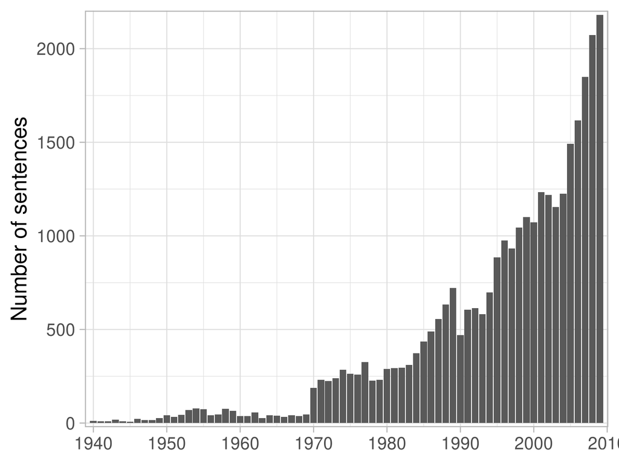

### Closest sentence from ‘rational’ and ‘rationality’ of the backbone community

| Sentence | Title | Year | Journal | Authors | Words Similarity |
| --- | --- | --- | --- | --- | --- |
| Concerning beliefs, I start each analysis by considering the rational expectations hypothesis in order to study subsequently the implications of bounded rationality. | Monetary policy, learning and the speed of convergence | 2007 | Journal of Economic Dynamics and Control | Ferrero G. | 0.805 |
| Some of these may be eliminated by imposing a criterion of “rational” beliefs along the lines of the sequential equilibrium concept in [4]. | [Strategic Behavior in Dynamic Auctions](http://www.jstor.org/stable/25054717) | 1993 | Economic Theory | Ruqu Wang | 0.801 |
| We aim to establish criteria to determine if a probability belief of an agent is “rational.” | [On the Structure and Diversity of Rational Beliefs](http://www.jstor.org/stable/25054813) | 1994 | Economic Theory | Mordecai Kurz | 0.797 |
| We have explained how Rational Beliefs rationality is compatible with the proposition that agents cannot fully learn the probability laws and the underlying structure of an economy whose dynamics are … | RATIONAL BELIEFS THEORY: A REVIEW | 2007 | Rivista Internazionale di Scienze Sociali | Carsten Krabbe Nielsen, Maurizio Motolese | 0.788 |
| On one hand, we have papers relaxing the assumption of individual rationality either through the belief-formation process or through the decision-making process. | How does learning affect market liquidity? A simulation analysis of a double-auction financial market with portfolio traders | 2007 | Journal of Economic Dynamics and Control | Consiglio A. | 0.785 |
| Second, the violation of rationality observed tends to be somewhat stronger in the incentive condition (see e.g., Grether & Plott, 1979)”. | Laboratory incentive structure and control-test design in an experimental asset market | 2001 | Journal of Economic Psychology | Brandouy O. | 0.780 |
| Incorporating the idea of Rational Beliefs into an equilibrium context was first done by «Kurz M., On rational belief equilibria (1994b)». | RATIONAL BELIEFS THEORY: A REVIEW | 2007 | Rivista Internazionale di Scienze Sociali | Carsten Krabbe Nielsen, Maurizio Motolese | 0.778 |
| We then show that Rational Belief equilibria may exhibit behavioral patterns which are very different from Rational Expectations equilibria. | [On Rational Belief Equilibria](http://www.jstor.org/stable/25054812) | 1994 | Economic Theory | Mordecai Kurz | 0.776 |
| The belief of any agent is rational in the sense that the empirical distribution of prices and observable fundamentals, that would be generated if the belief were correct is identical to the empirical… | [Non-Stationary, Stable Markov Processes on a Continuous State Space](http://www.jstor.org/stable/40283041) | 2009 | Economic Theory | Carsten Krabbe Nielsen | 0.776 |
| The theory of rational beliefs is based on the observation that our economy is a non-stationary environment with a sequence of changing regimes and the length of decision life of any agent is relative… | [Speculative Trading with Rational Beliefs and Endogenous Uncertainty](http://www.jstor.org/stable/25055626) | 2003 | Economic Theory | Ho-Mou Wu, Wen-Chung Guo | 0.774 |
| However, RB is silent about the degree much less the nature of such «inferential rationality» as may be needed for the agent to select what he deems to be an optimal belief within the set of admissibl… | THE ABILITY TO «OUTPERFORM THE MARKET»: LOGICAL FOUNDATIONS BASED ON THE THEORY OF RATIONAL BELIEFS | 2007 | Rivista Internazionale di Scienze Sociali | Horace W. Brock | 0.774 |
| The Theory of Rational Beliefs offers a method to model the above phenomena in a consistent way while retaining the assumption that agents behave rationally and that they use past observations when th… | [Rational Belief Structures and Rational Belief Equilibria](http://www.jstor.org/stable/25054981) | 1996 | Economic Theory | Carsten Krabbe Nielsen | 0.773 |
| Finally, we introduce the rationality conditions to define the rational belief equilibria (RBE) of the economy. | [A model of financial markets with endogenously correlated rational beliefs](http://www.jstor.org/stable/27822489) | 2007 | Economic Theory | Hiroyuki Nakata | 0.773 |
| Since agents are assumed to hold Rational Beliefs the equilibrium concept employed here is a Rational Belief Equilibrium introduced by Kurz [1994b] [1996]. | [Endogenous Uncertainty in a General Equilibrium Model with Price Contingent Contracts](http://www.jstor.org/stable/25054983) | 1996 | Economic Theory | Mordecai Kurz, Ho-Mou Wu | 0.770 |
| In the present paper we 1 Kurz (1994) has provided the alternative idea of rational belief equilibria. | [On Extensive Form Implementation of Contracts in Differential Information Economies](http://www.jstor.org/stable/25055635) | 2003 | Economic Theory | Dionysius Glycopantis, Allan Muir, Nicholas C. Yannelis | 0.769 |
| In Section 5 we consider the possibility that our results represent rational incentive-driven behavior. | Quantifying cognitive biases in analyst earnings forecasts | 2006 | Journal of Financial Markets | Friesen G. | 0.769 |
| The theory of Rational Beliefs offers a way to formalize the idea that agents with the same information available to them may have different beliefs about the true nature of the randomness of their ec… | [Rational Belief Structures and Rational Belief Equilibria](http://www.jstor.org/stable/25054981) | 1996 | Economic Theory | Carsten Krabbe Nielsen | 0.767 |
| Neeman (1993, 1994) finds that agents will disagree when each assigns just a small probability to the event that other agents are not fully rational. | [Differential Interpretation of Information in Inflation Forecasts](http://www.jstor.org/stable/2646860) | 1999 | The Review of Economics and Statistics | Eugene Kandel, Ben-Zion Zilberfarb | 0.765 |
| It is clear that the proposed paradigm of the Theory of Rational Beliefs has very important implications to the study of economic fluctuations and to the conduct of monetary policy. | [Money Non-Neutrality in a Rational Belief Equilibrium with Financial Assets](http://www.jstor.org/stable/25055412) | 2001 | Economic Theory | Maurizio Motolese | 0.764 |
| We assume that agents adopt Rational Beliefs as in Kurz [1994a]. | [Endogenous Uncertainty in a General Equilibrium Model with Price Contingent Contracts](http://www.jstor.org/stable/25054983) | 1996 | Economic Theory | Mordecai Kurz, Ho-Mou Wu | 0.763 |
| It is clear that the proposed paradigm of the Theory of Rational Beliefs has very important implications to the study of economic fluctuations and to the formulation of monetary policy. | [Endogenous Uncertainty and the Non-Neutrality of Money](http://www.jstor.org/stable/25055628) | 2003 | Economic Theory | Maurizio Motolese | 0.763 |
| By assuming diverse Rational Beliefs the Rational Beliefs equilibrium theory offers a clear resolution of both puzzles. | RATIONAL BELIEFS THEORY: A REVIEW | 2007 | Rivista Internazionale di Scienze Sociali | Carsten Krabbe Nielsen, Maurizio Motolese | 0.763 |

### Closest sentences from ‘rational’ and ‘rationality’ of the HDBSCAN cluster

#### Closes sentences 5_9_1940-1949: cruciality, practical_judgments, sound_judgment, dubitable, dubitable_premise (1940-1949)

| Sentence | Title | Year | Journal | Authors | Words Similarity |
| --- | --- | --- | --- | --- | --- |
| In such instances again genuine decisions based on the emergence of new expectations are one but not the only possibility. | [Psychological Analysis of Business Decisions and Expectations](http://www.jstor.org/stable/1802255) | 1946 | The American Economic Review | George Katona | 0.680 |
| Again, not only are decisions arrived at, and indeed conditioned by an environment of social, political, and economic factors (including contemporary thought), but one decision in some measure conditi… | [An Approach to the Study of Entrepreneurship: A Tribute to Edwin F. Gay](http://www.jstor.org/stable/2113071) | 1946 | The Journal of Economic History | Arthur H. Cole | 0.648 |
| But the cruciality of certain decisions is not something to be determined on abstract grounds by means of an analysis presuming the universal pre-eminence of limited hypotheses; it is a matter that de… | [The Entrepreneur: The Firm](http://www.jstor.org/stable/1829414) | 1944 | Journal of Political Economy | James H. Stauss | 0.631 |
| This means that the layman needs a basis for intelligent choice. | IMPRESSIONS, QUESTIONS AND OBSERVATIONS | 1946 | Proceedings of the Annual Meeting (Western Farm Economics Association) | Sherman E. Johnson | 0.629 |
| When a man takes a decision on any matter whatever, he tacitly or unconsciously takes into account a great range of circumstances which are all relevant, in the sense that if any one of them were mate… | [Interest-Rates and the Pace of Investment](http://www.jstor.org/stable/2225616) | 1946 | The Economic Journal | G. L. S. Shackle | 0.621 |
| Our attitudes as to desirability and feasibility are strongly linked here. | FARM PRICE, PRODUCTION, AND INCOME POLICY: A report to the Western Farm Economics Association, by its Agricultural Policy Committee | 1948 | Proceedings of the Annual Meeting (Western Farm Economics Association) | Marion Clawson | 0.619 |
| And whatever explanation it selects-historical, social, aesthetic, pragmatic -involves a decision between competing values. | [Science and Values in a Changing World](http://www.jstor.org/stable/3484196) | 1941 | The American Journal of Economics and Sociology | George R. Geiger | 0.619 |
| The suggestion of this essay is that if we are actually to implement and improve practical judgments the ideas at work in such judgments must also be investigated. | [The Logical Foundations of Economic Research](http://www.jstor.org/stable/1232709) | 1949 | Journal of Farm Economics | Kenneth H. Parsons | 0.617 |
| V IT SHOULD BE CLEAR that free choice, if it must be realistic and intelligent, is not something merely negative, absence of restraint. | [An Ethics for Today](http://www.jstor.org/stable/3483698) | 1943 | The American Journal of Economics and Sociology | Everett W. Hall | 0.614 |
| Let us resist the temptation to call in question this highly abstract conception of choice -a choice that is choice no matter what it chooses, for surely a theorist has a right to be as abstract as he… | [Professor Robbins’ Definition of Economics](http://www.jstor.org/stable/1826801) | 1943 | Journal of Political Economy | Robert Scoon | 0.613 |

#### Closes sentences 5_14_1950-1959: preferential_sets, individual_orderings, preferences, alternatives, orderings (1950-1959)

| Sentence | Title | Year | Journal | Authors | Words Similarity |
| --- | --- | --- | --- | --- | --- |
| This does not deny the importance of judgment in the formulation of business decisions and in the selection of functionaries and areas of activity, but it does indicate the difficulty of rationalizing… | [A Generalized Uncertainty Theory of Profit](http://www.jstor.org/stable/1802809) | 1950 | The American Economic Review | J. Fred Weston | 0.650 |
| In the same way that the analysis of any problem is incomplete until all reasonable alternative possibilities have been considered, so the determination of welfare or the public interest cannot rest s… | [Economics and the Public Interest](http://www.jstor.org/stable/3159624) | 1955 | Land Economics | L. G. Hines | 0.642 |
| And in this type of decision especially it is essential that individuals act in accordance with a value-ordering which is somewhat different from that motivating individual market choice. | [Individual Choice in Voting and the Market](http://www.jstor.org/stable/1827235) | 1954 | Journal of Political Economy | James M. Buchanan | 0.640 |
| People cannot make judgments wisely unless the pro’s and con’s of various solutions are adequately presented for consideration and relevant facts made known to those who collectively must make the dec… | [Developing Educational Work in Agricultural Policy](http://www.jstor.org/stable/1233295) | 1953 | Journal of Farm Economics | G. Alvin Carpenter | 0.638 |
| problem and the debating of the desirability of alternatives, and little in the actual conclusion reached. | [Business History, Entrepreneurial History, and Business Administration](http://www.jstor.org/stable/2114539) | 1958 | The Journal of Economic History | John G. B. Hutchins | 0.633 |
| In real life, however, where a decision generally has to be taken in a clear-cut way, there is often one broad economic point that is of preponder-ant importance and that will turn the issue irrespect… | [The Place of the Economist in Government](http://www.jstor.org/stable/2662098) | 1955 | Oxford Economic Papers | Robert Hall | 0.632 |
| We assume that people can make better decisions when they take a realistic view of their total situation, 4. | Farm and Home Planning-Incentive For Better Family Living and Better Farming | 1955 | Proceedings of the Annual Meeting (Western Farm Economics Association) | Mrs. Lila B. Dickerson | 0.631 |
| The point is simply that the assumptions of the system, in Samuelson’s happy phrase, “put a straitjacket on the person’s preferences.” | [The Neumann-Morgenstern Utility Index–An Ordinalist View](http://www.jstor.org/stable/1826854) | 1951 | Journal of Political Economy | William J. Baumol | 0.622 |
| This implies that the subject can choose in divergence from his own “preference,” which is only possible if some kind of separation is made in the preference factors, for instance between “real” and “… | [A General Theory of Bargaining](http://www.jstor.org/stable/1914413) | 1952 | The American Economic Review | J. Pen | 0.622 |
| As will be shown in this paper, the decision-making process may produce consistent choice, even though the rule which states the social ordering from the individual values may not exist. | [Social Choice, Democracy, and Free Markets](http://www.jstor.org/stable/1825570) | 1954 | Journal of Political Economy | James M. Buchanan | 0.621 |

#### Closes sentences 5_18_1960-1969: decision, decision_maker, alternatives, decisions, maker (1960-1969)

| Sentence | Title | Year | Journal | Authors | Words Similarity |
| --- | --- | --- | --- | --- | --- |
| Rather, we shall argue that there is a “natural unit” for decision-making and that this unit is responsive to market forces. | [Externalities, Welfare, and the Theory of Games](http://www.jstor.org/stable/1828857) | 1962 | Journal of Political Economy | Otto A. Davis, Andrew Whinston | 0.668 |
| itate a more rational choice by the decision maker in that the consequences of each action are more completely specified. | [An Application of Statistical Decision Theory to Commercial Turkey Production](http://www.jstor.org/stable/1236942) | 1967 | Journal of Farm Economics | Vernon R. Eidman, Gerald W. Dean, Harold O. Carter | 0.661 |
| Nonetheless, there are considerations which, in certain instances, enable one to make a logical selection. | [Substitution, Technical Progress, and Returns to Scale](http://www.jstor.org/stable/1816270) | 1965 | The American Economic Review | C. E. Ferguson | 0.634 |
| When new factors arise, which, if known ex ante, would have led to a more suitable choice, the initial decision must only be countermanded if the cost of the unsuitable decision is greater than that o… | [The French Plan and Economic Theory](http://www.jstor.org/stable/1909789) | 1965 | Econometrica | Pierre Massé | 0.630 |
| Virtually all decisions affect in some degree other decisions, persons, interests. | [Internal Economies](http://www.jstor.org/stable/2229795) | 1969 | The Economic Journal | Alec Nove | 0.629 |
| Decisions are often based on something else. | [Farm Fundamentalism: Its Future](http://www.jstor.org/stable/1236057) | 1962 | Journal of Farm Economics | Don F. Hadwiger | 0.628 |
| Decisions of this kind have been the academic domain of psychologists, economists, mathematicians, and others as well. | [A Behavioral Approach to the Investment-Management Decision and to the Securities Markets](http://www.jstor.org/stable/2326142) | 1969 | The Journal of Finance | Randolph Westerfield | 0.626 |
| One man’s judgment on these matters may be wiser and more sensible than another’s; it may take more, better and more reasonable considerations into account; but it still remains one man’s subjective p… | [A Critique of Present and Proposed Standards](http://www.jstor.org/stable/1815005) | 1960 | The American Economic Review | Tibor Scitovsky | 0.625 |
| Decisions must be made; but to provide the basis for informed choice the consequences of pursuing alternative lines of action must be more clearly set forth than has been customary in the past. | [Resource Management and Conservation; The Approach of the Brandywine Valley Association](http://www.jstor.org/stable/3144740) | 1964 | Land Economics | George Macinko | 0.625 |
| also the reasonableness of decisions? | [An Ombudsman Scheme for Canada](http://www.jstor.org/stable/139295) | 1962 | The Canadian Journal of Economics and Political Science / Revue canadienne d’Economique et de Science politique | Donald C. Rowat | 0.624 |

#### Closes sentences 5_15_1970-1979: utility_function, expected_utility, utility, utility_functions, summary_values (1970-1979)

| Sentence | Title | Year | Journal | Authors | Words Similarity |
| --- | --- | --- | --- | --- | --- |
| We have foregone presenting a formal statement of the “postulates of rational choice” that underly the expected-utility rule. | [The Analytics of Uncertainty and Information-An Expository Survey](http://www.jstor.org/stable/2723720) | 1979 | Journal of Economic Literature | J. Hirshleifer, John G. Riley | 0.701 |
| The works of Ramsey,9 Von Neumann and Morgenstern,’0 Marschak,’1 Luce and Riaffa,’12 Samuelson,13 Borch,14 and Feldstein’5 have substantiated the concept of maximizing expected utility as a valid desc… | Profitability in the Property and Liability Insurance Industry: Comment | 1972 | The Journal of Risk and Insurance | John L. Markle | 0.690 |
| Taking a different tack, Quandt (1960) andMeginniss (1976) have questioned whether expected utility maximization is necessary for rationality. | [The Austrian Theory of the Marginal Use and of Ordinal Marginal Utility](http://www.jstor.org/stable/41797905) | 1977 | Zeitschrift für Nationalökonomie / Journal of Economics | J. Huston McCulloch | 0.689 |
| Though not necessary to the ordinal analysis, this latter component of rationality will be taken here to imply also aU/ami > a.U/amj for Ti > Tj, which is to say that, ceteris paribus, the individual … | [Choices Involving Risk: Simple Steps Toward an Ordinalist Analysis](http://www.jstor.org/stable/2231451) | 1976 | The Economic Journal | E. J. Mishan | 0.672 |
| Such “ordinal” theories of rational choice already reflect a considerable erosion of the utility concept; but neverthelessthey seem to resist justification in full detail. | [Ordinal Preference and Rational Choice](http://www.jstor.org/stable/1913486) | 1973 | Econometrica | Hans G. Herzberger | 0.660 |
| Given the basic assumptions of utility analysis, the choice between constant V(g) and constant U(WT) is equivalent to deciding which of two types of questions would be more reasonable to ask (or deter… | [Investment for the Long Run: New Evidence for an Old Rule](http://www.jstor.org/stable/2326680) | 1976 | The Journal of Finance | Harry M. Markowitz | 0.659 |
| Furthermore, if for all risky prospects his choices can be represented by a function of E and V alone, and if the von Neumann-Morgenstern axioms are satisfied, then his preferences can be represented … | [Financial Risk and the St. Petersburg Paradox: Comment](http://www.jstor.org/stable/2327278) | 1978 | The Journal of Finance | Thomas W. Epps | 0.653 |
| Statistical decision theory employing the idea of subjective expected utility, on the one hand, and game theory, on the other, have contributed enormous conceptual clarification to these kinds of situ… | [Rational Decision Making in Business Organizations](http://www.jstor.org/stable/1808698) | 1979 | The American Economic Review | Herbert A. Simon | 0.647 |
| Accepting an extension of the uniform knowledge assumption to include future preferences also, a weighted averaging of the different utility functions seems to be in order in the rational calculus of … | [Bargaining Costs and Social Choice under Uncertainty](http://www.jstor.org/stable/30023155) | 1974 | Public Choice | A. S. Pinto Barbosa | 0.646 |
| This result follows directly from the ’’axioms of rational behavior” specified by von Neumann and Morgenstern.7 Experience has indicated that utility assessments varying more than two attributes simul… | A Decision Analysis with Multiple Objectives: The Mexico City Airport | 1973 | The Bell Journal of Economics and Management Science | Ralph L. Keeney | 0.644 |

#### Closes sentences 5_17_1970-1979: social_choice, preferences, liberalism, arrow’s, revealed_preference (1970-1979)

| Sentence | Title | Year | Journal | Authors | Words Similarity |
| --- | --- | --- | --- | --- | --- |
| The solution of the market and the problem of social choice posited by Arrow are distinct in one important sense (see below), so that one cannot say that the market solution is irrational by analogy t… | [The Possibility of a Paretian Liberal: Impossibility Theorems and Cardinal Utility](http://www.jstor.org/stable/1830111) | 1971 | Journal of Political Economy | Y. K. Ng | 0.700 |
| Further weakening of the consistency requirement imposed by Arrow’s collective rationality (while continuing to insist on the existence of a rationalization) is entailed by requiring acyclicity (nonex… | Impossibility theorems without collective rationality | 1976 | Journal of Economic Theory | Blair D.H. | 0.672 |
| REVEALED PREFERENCE It should be emphasized that revealed preference and its axioms enter the theory of rationality in a somewhat incidental way, leaving behind a certain measure of their historical m… | [Ordinal Preference and Rational Choice](http://www.jstor.org/stable/1913486) | 1973 | Econometrica | Hans G. Herzberger | 0.661 |
| Arrow’s requirement of collective rationality is a generalization of the Condorcet criterion in that the social optima would be socially preferred or indifferent to all the other alternatives under co… | [Aggregation of Preferences](http://www.jstor.org/stable/1885263) | 1975 | The Quarterly Journal of Economics | Donald J. Brown | 0.652 |
| INTRODUCTION Kenneth Arrow’s famous impossibility theorem [1, 3, 4] can be viewed as a demonstration of a direct conflict between his condition of collective rationality and several other conditions, … | [On Collective Rationality and a Generalized Impossibility Theorem](http://www.jstor.org/stable/2296696) | 1974 | The Review of Economic Studies | Peter C. Fishburn | 0.651 |
| DIsCUSSION Kenneth Arrow has shown 2 that Al, which is viewed as a reasonable condition by some writers on social choice, is incompatible with several other social choice conditions. | [Subset Choice Conditions and the Computation of Social Choice Sets](http://www.jstor.org/stable/1883075) | 1974 | The Quarterly Journal of Economics | Peter C. Fishburn | 0.647 |
| In support of this argument, it was noted in the binary-choice impossibility theorems of Arrow and others that several very appealing conditions for social choice functions cannot all hold when a form… | [On Collective Rationality and a Generalized Impossibility Theorem](http://www.jstor.org/stable/2296696) | 1974 | The Review of Economic Studies | Peter C. Fishburn | 0.645 |
| Arrow’s condition of collective rationality (Condition 1’) can be seen to be merely a requirement that the domain of the collective choice rule should not be arbitrarily restricted. | [The Impossibility of a Paretian Liberal](http://www.jstor.org/stable/1829633) | 1970 | Journal of Political Economy | Amartya Sen | 0.644 |
| We will observe that the impossibility results presented do not use Arrow’s condition that the social choice function be rational. | [The Impossibility of a Just Liberal](http://www.jstor.org/stable/2553017) | 1976 | Economica | Jerry S. Kelly | 0.643 |
| We prove in this paper several impossibility theorems in which we do not require social choices to have a rationalization. | Impossibility theorems without collective rationality | 1976 | Journal of Economic Theory | Blair D.H. | 0.637 |

#### Closes sentences 5_16_1970-1979: decision_maker, decision, maker, decision_makers, makers (1970-1979)

| Sentence | Title | Year | Journal | Authors | Words Similarity |
| --- | --- | --- | --- | --- | --- |
| In this way, it becomes apparent that any method of choice among economic alternatives under uncertainty must be based on a pragmatic judgment which omits at least one criterion that seems desirable. | [On the Measurement of Fund Performance](http://www.jstor.org/stable/2325584) | 1970 | The Journal of Finance | Harlan D. Mills | 0.683 |
| It is the author’s notion that this lack of success may be attributed, at least in part, to the possible propensity of these decision makers to behave more as dissonance reducing rationalizers than as… | [Uncertainty in Nature, Cognitive Dissonance, and the Perceptual Distortion of Environmental Information: Weather Forecasts and New England Beach Trip Decisions](http://www.jstor.org/stable/143232) | 1973 | Economic Geography | Robert L. A. Adams | 0.669 |
| But unless these assumptions are to be made on a wholly ad hoc and arbitrary basis, they create again the need for an explicit and valid theory of the decision-making process (see Simon, 1958a; B. Fri… | [Rational Decision Making in Business Organizations](http://www.jstor.org/stable/1808698) | 1979 | The American Economic Review | Herbert A. Simon | 0.653 |
| In the case of uncertainty , the rational decision maker will choose an action a* e A only if 2 p (x) Q (x, a*) ^ 2 p (x) Q (x, a) y all a e A, xex xex and will behave so as to max S P(x)q(x,o). | [Economic Aspects of Information](http://www.jstor.org/stable/41797333) | 1971 | Zeitschrift für Nationalökonomie / Journal of Economics | Luigi M. Tomasini | 0.647 |
| These systems are more or less equivalent and possess the common implication that-for a “rational” man whose behavior fits their constraintsall uncertainties can be reduced to risks . | A computer-based method for incorporating risk/uncertainty into cost/utility analysis | 1970 | Socio Economic Planning Sciences | Kopff G. | 0.638 |
| Perhaps the most fruitful approach to the study of decision making presently would be to concentrate on rather specific models, such as those of Marschak and Radner, so as to generate enough “cases” t… | Economic theory and comparative economic systems: A partial literature survey | 1978 | Journal of Comparative Economics | Conn D. | 0.630 |
| Greenhut has observed that the entrepreneur overcomes the lack of objective information about the statistical probability of outcomes by assigning subjective probabilities to the possible payoffs base… | [Plant Location under Uncertainty](http://www.jstor.org/stable/3145987) | 1977 | Land Economics | Robert D. Dean, Thomas M. Carroll | 0.625 |
| Second, the theoretical discussion shows that, once the formation of expectations is treated realistically, a standard dynamic theory of decisionmaking under uncertainty does not imply that the sum of… | [Output and Labor Input in Manufacturing](http://www.jstor.org/stable/2534251) | 1974 | Brookings Papers on Economic Activity | Christopher A. Sims, Michael C. Lovell, Robert M. Solow | 0.623 |
| To apply our theory to real-world decisions, we must therefore suppose that “natural” decisions, such as fA, gB above, are enriched by certain artificial ones. | [Conditional Expected Utility](http://www.jstor.org/stable/1913344) | 1971 | Econometrica | R. Duncan Luce, David H. Krantz | 0.622 |
| Further, in both cases, there is an expectation of a stable, but decidely suboptimal, social choice. | [The Dilemma of a Paretian Liberal: Some Consequences of Sen’s Theorem](http://www.jstor.org/stable/30022961) | 1977 | Public Choice | John Aldrich | 0.621 |

#### Closes sentences 5_7_1980-1989: agent, agents, agent’s, incentive_compatible, incentive (1980-1989)

| Sentence | Title | Year | Journal | Authors | Words Similarity |
| --- | --- | --- | --- | --- | --- |
| One, already mentioned, says that rational agents do not believe inconsistent things (rational belief-sets are consistent); a second, that they believe the logic consequences of their beliefs (rationa… | [Expecting and Affecting](http://www.jstor.org/stable/2663333) | 1989 | Oxford Economic Papers | Michael Bacharach | 0.734 |
| A very natural method for defining rational beliefs would be to require that they be consistent with the equilibrium quality which actually would be supplied if a price was offered in equilibrium. | [Price Advertising and the Deterioration of Product Quality](http://www.jstor.org/stable/2297578) | 1988 | The Review of Economic Studies | William P. Rogerson | 0.728 |
| A necessary condition for agreeing to a contract is that its expected outcomes satisfy what may be termed individual rationality. | [Bargaining and the Sources of Transaction Costs: The Case of Government Regulation](http://www.jstor.org/stable/764805) | 1987 | Journal of Law, Economics, & Organization | Douglas D. Heckathorn, Steven M. Maser | 0.713 |
| Given a posterior belief, sequential rationality determines whether the creditor accepts or rejects the deviation; if the creditor is indifferent, we assume that the deviation is accepted. | [Simultaneous Signalling to the Capital and Product Markets](http://www.jstor.org/stable/2555698) | 1988 | The RAND Journal of Economics | Robert Gertner, Robert Gibbons, David Scharfstein | 0.711 |
| Given a posterior belief, sequential rationality determines whether the creditor accepts or rejects the deviation; if the creditor is indifferent, we assume that the deviation is accepted. | [Simultaneous Signalling to the Capital and Product Markets](http://www.jstor.org/stable/2555698) | 1988 | The RAND Journal of Economics | Robert Gertner, Robert Gibbons, David Scharfstein | 0.711 |
| The two- and eight-month contracts show that the rationality postulate can be rejected at the . | [Are Livestock Futures Prices Rational Forecasts?](http://www.jstor.org/stable/40987807) | 1986 | Western Journal of Agricultural Economics | J. S. Shonkwiler | 0.708 |
| The existence of bounded rationality enters this model as a constraint on the information that can enter contracts. | The new institutional economics and a model of contract | 1989 | Journal of Economic Behavior and Organization | Leitzel J. | 0.704 |
| A necessary condition for agreeing to a contract is that its expected outcome satisfies what may be termed joint rationality. | [Bargaining and the Sources of Transaction Costs: The Case of Government Regulation](http://www.jstor.org/stable/764805) | 1987 | Journal of Law, Economics, & Organization | Douglas D. Heckathorn, Steven M. Maser | 0.700 |
| In the asymmetric information literature the focus is on how agents who are rational (and who have rational expectations) interact when it is common knowledge that they have different information. | [Efficient Capital Markets and Martingales](http://www.jstor.org/stable/2727024) | 1989 | Journal of Economic Literature | Stephen F. LeRoy | 0.695 |
| We may form subjective probabilities on the events, but it will not be possible to show that they are rational in the sense that they correspond to objective probabilities either calculated from obser… | [Some Evidence of Speculative Bubbles in the Foreign Exchange Markets](http://www.jstor.org/stable/1992617) | 1987 | Journal of Money, Credit and Banking | Wing Thye Woo | 0.691 |

#### Closes sentences 5_10_1980-1989: expected_utility, utility_theory, utility, preferences, allais (1980-1989)

| Sentence | Title | Year | Journal | Authors | Words Similarity |
| --- | --- | --- | --- | --- | --- |
| We have argued that our theory describes a form of behaviour which, although contravening the axioms of expected utility theory, is rational. | [Regret Theory: An Alternative Theory of Rational Choice Under Uncertainty](http://www.jstor.org/stable/2232669) | 1982 | The Economic Journal | Graham Loomes, Robert Sugden | 0.732 |
| Transitive rationality The expected utility hypothesis provided our original example of consistent choice under uncertainty. | Consistent choice under uncertainty | 1985 | Journal of Mathematical Economics | Clark S.A. | 0.719 |
| [ 1974, p. 1 1, emphasis added] Dreze is quick to acknowledge and discount the descriptive validity of the expected utility axioms, but like many others he still feels secure in their normative validi… | [The Origin of Predictable Behavior](http://www.jstor.org/stable/1816559) | 1983 | The American Economic Review | Ronald A. Heiner | 0.711 |
| This concept of rationality is retained in some of the more recent attempts to reformulate the theory of choice under uncertainty. | [Why be Consistent? A Critical Analysis of Consistency Requirements in Choice Theory](http://www.jstor.org/stable/2554418) | 1985 | Economica | Robert Sugden | 0.707 |
| In Ng (1984), it is shown that a set of reasonable axioms (no stronger than the axioms for the expected utility hypothesis except for our recognition of finite sensibility) implies that the only ratio… | Individual Irrationality and Social Welfare | 1989 | Social Choice and Welfare | Y. K. Ng | 0.704 |
| According to these theories, the choices of a rational decision maker in an uncertain environment are explainable by a mathematical expectation of utility criterion. | [Rational Behavior under Complete Ignorance](http://www.jstor.org/stable/1912184) | 1980 | Econometrica | Michèle Cohen, Jean-Yves Jaffray | 0.701 |
| SECTION 7 The axioms of expected utility theory, considered as requirements of rationality for preferences, have been under renewed attack recently. | Should social preferences be consistent? | 1989 | Economics and Philosophy | Broome J. | 0.691 |
| The expected utility theory presents axioms, normally attributed to “rational” behavior, which imply preferences of the following form. | [Risk-Aversion and Mixing](http://www.jstor.org/stable/41798084) | 1981 | Zeitschrift für Nationalökonomie / Journal of Economics | Rolf Kotz, Klaus Spremann | 0.676 |
| Consequently, they seem to contradict rational behavior defined in terms of a timeless formulation of the expected utility model or even Machina’s (1982, 1983) generalized expected utility framework. | [An Empirical Analysis of the Economic Value of Risk Changes](http://www.jstor.org/stable/1831301) | 1987 | Journal of Political Economy | V. Kerry Smith, William H. Desvousges | 0.671 |
| As the first one we shall present Arrow’s Impossibility Theorem for rational budgeters. | Rational Budgeters in the Theory of Social Choice | 1986 | Social Choice and Welfare | S. Fuchs-Seliger | 0.670 |

#### Closes sentences 5_14_1990-1999: expected_utility, preferences, utility_theory, independence_axiom, utility (1990-1999)

| Sentence | Title | Year | Journal | Authors | Words Similarity |
| --- | --- | --- | --- | --- | --- |
| These empirical anomalies, along with general critiques of expected utility (see Maurice Allais 1952; Daniel Ellsberg 1961; Sen 1985b; Levi 1986b; McClen-nen 1990), have stimulated the formulation of … | [Taking Ethics Seriously: Economics and Contemporary Moral Philosophy](http://www.jstor.org/stable/2728513) | 1993 | Journal of Economic Literature | Daniel M. Hausman, Michael S. McPherson | 0.733 |
| Some results suggest not merely that people are not always rational, but that expected utility theory is flawed as a theory of rationality. | [Taking Ethics Seriously: Economics and Contemporary Moral Philosophy](http://www.jstor.org/stable/2728513) | 1993 | Journal of Economic Literature | Daniel M. Hausman, Michael S. McPherson | 0.728 |
| of systematic deviations from the von NeumannMorgenstern axioms of rational behavior and, in particular, from subjective expected utility maximization (see, e.g., . | On the rate of return in the art market: Survey and evaluation | 1995 | European Economic Review | Frey B.S. | 0.718 |
| In a way, these two versions question the rationality of non-expected utility maximizers. | Dynamic consistency, consequentialism and reduction of compound lotteries | 1994 | Economics Letters | Volij O. | 0.715 |
| In Section 2, we review the axioms for rational decision making that comprise expected utility theory. | Ordering risks: Expected utility theory versus Yaari’s dual theory of risk | 1998 | Insurance Mathematics and Economics | Wang S. | 0.708 |
| Our study employs the usual rationality assumptions of game theory to endogenize preferences, which neoclassical theory typically treats as exogenous. | Is altruism evolutionarily stable? | 1998 | Journal of Economic Behavior and Organization | Bester H. | 0.702 |
| McClennen (1990) provides a thorough analysis of Hammonds’s argument, as well as an alternative account of dynamic rationality leading to a skeptical view of independence. | Harsanyi’s Aggregation Theorem: multi-profile version and unsettled questions | 1994 | Social Choice and Welfare | Philippe Mongin | 0.692 |
| To help answer this question, let us consider the theory of rational choice under uncertainty. | [Foundations of Portfolio Theory](http://www.jstor.org/stable/2328831) | 1991 | The Journal of Finance | Harry M. Markowitz | 0.689 |
| The axioms of rational behavior under uncertainty advanced by von Neumann and Morgenstern (1944), together with the usual assumption that utility is increasing in income, results in a voter decision r… | [Incomplete Information, Income Redistribution and Risk Averse Median Voter Behavior](http://www.jstor.org/stable/30025366) | 1991 | Public Choice | John A. Bishop, John P. Formby, W. James Smith | 0.688 |
| We concentrate primarily on the framework of Arrow and Hurwicz (1972) who demonstrated that when a decision maker is faced with pure uncertainty, choices based on the most extreme possible outcomes ar… | [How to Decide When Experts Disagree: Uncertainty-Based Choice Rules in Environmental Policy](http://www.jstor.org/stable/3147241) | 1997 | Land Economics | Richard T. Woodward, Richard C. Bishop | 0.687 |

#### Closes sentences 5_12_1990-1999: agent, agents, agent’s, beliefs, bayesian (1990-1999)

| Sentence | Title | Year | Journal | Authors | Words Similarity |
| --- | --- | --- | --- | --- | --- |
| Some of these may be eliminated by imposing a criterion of “rational” beliefs along the lines of the sequential equilibrium concept in [4]. | [Strategic Behavior in Dynamic Auctions](http://www.jstor.org/stable/25054717) | 1993 | Economic Theory | Ruqu Wang | 0.801 |
| We aim to establish criteria to determine if a probability belief of an agent is “rational.” | [On the Structure and Diversity of Rational Beliefs](http://www.jstor.org/stable/25054813) | 1994 | Economic Theory | Mordecai Kurz | 0.797 |
| We then show that Rational Belief equilibria may exhibit behavioral patterns which are very different from Rational Expectations equilibria. | [On Rational Belief Equilibria](http://www.jstor.org/stable/25054812) | 1994 | Economic Theory | Mordecai Kurz | 0.776 |
| The Theory of Rational Beliefs offers a method to model the above phenomena in a consistent way while retaining the assumption that agents behave rationally and that they use past observations when th… | [Rational Belief Structures and Rational Belief Equilibria](http://www.jstor.org/stable/25054981) | 1996 | Economic Theory | Carsten Krabbe Nielsen | 0.773 |
| Since agents are assumed to hold Rational Beliefs the equilibrium concept employed here is a Rational Belief Equilibrium introduced by Kurz [1994b] [1996]. | [Endogenous Uncertainty in a General Equilibrium Model with Price Contingent Contracts](http://www.jstor.org/stable/25054983) | 1996 | Economic Theory | Mordecai Kurz, Ho-Mou Wu | 0.770 |
| The theory of Rational Beliefs offers a way to formalize the idea that agents with the same information available to them may have different beliefs about the true nature of the randomness of their ec… | [Rational Belief Structures and Rational Belief Equilibria](http://www.jstor.org/stable/25054981) | 1996 | Economic Theory | Carsten Krabbe Nielsen | 0.767 |
| Neeman (1993, 1994) finds that agents will disagree when each assigns just a small probability to the event that other agents are not fully rational. | [Differential Interpretation of Information in Inflation Forecasts](http://www.jstor.org/stable/2646860) | 1999 | The Review of Economics and Statistics | Eugene Kandel, Ben-Zion Zilberfarb | 0.765 |
| We assume that agents adopt Rational Beliefs as in Kurz [1994a]. | [Endogenous Uncertainty in a General Equilibrium Model with Price Contingent Contracts](http://www.jstor.org/stable/25054983) | 1996 | Economic Theory | Mordecai Kurz, Ho-Mou Wu | 0.763 |
| Rational beliefs We provide here a brief summary of the theory proposed in Kurz [1994]. | [On Rational Belief Equilibria](http://www.jstor.org/stable/25054812) | 1994 | Economic Theory | Mordecai Kurz | 0.762 |
| The theoretical underpinnings of this assumption are found in Aumann’s (1976) seminal work, which shows that, under the assumptions of common knowledge of rationality and common priors, two rational e… | [Differential Interpretation of Information in Inflation Forecasts](http://www.jstor.org/stable/2646860) | 1999 | The Review of Economics and Statistics | Eugene Kandel, Ben-Zion Zilberfarb | 0.759 |

#### Closes sentences 5_15_2000-2009: incentive_compatibility, incentive, compatibility, agent, incentive_compatible (2000-2009)

| Sentence | Title | Year | Journal | Authors | Words Similarity |
| --- | --- | --- | --- | --- | --- |
| Second, the violation of rationality observed tends to be somewhat stronger in the incentive condition (see e.g., Grether & Plott, 1979)”. | Laboratory incentive structure and control-test design in an experimental asset market | 2001 | Journal of Economic Psychology | Brandouy O. | 0.780 |
| In Section 5 we consider the possibility that our results represent rational incentive-driven behavior. | Quantifying cognitive biases in analyst earnings forecasts | 2006 | Journal of Financial Markets | Friesen G. | 0.769 |
| They characterize the optimal mechanism under ex post individual rationality and ex post incentive compatibility. | Labor market reforms, job instability, and the flexibility of the employment relationship | 2009 | European Economic Review | Matouschek N. | 0.737 |
| Furthermore, Maskin and Tir?le (1999) show that some bounded rationality is required to motivate incom pleteness, else contracts could be drawn up based upon the assumed probability distribution over … | [Toward a Theory of Regulation for Developing Countries: Following Jean-Jacques Laffont’s Lead](http://www.jstor.org/stable/27739984) | 2009 | Journal of Economic Literature | Antonio Estache, Liam Wren-Lewis | 0.727 |
| The significance of assuming a complex environment in modeling bounded rationality is emphasized by Segal : While much has been said about the role of bounded rationality in explaining contractual inc… | Limited observability as a constraint in contract design | 2007 | Journal of Economic Theory | Krasa S. | 0.724 |
| “2 This assumption introduces a nontrivial tradeoff between interim individual rationality and incentive compatibility for information revelation. | [Auditing and Property Rights](http://www.jstor.org/stable/1593695) | 2004 | The RAND Journal of Economics | Elisabetta Iossa, Patrick Legros | 0.724 |
| Bounded rationality is the cognitive assumption, the main economic import of which is that all complex contracts are unavoidably incomplete. | Examining economic organization through the lens of contract | 2003 | Industrial and Corporate Change | Williamson O.E. | 0.723 |
| Condition (16) is related to an earlier result due to Laffont and Maskin (1979) who proved that Bayesian incentive compatibility, efficiency, budget balance and individual rationality may be incompati… | The design of transnational public good mechanisms for developing countries | 2005 | Journal of Public Economics | Laffont J.J. | 0.716 |
| In the appendix we show the following proposition that, as in Bayesian settings, states that IRn is the only individual rationality constraint that is binding for an optimal contract. | [Adverse Selection under Ignorance](http://www.jstor.org/stable/25055332) | 2000 | Economic Theory | Javier M. López-Cuñat | 0.711 |
| Our analysis of the mean mechanism therefore describes the outcome when people behave rational in a setup where truth-telling would maximize welfare. | Collective decisions with interdependent valuations | 2004 | European Economic Review | Grüner H. | 0.708 |

#### Closes sentences 5_17_2000-2009: expected_utility, preferences, ambiguity_aversion, ambiguity, utility_theory (2000-2009)

| Sentence | Title | Year | Journal | Authors | Words Similarity |
| --- | --- | --- | --- | --- | --- |
| Then there exists a choice function which is optimal-rational with respect to R. We have, thus, realized that rational behavior of individuals follows from very mild conditions imposed upon their pref… | [Rationality without Transitivity](http://www.jstor.org/stable/41795073) | 2003 | Journal of Economics | Susanne Fuchs-Seliger, Oliver Mayer | 0.758 |
| Extensive form rationalizability: Until now, we have been reviewing rationality concepts that are either refinements or weakenings of preference conjecture equilibrium. | Proper belief revision and equilibrium in dynamic games | 2007 | Journal of Economic Theory | Perea A. | 0.747 |
| However, since only the choice behaviour is observable, the probabilistic rationalizability question which has engaged the attention of numerous writers in this line of investigation is analogous to t… | On probabilistic rationalizability | 2009 | Social Choice and Welfare | Shasikanta Nandeibam | 0.745 |
| The concept of rationalizability provides the connection between the observed choice behaviour as represented by a choice system and the hypothesis of stochastic preferences as represented by a probab… | On probabilistic rationalizability | 2009 | Social Choice and Welfare | Shasikanta Nandeibam | 0.733 |
| This paper was previously circulated under the title “Rationalizing Boundedly Rational Choice: Sequential Rationalizability and Rational Shortlist Methods.” | [Sequentially Rationalizable Choice](http://www.jstor.org/stable/30034586) | 2007 | The American Economic Review | Paola Manzini, Marco Mariotti | 0.728 |
| We define three basic ‘orders of rationality’, with higher orders implying greater sophistication as to the signs of the derivatives of the Theory and Decision 51: underlying preference function, assu… | An experiment on rational insurance decisions | 2001 | Theory and Decision | Watt R. | 0.725 |
| A data set 〈Ω,(χω)ω∈Ω〉 is rationalizable if there exists a probability measure over states of nature, δ:P(Ξ)→[0,1], a function that assigns profiles of preferences to states of nature, U:Ξ→U N and a f… | Equilibrium behavior in markets and games: Testable restrictions and identification | 2004 | Journal of Mathematical Economics | Carvajal A. | 0.724 |
| We must admit the more complex cases: otherwise we could not address whether outcome-rational and intransitive choice behavior can persist in the precisely the same settings that complete and transiti… | Incomplete preferences and rational intransitivity of choice | 2005 | Games and Economic Behavior | Mandler M. | 0.722 |
| By formulating necessary and sufficient conditions for the existence of a rationalizing relation, testable restrictions on observable choice behaviour implied by the various theories are established. | [Consistent Rationalizability](http://www.jstor.org/stable/3549051) | 2005 | Economica | Walter Bossert, Yves Sprumont, Kotaro Suzumura | 0.722 |
| We only show that the rule of being uncertainty averse is rational in the bundled (regular) environment, and do not derive an uncertainty averse rule as a constrained rational choice. | [A Bayesian Approach to Uncertainty Aversion](http://www.jstor.org/stable/3700659) | 2005 | The Review of Economic Studies | Yoram Halevy, Vincent Feltkamp | 0.722 |

#### Closes sentences 5_14_2000-2009: agents, agent, beliefs, agent’s, representative_agent (2000-2009)

| Sentence | Title | Year | Journal | Authors | Words Similarity |
| --- | --- | --- | --- | --- | --- |
| Concerning beliefs, I start each analysis by considering the rational expectations hypothesis in order to study subsequently the implications of bounded rationality. | Monetary policy, learning and the speed of convergence | 2007 | Journal of Economic Dynamics and Control | Ferrero G. | 0.805 |
| We have explained how Rational Beliefs rationality is compatible with the proposition that agents cannot fully learn the probability laws and the underlying structure of an economy whose dynamics are … | RATIONAL BELIEFS THEORY: A REVIEW | 2007 | Rivista Internazionale di Scienze Sociali | Carsten Krabbe Nielsen, Maurizio Motolese | 0.788 |
| On one hand, we have papers relaxing the assumption of individual rationality either through the belief-formation process or through the decision-making process. | How does learning affect market liquidity? A simulation analysis of a double-auction financial market with portfolio traders | 2007 | Journal of Economic Dynamics and Control | Consiglio A. | 0.785 |
| Incorporating the idea of Rational Beliefs into an equilibrium context was first done by «Kurz M., On rational belief equilibria (1994b)». | RATIONAL BELIEFS THEORY: A REVIEW | 2007 | Rivista Internazionale di Scienze Sociali | Carsten Krabbe Nielsen, Maurizio Motolese | 0.778 |
| The belief of any agent is rational in the sense that the empirical distribution of prices and observable fundamentals, that would be generated if the belief were correct is identical to the empirical… | [Non-Stationary, Stable Markov Processes on a Continuous State Space](http://www.jstor.org/stable/40283041) | 2009 | Economic Theory | Carsten Krabbe Nielsen | 0.776 |
| The theory of rational beliefs is based on the observation that our economy is a non-stationary environment with a sequence of changing regimes and the length of decision life of any agent is relative… | [Speculative Trading with Rational Beliefs and Endogenous Uncertainty](http://www.jstor.org/stable/25055626) | 2003 | Economic Theory | Ho-Mou Wu, Wen-Chung Guo | 0.774 |
| However, RB is silent about the degree much less the nature of such «inferential rationality» as may be needed for the agent to select what he deems to be an optimal belief within the set of admissibl… | THE ABILITY TO «OUTPERFORM THE MARKET»: LOGICAL FOUNDATIONS BASED ON THE THEORY OF RATIONAL BELIEFS | 2007 | Rivista Internazionale di Scienze Sociali | Horace W. Brock | 0.774 |
| Finally, we introduce the rationality conditions to define the rational belief equilibria (RBE) of the economy. | [A model of financial markets with endogenously correlated rational beliefs](http://www.jstor.org/stable/27822489) | 2007 | Economic Theory | Hiroyuki Nakata | 0.773 |
| In the present paper we 1 Kurz (1994) has provided the alternative idea of rational belief equilibria. | [On Extensive Form Implementation of Contracts in Differential Information Economies](http://www.jstor.org/stable/25055635) | 2003 | Economic Theory | Dionysius Glycopantis, Allan Muir, Nicholas C. Yannelis | 0.769 |
| It is clear that the proposed paradigm of the Theory of Rational Beliefs has very important implications to the study of economic fluctuations and to the conduct of monetary policy. | [Money Non-Neutrality in a Rational Belief Equilibrium with Financial Assets](http://www.jstor.org/stable/25055412) | 2001 | Economic Theory | Maurizio Motolese | 0.764 |

### Closest sentences of the backbone community’s centroid

| Sentence | Title | Year | Journal | Authors | Similarity to Backbone Centroid |
| --- | --- | --- | --- | --- | --- |
| On one view the actual choice of the agent may be the fundamental reality, and the preference strengths or probabilistic dispositions to choose no more than an estimation or an accounting of them. | Prudence and extensionality in theories of preference and value | 1995 | Theory and Decision | Vickers J. | 0.830 |
| Suppose the individual’s choice behavior obeys Axioms 2.1, 2.2, 2.3, and 3.1 and, as guaranteed by Theorem 1, his choice behavior is represented by functions U and u,. | [Temporal Resolution of Uncertainty and Dynamic Choice Theory](http://www.jstor.org/stable/1913656) | 1978 | Econometrica | David M. Kreps, Evan L. Porteus | 0.809 |
| Expected utility theory can help such a decision maker find his preferred act within the “desirable” consistency imposed by the expected utility theory. | Acceptability of Three Normative Methods in Insurance Decision Making | 1971 | The Journal of Risk and Insurance | C. Arthur Williams, Jr., John Neter | 0.807 |
| The essential problem is that an agent’s optimal choice depends both upon their own preferences, expectations about what other agents will do, and the perceived rule for aggregating the results of eac… | Incentive and informational properties of preference questions | 2007 | Environmental and Resource Economics | Carson R.T. | 0.805 |
| 11 In related models, this effect arises when agents care for the decision per se (see Austen-Smith and Banks 1996, or Feddersen and Pesendorfer 1997). | [Decision Making in Committees: Transparency, Reputation, and Voting Rules](http://www.jstor.org/stable/30034388) | 2007 | The American Economic Review | Gilat Levy | 0.802 |
| Once the equivalence of the choice problems is made more transparent, many individuals revise their choices so that they are consistent with the predictions of expected utility and the independence ax… | Violations of the reduction and independence axioms in Allais-type and common-ratio effect experiments | 1992 | Journal of Economic Behavior and Organization | Carlin P. | 0.801 |
| I conclude my remark on the works of Quiggin, Yaari, and Segal with a criticism from a normative, behavioristic point of view: It may seem conceptually inconsistent to postulate a decision maker who, … | [Subjective Probability and Expected Utility without Additivity](http://www.jstor.org/stable/1911053) | 1989 | Econometrica | David Schmeidler | 0.801 |
| The desirability of choices made is evaluated in terms of preferences each individual is assumed to have among the alternatives. | [Construction of Outcome Functions Guaranteeing Existence and Pareto Optimality of Nash Equilibria](http://www.jstor.org/stable/1913838) | 1978 | Econometrica | Leonid Hurwicz, David Schmeidler | 0.801 |
| Some decisions, as between given pairs of alternatives, may be assumed to be imposed. | [A Difficulty in the Concept of Social Welfare](http://www.jstor.org/stable/1828886) | 1950 | Journal of Political Economy | Kenneth J. Arrow | 0.798 |
| Analogous to the case for reasonableness of endowments, the modeler is forced to make judgments about the reasonableness of the preference assumptions. | Are behavioral asset-pricing models structural? | 2002 | Journal of Monetary Economics | Zin S. | 0.797 |
| If one accepts a view of this kind, then the relation of choice to the agent’s values, deliberations, and preferences will make the presence or absence of choice an important factor in many contexts. | Choice, circumstance, and the value of equality | 2005 | Politics Philosophy Economics | Scheffler S. | 0.797 |
| As shown in the theory of revealed preference, a decision maker will make different choices when presented with different feasible sets, even if preferences remain stable. | [Congress and Regulatory Agency Choice: Reply to Muris](http://www.jstor.org/stable/1833209) | 1986 | Journal of Political Economy | Barry R. Weingast, Mark J. Moran | 0.797 |
| I will therefore, present some reasons why it is motivated to expect that the conclusions in the simplified context also will be valid in a situation with more heterogeneous and complex preferences. | Group egoism; investigating collective action and individual rationality | 2006 | Journal of Socio Economics | Tullberg J. | 0.796 |
| In response to this evidence, proposed a representation of preferences over uncertain acts which resolves the paradox. | E-capacities and the ellsberg paradox | 1999 | Theory and Decision | Eichberger J. | 0.795 |
| This section compares our approach with the classic theory of choice under uncertainty. | The topology of fear | 2009 | Journal of Mathematical Economics | Chichilnisky G. | 0.794 |

### Closest sentences of each HDBSCAN cluster’s centroid composing the backbone community

#### Closes sentences 5_9_1940-1949: cruciality, practical_judgments, sound_judgment, dubitable, dubitable_premise (1940-1949)

| Sentence | Title | Year | Journal | Authors | Similarity to HDSBSCAN Centroid |
| --- | --- | --- | --- | --- | --- |
| But the cruciality of certain decisions is not something to be determined on abstract grounds by means of an analysis presuming the universal pre-eminence of limited hypotheses; it is a matter that de… | [The Entrepreneur: The Firm](http://www.jstor.org/stable/1829414) | 1944 | Journal of Political Economy | James H. Stauss | 0.823 |
| Decisions are made under these conditions. | [The Entrepreneur: The Firm](http://www.jstor.org/stable/1829414) | 1944 | Journal of Political Economy | James H. Stauss | 0.800 |
| In such instances again genuine decisions based on the emergence of new expectations are one but not the only possibility. | [Psychological Analysis of Business Decisions and Expectations](http://www.jstor.org/stable/1802255) | 1946 | The American Economic Review | George Katona | 0.794 |
| The making of these decisions depends on a host of other considera- | [Long-Time Adjustments in Forage Land Utilization in the Northeast Region](http://www.jstor.org/stable/1232557) | 1946 | Journal of Farm Economics | Virgil L. Hurlburt | 0.791 |
| It bids us consider effects on other choices. | [An Ethics for Today](http://www.jstor.org/stable/3483698) | 1943 | The American Journal of Economics and Sociology | Everett W. Hall | 0.788 |
| When a man takes a decision on any matter whatever, he tacitly or unconsciously takes into account a great range of circumstances which are all relevant, in the sense that if any one of them were mate… | [Interest-Rates and the Pace of Investment](http://www.jstor.org/stable/2225616) | 1946 | The Economic Journal | G. L. S. Shackle | 0.787 |
| In such cases, it is necessary to ascertain the real objective of the decisions (e.g. | [The Scope and Method of Economics](http://www.jstor.org/stable/2296113) | 1945 | The Review of Economic Studies | O. Lange | 0.782 |
| In the vast majority of decisions which are made there are very definite factors which determine the limits within which decisions may fall. | [Economic Planning and the Problem of Full Employment](http://www.jstor.org/stable/1814503) | 1940 | The American Economic Review | Calvin B. Hoover | 0.777 |
| Again, not only are decisions arrived at, and indeed conditioned by an environment of social, political, and economic factors (including contemporary thought), but one decision in some measure conditi… | [An Approach to the Study of Entrepreneurship: A Tribute to Edwin F. Gay](http://www.jstor.org/stable/2113071) | 1946 | The Journal of Economic History | Arthur H. Cole | 0.775 |
| When these factors are appreciated, one sees clearly that many decisions cannot be called “right” or “wrong.” | [The Financial Policy of Corporations](http://www.jstor.org/stable/1882755) | 1943 | The Quarterly Journal of Economics | Pearson Hunt | 0.769 |

#### Closes sentences 5_14_1950-1959: preferential_sets, individual_orderings, preferences, alternatives, orderings (1950-1959)

| Sentence | Title | Year | Journal | Authors | Similarity to HDSBSCAN Centroid |
| --- | --- | --- | --- | --- | --- |
| Therefore, the Possibility Theorem can be restated as follows: If we exclude the possibility of interpersonal comparisons of utility, then the only methods of passing from individual tastes to social … | [A Difficulty in the Concept of Social Welfare](http://www.jstor.org/stable/1828886) | 1950 | Journal of Political Economy | Kenneth J. Arrow | 0.749 |
| 2 The cited works of Houthakker, Little, and myself show that revealed preference theory in its narrow sense can identify regular situations that are indifferent only by an infinite sequence of compar… | [Consumption Theorems in Terms of Overcompensation Rather Than Indifference Comparisons](http://www.jstor.org/stable/2550984) | 1953 | Economica | Paul A. Samuelson | 0.749 |
| In a recent article’ Mr. Little attempts to construct a theory of choice on the basis of revealed preference, but without the explicit assumption of a complete ordering by preference of all alternativ… | [A Note on the Theory of Consumer’s Behaviour](http://www.jstor.org/stable/2661751) | 1950 | Oxford Economic Papers | W. E. Armstrong | 0.746 |
| They suggest that preferences and indifferences are to be found not between alternatives but between the probabilities (including certainty) of alternatives. | [Utility and the “Ordinalist Fallacy”](http://www.jstor.org/stable/2295985) | 1958 | The Review of Economic Studies | W. E. Armstrong | 0.740 |
| In this last connexion it will be noted that the consistency assumption, as, indeed, the whole method of deriving the indifference curve on the above basis, involves a certain stretching of the meanin… | [The Common Sense of Indifference Curves](http://www.jstor.org/stable/2661752) | 1950 | Oxford Economic Papers | Charles Kennedy | 0.733 |
| For this purpose, theories of “optimal” decision-making may not be close enough; we need theories of actual decision-making. | [A Final Comment](http://www.jstor.org/stable/1927413) | 1958 | The Review of Economics and Statistics | Daniel Ellsberg | 0.729 |
| Even when there can be more than two observations, we may interpret ‘preference’ and ‘indifference’ operationally only on the basis of a procedural resolution, because how many observations constitute… | [Behaviourist Cardinalism in Utility Theory](http://www.jstor.org/stable/2550691) | 1958 | Economica | Tapas Majumdar | 0.726 |
| Some decisions, as between given pairs of alternatives, may be assumed to be imposed. | [A Difficulty in the Concept of Social Welfare](http://www.jstor.org/stable/1828886) | 1950 | Journal of Political Economy | Kenneth J. Arrow | 0.725 |
| Various strength of preference situations can be assumed. | [On Consumer Grades for Foods](http://www.jstor.org/stable/1234489) | 1956 | Journal of Farm Economics | V. James Rhodes, Elmer R. Kiehl | 0.724 |
| As will be shown in this paper, the decision-making process may produce consistent choice, even though the rule which states the social ordering from the individual values may not exist. | [Social Choice, Democracy, and Free Markets](http://www.jstor.org/stable/1825570) | 1954 | Journal of Political Economy | James M. Buchanan | 0.722 |

#### Closes sentences 5_18_1960-1969: decision, decision_maker, alternatives, decisions, maker (1960-1969)

| Sentence | Title | Year | Journal | Authors | Similarity to HDSBSCAN Centroid |
| --- | --- | --- | --- | --- | --- |
| Decisions are often based on something else. | [Farm Fundamentalism: Its Future](http://www.jstor.org/stable/1236057) | 1962 | Journal of Farm Economics | Don F. Hadwiger | 0.860 |
| Nonetheless, there are considerations which, in certain instances, enable one to make a logical selection. | [Substitution, Technical Progress, and Returns to Scale](http://www.jstor.org/stable/1816270) | 1965 | The American Economic Review | C. E. Ferguson | 0.856 |
| Decisions must be made; but to provide the basis for informed choice the consequences of pursuing alternative lines of action must be more clearly set forth than has been customary in the past. | [Resource Management and Conservation; The Approach of the Brandywine Valley Association](http://www.jstor.org/stable/3144740) | 1964 | Land Economics | George Macinko | 0.822 |
| This brings us to the question of the interdependence of decisions. | The Locational Decision from the Point of View of the Individual Company | 1964 | Ekonomisk Tidskrift | Albert Danielsson | 0.815 |
| The decision is less by intuition and more by reasoned judgment. | DISCUSSION: THE RANGE LIVESTOCK INDUSTRY IN A DYNAMIC INTER-USE ENVIRONMENT | 1962 | Proceedings of the Annual Meeting (Western Farm Economics Association) | Roland C. Bevan | 0.815 |
| It involves a host of decisions. | [“Fair Comparison”: The Case of the United States White-Collar Civil Service](http://www.jstor.org/stable/2552766) | 1965 | Economica | H. M. Douty | 0.811 |
| These differences in individuals, along with individual variations in decision-making skill, further condition the decision or “correct choice.” | [Teaching Managers How to Improve Their Decision-Making Processes](http://www.jstor.org/stable/1235589) | 1961 | Journal of Farm Economics | Stephen J. Brannen | 0.809 |
| actual circumstances of decision making. | [A Behavioral Approach to the Business Enterprise](http://www.jstor.org/stable/1055783) | 1960 | Southern Economic Journal | Harold L. Johnson | 0.805 |
| Other elements influencing the decisions and the general nature of the decisions will be discussed later. | [The Law and the Economics of Market Collusion in Europe, Great Britain, and the United States: An American Point of View](http://www.jstor.org/stable/2097788) | 1966 | The Journal of Industrial Economics | Richard C. Bernhard | 0.801 |
| But decision making essentially involves an appraisal of alternative means of accomplishing given ends. | THE PLACE OF GOALS IN LAND POLICY DECISIONS | 1962 | Proceedings of the Annual Meeting (Western Farm Economics Association) | E. Boyd Wennergren, N. K. Roberts | 0.801 |

#### Closes sentences 5_15_1970-1979: utility_function, expected_utility, utility, utility_functions, summary_values (1970-1979)

| Sentence | Title | Year | Journal | Authors | Similarity to HDSBSCAN Centroid |
| --- | --- | --- | --- | --- | --- |
| If several actions are tied in expected utility, we allow the group to employ some secondary principle to choose among them. | [The Impossibility of Bayesian Group Decision Making with Separate Aggregation of Beliefs and Values](http://www.jstor.org/stable/1914003) | 1979 | Econometrica | Aanund Hylland, Richard Zeckhauser | 0.766 |
| To cover such possibilities, the theory of utility has been generalized by either weakening or omitting the Archimedean assumption [5, 21, 32]. | [Stochastic Programming, Utility, and Sequential Decision Problems in Farm Management](http://www.jstor.org/stable/1238222) | 1971 | American Journal of Agricultural Economics | Allan N. Rae | 0.751 |
| 26-29; 24], we can show that any preferencerepresenting utility function satisfying our version of expected utility will necessarily satisfy 1 It is true that Rawls attempts to justify his maximin cri… | [Bentham or Bergson? Finite Sensibility, Utility Functions and Social Welfare Functions](http://www.jstor.org/stable/2296793) | 1975 | The Review of Economic Studies | Yew-Kwang Ng | 0.748 |
| Three general topics are covered, namely axioms for expected utility, unanimous expectations, and revealed preference. | Separation theorems and expected utilities | 1975 | Journal of Economic Theory | Fishburn P. | 0.731 |
| sentative individual’s expected utility subject to this constraint. | [Insurance, Information, and Individual Action](http://www.jstor.org/stable/1817017) | 1971 | The American Economic Review | Michael Spence, Richard Zeckhauser | 0.728 |
| Although assumption 2 is not satisfied for this broader class of utility functions, any group incentive compatible decision satisfactory revelation mecahnism for this broader class must still be group… | [The Group Incentive Properties of Mechanisms for the Provision of Public Goods](http://www.jstor.org/stable/30022952) | 1977 | Public Choice | Elaine Bennett, David Conn | 0.725 |
| Since all other theories of expected utility, in which the utility function is defined over the consequences, have rested heavily upon arguments involving gambles and constant decisions, an example of… | [Conditional Expected Utility](http://www.jstor.org/stable/1913344) | 1971 | Econometrica | R. Duncan Luce, David H. Krantz | 0.724 |
| The latter have shown that, provided an individual’s preference ordering over alternative (conditional) 6 decisions obeys a restricted set of fairly plausible axioms, then under the circumstances desc… | [The Value of Changes in the Probability of Death or Injury](http://www.jstor.org/stable/1837150) | 1974 | Journal of Political Economy | Michael Jones-Lee | 0.723 |
| The strong linearhomogeneity assumption concerning individual utility functions made initially serves to ensure that the utility-possibilities schedule is bowed outwards as drawn in . | Activity analysis and real incomes: Analogies with production models | 1972 | Journal of International Economics | Jones R. | 0.722 |
| Accepting an extension of the uniform knowledge assumption to include future preferences also, a weighted averaging of the different utility functions seems to be in order in the rational calculus of … | [Bargaining Costs and Social Choice under Uncertainty](http://www.jstor.org/stable/30023155) | 1974 | Public Choice | A. S. Pinto Barbosa | 0.719 |

#### Closes sentences 5_17_1970-1979: social_choice, preferences, liberalism, arrow’s, revealed_preference (1970-1979)

| Sentence | Title | Year | Journal | Authors | Similarity to HDSBSCAN Centroid |
| --- | --- | --- | --- | --- | --- |
| Suppose the individual’s choice behavior obeys Axioms 2.1, 2.2, 2.3, and 3.1 and, as guaranteed by Theorem 1, his choice behavior is represented by functions U and u,. | [Temporal Resolution of Uncertainty and Dynamic Choice Theory](http://www.jstor.org/stable/1913656) | 1978 | Econometrica | David M. Kreps, Evan L. Porteus | 0.849 |
| In this section we shall apply the theorems of Sections 2 and 4 to several general formulations of revealed preference. | Separation theorems and expected utilities | 1975 | Journal of Economic Theory | Fishburn P. | 0.847 |
| The condition of the ” Independence of Irrelevant Alternatives ” (I) asserts that the collective preference over a pair {x, y} of alternatives is independent of the individual preferences over pairs o… | [Social Choice and Parties](http://www.jstor.org/stable/2297223) | 1976 | The Review of Economic Studies | K. G. Binmore | 0.829 |
| The givenness of preferences. | [Normative Assumptions in the Study of Public Choice](http://www.jstor.org/stable/30022733) | 1973 | Public Choice | Duncan MacRae Jr. | 0.823 |
| Under varying sets of assumed preferences, different results would emerge. | Utility Interdependence and Redistribution: Methodological Implications for Welfare Economics and the Theory of the Public Household | 1975 | Public Finance Review | Johnston J.F. | 0.819 |
| If, however, the assumptions on individual preferences are made sufficiently strong, especially if one adopts the strong axiom of revealed preference, their implications for behaviour are equivalent t… | [Maximizing or Satisficing](http://www.jstor.org/stable/1935786) | 1979 | The Review of Economics and Statistics | Arie Kapteyn, Tom Wansbeek, Jeannine Buyze | 0.816 |
| ’a,:~c to inquire if ~he highly consistent result can be plausibly conceived of as a confirmation of classical utility-maximization or revealed preference theory. | Consistency and consumer behaviour in the Netherlands, 1921–1962 | 1978 | European Economic Review | Maks J. | 0.813 |
| Various indicators of revealed preference are definable in terms of a fundamental concept of doubly relative optimality (in a set X, under a choice function C). | [Ordinal Preference and Rational Choice](http://www.jstor.org/stable/1913486) | 1973 | Econometrica | Hans G. Herzberger | 0.811 |
| The desirability of choices made is evaluated in terms of preferences each individual is assumed to have among the alternatives. | [Construction of Outcome Functions Guaranteeing Existence and Pareto Optimality of Nash Equilibria](http://www.jstor.org/stable/1913838) | 1978 | Econometrica | Leonid Hurwicz, David Schmeidler | 0.811 |
| There are two broad approaches to modeling inexactness of individual choice, which Luce and Suppes [11] have labeled the “probabilistic” and the “algebraic.” | [The Nature of Equilibrium with Semiordered Preferences](http://www.jstor.org/stable/1913952) | 1977 | Econometrica | Dean T. Jamison, Lawrence J. Lau | 0.809 |

#### Closes sentences 5_16_1970-1979: decision_maker, decision, maker, decision_makers, makers (1970-1979)

| Sentence | Title | Year | Journal | Authors | Similarity to HDSBSCAN Centroid |
| --- | --- | --- | --- | --- | --- |
| Several aspects of a theory of decision have been discussed already; it is, however, a very complex process which should be viewed in several phases23. | [From One-Dimensional to Multidimensional Economics : “Paradigm” Lost](http://www.jstor.org/stable/41797336) | 1971 | Zeitschrift für Nationalökonomie / Journal of Economics | Hanns Abele | 0.847 |
| By having articulated his or her preferences, the decisionmaker should be able to choose the best of several courses of action where each one offers different chances for various outcomes. | Exponential Utility Theory Ratemaking: An Alternative Ratemaking Approach | 1979 | The Journal of Risk and Insurance | Leonard R. Freifelder | 0.830 |
| The routine view is that one can use for this purpose the choices which people make between alternatives offered to them or, in cases where the decision between the alternatives in question is not act… | [Choice and Value in Economics](http://www.jstor.org/stable/2662805) | 1978 | Oxford Economic Papers | John Broome | 0.815 |
| This of course imposes upon us the need to conceive of a structured decision framework and some genuine choice criteria which, at the same time that they avoid what we have rejected as the widely inap… | [Uncertainty, Choice, and the Marginal Efficiencies](http://www.jstor.org/stable/4537529) | 1979 | Journal of Post Keynesian Economics | Douglas Vickers | 0.814 |
| Suppose that instead of making such an assumption, we viewed the decisionmaker as confronted simultaneously with several orderings of outcomes. | Bounded Rationality, Ambiguity, and the Engineering of Choice | 1978 | The Bell Journal of Economics | James G. March | 0.808 |
| Perhaps the most fruitful approach to the study of decision making presently would be to concentrate on rather specific models, such as those of Marschak and Radner, so as to generate enough “cases” t… | Economic theory and comparative economic systems: A partial literature survey | 1978 | Journal of Comparative Economics | Conn D. | 0.806 |
| In this way, it becomes apparent that any method of choice among economic alternatives under uncertainty must be based on a pragmatic judgment which omits at least one criterion that seems desirable. | [On the Measurement of Fund Performance](http://www.jstor.org/stable/2325584) | 1970 | The Journal of Finance | Harlan D. Mills | 0.804 |
| The conceptualization recognizes that decision makers may be limited in their knowledge of alternatives and consequences, but they attempt to identify and choose the “best” alternative. | [A Model of Intraurban Mobility](http://www.jstor.org/stable/143165) | 1979 | Economic Geography | Arden C. Brummell | 0.801 |
| If, however, for some reason the decision-maker develops an uncertainty | [Uncertainty, Information and Organizational Decision-Making: A Cognitive Approach](http://www.jstor.org/stable/3439363) | 1974 | The Swedish Journal of Economics | Harry Nyström | 0.801 |
| But unless these assumptions are to be made on a wholly ad hoc and arbitrary basis, they create again the need for an explicit and valid theory of the decision-making process (see Simon, 1958a; B. Fri… | [Rational Decision Making in Business Organizations](http://www.jstor.org/stable/1808698) | 1979 | The American Economic Review | Herbert A. Simon | 0.800 |